# Overview

Dataset info

| Number of variables | 691 |
| --- | --- |
| Number of observations | 77104 |
| Total Missing (%) | 16.7% |
| Total size in memory | 406.5 MiB |
| Average record size in memory | 5.4 KiB |

Variables types

| Numeric | 42 |
| --- | --- |
| Categorical | 595 |
| Boolean | 2 |
| Date | 0 |
| Text (Unique) | 0 |
| Rejected | 6 |
| Unsupported | 46 |

Warnings

- `Controle_Leeftijd_v13` has 3750 / 4.9% missing values Missing
- `Controle_Leeftijd_v13` has 23748 / 30.8% zeros Zeros
- `Jaar_onderzoek` is highly correlated with `index` (ρ = 0.93303) Rejected
- `v10` has 11818 / 15.3% zeros Zeros
- `v100` has 3480 / 4.5% missing values Missing
- `v101` has 3471 / 4.5% missing values Missing
- `v102` has 3471 / 4.5% missing values Missing
- `v103` has 3525 / 4.6% missing values Missing
- `v104` has 3525 / 4.6% missing values Missing
- `v105` has 70450 / 91.4% missing values Missing
- `v105` is an unsupported type, check if it needs cleaning or further analysis Warning
- `v106` has 3477 / 4.5% missing values Missing
- `v107` has 3477 / 4.5% missing values Missing
- `v108` has 3477 / 4.5% missing values Missing
- `v109` has 3477 / 4.5% missing values Missing
- `v110` has 3477 / 4.5% missing values Missing
- `v111` has 3477 / 4.5% missing values Missing
- `v112` has 3477 / 4.5% missing values Missing
- `v113` has 3477 / 4.5% missing values Missing
- `v114` has 3477 / 4.5% missing values Missing
- `v115` has 3477 / 4.5% missing values Missing
- `v116` has 3477 / 4.5% missing values Missing
- `v117` has 70402 / 91.3% missing values Missing
- `v118` has 70402 / 91.3% missing values Missing
- `v119` has 3478 / 4.5% missing values Missing
- `v120` has 3478 / 4.5% missing values Missing
- `v121_1` has 10180 / 13.2% missing values Missing
- `v121_10` has 10180 / 13.2% missing values Missing
- `v121_11` is highly correlated with `v121_10` (ρ = 0.90948) Rejected
- `v121_12` is highly correlated with `v121_11` (ρ = 0.91146) Rejected
- `v121_13` has 10180 / 13.2% missing values Missing
- `v121_14` has 10180 / 13.2% missing values Missing
- `v121_15` has 10180 / 13.2% missing values Missing
- `v121_16` is highly correlated with `v121_15` (ρ = 0.90474) Rejected
- `v121_2` has 10180 / 13.2% missing values Missing
- `v121_3` has 10180 / 13.2% missing values Missing
- `v121_4` has 10180 / 13.2% missing values Missing
- `v121_5` has 10180 / 13.2% missing values Missing
- `v121_6` has 10180 / 13.2% missing values Missing
- `v121_7` has 10180 / 13.2% missing values Missing
- `v121_8` is highly correlated with `v121_6` (ρ = 0.9027) Rejected
- `v121_9` is highly correlated with `v121_8` (ρ = 0.91715) Rejected
- `v122_1` has 3478 / 4.5% missing values Missing
- `v122_2` has 3478 / 4.5% missing values Missing
- `v122_3` has 3478 / 4.5% missing values Missing
- `v122_4` has 3478 / 4.5% missing values Missing
- `v122_5` has 3478 / 4.5% missing values Missing
- `v122_6` has 3478 / 4.5% missing values Missing
- `v123` has 3478 / 4.5% missing values Missing
- `v124` has 3478 / 4.5% missing values Missing
- `v125` has 3505 / 4.5% missing values Missing
- `v126` has 3505 / 4.5% missing values Missing
- `v127` has 10171 / 13.2% missing values Missing
- `v128_1` has 3469 / 4.5% missing values Missing
- `v128_2` has 3469 / 4.5% missing values Missing
- `v128_3` has 3469 / 4.5% missing values Missing
- `v129` has 10171 / 13.2% missing values Missing
- `v130_1` has 10179 / 13.2% missing values Missing
- `v130_10` has 10179 / 13.2% missing values Missing
- `v130_11` has 10179 / 13.2% missing values Missing
- `v130_12` has 10179 / 13.2% missing values Missing
- `v130_13` has 10179 / 13.2% missing values Missing
- `v130_14` has 10179 / 13.2% missing values Missing
- `v130_15` has 10179 / 13.2% missing values Missing
- `v130_16` has 10179 / 13.2% missing values Missing
- `v130_17` has 10179 / 13.2% missing values Missing
- `v130_18` has 10179 / 13.2% missing values Missing
- `v130_19` has 10179 / 13.2% missing values Missing
- `v130_2` has 10179 / 13.2% missing values Missing
- `v130_20` has 10179 / 13.2% missing values Missing
- `v130_21` has 10179 / 13.2% missing values Missing
- `v130_3` has 10179 / 13.2% missing values Missing
- `v130_4` has 10179 / 13.2% missing values Missing
- `v130_5` has 10179 / 13.2% missing values Missing
- `v130_6` has 10179 / 13.2% missing values Missing
- `v130_7` has 10179 / 13.2% missing values Missing
- `v130_8` has 10179 / 13.2% missing values Missing
- `v130_9` has 10179 / 13.2% missing values Missing
- `v131_1` has 10180 / 13.2% missing values Missing
- `v131_10` has 10180 / 13.2% missing values Missing
- `v131_11` has 10180 / 13.2% missing values Missing
- `v131_12` has 10180 / 13.2% missing values Missing
- `v131_13` has 10180 / 13.2% missing values Missing
- `v131_14` has 10180 / 13.2% missing values Missing
- `v131_15` has 10180 / 13.2% missing values Missing
- `v131_16` has 10180 / 13.2% missing values Missing
- `v131_17` has 10180 / 13.2% missing values Missing
- `v131_18` has 10180 / 13.2% missing values Missing
- `v131_19` has 10180 / 13.2% missing values Missing
- `v131_2` has 10180 / 13.2% missing values Missing
- `v131_20` has 10180 / 13.2% missing values Missing
- `v131_21` has 10180 / 13.2% missing values Missing
- `v131_3` has 10180 / 13.2% missing values Missing
- `v131_4` has 10180 / 13.2% missing values Missing
- `v131_5` has 10180 / 13.2% missing values Missing
- `v131_6` has 10180 / 13.2% missing values Missing
- `v131_7` has 10180 / 13.2% missing values Missing
- `v131_8` has 10180 / 13.2% missing values Missing
- `v131_9` has 10180 / 13.2% missing values Missing
- `v132_1` has 10180 / 13.2% missing values Missing
- `v132_2` has 10180 / 13.2% missing values Missing
- `v132_3` has 10180 / 13.2% missing values Missing
- `v132_4` has 10180 / 13.2% missing values Missing
- `v132_5` has 10180 / 13.2% missing values Missing
- `v133` has 10179 / 13.2% missing values Missing
- `v133` has 854 / 1.1% zeros Zeros
- `v134` has 10179 / 13.2% missing values Missing
- `v134` has 957 / 1.2% zeros Zeros
- `v135_1` has 10180 / 13.2% missing values Missing
- `v135_10` has 10180 / 13.2% missing values Missing
- `v135_11` has 10180 / 13.2% missing values Missing
- `v135_12` has 10180 / 13.2% missing values Missing
- `v135_13` has 10180 / 13.2% missing values Missing
- `v135_14` has 10180 / 13.2% missing values Missing
- `v135_15` has 10180 / 13.2% missing values Missing
- `v135_16` has 10180 / 13.2% missing values Missing
- `v135_17` has 10180 / 13.2% missing values Missing
- `v135_18` has 10180 / 13.2% missing values Missing
- `v135_19` has 10180 / 13.2% missing values Missing
- `v135_2` has 10180 / 13.2% missing values Missing
- `v135_20` has 10180 / 13.2% missing values Missing
- `v135_21` has 10180 / 13.2% missing values Missing
- `v135_22` has 10180 / 13.2% missing values Missing
- `v135_23` has 10180 / 13.2% missing values Missing
- `v135_24` has 10180 / 13.2% missing values Missing
- `v135_25` has 10180 / 13.2% missing values Missing
- `v135_26` has 10180 / 13.2% missing values Missing
- `v135_27` has 10180 / 13.2% missing values Missing
- `v135_3` has 10180 / 13.2% missing values Missing
- `v135_4` has 10180 / 13.2% missing values Missing
- `v135_5` has 10180 / 13.2% missing values Missing
- `v135_6` has 10180 / 13.2% missing values Missing
- `v135_7` has 10180 / 13.2% missing values Missing
- `v135_8` has 10180 / 13.2% missing values Missing
- `v135_9` has 10180 / 13.2% missing values Missing
- `v136_1` has 10180 / 13.2% missing values Missing
- `v136_10` has 10180 / 13.2% missing values Missing
- `v136_11` has 10180 / 13.2% missing values Missing
- `v136_12` has 10180 / 13.2% missing values Missing
- `v136_13` has 10180 / 13.2% missing values Missing
- `v136_14` has 10180 / 13.2% missing values Missing
- `v136_15` has 10180 / 13.2% missing values Missing
- `v136_16` has 10180 / 13.2% missing values Missing
- `v136_17` has 10180 / 13.2% missing values Missing
- `v136_18` has 73719 / 95.6% missing values Missing
- `v136_19` has 10180 / 13.2% missing values Missing
- `v136_2` has 10180 / 13.2% missing values Missing
- `v136_20` has 10180 / 13.2% missing values Missing
- `v136_21` has 10180 / 13.2% missing values Missing
- `v136_3` has 10180 / 13.2% missing values Missing
- `v136_4` has 10180 / 13.2% missing values Missing
- `v136_5` has 10180 / 13.2% missing values Missing
- `v136_6` has 10180 / 13.2% missing values Missing
- `v136_7` has 10180 / 13.2% missing values Missing
- `v136_8` has 10180 / 13.2% missing values Missing
- `v136_9` has 10180 / 13.2% missing values Missing
- `v17onaanwo` has 74313 / 96.4% missing values Missing
- `v17onaanwokl` has 74051 / 96.0% missing values Missing
- `v19verhuisgeneigdheid` has 74511 / 96.6% missing values Missing
- `v2` has 2788 / 3.6% zeros Zeros
- `v20postcode` is highly skewed (γ1 = 30.1) Skewed
- `v31onveil` has 74161 / 96.2% missing values Missing
- `v31onveilkl` has 74051 / 96.0% missing values Missing
- `v34_1eenz` has 74238 / 96.3% missing values Missing
- `v34_1eenz` has 2260 / 2.9% zeros Zeros
- `v34_2eenz` has 74238 / 96.3% missing values Missing
- `v34_2eenz` has 1964 / 2.5% zeros Zeros
- `v34_2r` has 74238 / 96.3% missing values Missing
- `v34_3eenz` has 74238 / 96.3% missing values Missing
- `v34_3eenz` has 1907 / 2.5% zeros Zeros
- `v34_3r` has 74238 / 96.3% missing values Missing
- `v34_4eenz` has 74238 / 96.3% missing values Missing
- `v34_4eenz` has 1973 / 2.6% zeros Zeros
- `v34_4r` has 74238 / 96.3% missing values Missing
- `v34_5eenz` has 74238 / 96.3% missing values Missing
- `v34_5eenz` has 2044 / 2.7% zeros Zeros
- `v34_6eenz` has 74238 / 96.3% missing values Missing
- `v34_6eenz` has 2336 / 3.0% zeros Zeros
- `v34eenz` has 74238 / 96.3% missing values Missing
- `v34eenz` has 1128 / 1.5% zeros Zeros
- `v34eenz_klassen` has 74511 / 96.6% missing values Missing
- `v36_1oudeVL` has 3479 / 4.5% missing values Missing
- `v38_8` has 73208 / 94.9% missing values Missing
- `v39` has 73208 / 94.9% missing values Missing
- `v39` is an unsupported type, check if it needs cleaning or further analysis Warning
- `v3klas` has 74496 / 96.6% missing values Missing
- `v40` has 73208 / 94.9% missing values Missing
- `v40` is an unsupported type, check if it needs cleaning or further analysis Warning
- `v41` has 73208 / 94.9% missing values Missing
- `v41` is an unsupported type, check if it needs cleaning or further analysis Warning
- `v42` has 73208 / 94.9% missing values Missing
- `v42` is an unsupported type, check if it needs cleaning or further analysis Warning
- `v43` has 73208 / 94.9% missing values Missing
- `v43` is an unsupported type, check if it needs cleaning or further analysis Warning
- `v45_10` has 876 / 1.1% missing values Missing
- `v45_11` has 1289 / 1.7% missing values Missing
- `v45_7` has 909 / 1.2% missing values Missing
- `v45_8` has 1033 / 1.3% missing values Missing
- `v45_9` has 861 / 1.1% missing values Missing
- `v47_11` has 73208 / 94.9% missing values Missing
- `v48` has 3094 / 4.0% zeros Zeros
- `v49_10` has 73208 / 94.9% missing values Missing
- `v49_10` is an unsupported type, check if it needs cleaning or further analysis Warning
- `v5` has 66934 / 86.8% missing values Missing
- `v50_11` has 73208 / 94.9% missing values Missing
- `v50_5` has 73208 / 94.9% missing values Missing
- `v51_1` has 73208 / 94.9% missing values Missing
- `v51_1` is an unsupported type, check if it needs cleaning or further analysis Warning
- `v51_2` has 73208 / 94.9% missing values Missing
- `v51_2` is an unsupported type, check if it needs cleaning or further analysis Warning
- `v51_3` has 73208 / 94.9% missing values Missing
- `v51_3` is an unsupported type, check if it needs cleaning or further analysis Warning
- `v51_4` has 73208 / 94.9% missing values Missing
- `v51_4` is an unsupported type, check if it needs cleaning or further analysis Warning
- `v51_5` has 73208 / 94.9% missing values Missing
- `v51_5` is an unsupported type, check if it needs cleaning or further analysis Warning
- `v51_6` has 73208 / 94.9% missing values Missing
- `v51_6` is an unsupported type, check if it needs cleaning or further analysis Warning
- `v51_7` has 73208 / 94.9% missing values Missing
- `v51_7` is an unsupported type, check if it needs cleaning or further analysis Warning
- `v51_8` has 73208 / 94.9% missing values Missing
- `v51_8` is an unsupported type, check if it needs cleaning or further analysis Warning
- `v51_9` has 73208 / 94.9% missing values Missing
- `v51_9` is an unsupported type, check if it needs cleaning or further analysis Warning
- `v52` has 73208 / 94.9% missing values Missing
- `v52` is an unsupported type, check if it needs cleaning or further analysis Warning
- `v53` has 73208 / 94.9% missing values Missing
- `v53` is an unsupported type, check if it needs cleaning or further analysis Warning
- `v56_13` has 73208 / 94.9% missing values Missing
- `v56_13oudeVL` has 3478 / 4.5% missing values Missing
- `v56_14` has 73208 / 94.9% missing values Missing
- `v58_10` has 73208 / 94.9% missing values Missing
- `v58_11` has 73208 / 94.9% missing values Missing
- `v58_12` has 73208 / 94.9% missing values Missing
- `v58_3` has 73208 / 94.9% missing values Missing
- `v58_8` has 73208 / 94.9% missing values Missing
- `v58_9` has 73208 / 94.9% missing values Missing
- `v59_14` has 73208 / 94.9% missing values Missing
- `v5bis` has 76688 / 99.5% missing values Missing
- `v6` has 66934 / 86.8% missing values Missing
- `v65` has 73208 / 94.9% missing values Missing
- `v65` is an unsupported type, check if it needs cleaning or further analysis Warning
- `v65_oudeVL` has 3478 / 4.5% missing values Missing
- `v66_1` has 73208 / 94.9% missing values Missing
- `v66_1` is an unsupported type, check if it needs cleaning or further analysis Warning
- `v66_10` has 73208 / 94.9% missing values Missing
- `v66_10` is an unsupported type, check if it needs cleaning or further analysis Warning
- `v66_11` has 73208 / 94.9% missing values Missing
- `v66_11` is an unsupported type, check if it needs cleaning or further analysis Warning
- `v66_12` has 73208 / 94.9% missing values Missing
- `v66_12` is an unsupported type, check if it needs cleaning or further analysis Warning
- `v66_2` has 73208 / 94.9% missing values Missing
- `v66_2` is an unsupported type, check if it needs cleaning or further analysis Warning
- `v66_3` has 73208 / 94.9% missing values Missing
- `v66_3` is an unsupported type, check if it needs cleaning or further analysis Warning
- `v66_4` has 73208 / 94.9% missing values Missing
- `v66_4` is an unsupported type, check if it needs cleaning or further analysis Warning
- `v66_5` has 73208 / 94.9% missing values Missing
- `v66_5` is an unsupported type, check if it needs cleaning or further analysis Warning
- `v66_6` has 73208 / 94.9% missing values Missing
- `v66_6` is an unsupported type, check if it needs cleaning or further analysis Warning
- `v66_7` has 73208 / 94.9% missing values Missing
- `v66_7` is an unsupported type, check if it needs cleaning or further analysis Warning
- `v66_8` has 73208 / 94.9% missing values Missing
- `v66_8` is an unsupported type, check if it needs cleaning or further analysis Warning
- `v66_9` has 73208 / 94.9% missing values Missing
- `v66_9` is an unsupported type, check if it needs cleaning or further analysis Warning
- `v67_1` has 73208 / 94.9% missing values Missing
- `v67_1` is an unsupported type, check if it needs cleaning or further analysis Warning
- `v67_10` has 73208 / 94.9% missing values Missing
- `v67_10` is an unsupported type, check if it needs cleaning or further analysis Warning
- `v67_11` has 73208 / 94.9% missing values Missing
- `v67_11` is an unsupported type, check if it needs cleaning or further analysis Warning
- `v67_12` has 73208 / 94.9% missing values Missing
- `v67_12` is an unsupported type, check if it needs cleaning or further analysis Warning
- `v67_13` has 73208 / 94.9% missing values Missing
- `v67_13` is an unsupported type, check if it needs cleaning or further analysis Warning
- `v67_14` has 73208 / 94.9% missing values Missing
- `v67_14` is an unsupported type, check if it needs cleaning or further analysis Warning
- `v67_2` has 73208 / 94.9% missing values Missing
- `v67_2` is an unsupported type, check if it needs cleaning or further analysis Warning
- `v67_3` has 73208 / 94.9% missing values Missing
- `v67_3` is an unsupported type, check if it needs cleaning or further analysis Warning
- `v67_4` has 73208 / 94.9% missing values Missing
- `v67_4` is an unsupported type, check if it needs cleaning or further analysis Warning
- `v67_5` has 73208 / 94.9% missing values Missing
- `v67_5` is an unsupported type, check if it needs cleaning or further analysis Warning
- `v67_6` has 73208 / 94.9% missing values Missing
- `v67_6` is an unsupported type, check if it needs cleaning or further analysis Warning
- `v67_7` has 73208 / 94.9% missing values Missing
- `v67_7` is an unsupported type, check if it needs cleaning or further analysis Warning
- `v67_8` has 73208 / 94.9% missing values Missing
- `v67_8` is an unsupported type, check if it needs cleaning or further analysis Warning
- `v67_9` has 73208 / 94.9% missing values Missing
- `v67_9` is an unsupported type, check if it needs cleaning or further analysis Warning
- `v69_1` has 814 / 1.1% missing values Missing
- `v69_2` has 814 / 1.1% missing values Missing
- `v69_3` has 819 / 1.1% missing values Missing
- `v69_4` has 823 / 1.1% missing values Missing
- `v69_5` has 823 / 1.1% missing values Missing
- `v69_6` has 825 / 1.1% missing values Missing
- `v69_7` has 824 / 1.1% missing values Missing
- `v69_8` has 819 / 1.1% missing values Missing
- `v6bis` has 76688 / 99.5% missing values Missing
- `v70` has 66933 / 86.8% missing values Missing
- `v74_5` has 73208 / 94.9% missing values Missing
- `v74_6` has 73208 / 94.9% missing values Missing
- `v74_7` has 73208 / 94.9% missing values Missing
- `v75_11` has 2158 / 2.8% missing values Missing
- `v75_12` has 1597 / 2.1% missing values Missing
- `v75_13` has 1604 / 2.1% missing values Missing
- `v75_14` has 1700 / 2.2% missing values Missing
- `v75_15` has 1728 / 2.2% missing values Missing
- `v75_16` has 1001 / 1.3% missing values Missing
- `v75_19` has 913 / 1.2% missing values Missing
- `v75_20` has 1825 / 2.4% missing values Missing
- `v75_24` has 893 / 1.2% missing values Missing
- `v75_25` has 917 / 1.2% missing values Missing
- `v75_26` has 1035 / 1.3% missing values Missing
- `v75_27` has 2385 / 3.1% missing values Missing
- `v75_28` has 2706 / 3.5% missing values Missing
- `v75_29` has 2591 / 3.4% missing values Missing
- `v75_30` has 3107 / 4.0% missing values Missing
- `v75_31` has 69756 / 90.5% missing values Missing
- `v75_32` has 3218 / 4.2% missing values Missing
- `v75_33` has 70241 / 91.1% missing values Missing
- `v75_34` has 6284 / 8.2% missing values Missing
- `v75_35` has 6284 / 8.2% missing values Missing
- `v75_36` has 70069 / 90.9% missing values Missing
- `v75_37` has 3139 / 4.1% missing values Missing
- `v75_38` has 2662 / 3.5% missing values Missing
- `v75_39` has 73208 / 94.9% missing values Missing
- `v75_39` is an unsupported type, check if it needs cleaning or further analysis Warning
- `v75_5` has 1637 / 2.1% missing values Missing
- `v75_6` has 1672 / 2.2% missing values Missing
- `v75_7` has 1706 / 2.2% missing values Missing
- `v75_8` has 1741 / 2.3% missing values Missing
- `v75_9` has 1228 / 1.6% missing values Missing
- `v76_1` has 66933 / 86.8% missing values Missing
- `v76_2` has 66933 / 86.8% missing values Missing
- `v76_3` has 66933 / 86.8% missing values Missing
- `v76_4` has 66933 / 86.8% missing values Missing
- `v76_5` has 66933 / 86.8% missing values Missing
- `v76_6` has 73208 / 94.9% missing values Missing
- `v76_6_oudeVL` has 70402 / 91.3% missing values Missing
- `v76_7` has 66933 / 86.8% missing values Missing
- `v76_8` has 66933 / 86.8% missing values Missing
- `v76_9` has 66933 / 86.8% missing values Missing
- `v77_21` has 66933 / 86.8% missing values Missing
- `v8` has 1020 / 1.3% missing values Missing
- `v81` has 6373 / 8.3% missing values Missing
- `v82_1` has 6278 / 8.1% missing values Missing
- `v82_10` has 6278 / 8.1% missing values Missing
- `v82_11` has 6278 / 8.1% missing values Missing
- `v82_12` has 6278 / 8.1% missing values Missing
- `v82_13` has 74867 / 97.1% missing values Missing
- `v82_2` has 6278 / 8.1% missing values Missing
- `v82_3` has 6278 / 8.1% missing values Missing
- `v82_4` has 6278 / 8.1% missing values Missing
- `v82_5` has 6278 / 8.1% missing values Missing
- `v82_6` has 6278 / 8.1% missing values Missing
- `v82_7` has 6278 / 8.1% missing values Missing
- `v82_8` has 6278 / 8.1% missing values Missing
- `v82_9` has 6278 / 8.1% missing values Missing
- `v83_1` has 6278 / 8.1% missing values Missing
- `v83_2` has 6278 / 8.1% missing values Missing
- `v83_3` has 6278 / 8.1% missing values Missing
- `v83_4` has 6278 / 8.1% missing values Missing
- `v83_5` has 6278 / 8.1% missing values Missing
- `v83_6` has 6278 / 8.1% missing values Missing
- `v8bis` has 73259 / 95.0% missing values Missing
- `v9` has 6654 / 8.6% zeros Zeros

# Variables

Controle_Leeftijd_v13  
Numeric

| Distinct count | 111 |
| --- | --- |
| Unique (%) | 0.1% |
| Missing (%) | 4.9% |
| Missing (n) | 3750 |
| Infinite (%) | 0.0% |
| Infinite (n) | 0 |

| Mean | 22.5 |
| --- | --- |
| Minimum | -48 |
| Maximum | 106 |
| Zeros (%) | 30.8% |

Toggle details

**Statistics**

Quantile statistics

| Minimum | -48 |
| --- | --- |
| 5-th percentile | 0 |
| Q1 | 0 |
| Median | 23 |
| Q3 | 34 |
| 95-th percentile | 62 |
| Maximum | 106 |
| Range | 154 |
| Interquartile range | 34 |

Descriptive statistics

| Standard deviation | 21.133 |
| --- | --- |
| Coef of variation | 0.93925 |
| Kurtosis | -0.4518 |
| Mean | 22.5 |
| MAD | 17.324 |
| Skewness | 0.61356 |
| Sum | 1650400 |
| Variance | 446.6 |
| Memory size | 602.5 KiB |

**Histogram**

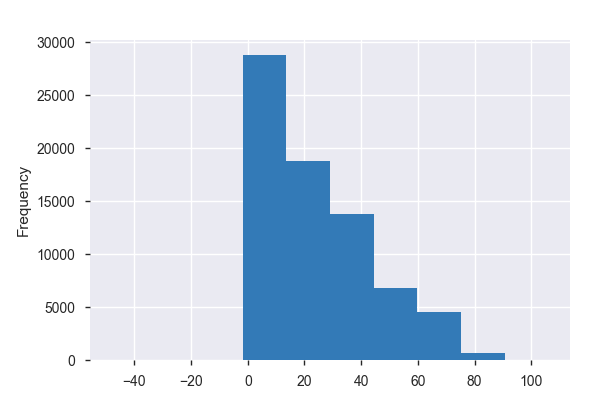

**Common Values**

| Value | Count | Frequency (%) |  |
| --- | --- | --- | --- |
| 0.0 | 23748 | 30.8% |  |
| 25.0 | 2339 | 3.0% |  |
| 24.0 | 2191 | 2.8% |  |
| 23.0 | 2129 | 2.8% |  |
| 26.0 | 2122 | 2.8% |  |
| 27.0 | 1989 | 2.6% |  |
| 22.0 | 1910 | 2.5% |  |
| 28.0 | 1784 | 2.3% |  |
| 30.0 | 1750 | 2.3% |  |
| 29.0 | 1531 | 2.0% |  |
| Other values (100) | 31861 | 41.3% |  |
| (Missing) | 3750 | 4.9% |  |

**Extreme Values**

Minimum 5 values

| Value | Count | Frequency (%) |  |
| --- | --- | --- | --- |
| -48.0 | 1 | 0.0% |  |
| -12.0 | 2 | 0.0% |  |
| -11.0 | 3 | 0.0% |  |
| -10.0 | 2 | 0.0% |  |
| -9.0 | 1 | 0.0% |  |

Maximum 5 values

| Value | Count | Frequency (%) |  |
| --- | --- | --- | --- |
| 94.0 | 2 | 0.0% |  |
| 95.0 | 2 | 0.0% |  |
| 97.0 | 1 | 0.0% |  |
| 98.0 | 1 | 0.0% |  |
| 106.0 | 1 | 0.0% |  |

Jaar_onderzoek  
Highly correlated

*This variable is highly correlated with `index` and should be ignored for analysis*

| Correlation | 0.93303 |
| --- | --- |

filter_.  
Categorical

| Distinct count | 2 |
| --- | --- |
| Unique (%) | 0.0% |
| Missing (%) | 0.0% |
| Missing (n) | 0 |

| Not Selected | 75869 |
| --- | --- |
| Selected | 1235 |

Toggle details

| Value | Count | Frequency (%) |  |
| --- | --- | --- | --- |
| Not Selected | 75869 | 98.4% |  |
| Selected | 1235 | 1.6% |  |

index  
Numeric

| Distinct count | 77104 |
| --- | --- |
| Unique (%) | 100.0% |
| Missing (%) | 0.0% |
| Missing (n) | 0 |
| Infinite (%) | 0.0% |
| Infinite (n) | 0 |

| Mean | 38552 |
| --- | --- |
| Minimum | 1 |
| Maximum | 77104 |
| Zeros (%) | 0.0% |

Toggle details

**Statistics**

Quantile statistics

| Minimum | 1 |
| --- | --- |
| 5-th percentile | 3856.2 |
| Q1 | 19277 |
| Median | 38552 |
| Q3 | 57828 |
| 95-th percentile | 73249 |
| Maximum | 77104 |
| Range | 77103 |
| Interquartile range | 38552 |

Descriptive statistics

| Standard deviation | 22258 |
| --- | --- |
| Coef of variation | 0.57735 |
| Kurtosis | -1.2 |
| Mean | 38552 |
| MAD | 19276 |
| Skewness | 0 |
| Sum | 2972551960 |
| Variance | 495430000 |
| Memory size | 602.5 KiB |

**Histogram**

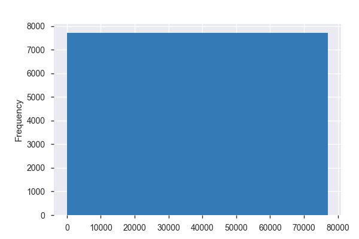

**Common Values**

| Value | Count | Frequency (%) |  |
| --- | --- | --- | --- |
| 2047 | 1 | 0.0% |  |
| 53903 | 1 | 0.0% |  |
| 8849 | 1 | 0.0% |  |
| 14994 | 1 | 0.0% |  |
| 12947 | 1 | 0.0% |  |
| 2708 | 1 | 0.0% |  |
| 661 | 1 | 0.0% |  |
| 6806 | 1 | 0.0% |  |
| 4759 | 1 | 0.0% |  |
| 27288 | 1 | 0.0% |  |
| Other values (77094) | 77094 | 100.0% |  |

**Extreme Values**

Minimum 5 values

| Value | Count | Frequency (%) |  |
| --- | --- | --- | --- |
| 1 | 1 | 0.0% |  |
| 2 | 1 | 0.0% |  |
| 3 | 1 | 0.0% |  |
| 4 | 1 | 0.0% |  |
| 5 | 1 | 0.0% |  |

Maximum 5 values

| Value | Count | Frequency (%) |  |
| --- | --- | --- | --- |
| 77100 | 1 | 0.0% |  |
| 77101 | 1 | 0.0% |  |
| 77102 | 1 | 0.0% |  |
| 77103 | 1 | 0.0% |  |
| 77104 | 1 | 0.0% |  |

v1  
Numeric

| Distinct count | 166 |
| --- | --- |
| Unique (%) | 0.2% |
| Missing (%) | 0.0% |
| Missing (n) | 0 |
| Infinite (%) | 0.0% |
| Infinite (n) | 0 |

| Mean | 8714.4 |
| --- | --- |
| Minimum | 1000 |
| Maximum | 90001 |
| Zeros (%) | 0.0% |

Toggle details

**Statistics**

Quantile statistics

| Minimum | 1000 |
| --- | --- |
| 5-th percentile | 1780 |
| Q1 | 3110 |
| Median | 3930 |
| Q3 | 9140 |
| 95-th percentile | 24001 |
| Maximum | 90001 |
| Range | 89001 |
| Interquartile range | 6030 |

Descriptive statistics

| Standard deviation | 14672 |
| --- | --- |
| Coef of variation | 1.6837 |
| Kurtosis | 21.946 |
| Mean | 8714.4 |
| MAD | 6134.9 |
| Skewness | 4.6682 |
| Sum | 671918703 |
| Variance | 215280000 |
| Memory size | 602.5 KiB |

**Histogram**

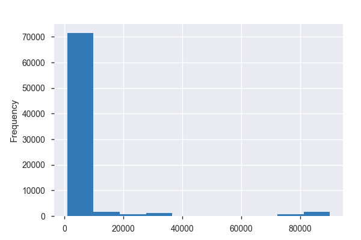

**Common Values**

| Value | Count | Frequency (%) |  |
| --- | --- | --- | --- |
| 90001 | 1592 | 2.1% |  |
| 9000 | 984 | 1.3% |  |
| 3500 | 800 | 1.0% |  |
| 9100 | 800 | 1.0% |  |
| 8000 | 755 | 1.0% |  |
| 3600 | 751 | 1.0% |  |
| 80001 | 734 | 1.0% |  |
| 36001 | 717 | 0.9% |  |
| 8800 | 664 | 0.9% |  |
| 8500 | 657 | 0.9% |  |
| Other values (156) | 68650 | 89.0% |  |

**Extreme Values**

Minimum 5 values

| Value | Count | Frequency (%) |  |
| --- | --- | --- | --- |
| 1000 | 602 | 0.8% |  |
| 1547 | 109 | 0.1% |  |
| 1570 | 432 | 0.6% |  |
| 1650 | 503 | 0.7% |  |
| 1700 | 455 | 0.6% |  |

Maximum 5 values

| Value | Count | Frequency (%) |  |
| --- | --- | --- | --- |
| 24001 | 616 | 0.8% |  |
| 34701 | 418 | 0.5% |  |
| 36001 | 717 | 0.9% |  |
| 80001 | 734 | 1.0% |  |
| 90001 | 1592 | 2.1% |  |

v10  
Numeric

| Distinct count | 53 |
| --- | --- |
| Unique (%) | 0.1% |
| Missing (%) | 0.0% |
| Missing (n) | 29 |
| Infinite (%) | 0.0% |
| Infinite (n) | 0 |

| Mean | 9.5659 |
| --- | --- |
| Minimum | 0 |
| Maximum | 99 |
| Zeros (%) | 15.3% |

Toggle details

**Statistics**

Quantile statistics

| Minimum | 0 |
| --- | --- |
| 5-th percentile | 0 |
| Q1 | 1 |
| Median | 3 |
| Q3 | 6 |
| 95-th percentile | 99 |
| Maximum | 99 |
| Range | 99 |
| Interquartile range | 5 |

Descriptive statistics

| Standard deviation | 23.235 |
| --- | --- |
| Coef of variation | 2.4289 |
| Kurtosis | 10.609 |
| Mean | 9.5659 |
| MAD | 11.503 |
| Skewness | 3.508 |
| Sum | 737290 |
| Variance | 539.86 |
| Memory size | 602.5 KiB |

**Histogram**

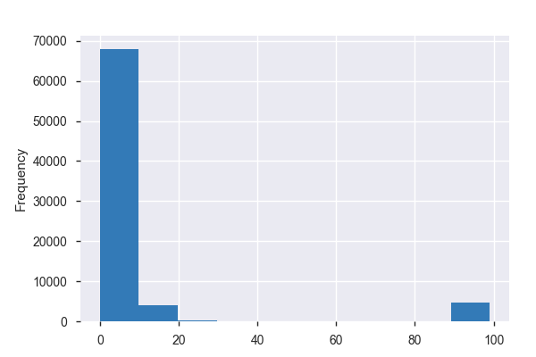

**Common Values**

| Value | Count | Frequency (%) |  |
| --- | --- | --- | --- |
| 2.0 | 13040 | 16.9% |  |
| 0.0 | 11818 | 15.3% |  |
| 3.0 | 8868 | 11.5% |  |
| 4.0 | 8702 | 11.3% |  |
| 1.0 | 8079 | 10.5% |  |
| 5.0 | 5983 | 7.8% |  |
| 99.0 | 4773 | 6.2% |  |
| 6.0 | 4469 | 5.8% |  |
| 7.0 | 3189 | 4.1% |  |
| 8.0 | 2181 | 2.8% |  |
| Other values (42) | 5973 | 7.7% |  |

**Extreme Values**

Minimum 5 values

| Value | Count | Frequency (%) |  |
| --- | --- | --- | --- |
| 0.0 | 11818 | 15.3% |  |
| 1.0 | 8079 | 10.5% |  |
| 2.0 | 13040 | 16.9% |  |
| 3.0 | 8868 | 11.5% |  |
| 4.0 | 8702 | 11.3% |  |

Maximum 5 values

| Value | Count | Frequency (%) |  |
| --- | --- | --- | --- |
| 68.0 | 1 | 0.0% |  |
| 69.0 | 1 | 0.0% |  |
| 74.0 | 1 | 0.0% |  |
| 80.0 | 1 | 0.0% |  |
| 99.0 | 4773 | 6.2% |  |

v100  
Numeric

| Distinct count | 129 |
| --- | --- |
| Unique (%) | 0.2% |
| Missing (%) | 4.5% |
| Missing (n) | 3480 |
| Infinite (%) | 0.0% |
| Infinite (n) | 0 |

| Mean | 65.107 |
| --- | --- |
| Minimum | 0 |
| Maximum | 3798 |
| Zeros (%) | 0.3% |

Toggle details

**Statistics**

Quantile statistics

| Minimum | 0 |
| --- | --- |
| 5-th percentile | 1 |
| Q1 | 1 |
| Median | 4 |
| Q3 | 99 |
| 95-th percentile | 213 |
| Maximum | 3798 |
| Range | 3798 |
| Interquartile range | 98 |

Descriptive statistics

| Standard deviation | 283.92 |
| --- | --- |
| Coef of variation | 4.3608 |
| Kurtosis | 159.37 |
| Mean | 65.107 |
| MAD | 79.98 |
| Skewness | 12.376 |
| Sum | 4793400 |
| Variance | 80611 |
| Memory size | 602.5 KiB |

**Histogram**

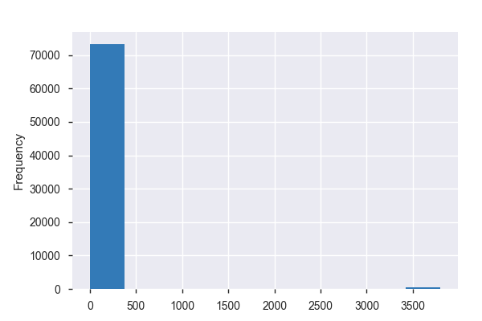

**Common Values**

| Value | Count | Frequency (%) |  |
| --- | --- | --- | --- |
| 1.0 | 22261 | 28.9% |  |
| 99.0 | 18698 | 24.3% |  |
| 2.0 | 7979 | 10.3% |  |
| 3.0 | 6157 | 8.0% |  |
| 4.0 | 3349 | 4.3% |  |
| 5.0 | 1915 | 2.5% |  |
| 6.0 | 1342 | 1.7% |  |
| 7.0 | 779 | 1.0% |  |
| 8.0 | 717 | 0.9% |  |
| 213.0 | 691 | 0.9% |  |
| Other values (118) | 9736 | 12.6% |  |
| (Missing) | 3480 | 4.5% |  |

**Extreme Values**

Minimum 5 values

| Value | Count | Frequency (%) |  |
| --- | --- | --- | --- |
| 0.0 | 205 | 0.3% |  |
| 1.0 | 22261 | 28.9% |  |
| 2.0 | 7979 | 10.3% |  |
| 3.0 | 6157 | 8.0% |  |
| 4.0 | 3349 | 4.3% |  |

Maximum 5 values

| Value | Count | Frequency (%) |  |
| --- | --- | --- | --- |
| 3790.0 | 176 | 0.2% |  |
| 3791.0 | 32 | 0.0% |  |
| 3792.0 | 14 | 0.0% |  |
| 3793.0 | 46 | 0.1% |  |
| 3798.0 | 134 | 0.2% |  |

v101  
Categorical

| Distinct count | 7 |
| --- | --- |
| Unique (%) | 0.0% |
| Missing (%) | 4.5% |
| Missing (n) | 3471 |

| uiterst negatief | 48110 |
| --- | --- |
| noch negatief/ noch positief | 7487 |
| eerder negatief | 7359 |
| Other values (3) | 10677 |

Toggle details

| Value | Count | Frequency (%) |  |
| --- | --- | --- | --- |
| uiterst negatief | 48110 | 62.4% |  |
| noch negatief/ noch positief | 7487 | 9.7% |  |
| eerder negatief | 7359 | 9.5% |  |
| 99 | 6086 | 7.9% |  |
| eerder positief | 2782 | 3.6% |  |
| uiterst positief | 1809 | 2.3% |  |
| (Missing) | 3471 | 4.5% |  |

v102  
Categorical

| Distinct count | 7 |
| --- | --- |
| Unique (%) | 0.0% |
| Missing (%) | 4.5% |
| Missing (n) | 3471 |

| uiterst positief | 27581 |
| --- | --- |
| uiterst negatief | 21103 |
| eerder positief | 12932 |
| Other values (3) | 12017 |

Toggle details

| Value | Count | Frequency (%) |  |
| --- | --- | --- | --- |
| uiterst positief | 27581 | 35.8% |  |
| uiterst negatief | 21103 | 27.4% |  |
| eerder positief | 12932 | 16.8% |  |
| 99 | 6038 | 7.8% |  |
| noch negatief/ noch positief | 4569 | 5.9% |  |
| eerder negatief | 1410 | 1.8% |  |
| (Missing) | 3471 | 4.5% |  |

v103  
Categorical

| Distinct count | 4 |
| --- | --- |
| Unique (%) | 0.0% |
| Missing (%) | 4.6% |
| Missing (n) | 3525 |

| neen | 48565 |
| --- | --- |
| ja | 15266 |
| 99 | 9748 |
| (Missing) | 3525 |

Toggle details

| Value | Count | Frequency (%) |  |
| --- | --- | --- | --- |
| neen | 48565 | 63.0% |  |
| ja | 15266 | 19.8% |  |
| 99 | 9748 | 12.6% |  |
| (Missing) | 3525 | 4.6% |  |

v104  
Categorical

| Distinct count | 4 |
| --- | --- |
| Unique (%) | 0.0% |
| Missing (%) | 4.6% |
| Missing (n) | 3525 |

| neen | 51656 |
| --- | --- |
| ja | 12153 |
| 99 | 9770 |
| (Missing) | 3525 |

Toggle details

| Value | Count | Frequency (%) |  |
| --- | --- | --- | --- |
| neen | 51656 | 67.0% |  |
| ja | 12153 | 15.8% |  |
| 99 | 9770 | 12.7% |  |
| (Missing) | 3525 | 4.6% |  |

v105  
Unsupported

*This variable is an unsupported type, check if it needs cleaning or further analysis*

| Unsupported value |
| --- |

v106  
Categorical

| Distinct count | 7 |
| --- | --- |
| Unique (%) | 0.0% |
| Missing (%) | 4.5% |
| Missing (n) | 3477 |

| mee eens | 25065 |
| --- | --- |
| helemaal eens | 17308 |
| noch eens/noch oneens | 10325 |
| Other values (3) | 20929 |

Toggle details

| Value | Count | Frequency (%) |  |
| --- | --- | --- | --- |
| mee eens | 25065 | 32.5% |  |
| helemaal eens | 17308 | 22.4% |  |
| noch eens/noch oneens | 10325 | 13.4% |  |
| 99 | 9351 | 12.1% |  |
| helemaal oneens | 8092 | 10.5% |  |
| mee oneens | 3486 | 4.5% |  |
| (Missing) | 3477 | 4.5% |  |

v107  
Categorical

| Distinct count | 7 |
| --- | --- |
| Unique (%) | 0.0% |
| Missing (%) | 4.5% |
| Missing (n) | 3477 |

| helemaal oneens | 26879 |
| --- | --- |
| 99 | 12787 |
| mee oneens | 12319 |
| Other values (3) | 21642 |

Toggle details

| Value | Count | Frequency (%) |  |
| --- | --- | --- | --- |
| helemaal oneens | 26879 | 34.9% |  |
| 99 | 12787 | 16.6% |  |
| mee oneens | 12319 | 16.0% |  |
| noch eens/noch oneens | 11958 | 15.5% |  |
| mee eens | 6256 | 8.1% |  |
| helemaal eens | 3428 | 4.4% |  |
| (Missing) | 3477 | 4.5% |  |

v108  
Categorical

| Distinct count | 7 |
| --- | --- |
| Unique (%) | 0.0% |
| Missing (%) | 4.5% |
| Missing (n) | 3477 |

| helemaal oneens | 27616 |
| --- | --- |
| 99 | 13291 |
| mee oneens | 12746 |
| Other values (3) | 19974 |

Toggle details

| Value | Count | Frequency (%) |  |
| --- | --- | --- | --- |
| helemaal oneens | 27616 | 35.8% |  |
| 99 | 13291 | 17.2% |  |
| mee oneens | 12746 | 16.5% |  |
| noch eens/noch oneens | 11278 | 14.6% |  |
| mee eens | 5863 | 7.6% |  |
| helemaal eens | 2833 | 3.7% |  |
| (Missing) | 3477 | 4.5% |  |

v109  
Categorical

| Distinct count | 7 |
| --- | --- |
| Unique (%) | 0.0% |
| Missing (%) | 4.5% |
| Missing (n) | 3477 |

| helemaal oneens | 25343 |
| --- | --- |
| 99 | 13535 |
| mee oneens | 12924 |
| Other values (3) | 21825 |

Toggle details

| Value | Count | Frequency (%) |  |
| --- | --- | --- | --- |
| helemaal oneens | 25343 | 32.9% |  |
| 99 | 13535 | 17.6% |  |
| mee oneens | 12924 | 16.8% |  |
| noch eens/noch oneens | 11766 | 15.3% |  |
| mee eens | 7000 | 9.1% |  |
| helemaal eens | 3059 | 4.0% |  |
| (Missing) | 3477 | 4.5% |  |

v110  
Categorical

| Distinct count | 7 |
| --- | --- |
| Unique (%) | 0.0% |
| Missing (%) | 4.5% |
| Missing (n) | 3477 |

| helemaal oneens | 28672 |
| --- | --- |
| 99 | 12765 |
| mee oneens | 10524 |
| Other values (3) | 21666 |

Toggle details

| Value | Count | Frequency (%) |  |
| --- | --- | --- | --- |
| helemaal oneens | 28672 | 37.2% |  |
| 99 | 12765 | 16.6% |  |
| mee oneens | 10524 | 13.6% |  |
| noch eens/noch oneens | 7856 | 10.2% |  |
| mee eens | 7389 | 9.6% |  |
| helemaal eens | 6421 | 8.3% |  |
| (Missing) | 3477 | 4.5% |  |

v111  
Categorical

| Distinct count | 7 |
| --- | --- |
| Unique (%) | 0.0% |
| Missing (%) | 4.5% |
| Missing (n) | 3477 |

| helemaal oneens | 27526 |
| --- | --- |
| 99 | 13361 |
| mee oneens | 12141 |
| Other values (3) | 20599 |

Toggle details

| Value | Count | Frequency (%) |  |
| --- | --- | --- | --- |
| helemaal oneens | 27526 | 35.7% |  |
| 99 | 13361 | 17.3% |  |
| mee oneens | 12141 | 15.7% |  |
| noch eens/noch oneens | 10526 | 13.7% |  |
| mee eens | 7279 | 9.4% |  |
| helemaal eens | 2794 | 3.6% |  |
| (Missing) | 3477 | 4.5% |  |

v112  
Categorical

| Distinct count | 7 |
| --- | --- |
| Unique (%) | 0.0% |
| Missing (%) | 4.5% |
| Missing (n) | 3477 |

| mee eens | 20384 |
| --- | --- |
| noch eens/noch oneens | 14952 |
| 99 | 13462 |
| Other values (3) | 24829 |

Toggle details

| Value | Count | Frequency (%) |  |
| --- | --- | --- | --- |
| mee eens | 20384 | 26.4% |  |
| noch eens/noch oneens | 14952 | 19.4% |  |
| 99 | 13462 | 17.5% |  |
| helemaal eens | 10416 | 13.5% |  |
| helemaal oneens | 8220 | 10.7% |  |
| mee oneens | 6193 | 8.0% |  |
| (Missing) | 3477 | 4.5% |  |

v113  
Categorical

| Distinct count | 7 |
| --- | --- |
| Unique (%) | 0.0% |
| Missing (%) | 4.5% |
| Missing (n) | 3477 |

| helemaal oneens | 30070 |
| --- | --- |
| 99 | 13908 |
| mee oneens | 12866 |
| Other values (3) | 16783 |

Toggle details

| Value | Count | Frequency (%) |  |
| --- | --- | --- | --- |
| helemaal oneens | 30070 | 39.0% |  |
| 99 | 13908 | 18.0% |  |
| mee oneens | 12866 | 16.7% |  |
| noch eens/noch oneens | 10580 | 13.7% |  |
| mee eens | 4329 | 5.6% |  |
| helemaal eens | 1874 | 2.4% |  |
| (Missing) | 3477 | 4.5% |  |

v114  
Categorical

| Distinct count | 7 |
| --- | --- |
| Unique (%) | 0.0% |
| Missing (%) | 4.5% |
| Missing (n) | 3477 |

| helemaal oneens | 35405 |
| --- | --- |
| 99 | 14435 |
| mee oneens | 11830 |
| Other values (3) | 11957 |

Toggle details

| Value | Count | Frequency (%) |  |
| --- | --- | --- | --- |
| helemaal oneens | 35405 | 45.9% |  |
| 99 | 14435 | 18.7% |  |
| mee oneens | 11830 | 15.3% |  |
| noch eens/noch oneens | 7992 | 10.4% |  |
| mee eens | 2347 | 3.0% |  |
| helemaal eens | 1618 | 2.1% |  |
| (Missing) | 3477 | 4.5% |  |

v115  
Categorical

| Distinct count | 7 |
| --- | --- |
| Unique (%) | 0.0% |
| Missing (%) | 4.5% |
| Missing (n) | 3477 |

| helemaal oneens | 31656 |
| --- | --- |
| 99 | 19256 |
| mee oneens | 11922 |
| Other values (3) | 10793 |

Toggle details

| Value | Count | Frequency (%) |  |
| --- | --- | --- | --- |
| helemaal oneens | 31656 | 41.1% |  |
| 99 | 19256 | 25.0% |  |
| mee oneens | 11922 | 15.5% |  |
| noch eens/noch oneens | 7209 | 9.3% |  |
| mee eens | 2295 | 3.0% |  |
| helemaal eens | 1289 | 1.7% |  |
| (Missing) | 3477 | 4.5% |  |

v116  
Categorical

| Distinct count | 7 |
| --- | --- |
| Unique (%) | 0.0% |
| Missing (%) | 4.5% |
| Missing (n) | 3477 |

| helemaal oneens | 32122 |
| --- | --- |
| 99 | 18473 |
| mee oneens | 10916 |
| Other values (3) | 12116 |

Toggle details

| Value | Count | Frequency (%) |  |
| --- | --- | --- | --- |
| helemaal oneens | 32122 | 41.7% |  |
| 99 | 18473 | 24.0% |  |
| mee oneens | 10916 | 14.2% |  |
| noch eens/noch oneens | 7171 | 9.3% |  |
| mee eens | 3104 | 4.0% |  |
| helemaal eens | 1841 | 2.4% |  |
| (Missing) | 3477 | 4.5% |  |

v117  
Categorical

| Distinct count | 7 |
| --- | --- |
| Unique (%) | 0.0% |
| Missing (%) | 91.3% |
| Missing (n) | 70402 |

| mee eens | 1839 |
| --- | --- |
| noch eens/noch oneens | 1525 |
| helemaal eens | 1183 |
| Other values (3) | 2155 |
| (Missing) | 70402 |

Toggle details

| Value | Count | Frequency (%) |  |
| --- | --- | --- | --- |
| mee eens | 1839 | 2.4% |  |
| noch eens/noch oneens | 1525 | 2.0% |  |
| helemaal eens | 1183 | 1.5% |  |
| helemaal oneens | 1086 | 1.4% |  |
| mee oneens | 629 | 0.8% |  |
| 99 | 440 | 0.6% |  |
| (Missing) | 70402 | 91.3% |  |

v118  
Categorical

| Distinct count | 7 |
| --- | --- |
| Unique (%) | 0.0% |
| Missing (%) | 91.3% |
| Missing (n) | 70402 |

| helemaal oneens | 2348 |
| --- | --- |
| noch eens/noch oneens | 1249 |
| mee eens | 993 |
| Other values (3) | 2112 |
| (Missing) | 70402 |

Toggle details

| Value | Count | Frequency (%) |  |
| --- | --- | --- | --- |
| helemaal oneens | 2348 | 3.0% |  |
| noch eens/noch oneens | 1249 | 1.6% |  |
| mee eens | 993 | 1.3% |  |
| mee oneens | 943 | 1.2% |  |
| helemaal eens | 615 | 0.8% |  |
| 99 | 554 | 0.7% |  |
| (Missing) | 70402 | 91.3% |  |

v119  
Categorical

| Distinct count | 4 |
| --- | --- |
| Unique (%) | 0.0% |
| Missing (%) | 4.5% |
| Missing (n) | 3478 |

| neen | 43052 |
| --- | --- |
| ja | 18284 |
| 99 | 12290 |
| (Missing) | 3478 |

Toggle details

| Value | Count | Frequency (%) |  |
| --- | --- | --- | --- |
| neen | 43052 | 55.8% |  |
| ja | 18284 | 23.7% |  |
| 99 | 12290 | 15.9% |  |
| (Missing) | 3478 | 4.5% |  |

v11_1  
Categorical

| Distinct count | 4 |
| --- | --- |
| Unique (%) | 0.0% |
| Missing (%) | 0.0% |
| Missing (n) | 0 |

| 99 | 64512 |
| --- | --- |
| partner | 6711 |
| 99 | 3205 |

Toggle details

| Value | Count | Frequency (%) |  |
| --- | --- | --- | --- |
| 99 | 64512 | 83.7% |  |
| partner | 6711 | 8.7% |  |
| 99 | 3205 | 4.2% |  |
| neen | 2676 | 3.5% |  |

v11_2  
Categorical

| Distinct count | 4 |
| --- | --- |
| Unique (%) | 0.0% |
| Missing (%) | 0.0% |
| Missing (n) | 0 |

| 99 | 64512 |
| --- | --- |
| neen | 7532 |
| 99 | 3205 |

Toggle details

| Value | Count | Frequency (%) |  |
| --- | --- | --- | --- |
| 99 | 64512 | 83.7% |  |
| neen | 7532 | 9.8% |  |
| 99 | 3205 | 4.2% |  |
| kind(eren) | 1855 | 2.4% |  |

v11_3  
Categorical

| Distinct count | 4 |
| --- | --- |
| Unique (%) | 0.0% |
| Missing (%) | 0.0% |
| Missing (n) | 0 |

| 99 | 64512 |
| --- | --- |
| neen | 8288 |
| 99 | 3205 |

Toggle details

| Value | Count | Frequency (%) |  |
| --- | --- | --- | --- |
| 99 | 64512 | 83.7% |  |
| neen | 8288 | 10.7% |  |
| 99 | 3205 | 4.2% |  |
| kleinkind(eren) | 1099 | 1.4% |  |

v11_4  
Categorical

| Distinct count | 4 |
| --- | --- |
| Unique (%) | 0.0% |
| Missing (%) | 0.0% |
| Missing (n) | 0 |

| 99 | 64512 |
| --- | --- |
| neen | 9160 |
| 99 | 3205 |

Toggle details

| Value | Count | Frequency (%) |  |
| --- | --- | --- | --- |
| 99 | 64512 | 83.7% |  |
| neen | 9160 | 11.9% |  |
| 99 | 3205 | 4.2% |  |
| ouder(s) | 227 | 0.3% |  |

v11_5  
Categorical

| Distinct count | 4 |
| --- | --- |
| Unique (%) | 0.0% |
| Missing (%) | 0.0% |
| Missing (n) | 0 |

| 99 | 64512 |
| --- | --- |
| neen | 9075 |
| 99 | 3205 |

Toggle details

| Value | Count | Frequency (%) |  |
| --- | --- | --- | --- |
| 99 | 64512 | 83.7% |  |
| neen | 9075 | 11.8% |  |
| 99 | 3205 | 4.2% |  |
| andere(n) | 312 | 0.4% |  |

v12  
Categorical

| Distinct count | 13 |
| --- | --- |
| Unique (%) | 0.0% |
| Missing (%) | 0.0% |
| Missing (n) | 0 |

| huisvrouw/man | 17708 |
| --- | --- |
| hoger bediende | 10654 |
| ongeschoolde arbeider | 10503 |
| Other values (10) | 38239 |

Toggle details

| Value | Count | Frequency (%) |  |
| --- | --- | --- | --- |
| huisvrouw/man | 17708 | 23.0% |  |
| hoger bediende | 10654 | 13.8% |  |
| ongeschoolde arbeider | 10503 | 13.6% |  |
| geschoolde arbeider | 8957 | 11.6% |  |
| lager bediende | 6123 | 7.9% |  |
| andere loontrekkende | 6078 | 7.9% |  |
| andere zelfstandige | 4444 | 5.8% |  |
| 99 | 3269 | 4.2% |  |
| landbouwer | 2705 | 3.5% |  |
| hulp van zelfstandige | 2550 | 3.3% |  |
| Other values (3) | 4113 | 5.3% |  |

v120  
Categorical

| Distinct count | 4 |
| --- | --- |
| Unique (%) | 0.0% |
| Missing (%) | 4.5% |
| Missing (n) | 3478 |

| neen | 36051 |
| --- | --- |
| ja | 25683 |
| 99 | 11892 |
| (Missing) | 3478 |

Toggle details

| Value | Count | Frequency (%) |  |
| --- | --- | --- | --- |
| neen | 36051 | 46.8% |  |
| ja | 25683 | 33.3% |  |
| 99 | 11892 | 15.4% |  |
| (Missing) | 3478 | 4.5% |  |

v121_1  
Numeric

| Distinct count | 9 |
| --- | --- |
| Unique (%) | 0.0% |
| Missing (%) | 13.2% |
| Missing (n) | 10180 |
| Infinite (%) | 0.0% |
| Infinite (n) | 0 |

| Mean | 29.932 |
| --- | --- |
| Minimum | 1 |
| Maximum | 99 |
| Zeros (%) | 0.0% |

Toggle details

**Statistics**

Quantile statistics

| Minimum | 1 |
| --- | --- |
| 5-th percentile | 1 |
| Q1 | 4 |
| Median | 7 |
| Q3 | 99 |
| 95-th percentile | 99 |
| Maximum | 99 |
| Range | 98 |
| Interquartile range | 95 |

Descriptive statistics

| Standard deviation | 41.467 |
| --- | --- |
| Coef of variation | 1.3854 |
| Kurtosis | -0.86455 |
| Mean | 29.932 |
| MAD | 36.555 |
| Skewness | 1.0615 |
| Sum | 2003100 |
| Variance | 1719.5 |
| Memory size | 602.5 KiB |

**Histogram**

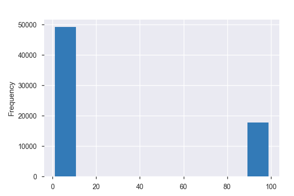

**Common Values**

| Value | Count | Frequency (%) |  |
| --- | --- | --- | --- |
| 7.0 | 18367 | 23.8% |  |
| 99.0 | 17710 | 23.0% |  |
| 4.0 | 12319 | 16.0% |  |
| 6.0 | 5897 | 7.6% |  |
| 1.0 | 4982 | 6.5% |  |
| 5.0 | 4960 | 6.4% |  |
| 3.0 | 1472 | 1.9% |  |
| 2.0 | 1217 | 1.6% |  |
| (Missing) | 10180 | 13.2% |  |

**Extreme Values**

Minimum 5 values

| Value | Count | Frequency (%) |  |
| --- | --- | --- | --- |
| 1.0 | 4982 | 6.5% |  |
| 2.0 | 1217 | 1.6% |  |
| 3.0 | 1472 | 1.9% |  |
| 4.0 | 12319 | 16.0% |  |
| 5.0 | 4960 | 6.4% |  |

Maximum 5 values

| Value | Count | Frequency (%) |  |
| --- | --- | --- | --- |
| 4.0 | 12319 | 16.0% |  |
| 5.0 | 4960 | 6.4% |  |
| 6.0 | 5897 | 7.6% |  |
| 7.0 | 18367 | 23.8% |  |
| 99.0 | 17710 | 23.0% |  |

v121_10  
Numeric

| Distinct count | 9 |
| --- | --- |
| Unique (%) | 0.0% |
| Missing (%) | 13.2% |
| Missing (n) | 10180 |
| Infinite (%) | 0.0% |
| Infinite (n) | 0 |

| Mean | 35.997 |
| --- | --- |
| Minimum | 1 |
| Maximum | 99 |
| Zeros (%) | 0.0% |

Toggle details

**Statistics**

Quantile statistics

| Minimum | 1 |
| --- | --- |
| 5-th percentile | 1 |
| Q1 | 4 |
| Median | 7 |
| Q3 | 99 |
| 95-th percentile | 99 |
| Maximum | 99 |
| Range | 98 |
| Interquartile range | 95 |

Descriptive statistics

| Standard deviation | 44.165 |
| --- | --- |
| Coef of variation | 1.2269 |
| Kurtosis | -1.4716 |
| Mean | 35.997 |
| MAD | 41.48 |
| Skewness | 0.72272 |
| Sum | 2409100 |
| Variance | 1950.5 |
| Memory size | 602.5 KiB |

**Histogram**

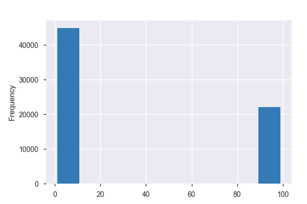

**Common Values**

| Value | Count | Frequency (%) |  |
| --- | --- | --- | --- |
| 99.0 | 22031 | 28.6% |  |
| 7.0 | 16055 | 20.8% |  |
| 4.0 | 9572 | 12.4% |  |
| 6.0 | 6804 | 8.8% |  |
| 5.0 | 4740 | 6.1% |  |
| 1.0 | 4525 | 5.9% |  |
| 3.0 | 1904 | 2.5% |  |
| 2.0 | 1293 | 1.7% |  |
| (Missing) | 10180 | 13.2% |  |

**Extreme Values**

Minimum 5 values

| Value | Count | Frequency (%) |  |
| --- | --- | --- | --- |
| 1.0 | 4525 | 5.9% |  |
| 2.0 | 1293 | 1.7% |  |
| 3.0 | 1904 | 2.5% |  |
| 4.0 | 9572 | 12.4% |  |
| 5.0 | 4740 | 6.1% |  |

Maximum 5 values

| Value | Count | Frequency (%) |  |
| --- | --- | --- | --- |
| 4.0 | 9572 | 12.4% |  |
| 5.0 | 4740 | 6.1% |  |
| 6.0 | 6804 | 8.8% |  |
| 7.0 | 16055 | 20.8% |  |
| 99.0 | 22031 | 28.6% |  |

v121_11  
Highly correlated

*This variable is highly correlated with `v121_10` and should be ignored for analysis*

| Correlation | 0.90948 |
| --- | --- |

v121_12  
Highly correlated

*This variable is highly correlated with `v121_11` and should be ignored for analysis*

| Correlation | 0.91146 |
| --- | --- |

v121_13  
Numeric

| Distinct count | 9 |
| --- | --- |
| Unique (%) | 0.0% |
| Missing (%) | 13.2% |
| Missing (n) | 10180 |
| Infinite (%) | 0.0% |
| Infinite (n) | 0 |

| Mean | 32.443 |
| --- | --- |
| Minimum | 1 |
| Maximum | 99 |
| Zeros (%) | 0.0% |

Toggle details

**Statistics**

Quantile statistics

| Minimum | 1 |
| --- | --- |
| 5-th percentile | 3 |
| Q1 | 6 |
| Median | 7 |
| Q3 | 99 |
| 95-th percentile | 99 |
| Maximum | 99 |
| Range | 98 |
| Interquartile range | 93 |

Descriptive statistics

| Standard deviation | 42.142 |
| --- | --- |
| Coef of variation | 1.299 |
| Kurtosis | -1.1039 |
| Mean | 32.443 |
| MAD | 38.066 |
| Skewness | 0.94393 |
| Sum | 2171200 |
| Variance | 1776 |
| Memory size | 602.5 KiB |

**Histogram**

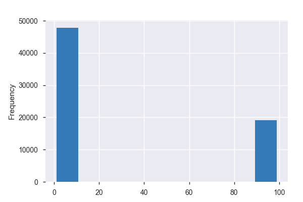

**Common Values**

| Value | Count | Frequency (%) |  |
| --- | --- | --- | --- |
| 7.0 | 23477 | 30.4% |  |
| 99.0 | 19138 | 24.8% |  |
| 6.0 | 8971 | 11.6% |  |
| 4.0 | 7093 | 9.2% |  |
| 5.0 | 4885 | 6.3% |  |
| 1.0 | 1979 | 2.6% |  |
| 3.0 | 841 | 1.1% |  |
| 2.0 | 540 | 0.7% |  |
| (Missing) | 10180 | 13.2% |  |

**Extreme Values**

Minimum 5 values

| Value | Count | Frequency (%) |  |
| --- | --- | --- | --- |
| 1.0 | 1979 | 2.6% |  |
| 2.0 | 540 | 0.7% |  |
| 3.0 | 841 | 1.1% |  |
| 4.0 | 7093 | 9.2% |  |
| 5.0 | 4885 | 6.3% |  |

Maximum 5 values

| Value | Count | Frequency (%) |  |
| --- | --- | --- | --- |
| 4.0 | 7093 | 9.2% |  |
| 5.0 | 4885 | 6.3% |  |
| 6.0 | 8971 | 11.6% |  |
| 7.0 | 23477 | 30.4% |  |
| 99.0 | 19138 | 24.8% |  |

v121_14  
Numeric

| Distinct count | 9 |
| --- | --- |
| Unique (%) | 0.0% |
| Missing (%) | 13.2% |
| Missing (n) | 10180 |
| Infinite (%) | 0.0% |
| Infinite (n) | 0 |

| Mean | 35.061 |
| --- | --- |
| Minimum | 1 |
| Maximum | 99 |
| Zeros (%) | 0.0% |

Toggle details

**Statistics**

Quantile statistics

| Minimum | 1 |
| --- | --- |
| 5-th percentile | 1 |
| Q1 | 5 |
| Median | 7 |
| Q3 | 99 |
| 95-th percentile | 99 |
| Maximum | 99 |
| Range | 98 |
| Interquartile range | 94 |

Descriptive statistics

| Standard deviation | 43.708 |
| --- | --- |
| Coef of variation | 1.2466 |
| Kurtosis | -1.3909 |
| Mean | 35.061 |
| MAD | 40.689 |
| Skewness | 0.77644 |
| Sum | 2346400 |
| Variance | 1910.4 |
| Memory size | 602.5 KiB |

**Histogram**

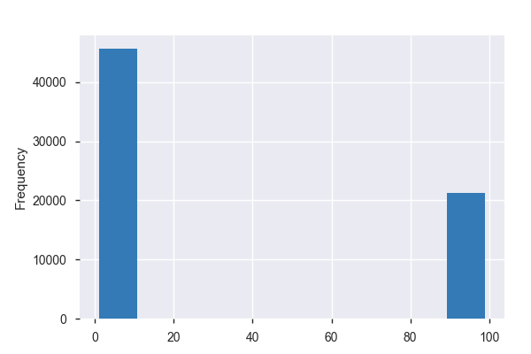

**Common Values**

| Value | Count | Frequency (%) |  |
| --- | --- | --- | --- |
| 99.0 | 21294 | 27.6% |  |
| 7.0 | 17771 | 23.0% |  |
| 4.0 | 8771 | 11.4% |  |
| 6.0 | 7130 | 9.2% |  |
| 5.0 | 4823 | 6.3% |  |
| 1.0 | 4100 | 5.3% |  |
| 3.0 | 1753 | 2.3% |  |
| 2.0 | 1282 | 1.7% |  |
| (Missing) | 10180 | 13.2% |  |

**Extreme Values**

Minimum 5 values

| Value | Count | Frequency (%) |  |
| --- | --- | --- | --- |
| 1.0 | 4100 | 5.3% |  |
| 2.0 | 1282 | 1.7% |  |
| 3.0 | 1753 | 2.3% |  |
| 4.0 | 8771 | 11.4% |  |
| 5.0 | 4823 | 6.3% |  |

Maximum 5 values

| Value | Count | Frequency (%) |  |
| --- | --- | --- | --- |
| 4.0 | 8771 | 11.4% |  |
| 5.0 | 4823 | 6.3% |  |
| 6.0 | 7130 | 9.2% |  |
| 7.0 | 17771 | 23.0% |  |
| 99.0 | 21294 | 27.6% |  |

v121_15  
Numeric

| Distinct count | 9 |
| --- | --- |
| Unique (%) | 0.0% |
| Missing (%) | 13.2% |
| Missing (n) | 10180 |
| Infinite (%) | 0.0% |
| Infinite (n) | 0 |

| Mean | 33.761 |
| --- | --- |
| Minimum | 1 |
| Maximum | 99 |
| Zeros (%) | 0.0% |

Toggle details

**Statistics**

Quantile statistics

| Minimum | 1 |
| --- | --- |
| 5-th percentile | 1 |
| Q1 | 3 |
| Median | 5 |
| Q3 | 99 |
| 95-th percentile | 99 |
| Maximum | 99 |
| Range | 98 |
| Interquartile range | 96 |

Descriptive statistics

| Standard deviation | 44.217 |
| --- | --- |
| Coef of variation | 1.3097 |
| Kurtosis | -1.362 |
| Mean | 33.761 |
| MAD | 41.03 |
| Skewness | 0.79464 |
| Sum | 2259400 |
| Variance | 1955.1 |
| Memory size | 602.5 KiB |

**Histogram**

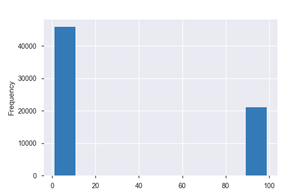

**Common Values**

| Value | Count | Frequency (%) |  |
| --- | --- | --- | --- |
| 99.0 | 21045 | 27.3% |  |
| 4.0 | 13265 | 17.2% |  |
| 1.0 | 9945 | 12.9% |  |
| 7.0 | 6628 | 8.6% |  |
| 5.0 | 4854 | 6.3% |  |
| 6.0 | 4056 | 5.3% |  |
| 3.0 | 3710 | 4.8% |  |
| 2.0 | 3421 | 4.4% |  |
| (Missing) | 10180 | 13.2% |  |

**Extreme Values**

Minimum 5 values

| Value | Count | Frequency (%) |  |
| --- | --- | --- | --- |
| 1.0 | 9945 | 12.9% |  |
| 2.0 | 3421 | 4.4% |  |
| 3.0 | 3710 | 4.8% |  |
| 4.0 | 13265 | 17.2% |  |
| 5.0 | 4854 | 6.3% |  |

Maximum 5 values

| Value | Count | Frequency (%) |  |
| --- | --- | --- | --- |
| 4.0 | 13265 | 17.2% |  |
| 5.0 | 4854 | 6.3% |  |
| 6.0 | 4056 | 5.3% |  |
| 7.0 | 6628 | 8.6% |  |
| 99.0 | 21045 | 27.3% |  |

v121_16  
Highly correlated

*This variable is highly correlated with `v121_15` and should be ignored for analysis*

| Correlation | 0.90474 |
| --- | --- |

v121_2  
Numeric

| Distinct count | 9 |
| --- | --- |
| Unique (%) | 0.0% |
| Missing (%) | 13.2% |
| Missing (n) | 10180 |
| Infinite (%) | 0.0% |
| Infinite (n) | 0 |

| Mean | 37.183 |
| --- | --- |
| Minimum | 1 |
| Maximum | 99 |
| Zeros (%) | 0.0% |

Toggle details

**Statistics**

Quantile statistics

| Minimum | 1 |
| --- | --- |
| 5-th percentile | 1 |
| Q1 | 5 |
| Median | 7 |
| Q3 | 99 |
| 95-th percentile | 99 |
| Maximum | 99 |
| Range | 98 |
| Interquartile range | 94 |

Descriptive statistics

| Standard deviation | 44.482 |
| --- | --- |
| Coef of variation | 1.1963 |
| Kurtosis | -1.5488 |
| Mean | 37.183 |
| MAD | 42.142 |
| Skewness | 0.6675 |
| Sum | 2488500 |
| Variance | 1978.6 |
| Memory size | 602.5 KiB |

**Histogram**

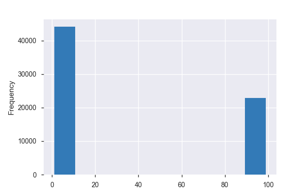

**Common Values**

| Value | Count | Frequency (%) |  |
| --- | --- | --- | --- |
| 99.0 | 22812 | 29.6% |  |
| 7.0 | 17249 | 22.4% |  |
| 4.0 | 9188 | 11.9% |  |
| 6.0 | 6590 | 8.5% |  |
| 5.0 | 4616 | 6.0% |  |
| 1.0 | 4177 | 5.4% |  |
| 3.0 | 1192 | 1.5% |  |
| 2.0 | 1100 | 1.4% |  |
| (Missing) | 10180 | 13.2% |  |

**Extreme Values**

Minimum 5 values

| Value | Count | Frequency (%) |  |
| --- | --- | --- | --- |
| 1.0 | 4177 | 5.4% |  |
| 2.0 | 1100 | 1.4% |  |
| 3.0 | 1192 | 1.5% |  |
| 4.0 | 9188 | 11.9% |  |
| 5.0 | 4616 | 6.0% |  |

Maximum 5 values

| Value | Count | Frequency (%) |  |
| --- | --- | --- | --- |
| 4.0 | 9188 | 11.9% |  |
| 5.0 | 4616 | 6.0% |  |
| 6.0 | 6590 | 8.5% |  |
| 7.0 | 17249 | 22.4% |  |
| 99.0 | 22812 | 29.6% |  |

v121_3  
Numeric

| Distinct count | 9 |
| --- | --- |
| Unique (%) | 0.0% |
| Missing (%) | 13.2% |
| Missing (n) | 10180 |
| Infinite (%) | 0.0% |
| Infinite (n) | 0 |

| Mean | 35.766 |
| --- | --- |
| Minimum | 1 |
| Maximum | 99 |
| Zeros (%) | 0.0% |

Toggle details

**Statistics**

Quantile statistics

| Minimum | 1 |
| --- | --- |
| 5-th percentile | 1 |
| Q1 | 2 |
| Median | 5 |
| Q3 | 99 |
| 95-th percentile | 99 |
| Maximum | 99 |
| Range | 98 |
| Interquartile range | 97 |

Descriptive statistics

| Standard deviation | 45.278 |
| --- | --- |
| Coef of variation | 1.266 |
| Kurtosis | -1.5347 |
| Mean | 35.766 |
| MAD | 42.823 |
| Skewness | 0.67753 |
| Sum | 2393600 |
| Variance | 2050.1 |
| Memory size | 602.5 KiB |

**Histogram**

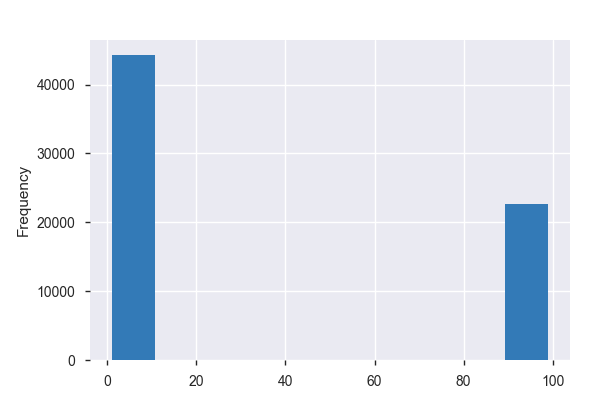

**Common Values**

| Value | Count | Frequency (%) |  |
| --- | --- | --- | --- |
| 99.0 | 22661 | 29.4% |  |
| 1.0 | 14196 | 18.4% |  |
| 4.0 | 10951 | 14.2% |  |
| 7.0 | 6049 | 7.8% |  |
| 2.0 | 3808 | 4.9% |  |
| 3.0 | 3412 | 4.4% |  |
| 5.0 | 3137 | 4.1% |  |
| 6.0 | 2710 | 3.5% |  |
| (Missing) | 10180 | 13.2% |  |

**Extreme Values**

Minimum 5 values

| Value | Count | Frequency (%) |  |
| --- | --- | --- | --- |
| 1.0 | 14196 | 18.4% |  |
| 2.0 | 3808 | 4.9% |  |
| 3.0 | 3412 | 4.4% |  |
| 4.0 | 10951 | 14.2% |  |
| 5.0 | 3137 | 4.1% |  |

Maximum 5 values

| Value | Count | Frequency (%) |  |
| --- | --- | --- | --- |
| 4.0 | 10951 | 14.2% |  |
| 5.0 | 3137 | 4.1% |  |
| 6.0 | 2710 | 3.5% |  |
| 7.0 | 6049 | 7.8% |  |
| 99.0 | 22661 | 29.4% |  |

v121_4  
Numeric

| Distinct count | 9 |
| --- | --- |
| Unique (%) | 0.0% |
| Missing (%) | 13.2% |
| Missing (n) | 10180 |
| Infinite (%) | 0.0% |
| Infinite (n) | 0 |

| Mean | 31.777 |
| --- | --- |
| Minimum | 1 |
| Maximum | 99 |
| Zeros (%) | 0.0% |

Toggle details

**Statistics**

Quantile statistics

| Minimum | 1 |
| --- | --- |
| 5-th percentile | 3 |
| Q1 | 5 |
| Median | 7 |
| Q3 | 99 |
| 95-th percentile | 99 |
| Maximum | 99 |
| Range | 98 |
| Interquartile range | 94 |

Descriptive statistics

| Standard deviation | 41.92 |
| --- | --- |
| Coef of variation | 1.3192 |
| Kurtosis | -1.0388 |
| Mean | 31.777 |
| MAD | 37.615 |
| Skewness | 0.97765 |
| Sum | 2126700 |
| Variance | 1757.3 |
| Memory size | 602.5 KiB |

**Histogram**

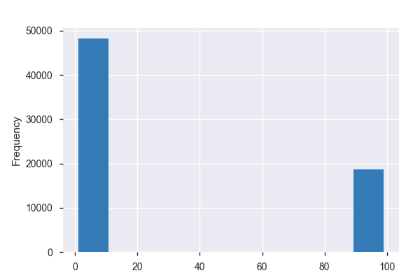

**Common Values**

| Value | Count | Frequency (%) |  |
| --- | --- | --- | --- |
| 7.0 | 21966 | 28.5% |  |
| 99.0 | 18724 | 24.3% |  |
| 4.0 | 9133 | 11.8% |  |
| 6.0 | 8371 | 10.9% |  |
| 5.0 | 5290 | 6.9% |  |
| 1.0 | 1845 | 2.4% |  |
| 3.0 | 990 | 1.3% |  |
| 2.0 | 605 | 0.8% |  |
| (Missing) | 10180 | 13.2% |  |

**Extreme Values**

Minimum 5 values

| Value | Count | Frequency (%) |  |
| --- | --- | --- | --- |
| 1.0 | 1845 | 2.4% |  |
| 2.0 | 605 | 0.8% |  |
| 3.0 | 990 | 1.3% |  |
| 4.0 | 9133 | 11.8% |  |
| 5.0 | 5290 | 6.9% |  |

Maximum 5 values

| Value | Count | Frequency (%) |  |
| --- | --- | --- | --- |
| 4.0 | 9133 | 11.8% |  |
| 5.0 | 5290 | 6.9% |  |
| 6.0 | 8371 | 10.9% |  |
| 7.0 | 21966 | 28.5% |  |
| 99.0 | 18724 | 24.3% |  |

v121_5  
Numeric

| Distinct count | 9 |
| --- | --- |
| Unique (%) | 0.0% |
| Missing (%) | 13.2% |
| Missing (n) | 10180 |
| Infinite (%) | 0.0% |
| Infinite (n) | 0 |

| Mean | 40.169 |
| --- | --- |
| Minimum | 1 |
| Maximum | 99 |
| Zeros (%) | 0.0% |

Toggle details

**Statistics**

Quantile statistics

| Minimum | 1 |
| --- | --- |
| 5-th percentile | 1 |
| Q1 | 3 |
| Median | 6 |
| Q3 | 99 |
| 95-th percentile | 99 |
| Maximum | 99 |
| Range | 98 |
| Interquartile range | 96 |

Descriptive statistics

| Standard deviation | 46.335 |
| --- | --- |
| Coef of variation | 1.1535 |
| Kurtosis | -1.7645 |
| Mean | 40.169 |
| MAD | 45.005 |
| Skewness | 0.47923 |
| Sum | 2688300 |
| Variance | 2146.9 |
| Memory size | 602.5 KiB |

**Histogram**

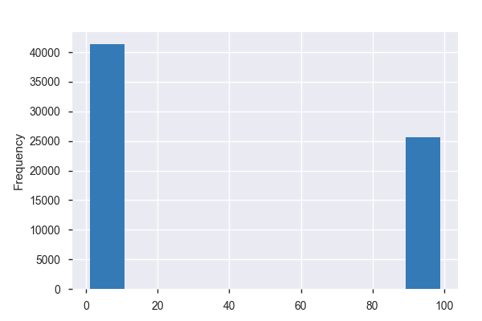

**Common Values**

| Value | Count | Frequency (%) |  |
| --- | --- | --- | --- |
| 99.0 | 25598 | 33.2% |  |
| 1.0 | 12358 | 16.0% |  |
| 4.0 | 9365 | 12.1% |  |
| 7.0 | 6963 | 9.0% |  |
| 6.0 | 4072 | 5.3% |  |
| 5.0 | 3891 | 5.0% |  |
| 2.0 | 2419 | 3.1% |  |
| 3.0 | 2258 | 2.9% |  |
| (Missing) | 10180 | 13.2% |  |

**Extreme Values**

Minimum 5 values

| Value | Count | Frequency (%) |  |
| --- | --- | --- | --- |
| 1.0 | 12358 | 16.0% |  |
| 2.0 | 2419 | 3.1% |  |
| 3.0 | 2258 | 2.9% |  |
| 4.0 | 9365 | 12.1% |  |
| 5.0 | 3891 | 5.0% |  |

Maximum 5 values

| Value | Count | Frequency (%) |  |
| --- | --- | --- | --- |
| 4.0 | 9365 | 12.1% |  |
| 5.0 | 3891 | 5.0% |  |
| 6.0 | 4072 | 5.3% |  |
| 7.0 | 6963 | 9.0% |  |
| 99.0 | 25598 | 33.2% |  |

v121_6  
Numeric

| Distinct count | 9 |
| --- | --- |
| Unique (%) | 0.0% |
| Missing (%) | 13.2% |
| Missing (n) | 10180 |
| Infinite (%) | 0.0% |
| Infinite (n) | 0 |

| Mean | 38.468 |
| --- | --- |
| Minimum | 1 |
| Maximum | 99 |
| Zeros (%) | 0.0% |

Toggle details

**Statistics**

Quantile statistics

| Minimum | 1 |
| --- | --- |
| 5-th percentile | 1 |
| Q1 | 4 |
| Median | 7 |
| Q3 | 99 |
| 95-th percentile | 99 |
| Maximum | 99 |
| Range | 98 |
| Interquartile range | 95 |

Descriptive statistics

| Standard deviation | 45.425 |
| --- | --- |
| Coef of variation | 1.1809 |
| Kurtosis | -1.6584 |
| Mean | 38.468 |
| MAD | 43.576 |
| Skewness | 0.57922 |
| Sum | 2574400 |
| Variance | 2063.5 |
| Memory size | 602.5 KiB |

**Histogram**

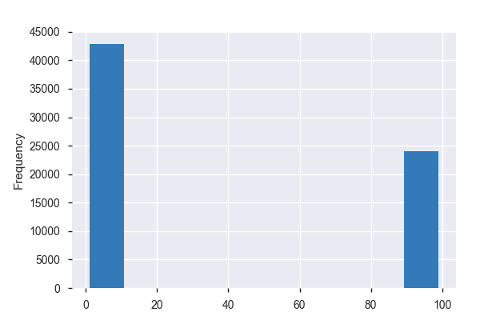

**Common Values**

| Value | Count | Frequency (%) |  |
| --- | --- | --- | --- |
| 99.0 | 24089 | 31.2% |  |
| 7.0 | 10365 | 13.4% |  |
| 4.0 | 10259 | 13.3% |  |
| 1.0 | 7734 | 10.0% |  |
| 6.0 | 5706 | 7.4% |  |
| 5.0 | 4813 | 6.2% |  |
| 3.0 | 2094 | 2.7% |  |
| 2.0 | 1864 | 2.4% |  |
| (Missing) | 10180 | 13.2% |  |

**Extreme Values**

Minimum 5 values

| Value | Count | Frequency (%) |  |
| --- | --- | --- | --- |
| 1.0 | 7734 | 10.0% |  |
| 2.0 | 1864 | 2.4% |  |
| 3.0 | 2094 | 2.7% |  |
| 4.0 | 10259 | 13.3% |  |
| 5.0 | 4813 | 6.2% |  |

Maximum 5 values

| Value | Count | Frequency (%) |  |
| --- | --- | --- | --- |
| 4.0 | 10259 | 13.3% |  |
| 5.0 | 4813 | 6.2% |  |
| 6.0 | 5706 | 7.4% |  |
| 7.0 | 10365 | 13.4% |  |
| 99.0 | 24089 | 31.2% |  |

v121_7  
Numeric

| Distinct count | 9 |
| --- | --- |
| Unique (%) | 0.0% |
| Missing (%) | 13.2% |
| Missing (n) | 10180 |
| Infinite (%) | 0.0% |
| Infinite (n) | 0 |

| Mean | 32.884 |
| --- | --- |
| Minimum | 1 |
| Maximum | 99 |
| Zeros (%) | 0.0% |

Toggle details

**Statistics**

Quantile statistics

| Minimum | 1 |
| --- | --- |
| 5-th percentile | 1 |
| Q1 | 4 |
| Median | 6 |
| Q3 | 99 |
| 95-th percentile | 99 |
| Maximum | 99 |
| Range | 98 |
| Interquartile range | 95 |

Descriptive statistics

| Standard deviation | 43.728 |
| --- | --- |
| Coef of variation | 1.3298 |
| Kurtosis | -1.2747 |
| Mean | 32.884 |
| MAD | 40.193 |
| Skewness | 0.84701 |
| Sum | 2200700 |
| Variance | 1912.2 |
| Memory size | 602.5 KiB |

**Histogram**

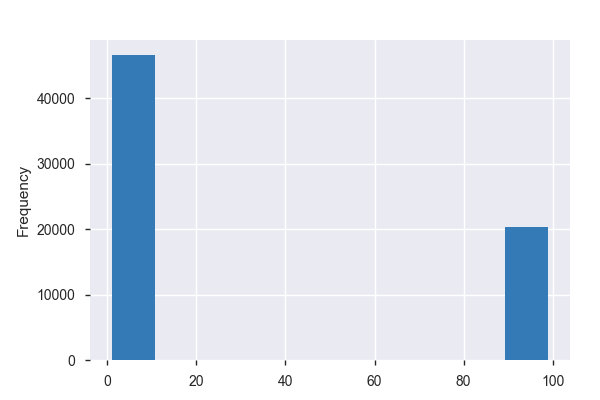

**Common Values**

| Value | Count | Frequency (%) |  |
| --- | --- | --- | --- |
| 99.0 | 20342 | 26.4% |  |
| 4.0 | 12817 | 16.6% |  |
| 1.0 | 10294 | 13.4% |  |
| 7.0 | 9511 | 12.3% |  |
| 6.0 | 4077 | 5.3% |  |
| 5.0 | 3803 | 4.9% |  |
| 3.0 | 3068 | 4.0% |  |
| 2.0 | 3012 | 3.9% |  |
| (Missing) | 10180 | 13.2% |  |

**Extreme Values**

Minimum 5 values

| Value | Count | Frequency (%) |  |
| --- | --- | --- | --- |
| 1.0 | 10294 | 13.4% |  |
| 2.0 | 3012 | 3.9% |  |
| 3.0 | 3068 | 4.0% |  |
| 4.0 | 12817 | 16.6% |  |
| 5.0 | 3803 | 4.9% |  |

Maximum 5 values

| Value | Count | Frequency (%) |  |
| --- | --- | --- | --- |
| 4.0 | 12817 | 16.6% |  |
| 5.0 | 3803 | 4.9% |  |
| 6.0 | 4077 | 5.3% |  |
| 7.0 | 9511 | 12.3% |  |
| 99.0 | 20342 | 26.4% |  |

v121_8  
Highly correlated

*This variable is highly correlated with `v121_6` and should be ignored for analysis*

| Correlation | 0.9027 |
| --- | --- |

v121_9  
Highly correlated

*This variable is highly correlated with `v121_8` and should be ignored for analysis*

| Correlation | 0.91715 |
| --- | --- |

v122_1  
Categorical

| Distinct count | 6 |
| --- | --- |
| Unique (%) | 0.0% |
| Missing (%) | 4.5% |
| Missing (n) | 3478 |

| nooit | 42968 |
| --- | --- |
| zelden | 11367 |
| soms | 10164 |
| Other values (2) | 9127 |

Toggle details

| Value | Count | Frequency (%) |  |
| --- | --- | --- | --- |
| nooit | 42968 | 55.7% |  |
| zelden | 11367 | 14.7% |  |
| soms | 10164 | 13.2% |  |
| 99 | 6369 | 8.3% |  |
| vaak | 2758 | 3.6% |  |
| (Missing) | 3478 | 4.5% |  |

v122_2  
Categorical

| Distinct count | 6 |
| --- | --- |
| Unique (%) | 0.0% |
| Missing (%) | 4.5% |
| Missing (n) | 3478 |

| nooit | 58972 |
| --- | --- |
| 99 | 6380 |
| zelden | 4891 |
| Other values (2) | 3383 |
| (Missing) | 3478 |

Toggle details

| Value | Count | Frequency (%) |  |
| --- | --- | --- | --- |
| nooit | 58972 | 76.5% |  |
| 99 | 6380 | 8.3% |  |
| zelden | 4891 | 6.3% |  |
| soms | 2454 | 3.2% |  |
| vaak | 929 | 1.2% |  |
| (Missing) | 3478 | 4.5% |  |

v122_3  
Categorical

| Distinct count | 6 |
| --- | --- |
| Unique (%) | 0.0% |
| Missing (%) | 4.5% |
| Missing (n) | 3478 |

| soms | 24402 |
| --- | --- |
| zelden | 16627 |
| nooit | 14907 |
| Other values (2) | 17690 |

Toggle details

| Value | Count | Frequency (%) |  |
| --- | --- | --- | --- |
| soms | 24402 | 31.6% |  |
| zelden | 16627 | 21.6% |  |
| nooit | 14907 | 19.3% |  |
| vaak | 11355 | 14.7% |  |
| 99 | 6335 | 8.2% |  |
| (Missing) | 3478 | 4.5% |  |

v122_4  
Categorical

| Distinct count | 6 |
| --- | --- |
| Unique (%) | 0.0% |
| Missing (%) | 4.5% |
| Missing (n) | 3478 |

| nooit | 39015 |
| --- | --- |
| zelden | 13545 |
| soms | 9501 |
| Other values (2) | 11565 |

Toggle details

| Value | Count | Frequency (%) |  |
| --- | --- | --- | --- |
| nooit | 39015 | 50.6% |  |
| zelden | 13545 | 17.6% |  |
| soms | 9501 | 12.3% |  |
| 99 | 6372 | 8.3% |  |
| vaak | 5193 | 6.7% |  |
| (Missing) | 3478 | 4.5% |  |

v122_5  
Categorical

| Distinct count | 6 |
| --- | --- |
| Unique (%) | 0.0% |
| Missing (%) | 4.5% |
| Missing (n) | 3478 |

| nooit | 42610 |
| --- | --- |
| zelden | 15206 |
| soms | 7433 |
| Other values (2) | 8377 |

Toggle details

| Value | Count | Frequency (%) |  |
| --- | --- | --- | --- |
| nooit | 42610 | 55.3% |  |
| zelden | 15206 | 19.7% |  |
| soms | 7433 | 9.6% |  |
| 99 | 6376 | 8.3% |  |
| vaak | 2001 | 2.6% |  |
| (Missing) | 3478 | 4.5% |  |

v122_6  
Categorical

| Distinct count | 6 |
| --- | --- |
| Unique (%) | 0.0% |
| Missing (%) | 4.5% |
| Missing (n) | 3478 |

| nooit | 47496 |
| --- | --- |
| zelden | 11267 |
| 99 | 6381 |
| Other values (2) | 8482 |

Toggle details

| Value | Count | Frequency (%) |  |
| --- | --- | --- | --- |
| nooit | 47496 | 61.6% |  |
| zelden | 11267 | 14.6% |  |
| 99 | 6381 | 8.3% |  |
| soms | 6043 | 7.8% |  |
| vaak | 2439 | 3.2% |  |
| (Missing) | 3478 | 4.5% |  |

v123  
Categorical

| Distinct count | 7 |
| --- | --- |
| Unique (%) | 0.0% |
| Missing (%) | 4.5% |
| Missing (n) | 3478 |

| meer dan 1 maal per week | 42220 |
| --- | --- |
| nooit | 10902 |
| ongeveer wekelijks | 7407 |
| Other values (3) | 13097 |

Toggle details

| Value | Count | Frequency (%) |  |
| --- | --- | --- | --- |
| meer dan 1 maal per week | 42220 | 54.8% |  |
| nooit | 10902 | 14.1% |  |
| ongeveer wekelijks | 7407 | 9.6% |  |
| zelden | 7169 | 9.3% |  |
| 99 | 3187 | 4.1% |  |
| ongeveer maandelijks | 2741 | 3.6% |  |
| (Missing) | 3478 | 4.5% |  |

v124  
Categorical

| Distinct count | 7 |
| --- | --- |
| Unique (%) | 0.0% |
| Missing (%) | 4.5% |
| Missing (n) | 3478 |

| nooit | 50958 |
| --- | --- |
| meer dan 1 maal per week | 12430 |
| 99 | 3242 |
| Other values (3) | 6996 |
| (Missing) | 3478 |

Toggle details

| Value | Count | Frequency (%) |  |
| --- | --- | --- | --- |
| nooit | 50958 | 66.1% |  |
| meer dan 1 maal per week | 12430 | 16.1% |  |
| 99 | 3242 | 4.2% |  |
| zelden | 2970 | 3.9% |  |
| ongeveer wekelijks | 2745 | 3.6% |  |
| ongeveer maandelijks | 1281 | 1.7% |  |
| (Missing) | 3478 | 4.5% |  |

v125  
Categorical

| Distinct count | 6 |
| --- | --- |
| Unique (%) | 0.0% |
| Missing (%) | 4.5% |
| Missing (n) | 3505 |

| lid | 52178 |
| --- | --- |
| nooit lid geweest | 13479 |
| 99 | 5389 |
| Other values (2) | 2553 |
| (Missing) | 3505 |

Toggle details

| Value | Count | Frequency (%) |  |
| --- | --- | --- | --- |
| lid | 52178 | 67.7% |  |
| nooit lid geweest | 13479 | 17.5% |  |
| 99 | 5389 | 7.0% |  |
| bestuurslild | 1289 | 1.7% |  |
| vroeger lid geweest | 1264 | 1.6% |  |
| (Missing) | 3505 | 4.5% |  |

v126  
Categorical

| Distinct count | 6 |
| --- | --- |
| Unique (%) | 0.0% |
| Missing (%) | 4.5% |
| Missing (n) | 3505 |

| nooit lid geweest | 67519 |
| --- | --- |
| 99 | 5493 |
| vroeger lid geweest | 273 |
| Other values (2) | 314 |
| (Missing) | 3505 |

Toggle details

| Value | Count | Frequency (%) |  |
| --- | --- | --- | --- |
| nooit lid geweest | 67519 | 87.6% |  |
| 99 | 5493 | 7.1% |  |
| vroeger lid geweest | 273 | 0.4% |  |
| lid | 260 | 0.3% |  |
| bestuurslild | 54 | 0.1% |  |
| (Missing) | 3505 | 4.5% |  |

v127  
Categorical

| Distinct count | 4 |
| --- | --- |
| Unique (%) | 0.0% |
| Missing (%) | 13.2% |
| Missing (n) | 10171 |

| ja | 41833 |
| --- | --- |
| neen | 20181 |
| 99 | 4919 |
| (Missing) | 10171 |

Toggle details

| Value | Count | Frequency (%) |  |
| --- | --- | --- | --- |
| ja | 41833 | 54.3% |  |
| neen | 20181 | 26.2% |  |
| 99 | 4919 | 6.4% |  |
| (Missing) | 10171 | 13.2% |  |

v128_1  
Categorical

| Distinct count | 8 |
| --- | --- |
| Unique (%) | 0.0% |
| Missing (%) | 4.5% |
| Missing (n) | 3469 |

| niet van toepassing | 45169 |
| --- | --- |
| 99 | 6396 |
| helemaal niet belangrijk | 6028 |
| Other values (4) | 16042 |

Toggle details

| Value | Count | Frequency (%) |  |
| --- | --- | --- | --- |
| niet van toepassing | 45169 | 58.6% |  |
| 99 | 6396 | 8.3% |  |
| helemaal niet belangrijk | 6028 | 7.8% |  |
| noch onbelangrijk, noch belangrijk | 5536 | 7.2% |  |
| eerder belangrijk | 5323 | 6.9% |  |
| heel belangrijk | 3238 | 4.2% |  |
| eerder onbelangrijk | 1945 | 2.5% |  |
| (Missing) | 3469 | 4.5% |  |

v128_2  
Categorical

| Distinct count | 8 |
| --- | --- |
| Unique (%) | 0.0% |
| Missing (%) | 4.5% |
| Missing (n) | 3469 |

| niet van toepassing | 45169 |
| --- | --- |
| helemaal niet belangrijk | 8458 |
| 99 | 6481 |
| Other values (4) | 13527 |

Toggle details

| Value | Count | Frequency (%) |  |
| --- | --- | --- | --- |
| niet van toepassing | 45169 | 58.6% |  |
| helemaal niet belangrijk | 8458 | 11.0% |  |
| 99 | 6481 | 8.4% |  |
| noch onbelangrijk, noch belangrijk | 5456 | 7.1% |  |
| eerder belangrijk | 3837 | 5.0% |  |
| eerder onbelangrijk | 2154 | 2.8% |  |
| heel belangrijk | 2080 | 2.7% |  |
| (Missing) | 3469 | 4.5% |  |

v128_3  
Categorical

| Distinct count | 8 |
| --- | --- |
| Unique (%) | 0.0% |
| Missing (%) | 4.5% |
| Missing (n) | 3469 |

| niet van toepassing | 45169 |
| --- | --- |
| helemaal niet belangrijk | 6507 |
| 99 | 6361 |
| Other values (4) | 15598 |

Toggle details

| Value | Count | Frequency (%) |  |
| --- | --- | --- | --- |
| niet van toepassing | 45169 | 58.6% |  |
| helemaal niet belangrijk | 6507 | 8.4% |  |
| 99 | 6361 | 8.2% |  |
| eerder belangrijk | 6119 | 7.9% |  |
| noch onbelangrijk, noch belangrijk | 4845 | 6.3% |  |
| heel belangrijk | 3194 | 4.1% |  |
| eerder onbelangrijk | 1440 | 1.9% |  |
| (Missing) | 3469 | 4.5% |  |

v129  
Categorical

| Distinct count | 11 |
| --- | --- |
| Unique (%) | 0.0% |
| Missing (%) | 13.2% |
| Missing (n) | 10171 |

| niet van toepassing | 45166 |
| --- | --- |
| enkele keren per jaar | 5625 |
| 99 | 4406 |
| Other values (7) | 11736 |
| (Missing) | 10171 |

Toggle details

| Value | Count | Frequency (%) |  |
| --- | --- | --- | --- |
| niet van toepassing | 45166 | 58.6% |  |
| enkele keren per jaar | 5625 | 7.3% |  |
| 99 | 4406 | 5.7% |  |
| elke maand | 3647 | 4.7% |  |
| een paar keer per maand | 2829 | 3.7% |  |
| elke week | 1921 | 2.5% |  |
| nooit | 1470 | 1.9% |  |
| bijna nooit | 1270 | 1.6% |  |
| enkele keren per week | 555 | 0.7% |  |
| elke dag | 44 | 0.1% |  |
| (Missing) | 10171 | 13.2% |  |

v13  
Numeric

| Distinct count | 108 |
| --- | --- |
| Unique (%) | 0.1% |
| Missing (%) | 0.0% |
| Missing (n) | 4 |
| Infinite (%) | 0.0% |
| Infinite (n) | 0 |

| Mean | 86.929 |
| --- | --- |
| Minimum | 0 |
| Maximum | 999 |
| Zeros (%) | 0.1% |

Toggle details

**Statistics**

Quantile statistics

| Minimum | 0 |
| --- | --- |
| 5-th percentile | 8 |
| Q1 | 35 |
| Median | 51 |
| Q3 | 69 |
| 95-th percentile | 89 |
| Maximum | 999 |
| Range | 999 |
| Interquartile range | 34 |

Descriptive statistics

| Standard deviation | 186.78 |
| --- | --- |
| Coef of variation | 2.1487 |
| Kurtosis | 19.587 |
| Mean | 86.929 |
| MAD | 72.626 |
| Skewness | 4.6074 |
| Sum | 6702200 |
| Variance | 34888 |
| Memory size | 602.5 KiB |

**Histogram**

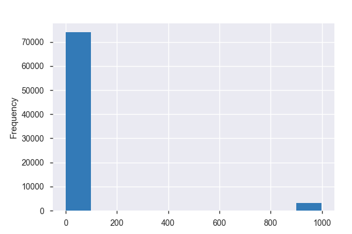

**Common Values**

| Value | Count | Frequency (%) |  |
| --- | --- | --- | --- |
| 999.0 | 3062 | 4.0% |  |
| 40.0 | 2313 | 3.0% |  |
| 60.0 | 2093 | 2.7% |  |
| 50.0 | 1769 | 2.3% |  |
| 45.0 | 1519 | 2.0% |  |
| 35.0 | 1469 | 1.9% |  |
| 70.0 | 1468 | 1.9% |  |
| 62.0 | 1431 | 1.9% |  |
| 65.0 | 1387 | 1.8% |  |
| 30.0 | 1370 | 1.8% |  |
| Other values (97) | 59219 | 76.8% |  |

**Extreme Values**

Minimum 5 values

| Value | Count | Frequency (%) |  |
| --- | --- | --- | --- |
| 0.0 | 89 | 0.1% |  |
| 1.0 | 555 | 0.7% |  |
| 2.0 | 586 | 0.8% |  |
| 3.0 | 572 | 0.7% |  |
| 4.0 | 522 | 0.7% |  |

Maximum 5 values

| Value | Count | Frequency (%) |  |
| --- | --- | --- | --- |
| 102.0 | 2 | 0.0% |  |
| 104.0 | 1 | 0.0% |  |
| 107.0 | 1 | 0.0% |  |
| 118.0 | 1 | 0.0% |  |
| 999.0 | 3062 | 4.0% |  |

v130_1  
Categorical

| Distinct count | 6 |
| --- | --- |
| Unique (%) | 0.0% |
| Missing (%) | 13.2% |
| Missing (n) | 10179 |

| niet van toepassing | 45166 |
| --- | --- |
| nooit | 7713 |
| altijd/regelmatig | 6477 |
| Other values (2) | 7569 |
| (Missing) | 10179 |

Toggle details

| Value | Count | Frequency (%) |  |
| --- | --- | --- | --- |
| niet van toepassing | 45166 | 58.6% |  |
| nooit | 7713 | 10.0% |  |
| altijd/regelmatig | 6477 | 8.4% |  |
| 99 | 4145 | 5.4% |  |
| soms | 3424 | 4.4% |  |
| (Missing) | 10179 | 13.2% |  |

v130_10  
Categorical

| Distinct count | 6 |
| --- | --- |
| Unique (%) | 0.0% |
| Missing (%) | 13.2% |
| Missing (n) | 10179 |

| niet van toepassing | 45166 |
| --- | --- |
| nooit | 9971 |
| soms | 6009 |
| Other values (2) | 5779 |
| (Missing) | 10179 |

Toggle details

| Value | Count | Frequency (%) |  |
| --- | --- | --- | --- |
| niet van toepassing | 45166 | 58.6% |  |
| nooit | 9971 | 12.9% |  |
| soms | 6009 | 7.8% |  |
| 99 | 4162 | 5.4% |  |
| altijd/regelmatig | 1617 | 2.1% |  |
| (Missing) | 10179 | 13.2% |  |

v130_11  
Categorical

| Distinct count | 6 |
| --- | --- |
| Unique (%) | 0.0% |
| Missing (%) | 13.2% |
| Missing (n) | 10179 |

| niet van toepassing | 45166 |
| --- | --- |
| nooit | 10108 |
| soms | 6034 |
| Other values (2) | 5617 |
| (Missing) | 10179 |

Toggle details

| Value | Count | Frequency (%) |  |
| --- | --- | --- | --- |
| niet van toepassing | 45166 | 58.6% |  |
| nooit | 10108 | 13.1% |  |
| soms | 6034 | 7.8% |  |
| 99 | 4168 | 5.4% |  |
| altijd/regelmatig | 1449 | 1.9% |  |
| (Missing) | 10179 | 13.2% |  |

v130_12  
Categorical

| Distinct count | 6 |
| --- | --- |
| Unique (%) | 0.0% |
| Missing (%) | 13.2% |
| Missing (n) | 10179 |

| niet van toepassing | 45166 |
| --- | --- |
| nooit | 12471 |
| 99 | 4165 |
| Other values (2) | 5123 |
| (Missing) | 10179 |

Toggle details

| Value | Count | Frequency (%) |  |
| --- | --- | --- | --- |
| niet van toepassing | 45166 | 58.6% |  |
| nooit | 12471 | 16.2% |  |
| 99 | 4165 | 5.4% |  |
| soms | 2961 | 3.8% |  |
| altijd/regelmatig | 2162 | 2.8% |  |
| (Missing) | 10179 | 13.2% |  |

v130_13  
Categorical

| Distinct count | 6 |
| --- | --- |
| Unique (%) | 0.0% |
| Missing (%) | 13.2% |
| Missing (n) | 10179 |

| niet van toepassing | 45166 |
| --- | --- |
| nooit | 14425 |
| 99 | 4165 |
| Other values (2) | 3169 |
| (Missing) | 10179 |

Toggle details

| Value | Count | Frequency (%) |  |
| --- | --- | --- | --- |
| niet van toepassing | 45166 | 58.6% |  |
| nooit | 14425 | 18.7% |  |
| 99 | 4165 | 5.4% |  |
| soms | 2174 | 2.8% |  |
| altijd/regelmatig | 995 | 1.3% |  |
| (Missing) | 10179 | 13.2% |  |

v130_14  
Categorical

| Distinct count | 6 |
| --- | --- |
| Unique (%) | 0.0% |
| Missing (%) | 13.2% |
| Missing (n) | 10179 |

| niet van toepassing | 45166 |
| --- | --- |
| nooit | 14167 |
| 99 | 4165 |
| Other values (2) | 3427 |
| (Missing) | 10179 |

Toggle details

| Value | Count | Frequency (%) |  |
| --- | --- | --- | --- |
| niet van toepassing | 45166 | 58.6% |  |
| nooit | 14167 | 18.4% |  |
| 99 | 4165 | 5.4% |  |
| soms | 2368 | 3.1% |  |
| altijd/regelmatig | 1059 | 1.4% |  |
| (Missing) | 10179 | 13.2% |  |

v130_15  
Categorical

| Distinct count | 6 |
| --- | --- |
| Unique (%) | 0.0% |
| Missing (%) | 13.2% |
| Missing (n) | 10179 |

| niet van toepassing | 45166 |
| --- | --- |
| nooit | 15446 |
| 99 | 4173 |
| Other values (2) | 2140 |
| (Missing) | 10179 |

Toggle details

| Value | Count | Frequency (%) |  |
| --- | --- | --- | --- |
| niet van toepassing | 45166 | 58.6% |  |
| nooit | 15446 | 20.0% |  |
| 99 | 4173 | 5.4% |  |
| soms | 1554 | 2.0% |  |
| altijd/regelmatig | 586 | 0.8% |  |
| (Missing) | 10179 | 13.2% |  |

v130_16  
Categorical

| Distinct count | 6 |
| --- | --- |
| Unique (%) | 0.0% |
| Missing (%) | 13.2% |
| Missing (n) | 10179 |

| niet van toepassing | 45166 |
| --- | --- |
| soms | 7634 |
| nooit | 6017 |
| Other values (2) | 8108 |
| (Missing) | 10179 |

Toggle details

| Value | Count | Frequency (%) |  |
| --- | --- | --- | --- |
| niet van toepassing | 45166 | 58.6% |  |
| soms | 7634 | 9.9% |  |
| nooit | 6017 | 7.8% |  |
| 99 | 4132 | 5.4% |  |
| altijd/regelmatig | 3976 | 5.2% |  |
| (Missing) | 10179 | 13.2% |  |

v130_17  
Categorical

| Distinct count | 6 |
| --- | --- |
| Unique (%) | 0.0% |
| Missing (%) | 13.2% |
| Missing (n) | 10179 |

| niet van toepassing | 45166 |
| --- | --- |
| nooit | 12218 |
| soms | 4207 |
| Other values (2) | 5334 |
| (Missing) | 10179 |

Toggle details

| Value | Count | Frequency (%) |  |
| --- | --- | --- | --- |
| niet van toepassing | 45166 | 58.6% |  |
| nooit | 12218 | 15.8% |  |
| soms | 4207 | 5.5% |  |
| 99 | 4173 | 5.4% |  |
| altijd/regelmatig | 1161 | 1.5% |  |
| (Missing) | 10179 | 13.2% |  |

v130_18  
Categorical

| Distinct count | 6 |
| --- | --- |
| Unique (%) | 0.0% |
| Missing (%) | 13.2% |
| Missing (n) | 10179 |

| niet van toepassing | 45166 |
| --- | --- |
| nooit | 10648 |
| soms | 5524 |
| Other values (2) | 5587 |
| (Missing) | 10179 |

Toggle details

| Value | Count | Frequency (%) |  |
| --- | --- | --- | --- |
| niet van toepassing | 45166 | 58.6% |  |
| nooit | 10648 | 13.8% |  |
| soms | 5524 | 7.2% |  |
| 99 | 4162 | 5.4% |  |
| altijd/regelmatig | 1425 | 1.8% |  |
| (Missing) | 10179 | 13.2% |  |

v130_19  
Categorical

| Distinct count | 6 |
| --- | --- |
| Unique (%) | 0.0% |
| Missing (%) | 13.2% |
| Missing (n) | 10179 |

| niet van toepassing | 45166 |
| --- | --- |
| nooit | 10932 |
| soms | 4843 |
| Other values (2) | 5984 |
| (Missing) | 10179 |

Toggle details

| Value | Count | Frequency (%) |  |
| --- | --- | --- | --- |
| niet van toepassing | 45166 | 58.6% |  |
| nooit | 10932 | 14.2% |  |
| soms | 4843 | 6.3% |  |
| 99 | 4161 | 5.4% |  |
| altijd/regelmatig | 1823 | 2.4% |  |
| (Missing) | 10179 | 13.2% |  |

v130_2  
Categorical

| Distinct count | 6 |
| --- | --- |
| Unique (%) | 0.0% |
| Missing (%) | 13.2% |
| Missing (n) | 10179 |

| niet van toepassing | 45166 |
| --- | --- |
| nooit | 13243 |
| 99 | 4167 |
| Other values (2) | 4349 |
| (Missing) | 10179 |

Toggle details

| Value | Count | Frequency (%) |  |
| --- | --- | --- | --- |
| niet van toepassing | 45166 | 58.6% |  |
| nooit | 13243 | 17.2% |  |
| 99 | 4167 | 5.4% |  |
| altijd/regelmatig | 3443 | 4.5% |  |
| soms | 906 | 1.2% |  |
| (Missing) | 10179 | 13.2% |  |

v130_20  
Categorical

| Distinct count | 6 |
| --- | --- |
| Unique (%) | 0.0% |
| Missing (%) | 13.2% |
| Missing (n) | 10179 |

| niet van toepassing | 45166 |
| --- | --- |
| nooit | 11605 |
| 99 | 4161 |
| Other values (2) | 5993 |
| (Missing) | 10179 |

Toggle details

| Value | Count | Frequency (%) |  |
| --- | --- | --- | --- |
| niet van toepassing | 45166 | 58.6% |  |
| nooit | 11605 | 15.1% |  |
| 99 | 4161 | 5.4% |  |
| soms | 4123 | 5.3% |  |
| altijd/regelmatig | 1870 | 2.4% |  |
| (Missing) | 10179 | 13.2% |  |

v130_21  
Categorical

| Distinct count | 6 |
| --- | --- |
| Unique (%) | 0.0% |
| Missing (%) | 13.2% |
| Missing (n) | 10179 |

| niet van toepassing | 45166 |
| --- | --- |
| nooit | 10227 |
| altijd/regelmatig | 5175 |
| Other values (2) | 6357 |
| (Missing) | 10179 |

Toggle details

| Value | Count | Frequency (%) |  |
| --- | --- | --- | --- |
| niet van toepassing | 45166 | 58.6% |  |
| nooit | 10227 | 13.3% |  |
| altijd/regelmatig | 5175 | 6.7% |  |
| 99 | 4155 | 5.4% |  |
| soms | 2202 | 2.9% |  |
| (Missing) | 10179 | 13.2% |  |

v130_3  
Categorical

| Distinct count | 6 |
| --- | --- |
| Unique (%) | 0.0% |
| Missing (%) | 13.2% |
| Missing (n) | 10179 |

| niet van toepassing | 45166 |
| --- | --- |
| altijd/regelmatig | 8328 |
| soms | 5960 |
| Other values (2) | 7471 |
| (Missing) | 10179 |

Toggle details

| Value | Count | Frequency (%) |  |
| --- | --- | --- | --- |
| niet van toepassing | 45166 | 58.6% |  |
| altijd/regelmatig | 8328 | 10.8% |  |
| soms | 5960 | 7.7% |  |
| 99 | 4115 | 5.3% |  |
| nooit | 3356 | 4.4% |  |
| (Missing) | 10179 | 13.2% |  |

v130_4  
Categorical

| Distinct count | 6 |
| --- | --- |
| Unique (%) | 0.0% |
| Missing (%) | 13.2% |
| Missing (n) | 10179 |

| niet van toepassing | 45166 |
| --- | --- |
| nooit | 9201 |
| soms | 5052 |
| Other values (2) | 7506 |
| (Missing) | 10179 |

Toggle details

| Value | Count | Frequency (%) |  |
| --- | --- | --- | --- |
| niet van toepassing | 45166 | 58.6% |  |
| nooit | 9201 | 11.9% |  |
| soms | 5052 | 6.6% |  |
| 99 | 4158 | 5.4% |  |
| altijd/regelmatig | 3348 | 4.3% |  |
| (Missing) | 10179 | 13.2% |  |

v130_5  
Categorical

| Distinct count | 6 |
| --- | --- |
| Unique (%) | 0.0% |
| Missing (%) | 13.2% |
| Missing (n) | 10179 |

| niet van toepassing | 45166 |
| --- | --- |
| nooit | 11187 |
| 99 | 4165 |
| Other values (2) | 6407 |
| (Missing) | 10179 |

Toggle details

| Value | Count | Frequency (%) |  |
| --- | --- | --- | --- |
| niet van toepassing | 45166 | 58.6% |  |
| nooit | 11187 | 14.5% |  |
| 99 | 4165 | 5.4% |  |
| soms | 3965 | 5.1% |  |
| altijd/regelmatig | 2442 | 3.2% |  |
| (Missing) | 10179 | 13.2% |  |

v130_6  
Categorical

| Distinct count | 6 |
| --- | --- |
| Unique (%) | 0.0% |
| Missing (%) | 13.2% |
| Missing (n) | 10179 |

| niet van toepassing | 45166 |
| --- | --- |
| nooit | 15129 |
| 99 | 4170 |
| Other values (2) | 2460 |
| (Missing) | 10179 |

Toggle details

| Value | Count | Frequency (%) |  |
| --- | --- | --- | --- |
| niet van toepassing | 45166 | 58.6% |  |
| nooit | 15129 | 19.6% |  |
| 99 | 4170 | 5.4% |  |
| soms | 1706 | 2.2% |  |
| altijd/regelmatig | 754 | 1.0% |  |
| (Missing) | 10179 | 13.2% |  |

v130_7  
Categorical

| Distinct count | 6 |
| --- | --- |
| Unique (%) | 0.0% |
| Missing (%) | 13.2% |
| Missing (n) | 10179 |

| niet van toepassing | 45166 |
| --- | --- |
| nooit | 14534 |
| 99 | 4169 |
| Other values (2) | 3056 |
| (Missing) | 10179 |

Toggle details

| Value | Count | Frequency (%) |  |
| --- | --- | --- | --- |
| niet van toepassing | 45166 | 58.6% |  |
| nooit | 14534 | 18.8% |  |
| 99 | 4169 | 5.4% |  |
| soms | 2212 | 2.9% |  |
| altijd/regelmatig | 844 | 1.1% |  |
| (Missing) | 10179 | 13.2% |  |

v130_8  
Categorical

| Distinct count | 6 |
| --- | --- |
| Unique (%) | 0.0% |
| Missing (%) | 13.2% |
| Missing (n) | 10179 |

| niet van toepassing | 45166 |
| --- | --- |
| nooit | 13574 |
| 99 | 4157 |
| Other values (2) | 4028 |
| (Missing) | 10179 |

Toggle details

| Value | Count | Frequency (%) |  |
| --- | --- | --- | --- |
| niet van toepassing | 45166 | 58.6% |  |
| nooit | 13574 | 17.6% |  |
| 99 | 4157 | 5.4% |  |
| soms | 2288 | 3.0% |  |
| altijd/regelmatig | 1740 | 2.3% |  |
| (Missing) | 10179 | 13.2% |  |

v130_9  
Categorical

| Distinct count | 6 |
| --- | --- |
| Unique (%) | 0.0% |
| Missing (%) | 13.2% |
| Missing (n) | 10179 |

| niet van toepassing | 45166 |
| --- | --- |
| nooit | 15449 |
| 99 | 4173 |
| Other values (2) | 2137 |
| (Missing) | 10179 |

Toggle details

| Value | Count | Frequency (%) |  |
| --- | --- | --- | --- |
| niet van toepassing | 45166 | 58.6% |  |
| nooit | 15449 | 20.0% |  |
| 99 | 4173 | 5.4% |  |
| soms | 1778 | 2.3% |  |
| altijd/regelmatig | 359 | 0.5% |  |
| (Missing) | 10179 | 13.2% |  |

v131_1  
Categorical

| Distinct count | 26 |
| --- | --- |
| Unique (%) | 0.0% |
| Missing (%) | 13.2% |
| Missing (n) | 10180 |

| 99 | 30827 |
| --- | --- |
| niet van toepassing | 21072 |
| 99 | 3546 |
| Other values (22) | 11479 |
| (Missing) | 10180 |

Toggle details

| Value | Count | Frequency (%) |  |
| --- | --- | --- | --- |
| 99 | 30827 | 40.0% |  |
| niet van toepassing | 21072 | 27.3% |  |
| 99 | 3546 | 4.6% |  |
| 8 | 2105 | 2.7% |  |
| 10 | 1511 | 2.0% |  |
| 8 | 1305 | 1.7% |  |
| 7 | 1141 | 1.5% |  |
| 10 | 869 | 1.1% |  |
| 5 | 819 | 1.1% |  |
| 7 | 748 | 1.0% |  |
| Other values (15) | 2981 | 3.9% |  |
| (Missing) | 10180 | 13.2% |  |

v131_10  
Categorical

| Distinct count | 26 |
| --- | --- |
| Unique (%) | 0.0% |
| Missing (%) | 13.2% |
| Missing (n) | 10180 |

| 99 | 32554 |
| --- | --- |
| niet van toepassing | 21973 |
| 99 | 3767 |
| Other values (22) | 8630 |
| (Missing) | 10180 |

Toggle details

| Value | Count | Frequency (%) |  |
| --- | --- | --- | --- |
| 99 | 32554 | 42.2% |  |
| niet van toepassing | 21973 | 28.5% |  |
| 99 | 3767 | 4.9% |  |
| 8 | 1318 | 1.7% |  |
| 7 | 967 | 1.3% |  |
| 8 | 769 | 1.0% |  |
| 5 | 743 | 1.0% |  |
| 7 | 593 | 0.8% |  |
| 6 | 577 | 0.7% |  |
| 10 | 556 | 0.7% |  |
| Other values (15) | 3107 | 4.0% |  |
| (Missing) | 10180 | 13.2% |  |

v131_11  
Categorical

| Distinct count | 26 |
| --- | --- |
| Unique (%) | 0.0% |
| Missing (%) | 13.2% |
| Missing (n) | 10180 |

| 99 | 33027 |
| --- | --- |
| niet van toepassing | 22119 |
| 99 | 3758 |
| Other values (22) | 8020 |
| (Missing) | 10180 |

Toggle details

| Value | Count | Frequency (%) |  |
| --- | --- | --- | --- |
| 99 | 33027 | 42.8% |  |
| niet van toepassing | 22119 | 28.7% |  |
| 99 | 3758 | 4.9% |  |
| 8 | 1097 | 1.4% |  |
| 7 | 857 | 1.1% |  |
| 5 | 728 | 0.9% |  |
| 8 | 713 | 0.9% |  |
| 7 | 590 | 0.8% |  |
| 6 | 585 | 0.8% |  |
| 5 | 461 | 0.6% |  |
| Other values (15) | 2989 | 3.9% |  |
| (Missing) | 10180 | 13.2% |  |

v131_12  
Categorical

| Distinct count | 26 |
| --- | --- |
| Unique (%) | 0.0% |
| Missing (%) | 13.2% |
| Missing (n) | 10180 |

| 99 | 33247 |
| --- | --- |
| niet van toepassing | 22322 |
| 99 | 3832 |
| Other values (22) | 7523 |
| (Missing) | 10180 |

Toggle details

| Value | Count | Frequency (%) |  |
| --- | --- | --- | --- |
| 99 | 33247 | 43.1% |  |
| niet van toepassing | 22322 | 29.0% |  |
| 99 | 3832 | 5.0% |  |
| 8 | 968 | 1.3% |  |
| 7 | 711 | 0.9% |  |
| 10 | 642 | 0.8% |  |
| 5 | 624 | 0.8% |  |
| 8 | 619 | 0.8% |  |
| 6 | 515 | 0.7% |  |
| 7 | 435 | 0.6% |  |
| Other values (15) | 3009 | 3.9% |  |
| (Missing) | 10180 | 13.2% |  |

v131_13  
Categorical

| Distinct count | 26 |
| --- | --- |
| Unique (%) | 0.0% |
| Missing (%) | 13.2% |
| Missing (n) | 10180 |

| 99 | 33788 |
| --- | --- |
| niet van toepassing | 22558 |
| 99 | 3865 |
| Other values (22) | 6713 |
| (Missing) | 10180 |

Toggle details

| Value | Count | Frequency (%) |  |
| --- | --- | --- | --- |
| 99 | 33788 | 43.8% |  |
| niet van toepassing | 22558 | 29.3% |  |
| 99 | 3865 | 5.0% |  |
| 8 | 807 | 1.0% |  |
| 7 | 644 | 0.8% |  |
| 5 | 621 | 0.8% |  |
| 10 | 464 | 0.6% |  |
| 6 | 461 | 0.6% |  |
| 5 | 459 | 0.6% |  |
| 8 | 456 | 0.6% |  |
| Other values (15) | 2801 | 3.6% |  |
| (Missing) | 10180 | 13.2% |  |

v131_14  
Categorical

| Distinct count | 26 |
| --- | --- |
| Unique (%) | 0.0% |
| Missing (%) | 13.2% |
| Missing (n) | 10180 |

| 99 | 33914 |
| --- | --- |
| niet van toepassing | 22603 |
| 99 | 3894 |
| Other values (22) | 6513 |
| (Missing) | 10180 |

Toggle details

| Value | Count | Frequency (%) |  |
| --- | --- | --- | --- |
| 99 | 33914 | 44.0% |  |
| niet van toepassing | 22603 | 29.3% |  |
| 99 | 3894 | 5.1% |  |
| 5 | 694 | 0.9% |  |
| 8 | 680 | 0.9% |  |
| 7 | 619 | 0.8% |  |
| 6 | 503 | 0.7% |  |
| 5 | 425 | 0.6% |  |
| 8 | 407 | 0.5% |  |
| 7 | 389 | 0.5% |  |
| Other values (15) | 2796 | 3.6% |  |
| (Missing) | 10180 | 13.2% |  |

v131_15  
Categorical

| Distinct count | 26 |
| --- | --- |
| Unique (%) | 0.0% |
| Missing (%) | 13.2% |
| Missing (n) | 10180 |

| 99 | 34423 |
| --- | --- |
| niet van toepassing | 22831 |
| 99 | 4035 |
| Other values (22) | 5635 |
| (Missing) | 10180 |

Toggle details

| Value | Count | Frequency (%) |  |
| --- | --- | --- | --- |
| 99 | 34423 | 44.6% |  |
| niet van toepassing | 22831 | 29.6% |  |
| 99 | 4035 | 5.2% |  |
| 5 | 597 | 0.8% |  |
| 8 | 476 | 0.6% |  |
| 7 | 443 | 0.6% |  |
| 5 | 403 | 0.5% |  |
| 6 | 396 | 0.5% |  |
| 10 | 349 | 0.5% |  |
| 8 | 313 | 0.4% |  |
| Other values (15) | 2658 | 3.4% |  |
| (Missing) | 10180 | 13.2% |  |

v131_16  
Categorical

| Distinct count | 26 |
| --- | --- |
| Unique (%) | 0.0% |
| Missing (%) | 13.2% |
| Missing (n) | 10180 |

| 99 | 30907 |
| --- | --- |
| niet van toepassing | 21129 |
| 99 | 3564 |
| Other values (22) | 11324 |
| (Missing) | 10180 |

Toggle details

| Value | Count | Frequency (%) |  |
| --- | --- | --- | --- |
| 99 | 30907 | 40.1% |  |
| niet van toepassing | 21129 | 27.4% |  |
| 99 | 3564 | 4.6% |  |
| 8 | 2083 | 2.7% |  |
| 10 | 1521 | 2.0% |  |
| 8 | 1337 | 1.7% |  |
| 7 | 1018 | 1.3% |  |
| 9 | 985 | 1.3% |  |
| 10 | 795 | 1.0% |  |
| 7 | 690 | 0.9% |  |
| Other values (15) | 2895 | 3.8% |  |
| (Missing) | 10180 | 13.2% |  |

v131_17  
Categorical

| Distinct count | 26 |
| --- | --- |
| Unique (%) | 0.0% |
| Missing (%) | 13.2% |
| Missing (n) | 10180 |

| 99 | 33524 |
| --- | --- |
| niet van toepassing | 22414 |
| 99 | 3822 |
| Other values (22) | 7164 |
| (Missing) | 10180 |

Toggle details

| Value | Count | Frequency (%) |  |
| --- | --- | --- | --- |
| 99 | 33524 | 43.5% |  |
| niet van toepassing | 22414 | 29.1% |  |
| 99 | 3822 | 5.0% |  |
| 8 | 893 | 1.2% |  |
| 7 | 776 | 1.0% |  |
| 5 | 682 | 0.9% |  |
| 8 | 589 | 0.8% |  |
| 6 | 556 | 0.7% |  |
| 7 | 473 | 0.6% |  |
| 5 | 472 | 0.6% |  |
| Other values (15) | 2723 | 3.5% |  |
| (Missing) | 10180 | 13.2% |  |

v131_18  
Categorical

| Distinct count | 26 |
| --- | --- |
| Unique (%) | 0.0% |
| Missing (%) | 13.2% |
| Missing (n) | 10180 |

| 99 | 33077 |
| --- | --- |
| niet van toepassing | 22092 |
| 99 | 3832 |
| Other values (22) | 7923 |
| (Missing) | 10180 |

Toggle details

| Value | Count | Frequency (%) |  |
| --- | --- | --- | --- |
| 99 | 33077 | 42.9% |  |
| niet van toepassing | 22092 | 28.7% |  |
| 99 | 3832 | 5.0% |  |
| 8 | 1011 | 1.3% |  |
| 10 | 775 | 1.0% |  |
| 8 | 684 | 0.9% |  |
| 5 | 678 | 0.9% |  |
| 7 | 654 | 0.8% |  |
| 6 | 467 | 0.6% |  |
| 7 | 460 | 0.6% |  |
| Other values (15) | 3194 | 4.1% |  |
| (Missing) | 10180 | 13.2% |  |

v131_19  
Categorical

| Distinct count | 26 |
| --- | --- |
| Unique (%) | 0.0% |
| Missing (%) | 13.2% |
| Missing (n) | 10180 |

| 99 | 33170 |
| --- | --- |
| niet van toepassing | 22132 |
| 99 | 3801 |
| Other values (22) | 7821 |
| (Missing) | 10180 |

Toggle details

| Value | Count | Frequency (%) |  |
| --- | --- | --- | --- |
| 99 | 33170 | 43.0% |  |
| niet van toepassing | 22132 | 28.7% |  |
| 99 | 3801 | 4.9% |  |
| 8 | 1118 | 1.4% |  |
| 10 | 780 | 1.0% |  |
| 8 | 726 | 0.9% |  |
| 7 | 686 | 0.9% |  |
| 5 | 607 | 0.8% |  |
| 9 | 466 | 0.6% |  |
| 7 | 446 | 0.6% |  |
| Other values (15) | 2992 | 3.9% |  |
| (Missing) | 10180 | 13.2% |  |

v131_2  
Categorical

| Distinct count | 26 |
| --- | --- |
| Unique (%) | 0.0% |
| Missing (%) | 13.2% |
| Missing (n) | 10180 |

| 99 | 32624 |
| --- | --- |
| niet van toepassing | 21960 |
| 99 | 3700 |
| Other values (22) | 8640 |
| (Missing) | 10180 |

Toggle details

| Value | Count | Frequency (%) |  |
| --- | --- | --- | --- |
| 99 | 32624 | 42.3% |  |
| niet van toepassing | 21960 | 28.5% |  |
| 99 | 3700 | 4.8% |  |
| 8 | 1420 | 1.8% |  |
| 10 | 1054 | 1.4% |  |
| 8 | 854 | 1.1% |  |
| 7 | 789 | 1.0% |  |
| 10 | 615 | 0.8% |  |
| 5 | 614 | 0.8% |  |
| 7 | 558 | 0.7% |  |
| Other values (15) | 2736 | 3.5% |  |
| (Missing) | 10180 | 13.2% |  |

v131_20  
Categorical

| Distinct count | 26 |
| --- | --- |
| Unique (%) | 0.0% |
| Missing (%) | 13.2% |
| Missing (n) | 10180 |

| 99 | 33347 |
| --- | --- |
| niet van toepassing | 22238 |
| 99 | 3879 |
| Other values (22) | 7460 |
| (Missing) | 10180 |

Toggle details

| Value | Count | Frequency (%) |  |
| --- | --- | --- | --- |
| 99 | 33347 | 43.2% |  |
| niet van toepassing | 22238 | 28.8% |  |
| 99 | 3879 | 5.0% |  |
| 8 | 1072 | 1.4% |  |
| 10 | 718 | 0.9% |  |
| 8 | 638 | 0.8% |  |
| 7 | 620 | 0.8% |  |
| 5 | 556 | 0.7% |  |
| 9 | 490 | 0.6% |  |
| 5 | 415 | 0.5% |  |
| Other values (15) | 2951 | 3.8% |  |
| (Missing) | 10180 | 13.2% |  |

v131_21  
Categorical

| Distinct count | 26 |
| --- | --- |
| Unique (%) | 0.0% |
| Missing (%) | 13.2% |
| Missing (n) | 10180 |

| 99 | 32285 |
| --- | --- |
| niet van toepassing | 21845 |
| 99 | 3682 |
| Other values (22) | 9112 |
| (Missing) | 10180 |

Toggle details

| Value | Count | Frequency (%) |  |
| --- | --- | --- | --- |
| 99 | 32285 | 41.9% |  |
| niet van toepassing | 21845 | 28.3% |  |
| 99 | 3682 | 4.8% |  |
| 10 | 1466 | 1.9% |  |
| 8 | 1414 | 1.8% |  |
| 10 | 854 | 1.1% |  |
| 8 | 843 | 1.1% |  |
| 7 | 746 | 1.0% |  |
| 9 | 733 | 1.0% |  |
| 5 | 493 | 0.6% |  |
| Other values (15) | 2563 | 3.3% |  |
| (Missing) | 10180 | 13.2% |  |

v131_3  
Categorical

| Distinct count | 26 |
| --- | --- |
| Unique (%) | 0.0% |
| Missing (%) | 13.2% |
| Missing (n) | 10180 |

| 99 | 29291 |
| --- | --- |
| niet van toepassing | 20194 |
| 99 | 3456 |
| Other values (22) | 13983 |
| (Missing) | 10180 |

Toggle details

| Value | Count | Frequency (%) |  |
| --- | --- | --- | --- |
| 99 | 29291 | 38.0% |  |
| niet van toepassing | 20194 | 26.2% |  |
| 99 | 3456 | 4.5% |  |
| 10 | 2672 | 3.5% |  |
| 8 | 2453 | 3.2% |  |
| 8 | 1590 | 2.1% |  |
| 10 | 1479 | 1.9% |  |
| 9 | 1270 | 1.6% |  |
| 7 | 1100 | 1.4% |  |
| 9 | 804 | 1.0% |  |
| Other values (15) | 2615 | 3.4% |  |
| (Missing) | 10180 | 13.2% |  |

v131_4  
Categorical

| Distinct count | 26 |
| --- | --- |
| Unique (%) | 0.0% |
| Missing (%) | 13.2% |
| Missing (n) | 10180 |

| 99 | 31945 |
| --- | --- |
| niet van toepassing | 21705 |
| 99 | 3639 |
| Other values (22) | 9635 |
| (Missing) | 10180 |

Toggle details

| Value | Count | Frequency (%) |  |
| --- | --- | --- | --- |
| 99 | 31945 | 41.4% |  |
| niet van toepassing | 21705 | 28.2% |  |
| 99 | 3639 | 4.7% |  |
| 8 | 1548 | 2.0% |  |
| 7 | 1162 | 1.5% |  |
| 8 | 880 | 1.1% |  |
| 5 | 765 | 1.0% |  |
| 10 | 748 | 1.0% |  |
| 7 | 740 | 1.0% |  |
| 6 | 602 | 0.8% |  |
| Other values (15) | 3190 | 4.1% |  |
| (Missing) | 10180 | 13.2% |  |

v131_5  
Categorical

| Distinct count | 26 |
| --- | --- |
| Unique (%) | 0.0% |
| Missing (%) | 13.2% |
| Missing (n) | 10180 |

| 99 | 32852 |
| --- | --- |
| niet van toepassing | 22119 |
| 99 | 3792 |
| Other values (22) | 8161 |
| (Missing) | 10180 |

Toggle details

| Value | Count | Frequency (%) |  |
| --- | --- | --- | --- |
| 99 | 32852 | 42.6% |  |
| niet van toepassing | 22119 | 28.7% |  |
| 99 | 3792 | 4.9% |  |
| 8 | 1059 | 1.4% |  |
| 5 | 764 | 1.0% |  |
| 7 | 757 | 1.0% |  |
| 8 | 612 | 0.8% |  |
| 10 | 610 | 0.8% |  |
| 6 | 586 | 0.8% |  |
| 5 | 527 | 0.7% |  |
| Other values (15) | 3246 | 4.2% |  |
| (Missing) | 10180 | 13.2% |  |

v131_6  
Categorical

| Distinct count | 26 |
| --- | --- |
| Unique (%) | 0.0% |
| Missing (%) | 13.2% |
| Missing (n) | 10180 |

| 99 | 34113 |
| --- | --- |
| niet van toepassing | 22671 |
| 99 | 3955 |
| Other values (22) | 6185 |
| (Missing) | 10180 |

Toggle details

| Value | Count | Frequency (%) |  |
| --- | --- | --- | --- |
| 99 | 34113 | 44.2% |  |
| niet van toepassing | 22671 | 29.4% |  |
| 99 | 3955 | 5.1% |  |
| 5 | 682 | 0.9% |  |
| 8 | 649 | 0.8% |  |
| 7 | 579 | 0.8% |  |
| 5 | 475 | 0.6% |  |
| 6 | 436 | 0.6% |  |
| 8 | 378 | 0.5% |  |
| 7 | 353 | 0.5% |  |
| Other values (15) | 2633 | 3.4% |  |
| (Missing) | 10180 | 13.2% |  |

v131_7  
Categorical

| Distinct count | 26 |
| --- | --- |
| Unique (%) | 0.0% |
| Missing (%) | 13.2% |
| Missing (n) | 10180 |

| 99 | 34031 |
| --- | --- |
| niet van toepassing | 22655 |
| 99 | 3957 |
| Other values (22) | 6281 |
| (Missing) | 10180 |

Toggle details

| Value | Count | Frequency (%) |  |
| --- | --- | --- | --- |
| 99 | 34031 | 44.1% |  |
| niet van toepassing | 22655 | 29.4% |  |
| 99 | 3957 | 5.1% |  |
| 8 | 697 | 0.9% |  |
| 5 | 687 | 0.9% |  |
| 7 | 592 | 0.8% |  |
| 5 | 480 | 0.6% |  |
| 6 | 435 | 0.6% |  |
| 8 | 417 | 0.5% |  |
| 7 | 342 | 0.4% |  |
| Other values (15) | 2631 | 3.4% |  |
| (Missing) | 10180 | 13.2% |  |

v131_8  
Categorical

| Distinct count | 26 |
| --- | --- |
| Unique (%) | 0.0% |
| Missing (%) | 13.2% |
| Missing (n) | 10180 |

| 99 | 33336 |
| --- | --- |
| niet van toepassing | 22412 |
| 99 | 3792 |
| Other values (22) | 7384 |
| (Missing) | 10180 |

Toggle details

| Value | Count | Frequency (%) |  |
| --- | --- | --- | --- |
| 99 | 33336 | 43.2% |  |
| niet van toepassing | 22412 | 29.1% |  |
| 99 | 3792 | 4.9% |  |
| 8 | 1003 | 1.3% |  |
| 10 | 769 | 1.0% |  |
| 5 | 659 | 0.9% |  |
| 7 | 659 | 0.9% |  |
| 8 | 610 | 0.8% |  |
| 6 | 444 | 0.6% |  |
| 5 | 439 | 0.6% |  |
| Other values (15) | 2801 | 3.6% |  |
| (Missing) | 10180 | 13.2% |  |

v131_9  
Categorical

| Distinct count | 26 |
| --- | --- |
| Unique (%) | 0.0% |
| Missing (%) | 13.2% |
| Missing (n) | 10180 |

| 99 | 34222 |
| --- | --- |
| niet van toepassing | 22811 |
| 99 | 3928 |
| Other values (22) | 5963 |
| (Missing) | 10180 |

Toggle details

| Value | Count | Frequency (%) |  |
| --- | --- | --- | --- |
| 99 | 34222 | 44.4% |  |
| niet van toepassing | 22811 | 29.6% |  |
| 99 | 3928 | 5.1% |  |
| 5 | 738 | 1.0% |  |
| 8 | 568 | 0.7% |  |
| 7 | 521 | 0.7% |  |
| 6 | 479 | 0.6% |  |
| 5 | 470 | 0.6% |  |
| 8 | 331 | 0.4% |  |
| 7 | 330 | 0.4% |  |
| Other values (15) | 2526 | 3.3% |  |
| (Missing) | 10180 | 13.2% |  |

v132_1  
Categorical

| Distinct count | 5 |
| --- | --- |
| Unique (%) | 0.0% |
| Missing (%) | 13.2% |
| Missing (n) | 10180 |

| neen | 35714 |
| --- | --- |
| 99 | 18884 |
| ja | 7754 |
| (Missing) | 10180 |

Toggle details

| Value | Count | Frequency (%) |  |
| --- | --- | --- | --- |
| neen | 35714 | 46.3% |  |
| 99 | 18884 | 24.5% |  |
| ja | 7754 | 10.1% |  |
| niet van toepassing | 4572 | 5.9% |  |
| (Missing) | 10180 | 13.2% |  |

v132_2  
Categorical

| Distinct count | 5 |
| --- | --- |
| Unique (%) | 0.0% |
| Missing (%) | 13.2% |
| Missing (n) | 10180 |

| neen | 33725 |
| --- | --- |
| 99 | 19182 |
| ja | 9279 |
| (Missing) | 10180 |

Toggle details

| Value | Count | Frequency (%) |  |
| --- | --- | --- | --- |
| neen | 33725 | 43.7% |  |
| 99 | 19182 | 24.9% |  |
| ja | 9279 | 12.0% |  |
| niet van toepassing | 4738 | 6.1% |  |
| (Missing) | 10180 | 13.2% |  |

v132_3  
Categorical

| Distinct count | 5 |
| --- | --- |
| Unique (%) | 0.0% |
| Missing (%) | 13.2% |
| Missing (n) | 10180 |

| neen | 34302 |
| --- | --- |
| 99 | 19098 |
| ja | 8800 |
| (Missing) | 10180 |

Toggle details

| Value | Count | Frequency (%) |  |
| --- | --- | --- | --- |
| neen | 34302 | 44.5% |  |
| 99 | 19098 | 24.8% |  |
| ja | 8800 | 11.4% |  |
| niet van toepassing | 4724 | 6.1% |  |
| (Missing) | 10180 | 13.2% |  |

v132_4  
Categorical

| Distinct count | 5 |
| --- | --- |
| Unique (%) | 0.0% |
| Missing (%) | 13.2% |
| Missing (n) | 10180 |

| neen | 37114 |
| --- | --- |
| 99 | 19136 |
| ja | 5942 |
| (Missing) | 10180 |

Toggle details

| Value | Count | Frequency (%) |  |
| --- | --- | --- | --- |
| neen | 37114 | 48.1% |  |
| 99 | 19136 | 24.8% |  |
| ja | 5942 | 7.7% |  |
| niet van toepassing | 4732 | 6.1% |  |
| (Missing) | 10180 | 13.2% |  |

v132_5  
Categorical

| Distinct count | 5 |
| --- | --- |
| Unique (%) | 0.0% |
| Missing (%) | 13.2% |
| Missing (n) | 10180 |

| neen | 31126 |
| --- | --- |
| 99 | 19131 |
| ja | 11919 |
| (Missing) | 10180 |

Toggle details

| Value | Count | Frequency (%) |  |
| --- | --- | --- | --- |
| neen | 31126 | 40.4% |  |
| 99 | 19131 | 24.8% |  |
| ja | 11919 | 15.5% |  |
| niet van toepassing | 4748 | 6.2% |  |
| (Missing) | 10180 | 13.2% |  |

v133  
Numeric

| Distinct count | 35 |
| --- | --- |
| Unique (%) | 0.0% |
| Missing (%) | 13.2% |
| Missing (n) | 10179 |
| Infinite (%) | 0.0% |
| Infinite (n) | 0 |

| Mean | 12.054 |
| --- | --- |
| Minimum | 0 |
| Maximum | 99 |
| Zeros (%) | 1.1% |

Toggle details

**Statistics**

Quantile statistics

| Minimum | 0 |
| --- | --- |
| 5-th percentile | 1 |
| Q1 | 3 |
| Median | 4 |
| Q3 | 5 |
| 95-th percentile | 99 |
| Maximum | 99 |
| Range | 99 |
| Interquartile range | 2 |

Descriptive statistics

| Standard deviation | 26.744 |
| --- | --- |
| Coef of variation | 2.2188 |
| Kurtosis | 6.5869 |
| Mean | 12.054 |
| MAD | 15.096 |
| Skewness | 2.914 |
| Sum | 806680 |
| Variance | 715.23 |
| Memory size | 602.5 KiB |

**Histogram**

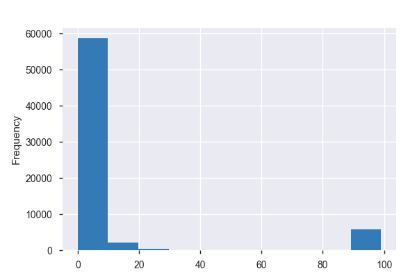

**Common Values**

| Value | Count | Frequency (%) |  |
| --- | --- | --- | --- |
| 4.0 | 15283 | 19.8% |  |
| 3.0 | 14339 | 18.6% |  |
| 2.0 | 11126 | 14.4% |  |
| 5.0 | 7724 | 10.0% |  |
| 99.0 | 5736 | 7.4% |  |
| 1.0 | 3977 | 5.2% |  |
| 6.0 | 3514 | 4.6% |  |
| 10.0 | 957 | 1.2% |  |
| 8.0 | 895 | 1.2% |  |
| 0.0 | 854 | 1.1% |  |
| Other values (24) | 2520 | 3.3% |  |
| (Missing) | 10179 | 13.2% |  |

**Extreme Values**

Minimum 5 values

| Value | Count | Frequency (%) |  |
| --- | --- | --- | --- |
| 0.0 | 854 | 1.1% |  |
| 0.5 | 6 | 0.0% |  |
| 1.0 | 3977 | 5.2% |  |
| 1.5 | 14 | 0.0% |  |
| 2.0 | 11126 | 14.4% |  |

Maximum 5 values

| Value | Count | Frequency (%) |  |
| --- | --- | --- | --- |
| 24.0 | 62 | 0.1% |  |
| 25.0 | 4 | 0.0% |  |
| 30.0 | 2 | 0.0% |  |
| 50.0 | 1 | 0.0% |  |
| 99.0 | 5736 | 7.4% |  |

v134  
Numeric

| Distinct count | 35 |
| --- | --- |
| Unique (%) | 0.0% |
| Missing (%) | 13.2% |
| Missing (n) | 10179 |
| Infinite (%) | 0.0% |
| Infinite (n) | 0 |

| Mean | 11.222 |
| --- | --- |
| Minimum | 0 |
| Maximum | 99 |
| Zeros (%) | 1.2% |

Toggle details

**Statistics**

Quantile statistics

| Minimum | 0 |
| --- | --- |
| 5-th percentile | 1 |
| Q1 | 3 |
| Median | 4 |
| Q3 | 6 |
| 95-th percentile | 99 |
| Maximum | 99 |
| Range | 99 |
| Interquartile range | 3 |

Descriptive statistics

| Standard deviation | 24.699 |
| --- | --- |
| Coef of variation | 2.2008 |
| Kurtosis | 8.6161 |
| Mean | 11.222 |
| MAD | 12.854 |
| Skewness | 3.2396 |
| Sum | 751060 |
| Variance | 610.03 |
| Memory size | 602.5 KiB |

**Histogram**

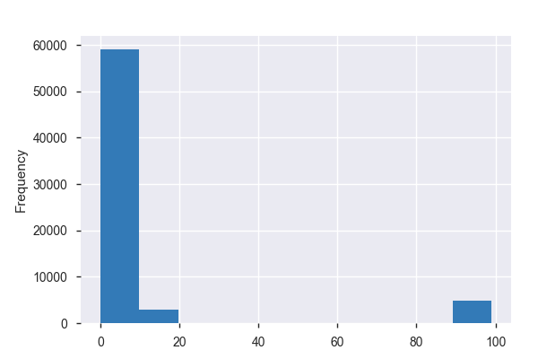

**Common Values**

| Value | Count | Frequency (%) |  |
| --- | --- | --- | --- |
| 4.0 | 14325 | 18.6% |  |
| 3.0 | 11300 | 14.7% |  |
| 2.0 | 8980 | 11.6% |  |
| 5.0 | 8853 | 11.5% |  |
| 6.0 | 6851 | 8.9% |  |
| 99.0 | 4869 | 6.3% |  |
| 1.0 | 2898 | 3.8% |  |
| 8.0 | 2632 | 3.4% |  |
| 10.0 | 1938 | 2.5% |  |
| 7.0 | 1846 | 2.4% |  |
| Other values (24) | 2433 | 3.2% |  |
| (Missing) | 10179 | 13.2% |  |

**Extreme Values**

Minimum 5 values

| Value | Count | Frequency (%) |  |
| --- | --- | --- | --- |
| 0.0 | 957 | 1.2% |  |
| 0.25 | 1 | 0.0% |  |
| 0.5 | 4 | 0.0% |  |
| 1.0 | 2898 | 3.8% |  |
| 1.5 | 8 | 0.0% |  |

Maximum 5 values

| Value | Count | Frequency (%) |  |
| --- | --- | --- | --- |
| 21.0 | 3 | 0.0% |  |
| 22.0 | 6 | 0.0% |  |
| 24.0 | 18 | 0.0% |  |
| 30.0 | 1 | 0.0% |  |
| 99.0 | 4869 | 6.3% |  |

v135_1  
Categorical

| Distinct count | 7 |
| --- | --- |
| Unique (%) | 0.0% |
| Missing (%) | 13.2% |
| Missing (n) | 10180 |

| gemeente/OCMW | 23123 |
| --- | --- |
| anderen | 15332 |
| 99 | 13343 |
| Other values (3) | 15126 |
| (Missing) | 10180 |

Toggle details

| Value | Count | Frequency (%) |  |
| --- | --- | --- | --- |
| gemeente/OCMW | 23123 | 30.0% |  |
| anderen | 15332 | 19.9% |  |
| 99 | 13343 | 17.3% |  |
| kinderen/ kleinkinderen | 9846 | 12.8% |  |
| ouderenbeweging | 4206 | 5.5% |  |
| buren/familie | 1074 | 1.4% |  |
| (Missing) | 10180 | 13.2% |  |

v135_10  
Categorical

| Distinct count | 7 |
| --- | --- |
| Unique (%) | 0.0% |
| Missing (%) | 13.2% |
| Missing (n) | 10180 |

| 99 | 22913 |
| --- | --- |
| gemeente/OCMW | 20845 |
| anderen | 14127 |
| Other values (3) | 9039 |
| (Missing) | 10180 |

Toggle details

| Value | Count | Frequency (%) |  |
| --- | --- | --- | --- |
| 99 | 22913 | 29.7% |  |
| gemeente/OCMW | 20845 | 27.0% |  |
| anderen | 14127 | 18.3% |  |
| kinderen/ kleinkinderen | 5935 | 7.7% |  |
| ouderenbeweging | 2354 | 3.1% |  |
| buren/familie | 750 | 1.0% |  |
| (Missing) | 10180 | 13.2% |  |

v135_11  
Categorical

| Distinct count | 7 |
| --- | --- |
| Unique (%) | 0.0% |
| Missing (%) | 13.2% |
| Missing (n) | 10180 |

| 99 | 24299 |
| --- | --- |
| gemeente/OCMW | 20986 |
| anderen | 13268 |
| Other values (3) | 8371 |
| (Missing) | 10180 |

Toggle details

| Value | Count | Frequency (%) |  |
| --- | --- | --- | --- |
| 99 | 24299 | 31.5% |  |
| gemeente/OCMW | 20986 | 27.2% |  |
| anderen | 13268 | 17.2% |  |
| kinderen/ kleinkinderen | 5501 | 7.1% |  |
| ouderenbeweging | 2233 | 2.9% |  |
| buren/familie | 637 | 0.8% |  |
| (Missing) | 10180 | 13.2% |  |

v135_12  
Categorical

| Distinct count | 7 |
| --- | --- |
| Unique (%) | 0.0% |
| Missing (%) | 13.2% |
| Missing (n) | 10180 |

| 99 | 25907 |
| --- | --- |
| gemeente/OCMW | 20430 |
| anderen | 13004 |
| Other values (3) | 7583 |
| (Missing) | 10180 |

Toggle details

| Value | Count | Frequency (%) |  |
| --- | --- | --- | --- |
| 99 | 25907 | 33.6% |  |
| gemeente/OCMW | 20430 | 26.5% |  |
| anderen | 13004 | 16.9% |  |
| kinderen/ kleinkinderen | 5087 | 6.6% |  |
| ouderenbeweging | 1944 | 2.5% |  |
| buren/familie | 552 | 0.7% |  |
| (Missing) | 10180 | 13.2% |  |

v135_13  
Categorical

| Distinct count | 7 |
| --- | --- |
| Unique (%) | 0.0% |
| Missing (%) | 13.2% |
| Missing (n) | 10180 |

| 99 | 25803 |
| --- | --- |
| gemeente/OCMW | 24055 |
| anderen | 9296 |
| Other values (3) | 7770 |
| (Missing) | 10180 |

Toggle details

| Value | Count | Frequency (%) |  |
| --- | --- | --- | --- |
| 99 | 25803 | 33.5% |  |
| gemeente/OCMW | 24055 | 31.2% |  |
| anderen | 9296 | 12.1% |  |
| kinderen/ kleinkinderen | 5690 | 7.4% |  |
| ouderenbeweging | 1485 | 1.9% |  |
| buren/familie | 595 | 0.8% |  |
| (Missing) | 10180 | 13.2% |  |

v135_14  
Categorical

| Distinct count | 7 |
| --- | --- |
| Unique (%) | 0.0% |
| Missing (%) | 13.2% |
| Missing (n) | 10180 |

| gemeente/OCMW | 25880 |
| --- | --- |
| 99 | 25649 |
| anderen | 8635 |
| Other values (3) | 6760 |
| (Missing) | 10180 |

Toggle details

| Value | Count | Frequency (%) |  |
| --- | --- | --- | --- |
| gemeente/OCMW | 25880 | 33.6% |  |
| 99 | 25649 | 33.3% |  |
| anderen | 8635 | 11.2% |  |
| kinderen/ kleinkinderen | 4791 | 6.2% |  |
| ouderenbeweging | 1464 | 1.9% |  |
| buren/familie | 505 | 0.7% |  |
| (Missing) | 10180 | 13.2% |  |

v135_15  
Categorical

| Distinct count | 7 |
| --- | --- |
| Unique (%) | 0.0% |
| Missing (%) | 13.2% |
| Missing (n) | 10180 |

| gemeente/OCMW | 30280 |
| --- | --- |
| 99 | 23691 |
| anderen | 5854 |
| Other values (3) | 7099 |
| (Missing) | 10180 |

Toggle details

| Value | Count | Frequency (%) |  |
| --- | --- | --- | --- |
| gemeente/OCMW | 30280 | 39.3% |  |
| 99 | 23691 | 30.7% |  |
| anderen | 5854 | 7.6% |  |
| kinderen/ kleinkinderen | 4932 | 6.4% |  |
| ouderenbeweging | 1519 | 2.0% |  |
| buren/familie | 648 | 0.8% |  |
| (Missing) | 10180 | 13.2% |  |

v135_16  
Categorical

| Distinct count | 7 |
| --- | --- |
| Unique (%) | 0.0% |
| Missing (%) | 13.2% |
| Missing (n) | 10180 |

| 99 | 27823 |
| --- | --- |
| gemeente/OCMW | 22497 |
| anderen | 9927 |
| Other values (3) | 6677 |
| (Missing) | 10180 |

Toggle details

| Value | Count | Frequency (%) |  |
| --- | --- | --- | --- |
| 99 | 27823 | 36.1% |  |
| gemeente/OCMW | 22497 | 29.2% |  |
| anderen | 9927 | 12.9% |  |
| kinderen/ kleinkinderen | 4225 | 5.5% |  |
| ouderenbeweging | 1942 | 2.5% |  |
| buren/familie | 510 | 0.7% |  |
| (Missing) | 10180 | 13.2% |  |

v135_17  
Categorical

| Distinct count | 7 |
| --- | --- |
| Unique (%) | 0.0% |
| Missing (%) | 13.2% |
| Missing (n) | 10180 |

| gemeente/OCMW | 28041 |
| --- | --- |
| 99 | 22878 |
| anderen | 7172 |
| Other values (3) | 8833 |
| (Missing) | 10180 |

Toggle details

| Value | Count | Frequency (%) |  |
| --- | --- | --- | --- |
| gemeente/OCMW | 28041 | 36.4% |  |
| 99 | 22878 | 29.7% |  |
| anderen | 7172 | 9.3% |  |
| kinderen/ kleinkinderen | 4924 | 6.4% |  |
| ouderenbeweging | 3342 | 4.3% |  |
| buren/familie | 567 | 0.7% |  |
| (Missing) | 10180 | 13.2% |  |

v135_18  
Categorical

| Distinct count | 7 |
| --- | --- |
| Unique (%) | 0.0% |
| Missing (%) | 13.2% |
| Missing (n) | 10180 |

| gemeente/OCMW | 26161 |
| --- | --- |
| 99 | 26060 |
| anderen | 7161 |
| Other values (3) | 7542 |
| (Missing) | 10180 |

Toggle details

| Value | Count | Frequency (%) |  |
| --- | --- | --- | --- |
| gemeente/OCMW | 26161 | 33.9% |  |
| 99 | 26060 | 33.8% |  |
| anderen | 7161 | 9.3% |  |
| kinderen/ kleinkinderen | 4171 | 5.4% |  |
| ouderenbeweging | 2847 | 3.7% |  |
| buren/familie | 524 | 0.7% |  |
| (Missing) | 10180 | 13.2% |  |

v135_19  
Categorical

| Distinct count | 7 |
| --- | --- |
| Unique (%) | 0.0% |
| Missing (%) | 13.2% |
| Missing (n) | 10180 |

| gemeente/OCMW | 28202 |
| --- | --- |
| 99 | 24369 |
| anderen | 6892 |
| Other values (3) | 7461 |
| (Missing) | 10180 |

Toggle details

| Value | Count | Frequency (%) |  |
| --- | --- | --- | --- |
| gemeente/OCMW | 28202 | 36.6% |  |
| 99 | 24369 | 31.6% |  |
| anderen | 6892 | 8.9% |  |
| kinderen/ kleinkinderen | 4855 | 6.3% |  |
| ouderenbeweging | 1928 | 2.5% |  |
| buren/familie | 678 | 0.9% |  |
| (Missing) | 10180 | 13.2% |  |

v135_2  
Categorical

| Distinct count | 7 |
| --- | --- |
| Unique (%) | 0.0% |
| Missing (%) | 13.2% |
| Missing (n) | 10180 |

| gemeente/OCMW | 21450 |
| --- | --- |
| 99 | 20108 |
| anderen | 14541 |
| Other values (3) | 10825 |
| (Missing) | 10180 |

Toggle details

| Value | Count | Frequency (%) |  |
| --- | --- | --- | --- |
| gemeente/OCMW | 21450 | 27.8% |  |
| 99 | 20108 | 26.1% |  |
| anderen | 14541 | 18.9% |  |
| kinderen/ kleinkinderen | 6694 | 8.7% |  |
| ouderenbeweging | 3331 | 4.3% |  |
| buren/familie | 800 | 1.0% |  |
| (Missing) | 10180 | 13.2% |  |

v135_20  
Categorical

| Distinct count | 7 |
| --- | --- |
| Unique (%) | 0.0% |
| Missing (%) | 13.2% |
| Missing (n) | 10180 |

| gemeente/OCMW | 29280 |
| --- | --- |
| 99 | 21681 |
| anderen | 7579 |
| Other values (3) | 8384 |
| (Missing) | 10180 |

Toggle details

| Value | Count | Frequency (%) |  |
| --- | --- | --- | --- |
| gemeente/OCMW | 29280 | 38.0% |  |
| 99 | 21681 | 28.1% |  |
| anderen | 7579 | 9.8% |  |
| kinderen/ kleinkinderen | 5407 | 7.0% |  |
| ouderenbeweging | 2240 | 2.9% |  |
| buren/familie | 737 | 1.0% |  |
| (Missing) | 10180 | 13.2% |  |

v135_21  
Categorical

| Distinct count | 7 |
| --- | --- |
| Unique (%) | 0.0% |
| Missing (%) | 13.2% |
| Missing (n) | 10180 |

| 99 | 26772 |
| --- | --- |
| gemeente/OCMW | 21979 |
| anderen | 9053 |
| Other values (3) | 9120 |
| (Missing) | 10180 |

Toggle details

| Value | Count | Frequency (%) |  |
| --- | --- | --- | --- |
| 99 | 26772 | 34.7% |  |
| gemeente/OCMW | 21979 | 28.5% |  |
| anderen | 9053 | 11.7% |  |
| kinderen/ kleinkinderen | 6203 | 8.0% |  |
| ouderenbeweging | 1980 | 2.6% |  |
| buren/familie | 937 | 1.2% |  |
| (Missing) | 10180 | 13.2% |  |

v135_22  
Categorical

| Distinct count | 7 |
| --- | --- |
| Unique (%) | 0.0% |
| Missing (%) | 13.2% |
| Missing (n) | 10180 |

| 99 | 26531 |
| --- | --- |
| gemeente/OCMW | 23033 |
| anderen | 9866 |
| Other values (3) | 7494 |
| (Missing) | 10180 |

Toggle details

| Value | Count | Frequency (%) |  |
| --- | --- | --- | --- |
| 99 | 26531 | 34.4% |  |
| gemeente/OCMW | 23033 | 29.9% |  |
| anderen | 9866 | 12.8% |  |
| kinderen/ kleinkinderen | 4768 | 6.2% |  |
| ouderenbeweging | 2127 | 2.8% |  |
| buren/familie | 599 | 0.8% |  |
| (Missing) | 10180 | 13.2% |  |

v135_23  
Categorical

| Distinct count | 7 |
| --- | --- |
| Unique (%) | 0.0% |
| Missing (%) | 13.2% |
| Missing (n) | 10180 |

| 99 | 26250 |
| --- | --- |
| gemeente/OCMW | 22397 |
| anderen | 9862 |
| Other values (3) | 8415 |
| (Missing) | 10180 |

Toggle details

| Value | Count | Frequency (%) |  |
| --- | --- | --- | --- |
| 99 | 26250 | 34.0% |  |
| gemeente/OCMW | 22397 | 29.0% |  |
| anderen | 9862 | 12.8% |  |
| kinderen/ kleinkinderen | 5402 | 7.0% |  |
| ouderenbeweging | 2232 | 2.9% |  |
| buren/familie | 781 | 1.0% |  |
| (Missing) | 10180 | 13.2% |  |

v135_24  
Categorical

| Distinct count | 7 |
| --- | --- |
| Unique (%) | 0.0% |
| Missing (%) | 13.2% |
| Missing (n) | 10180 |

| 99 | 23206 |
| --- | --- |
| gemeente/OCMW | 19595 |
| anderen | 15326 |
| Other values (3) | 8797 |
| (Missing) | 10180 |

Toggle details

| Value | Count | Frequency (%) |  |
| --- | --- | --- | --- |
| 99 | 23206 | 30.1% |  |
| gemeente/OCMW | 19595 | 25.4% |  |
| anderen | 15326 | 19.9% |  |
| kinderen/ kleinkinderen | 5516 | 7.2% |  |
| ouderenbeweging | 2620 | 3.4% |  |
| buren/familie | 661 | 0.9% |  |
| (Missing) | 10180 | 13.2% |  |

v135_25  
Categorical

| Distinct count | 7 |
| --- | --- |
| Unique (%) | 0.0% |
| Missing (%) | 13.2% |
| Missing (n) | 10180 |

| 99 | 27011 |
| --- | --- |
| gemeente/OCMW | 24503 |
| anderen | 9253 |
| Other values (3) | 6157 |
| (Missing) | 10180 |

Toggle details

| Value | Count | Frequency (%) |  |
| --- | --- | --- | --- |
| 99 | 27011 | 35.0% |  |
| gemeente/OCMW | 24503 | 31.8% |  |
| anderen | 9253 | 12.0% |  |
| kinderen/ kleinkinderen | 4166 | 5.4% |  |
| ouderenbeweging | 1522 | 2.0% |  |
| buren/familie | 469 | 0.6% |  |
| (Missing) | 10180 | 13.2% |  |

v135_26  
Categorical

| Distinct count | 7 |
| --- | --- |
| Unique (%) | 0.0% |
| Missing (%) | 13.2% |
| Missing (n) | 10180 |

| gemeente/OCMW | 26117 |
| --- | --- |
| 99 | 24575 |
| anderen | 8856 |
| Other values (3) | 7376 |
| (Missing) | 10180 |

Toggle details

| Value | Count | Frequency (%) |  |
| --- | --- | --- | --- |
| gemeente/OCMW | 26117 | 33.9% |  |
| 99 | 24575 | 31.9% |  |
| anderen | 8856 | 11.5% |  |
| kinderen/ kleinkinderen | 5058 | 6.6% |  |
| ouderenbeweging | 1699 | 2.2% |  |
| buren/familie | 619 | 0.8% |  |
| (Missing) | 10180 | 13.2% |  |

v135_27  
Categorical

| Distinct count | 7 |
| --- | --- |
| Unique (%) | 0.0% |
| Missing (%) | 13.2% |
| Missing (n) | 10180 |

| gemeente/OCMW | 26302 |
| --- | --- |
| 99 | 24636 |
| anderen | 8875 |
| Other values (3) | 7111 |
| (Missing) | 10180 |

Toggle details

| Value | Count | Frequency (%) |  |
| --- | --- | --- | --- |
| gemeente/OCMW | 26302 | 34.1% |  |
| 99 | 24636 | 32.0% |  |
| anderen | 8875 | 11.5% |  |
| kinderen/ kleinkinderen | 4901 | 6.4% |  |
| ouderenbeweging | 1643 | 2.1% |  |
| buren/familie | 567 | 0.7% |  |
| (Missing) | 10180 | 13.2% |  |

v135_3  
Categorical

| Distinct count | 7 |
| --- | --- |
| Unique (%) | 0.0% |
| Missing (%) | 13.2% |
| Missing (n) | 10180 |

| gemeente/OCMW | 26964 |
| --- | --- |
| 99 | 21887 |
| anderen | 8331 |
| Other values (3) | 9742 |
| (Missing) | 10180 |

Toggle details

| Value | Count | Frequency (%) |  |
| --- | --- | --- | --- |
| gemeente/OCMW | 26964 | 35.0% |  |
| 99 | 21887 | 28.4% |  |
| anderen | 8331 | 10.8% |  |
| kinderen/ kleinkinderen | 5553 | 7.2% |  |
| ouderenbeweging | 3572 | 4.6% |  |
| buren/familie | 617 | 0.8% |  |
| (Missing) | 10180 | 13.2% |  |

v135_4  
Categorical

| Distinct count | 7 |
| --- | --- |
| Unique (%) | 0.0% |
| Missing (%) | 13.2% |
| Missing (n) | 10180 |

| gemeente/OCMW | 29255 |
| --- | --- |
| 99 | 23121 |
| anderen | 6079 |
| Other values (3) | 8469 |
| (Missing) | 10180 |

Toggle details

| Value | Count | Frequency (%) |  |
| --- | --- | --- | --- |
| gemeente/OCMW | 29255 | 37.9% |  |
| 99 | 23121 | 30.0% |  |
| anderen | 6079 | 7.9% |  |
| kinderen/ kleinkinderen | 5833 | 7.6% |  |
| ouderenbeweging | 1903 | 2.5% |  |
| buren/familie | 733 | 1.0% |  |
| (Missing) | 10180 | 13.2% |  |

v135_5  
Categorical

| Distinct count | 7 |
| --- | --- |
| Unique (%) | 0.0% |
| Missing (%) | 13.2% |
| Missing (n) | 10180 |

| gemeente/OCMW | 28291 |
| --- | --- |
| 99 | 24554 |
| anderen | 7117 |
| Other values (3) | 6962 |
| (Missing) | 10180 |

Toggle details

| Value | Count | Frequency (%) |  |
| --- | --- | --- | --- |
| gemeente/OCMW | 28291 | 36.7% |  |
| 99 | 24554 | 31.8% |  |
| anderen | 7117 | 9.2% |  |
| kinderen/ kleinkinderen | 4591 | 6.0% |  |
| ouderenbeweging | 1884 | 2.4% |  |
| buren/familie | 487 | 0.6% |  |
| (Missing) | 10180 | 13.2% |  |

v135_6  
Categorical

| Distinct count | 7 |
| --- | --- |
| Unique (%) | 0.0% |
| Missing (%) | 13.2% |
| Missing (n) | 10180 |

| 99 | 23485 |
| --- | --- |
| gemeente/OCMW | 20885 |
| anderen | 13109 |
| Other values (3) | 9445 |
| (Missing) | 10180 |

Toggle details

| Value | Count | Frequency (%) |  |
| --- | --- | --- | --- |
| 99 | 23485 | 30.5% |  |
| gemeente/OCMW | 20885 | 27.1% |  |
| anderen | 13109 | 17.0% |  |
| kinderen/ kleinkinderen | 5611 | 7.3% |  |
| ouderenbeweging | 3118 | 4.0% |  |
| buren/familie | 716 | 0.9% |  |
| (Missing) | 10180 | 13.2% |  |

v135_7  
Categorical

| Distinct count | 7 |
| --- | --- |
| Unique (%) | 0.0% |
| Missing (%) | 13.2% |
| Missing (n) | 10180 |

| 99 | 24243 |
| --- | --- |
| gemeente/OCMW | 17992 |
| anderen | 12998 |
| Other values (3) | 11691 |
| (Missing) | 10180 |

Toggle details

| Value | Count | Frequency (%) |  |
| --- | --- | --- | --- |
| 99 | 24243 | 31.4% |  |
| gemeente/OCMW | 17992 | 23.3% |  |
| anderen | 12998 | 16.9% |  |
| kinderen/ kleinkinderen | 7933 | 10.3% |  |
| ouderenbeweging | 2373 | 3.1% |  |
| buren/familie | 1385 | 1.8% |  |
| (Missing) | 10180 | 13.2% |  |

v135_8  
Categorical

| Distinct count | 7 |
| --- | --- |
| Unique (%) | 0.0% |
| Missing (%) | 13.2% |
| Missing (n) | 10180 |

| 99 | 26112 |
| --- | --- |
| anderen | 16893 |
| gemeente/OCMW | 12254 |
| Other values (3) | 11665 |
| (Missing) | 10180 |

Toggle details

| Value | Count | Frequency (%) |  |
| --- | --- | --- | --- |
| 99 | 26112 | 33.9% |  |
| anderen | 16893 | 21.9% |  |
| gemeente/OCMW | 12254 | 15.9% |  |
| kinderen/ kleinkinderen | 8478 | 11.0% |  |
| ouderenbeweging | 1745 | 2.3% |  |
| buren/familie | 1442 | 1.9% |  |
| (Missing) | 10180 | 13.2% |  |

v135_9  
Categorical

| Distinct count | 7 |
| --- | --- |
| Unique (%) | 0.0% |
| Missing (%) | 13.2% |
| Missing (n) | 10180 |

| 99 | 22918 |
| --- | --- |
| gemeente/OCMW | 20384 |
| anderen | 13910 |
| Other values (3) | 9712 |
| (Missing) | 10180 |

Toggle details

| Value | Count | Frequency (%) |  |
| --- | --- | --- | --- |
| 99 | 22918 | 29.7% |  |
| gemeente/OCMW | 20384 | 26.4% |  |
| anderen | 13910 | 18.0% |  |
| kinderen/ kleinkinderen | 6257 | 8.1% |  |
| ouderenbeweging | 2642 | 3.4% |  |
| buren/familie | 813 | 1.1% |  |
| (Missing) | 10180 | 13.2% |  |

v136_1  
Categorical

| Distinct count | 8 |
| --- | --- |
| Unique (%) | 0.0% |
| Missing (%) | 13.2% |
| Missing (n) | 10180 |

| eerder tevreden | 18083 |
| --- | --- |
| 99 | 11716 |
| noch ontevreden, noch tevreden | 11017 |
| Other values (4) | 26108 |
| (Missing) | 10180 |

Toggle details

| Value | Count | Frequency (%) |  |
| --- | --- | --- | --- |
| eerder tevreden | 18083 | 23.5% |  |
| 99 | 11716 | 15.2% |  |
| noch ontevreden, noch tevreden | 11017 | 14.3% |  |
| zeer tevreden | 8905 | 11.5% |  |
| helemaal niet tevreden | 6013 | 7.8% |  |
| geen info gevraagd | 5800 | 7.5% |  |
| eerder ontevreden | 5390 | 7.0% |  |
| (Missing) | 10180 | 13.2% |  |

v136_10  
Categorical

| Distinct count | 8 |
| --- | --- |
| Unique (%) | 0.0% |
| Missing (%) | 13.2% |
| Missing (n) | 10180 |

| geen info gevraagd | 24323 |
| --- | --- |
| 99 | 23743 |
| noch ontevreden, noch tevreden | 7588 |
| Other values (4) | 11270 |
| (Missing) | 10180 |

Toggle details

| Value | Count | Frequency (%) |  |
| --- | --- | --- | --- |
| geen info gevraagd | 24323 | 31.5% |  |
| 99 | 23743 | 30.8% |  |
| noch ontevreden, noch tevreden | 7588 | 9.8% |  |
| eerder tevreden | 4871 | 6.3% |  |
| helemaal niet tevreden | 2268 | 2.9% |  |
| eerder ontevreden | 2212 | 2.9% |  |
| zeer tevreden | 1919 | 2.5% |  |
| (Missing) | 10180 | 13.2% |  |

v136_11  
Categorical

| Distinct count | 8 |
| --- | --- |
| Unique (%) | 0.0% |
| Missing (%) | 13.2% |
| Missing (n) | 10180 |

| geen info gevraagd | 25494 |
| --- | --- |
| 99 | 24719 |
| noch ontevreden, noch tevreden | 6750 |
| Other values (4) | 9961 |
| (Missing) | 10180 |

Toggle details

| Value | Count | Frequency (%) |  |
| --- | --- | --- | --- |
| geen info gevraagd | 25494 | 33.1% |  |
| 99 | 24719 | 32.1% |  |
| noch ontevreden, noch tevreden | 6750 | 8.8% |  |
| eerder tevreden | 3940 | 5.1% |  |
| zeer tevreden | 2184 | 2.8% |  |
| helemaal niet tevreden | 2070 | 2.7% |  |
| eerder ontevreden | 1767 | 2.3% |  |
| (Missing) | 10180 | 13.2% |  |

v136_12  
Categorical

| Distinct count | 8 |
| --- | --- |
| Unique (%) | 0.0% |
| Missing (%) | 13.2% |
| Missing (n) | 10180 |

| geen info gevraagd | 27264 |
| --- | --- |
| 99 | 25564 |
| noch ontevreden, noch tevreden | 6578 |
| Other values (4) | 7518 |
| (Missing) | 10180 |

Toggle details

| Value | Count | Frequency (%) |  |
| --- | --- | --- | --- |
| geen info gevraagd | 27264 | 35.4% |  |
| 99 | 25564 | 33.2% |  |
| noch ontevreden, noch tevreden | 6578 | 8.5% |  |
| eerder tevreden | 2826 | 3.7% |  |
| helemaal niet tevreden | 1827 | 2.4% |  |
| eerder ontevreden | 1516 | 2.0% |  |
| zeer tevreden | 1349 | 1.7% |  |
| (Missing) | 10180 | 13.2% |  |

v136_13  
Categorical

| Distinct count | 8 |
| --- | --- |
| Unique (%) | 0.0% |
| Missing (%) | 13.2% |
| Missing (n) | 10180 |

| 99 | 28693 |
| --- | --- |
| geen info gevraagd | 23871 |
| noch ontevreden, noch tevreden | 6923 |
| Other values (4) | 7437 |
| (Missing) | 10180 |

Toggle details

| Value | Count | Frequency (%) |  |
| --- | --- | --- | --- |
| 99 | 28693 | 37.2% |  |
| geen info gevraagd | 23871 | 31.0% |  |
| noch ontevreden, noch tevreden | 6923 | 9.0% |  |
| eerder tevreden | 3915 | 5.1% |  |
| zeer tevreden | 1809 | 2.3% |  |
| helemaal niet tevreden | 897 | 1.2% |  |
| eerder ontevreden | 816 | 1.1% |  |
| (Missing) | 10180 | 13.2% |  |

v136_14  
Categorical

| Distinct count | 8 |
| --- | --- |
| Unique (%) | 0.0% |
| Missing (%) | 13.2% |
| Missing (n) | 10180 |

| geen info gevraagd | 29490 |
| --- | --- |
| 99 | 26607 |
| noch ontevreden, noch tevreden | 6712 |
| Other values (4) | 4115 |
| (Missing) | 10180 |

Toggle details

| Value | Count | Frequency (%) |  |
| --- | --- | --- | --- |
| geen info gevraagd | 29490 | 38.2% |  |
| 99 | 26607 | 34.5% |  |
| noch ontevreden, noch tevreden | 6712 | 8.7% |  |
| eerder tevreden | 2244 | 2.9% |  |
| helemaal niet tevreden | 722 | 0.9% |  |
| zeer tevreden | 646 | 0.8% |  |
| eerder ontevreden | 503 | 0.7% |  |
| (Missing) | 10180 | 13.2% |  |

v136_15  
Categorical

| Distinct count | 8 |
| --- | --- |
| Unique (%) | 0.0% |
| Missing (%) | 13.2% |
| Missing (n) | 10180 |

| 99 | 26943 |
| --- | --- |
| geen info gevraagd | 25704 |
| noch ontevreden, noch tevreden | 6226 |
| Other values (4) | 8051 |
| (Missing) | 10180 |

Toggle details

| Value | Count | Frequency (%) |  |
| --- | --- | --- | --- |
| 99 | 26943 | 34.9% |  |
| geen info gevraagd | 25704 | 33.3% |  |
| noch ontevreden, noch tevreden | 6226 | 8.1% |  |
| eerder tevreden | 4224 | 5.5% |  |
| zeer tevreden | 2569 | 3.3% |  |
| helemaal niet tevreden | 714 | 0.9% |  |
| eerder ontevreden | 544 | 0.7% |  |
| (Missing) | 10180 | 13.2% |  |

v136_16  
Categorical

| Distinct count | 8 |
| --- | --- |
| Unique (%) | 0.0% |
| Missing (%) | 13.2% |
| Missing (n) | 10180 |

| geen info gevraagd | 27974 |
| --- | --- |
| 99 | 26264 |
| noch ontevreden, noch tevreden | 6526 |
| Other values (4) | 6160 |
| (Missing) | 10180 |

Toggle details

| Value | Count | Frequency (%) |  |
| --- | --- | --- | --- |
| geen info gevraagd | 27974 | 36.3% |  |
| 99 | 26264 | 34.1% |  |
| noch ontevreden, noch tevreden | 6526 | 8.5% |  |
| eerder tevreden | 3581 | 4.6% |  |
| zeer tevreden | 1527 | 2.0% |  |
| helemaal niet tevreden | 586 | 0.8% |  |
| eerder ontevreden | 466 | 0.6% |  |
| (Missing) | 10180 | 13.2% |  |

v136_17  
Categorical

| Distinct count | 8 |
| --- | --- |
| Unique (%) | 0.0% |
| Missing (%) | 13.2% |
| Missing (n) | 10180 |

| geen info gevraagd | 25985 |
| --- | --- |
| 99 | 24019 |
| noch ontevreden, noch tevreden | 6392 |
| Other values (4) | 10528 |
| (Missing) | 10180 |

Toggle details

| Value | Count | Frequency (%) |  |
| --- | --- | --- | --- |
| geen info gevraagd | 25985 | 33.7% |  |
| 99 | 24019 | 31.2% |  |
| noch ontevreden, noch tevreden | 6392 | 8.3% |  |
| eerder tevreden | 5090 | 6.6% |  |
| zeer tevreden | 3982 | 5.2% |  |
| helemaal niet tevreden | 830 | 1.1% |  |
| eerder ontevreden | 626 | 0.8% |  |
| (Missing) | 10180 | 13.2% |  |

v136_18  
Categorical

| Distinct count | 8 |
| --- | --- |
| Unique (%) | 0.0% |
| Missing (%) | 95.6% |
| Missing (n) | 73719 |

| geen beroep op gedaan | 1402 |
| --- | --- |
| noch ontevreden, noch tevreden | 897 |
| 99 | 504 |
| Other values (4) | 582 |
| (Missing) | 73719 |

Toggle details

| Value | Count | Frequency (%) |  |
| --- | --- | --- | --- |
| geen beroep op gedaan | 1402 | 1.8% |  |
| noch ontevreden, noch tevreden | 897 | 1.2% |  |
| 99 | 504 | 0.7% |  |
| eerder tevreden | 354 | 0.5% |  |
| zeer tevreden | 156 | 0.2% |  |
| helemaal niet tevreden | 39 | 0.1% |  |
| eerder ontevreden | 33 | 0.0% |  |
| (Missing) | 73719 | 95.6% |  |

v136_19  
Categorical

| Distinct count | 8 |
| --- | --- |
| Unique (%) | 0.0% |
| Missing (%) | 13.2% |
| Missing (n) | 10180 |

| geen info gevraagd | 29726 |
| --- | --- |
| 99 | 26534 |
| noch ontevreden, noch tevreden | 6531 |
| Other values (4) | 4133 |
| (Missing) | 10180 |

Toggle details

| Value | Count | Frequency (%) |  |
| --- | --- | --- | --- |
| geen info gevraagd | 29726 | 38.6% |  |
| 99 | 26534 | 34.4% |  |
| noch ontevreden, noch tevreden | 6531 | 8.5% |  |
| eerder tevreden | 2397 | 3.1% |  |
| zeer tevreden | 816 | 1.1% |  |
| helemaal niet tevreden | 552 | 0.7% |  |
| eerder ontevreden | 368 | 0.5% |  |
| (Missing) | 10180 | 13.2% |  |

v136_2  
Categorical

| Distinct count | 8 |
| --- | --- |
| Unique (%) | 0.0% |
| Missing (%) | 13.2% |
| Missing (n) | 10180 |

| 99 | 20040 |
| --- | --- |
| geen info gevraagd | 12627 |
| eerder tevreden | 11853 |
| Other values (4) | 22404 |
| (Missing) | 10180 |

Toggle details

| Value | Count | Frequency (%) |  |
| --- | --- | --- | --- |
| 99 | 20040 | 26.0% |  |
| geen info gevraagd | 12627 | 16.4% |  |
| eerder tevreden | 11853 | 15.4% |  |
| noch ontevreden, noch tevreden | 9164 | 11.9% |  |
| zeer tevreden | 5325 | 6.9% |  |
| eerder ontevreden | 4025 | 5.2% |  |
| helemaal niet tevreden | 3890 | 5.0% |  |
| (Missing) | 10180 | 13.2% |  |

v136_20  
Categorical

| Distinct count | 8 |
| --- | --- |
| Unique (%) | 0.0% |
| Missing (%) | 13.2% |
| Missing (n) | 10180 |

| geen info gevraagd | 29488 |
| --- | --- |
| 99 | 26066 |
| noch ontevreden, noch tevreden | 6245 |
| Other values (4) | 5125 |
| (Missing) | 10180 |

Toggle details

| Value | Count | Frequency (%) |  |
| --- | --- | --- | --- |
| geen info gevraagd | 29488 | 38.2% |  |
| 99 | 26066 | 33.8% |  |
| noch ontevreden, noch tevreden | 6245 | 8.1% |  |
| eerder tevreden | 2730 | 3.5% |  |
| zeer tevreden | 1064 | 1.4% |  |
| helemaal niet tevreden | 769 | 1.0% |  |
| eerder ontevreden | 562 | 0.7% |  |
| (Missing) | 10180 | 13.2% |  |

v136_21  
Categorical

| Distinct count | 8 |
| --- | --- |
| Unique (%) | 0.0% |
| Missing (%) | 13.2% |
| Missing (n) | 10180 |

| geen info gevraagd | 29671 |
| --- | --- |
| 99 | 26047 |
| noch ontevreden, noch tevreden | 6250 |
| Other values (4) | 4956 |
| (Missing) | 10180 |

Toggle details

| Value | Count | Frequency (%) |  |
| --- | --- | --- | --- |
| geen info gevraagd | 29671 | 38.5% |  |
| 99 | 26047 | 33.8% |  |
| noch ontevreden, noch tevreden | 6250 | 8.1% |  |
| eerder tevreden | 2577 | 3.3% |  |
| zeer tevreden | 1072 | 1.4% |  |
| helemaal niet tevreden | 779 | 1.0% |  |
| eerder ontevreden | 528 | 0.7% |  |
| (Missing) | 10180 | 13.2% |  |

v136_3  
Categorical

| Distinct count | 8 |
| --- | --- |
| Unique (%) | 0.0% |
| Missing (%) | 13.2% |
| Missing (n) | 10180 |

| 99 | 23552 |
| --- | --- |
| geen info gevraagd | 20473 |
| noch ontevreden, noch tevreden | 9009 |
| Other values (4) | 13890 |
| (Missing) | 10180 |

Toggle details

| Value | Count | Frequency (%) |  |
| --- | --- | --- | --- |
| 99 | 23552 | 30.5% |  |
| geen info gevraagd | 20473 | 26.6% |  |
| noch ontevreden, noch tevreden | 9009 | 11.7% |  |
| eerder tevreden | 6114 | 7.9% |  |
| helemaal niet tevreden | 2897 | 3.8% |  |
| eerder ontevreden | 2883 | 3.7% |  |
| zeer tevreden | 1996 | 2.6% |  |
| (Missing) | 10180 | 13.2% |  |

v136_4  
Categorical

| Distinct count | 8 |
| --- | --- |
| Unique (%) | 0.0% |
| Missing (%) | 13.2% |
| Missing (n) | 10180 |

| 99 | 25154 |
| --- | --- |
| geen info gevraagd | 23749 |
| noch ontevreden, noch tevreden | 8669 |
| Other values (4) | 9352 |
| (Missing) | 10180 |

Toggle details

| Value | Count | Frequency (%) |  |
| --- | --- | --- | --- |
| 99 | 25154 | 32.6% |  |
| geen info gevraagd | 23749 | 30.8% |  |
| noch ontevreden, noch tevreden | 8669 | 11.2% |  |
| eerder tevreden | 4325 | 5.6% |  |
| eerder ontevreden | 2040 | 2.6% |  |
| helemaal niet tevreden | 1882 | 2.4% |  |
| zeer tevreden | 1105 | 1.4% |  |
| (Missing) | 10180 | 13.2% |  |

v136_5  
Categorical

| Distinct count | 8 |
| --- | --- |
| Unique (%) | 0.0% |
| Missing (%) | 13.2% |
| Missing (n) | 10180 |

| 99 | 24944 |
| --- | --- |
| geen info gevraagd | 23631 |
| noch ontevreden, noch tevreden | 7897 |
| Other values (4) | 10452 |
| (Missing) | 10180 |

Toggle details

| Value | Count | Frequency (%) |  |
| --- | --- | --- | --- |
| 99 | 24944 | 32.4% |  |
| geen info gevraagd | 23631 | 30.6% |  |
| noch ontevreden, noch tevreden | 7897 | 10.2% |  |
| eerder tevreden | 3706 | 4.8% |  |
| helemaal niet tevreden | 2912 | 3.8% |  |
| eerder ontevreden | 2831 | 3.7% |  |
| zeer tevreden | 1003 | 1.3% |  |
| (Missing) | 10180 | 13.2% |  |

v136_6  
Categorical

| Distinct count | 8 |
| --- | --- |
| Unique (%) | 0.0% |
| Missing (%) | 13.2% |
| Missing (n) | 10180 |

| 99 | 24128 |
| --- | --- |
| geen info gevraagd | 20831 |
| noch ontevreden, noch tevreden | 8422 |
| Other values (4) | 13543 |
| (Missing) | 10180 |

Toggle details

| Value | Count | Frequency (%) |  |
| --- | --- | --- | --- |
| 99 | 24128 | 31.3% |  |
| geen info gevraagd | 20831 | 27.0% |  |
| noch ontevreden, noch tevreden | 8422 | 10.9% |  |
| eerder tevreden | 7521 | 9.8% |  |
| zeer tevreden | 2965 | 3.8% |  |
| eerder ontevreden | 1587 | 2.1% |  |
| helemaal niet tevreden | 1470 | 1.9% |  |
| (Missing) | 10180 | 13.2% |  |

v136_7  
Categorical

| Distinct count | 8 |
| --- | --- |
| Unique (%) | 0.0% |
| Missing (%) | 13.2% |
| Missing (n) | 10180 |

| geen info gevraagd | 26366 |
| --- | --- |
| 99 | 25672 |
| noch ontevreden, noch tevreden | 7603 |
| Other values (4) | 7283 |
| (Missing) | 10180 |

Toggle details

| Value | Count | Frequency (%) |  |
| --- | --- | --- | --- |
| geen info gevraagd | 26366 | 34.2% |  |
| 99 | 25672 | 33.3% |  |
| noch ontevreden, noch tevreden | 7603 | 9.9% |  |
| eerder tevreden | 4114 | 5.3% |  |
| zeer tevreden | 1467 | 1.9% |  |
| helemaal niet tevreden | 865 | 1.1% |  |
| eerder ontevreden | 837 | 1.1% |  |
| (Missing) | 10180 | 13.2% |  |

v136_8  
Categorical

| Distinct count | 8 |
| --- | --- |
| Unique (%) | 0.0% |
| Missing (%) | 13.2% |
| Missing (n) | 10180 |

| geen info gevraagd | 27236 |
| --- | --- |
| 99 | 26087 |
| noch ontevreden, noch tevreden | 7642 |
| Other values (4) | 5959 |
| (Missing) | 10180 |

Toggle details

| Value | Count | Frequency (%) |  |
| --- | --- | --- | --- |
| geen info gevraagd | 27236 | 35.3% |  |
| 99 | 26087 | 33.8% |  |
| noch ontevreden, noch tevreden | 7642 | 9.9% |  |
| eerder tevreden | 3131 | 4.1% |  |
| zeer tevreden | 1216 | 1.6% |  |
| helemaal niet tevreden | 900 | 1.2% |  |
| eerder ontevreden | 712 | 0.9% |  |
| (Missing) | 10180 | 13.2% |  |

v136_9  
Categorical

| Distinct count | 8 |
| --- | --- |
| Unique (%) | 0.0% |
| Missing (%) | 13.2% |
| Missing (n) | 10180 |

| 99 | 23603 |
| --- | --- |
| geen info gevraagd | 23475 |
| noch ontevreden, noch tevreden | 7371 |
| Other values (4) | 12475 |
| (Missing) | 10180 |

Toggle details

| Value | Count | Frequency (%) |  |
| --- | --- | --- | --- |
| 99 | 23603 | 30.6% |  |
| geen info gevraagd | 23475 | 30.4% |  |
| noch ontevreden, noch tevreden | 7371 | 9.6% |  |
| eerder tevreden | 6024 | 7.8% |  |
| zeer tevreden | 2771 | 3.6% |  |
| helemaal niet tevreden | 1905 | 2.5% |  |
| eerder ontevreden | 1775 | 2.3% |  |
| (Missing) | 10180 | 13.2% |  |

v14  
Numeric

| Distinct count | 287 |
| --- | --- |
| Unique (%) | 0.4% |
| Missing (%) | 0.0% |
| Missing (n) | 0 |
| Infinite (%) | 0.0% |
| Infinite (n) | 0 |

| Mean | 56.256 |
| --- | --- |
| Minimum | 0 |
| Maximum | 999 |
| Zeros (%) | 0.3% |

Toggle details

**Statistics**

Quantile statistics

| Minimum | 0 |
| --- | --- |
| 5-th percentile | 10 |
| Q1 | 33 |
| Median | 44 |
| Q3 | 70 |
| 95-th percentile | 100 |
| Maximum | 999 |
| Range | 999 |
| Interquartile range | 37 |

Descriptive statistics

| Standard deviation | 69.35 |
| --- | --- |
| Coef of variation | 1.2327 |
| Kurtosis | 139.59 |
| Mean | 56.256 |
| MAD | 29.696 |
| Skewness | 10.632 |
| Sum | 4337581 |
| Variance | 4809.4 |
| Memory size | 602.5 KiB |

**Histogram**

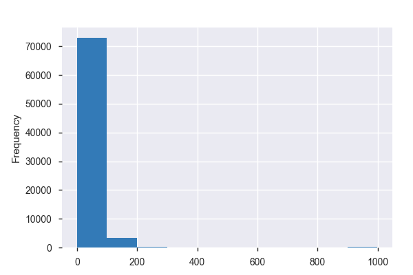

**Common Values**

| Value | Count | Frequency (%) |  |
| --- | --- | --- | --- |
| 99 | 9068 | 11.8% |  |
| 40 | 4059 | 5.3% |  |
| 50 | 3072 | 4.0% |  |
| 30 | 2908 | 3.8% |  |
| 35 | 2726 | 3.5% |  |
| 45 | 2084 | 2.7% |  |
| 100 | 1955 | 2.5% |  |
| 36 | 1765 | 2.3% |  |
| 38 | 1738 | 2.3% |  |
| 42 | 1620 | 2.1% |  |
| Other values (277) | 46109 | 59.8% |  |

**Extreme Values**

Minimum 5 values

| Value | Count | Frequency (%) |  |
| --- | --- | --- | --- |
| 0 | 204 | 0.3% |  |
| 1 | 427 | 0.6% |  |
| 2 | 397 | 0.5% |  |
| 3 | 409 | 0.5% |  |
| 4 | 369 | 0.5% |  |

Maximum 5 values

| Value | Count | Frequency (%) |  |
| --- | --- | --- | --- |
| 481 | 1 | 0.0% |  |
| 502 | 1 | 0.0% |  |
| 556 | 1 | 0.0% |  |
| 581 | 1 | 0.0% |  |
| 999 | 320 | 0.4% |  |

v15  
Categorical

| Distinct count | 5 |
| --- | --- |
| Unique (%) | 0.0% |
| Missing (%) | 0.0% |
| Missing (n) | 0 |

| eigenaar | 62054 |
| --- | --- |
| huurder (privé-markt) | 6404 |
| geen van bovenstaande | 3596 |
| Other values (2) | 5050 |

Toggle details

| Value | Count | Frequency (%) |  |
| --- | --- | --- | --- |
| eigenaar | 62054 | 80.5% |  |
| huurder (privé-markt) | 6404 | 8.3% |  |
| geen van bovenstaande | 3596 | 4.7% |  |
| huurder (sociale woning) | 3460 | 4.5% |  |
| 99 | 1590 | 2.1% |  |

v16  
Categorical

| Distinct count | 9 |
| --- | --- |
| Unique (%) | 0.0% |
| Missing (%) | 0.9% |
| Missing (n) | 718 |

| zelfstandig thuiswonend in ééngezinswoning | 62291 |
| --- | --- |
| zelfstandig thuiswonend in een appartement | 7819 |
| 99 | 3251 |
| Other values (5) | 3025 |

Toggle details

| Value | Count | Frequency (%) |  |
| --- | --- | --- | --- |
| zelfstandig thuiswonend in ééngezinswoning | 62291 | 80.8% |  |
| zelfstandig thuiswonend in een appartement | 7819 | 10.1% |  |
| 99 | 3251 | 4.2% |  |
| inwonend bij kinderen | 1753 | 2.3% |  |
| groepswonen | 616 | 0.8% |  |
| kangoeroe en intergenerationeel wonen | 339 | 0.4% |  |
| zelfstandig thuiswonend in een studio | 286 | 0.4% |  |
| serviceflat/assistentiewoning | 31 | 0.0% |  |
| (Missing) | 718 | 0.9% |  |

v17_1  
Categorical

| Distinct count | 6 |
| --- | --- |
| Unique (%) | 0.0% |
| Missing (%) | 0.0% |
| Missing (n) | 0 |

| helemaal niet van toepassing | 40123 |
| --- | --- |
| noch niet van toepassing, noch van toepassing | 9521 |
| 99 | 8409 |
| Other values (3) | 19051 |

Toggle details

| Value | Count | Frequency (%) |  |
| --- | --- | --- | --- |
| helemaal niet van toepassing | 40123 | 52.0% |  |
| noch niet van toepassing, noch van toepassing | 9521 | 12.3% |  |
| 99 | 8409 | 10.9% |  |
| eerder niet van toepassing | 7120 | 9.2% |  |
| eerder van toepassing | 6671 | 8.7% |  |
| helemaal van toepassing | 5260 | 6.8% |  |

v17_10  
Categorical

| Distinct count | 6 |
| --- | --- |
| Unique (%) | 0.0% |
| Missing (%) | 0.0% |
| Missing (n) | 0 |

| helemaal niet van toepassing | 50189 |
| --- | --- |
| eerder niet van toepassing | 9482 |
| 99 | 8409 |
| Other values (3) | 9024 |

Toggle details

| Value | Count | Frequency (%) |  |
| --- | --- | --- | --- |
| helemaal niet van toepassing | 50189 | 65.1% |  |
| eerder niet van toepassing | 9482 | 12.3% |  |
| 99 | 8409 | 10.9% |  |
| noch niet van toepassing, noch van toepassing | 4100 | 5.3% |  |
| helemaal van toepassing | 2691 | 3.5% |  |
| eerder van toepassing | 2233 | 2.9% |  |

v17_11  
Categorical

| Distinct count | 6 |
| --- | --- |
| Unique (%) | 0.0% |
| Missing (%) | 0.0% |
| Missing (n) | 0 |

| helemaal niet van toepassing | 44364 |
| --- | --- |
| eerder niet van toepassing | 10618 |
| 99 | 8409 |
| Other values (3) | 13713 |

Toggle details

| Value | Count | Frequency (%) |  |
| --- | --- | --- | --- |
| helemaal niet van toepassing | 44364 | 57.5% |  |
| eerder niet van toepassing | 10618 | 13.8% |  |
| 99 | 8409 | 10.9% |  |
| eerder van toepassing | 5234 | 6.8% |  |
| noch niet van toepassing, noch van toepassing | 4826 | 6.3% |  |
| helemaal van toepassing | 3653 | 4.7% |  |

v17_12  
Categorical

| Distinct count | 6 |
| --- | --- |
| Unique (%) | 0.0% |
| Missing (%) | 0.0% |
| Missing (n) | 0 |

| helemaal niet van toepassing | 44392 |
| --- | --- |
| eerder niet van toepassing | 11465 |
| 99 | 8409 |
| Other values (3) | 12838 |

Toggle details

| Value | Count | Frequency (%) |  |
| --- | --- | --- | --- |
| helemaal niet van toepassing | 44392 | 57.6% |  |
| eerder niet van toepassing | 11465 | 14.9% |  |
| 99 | 8409 | 10.9% |  |
| noch niet van toepassing, noch van toepassing | 4957 | 6.4% |  |
| eerder van toepassing | 4697 | 6.1% |  |
| helemaal van toepassing | 3184 | 4.1% |  |

v17_13  
Categorical

| Distinct count | 6 |
| --- | --- |
| Unique (%) | 0.0% |
| Missing (%) | 0.0% |
| Missing (n) | 0 |

| helemaal niet van toepassing | 49587 |
| --- | --- |
| eerder niet van toepassing | 8938 |
| 99 | 8409 |
| Other values (3) | 10170 |

Toggle details

| Value | Count | Frequency (%) |  |
| --- | --- | --- | --- |
| helemaal niet van toepassing | 49587 | 64.3% |  |
| eerder niet van toepassing | 8938 | 11.6% |  |
| 99 | 8409 | 10.9% |  |
| helemaal van toepassing | 3853 | 5.0% |  |
| noch niet van toepassing, noch van toepassing | 3639 | 4.7% |  |
| eerder van toepassing | 2678 | 3.5% |  |

v17_14  
Categorical

| Distinct count | 6 |
| --- | --- |
| Unique (%) | 0.0% |
| Missing (%) | 0.0% |
| Missing (n) | 0 |

| helemaal niet van toepassing | 52660 |
| --- | --- |
| 99 | 8409 |
| eerder niet van toepassing | 7705 |
| Other values (3) | 8330 |

Toggle details

| Value | Count | Frequency (%) |  |
| --- | --- | --- | --- |
| helemaal niet van toepassing | 52660 | 68.3% |  |
| 99 | 8409 | 10.9% |  |
| eerder niet van toepassing | 7705 | 10.0% |  |
| noch niet van toepassing, noch van toepassing | 3875 | 5.0% |  |
| helemaal van toepassing | 2752 | 3.6% |  |
| eerder van toepassing | 1703 | 2.2% |  |

v17_15  
Categorical

| Distinct count | 6 |
| --- | --- |
| Unique (%) | 0.0% |
| Missing (%) | 0.0% |
| Missing (n) | 0 |

| helemaal niet van toepassing | 38357 |
| --- | --- |
| eerder niet van toepassing | 9381 |
| 99 | 8409 |
| Other values (3) | 20957 |

Toggle details

| Value | Count | Frequency (%) |  |
| --- | --- | --- | --- |
| helemaal niet van toepassing | 38357 | 49.7% |  |
| eerder niet van toepassing | 9381 | 12.2% |  |
| 99 | 8409 | 10.9% |  |
| eerder van toepassing | 7149 | 9.3% |  |
| helemaal van toepassing | 7125 | 9.2% |  |
| noch niet van toepassing, noch van toepassing | 6683 | 8.7% |  |

v17_16  
Categorical

| Distinct count | 6 |
| --- | --- |
| Unique (%) | 0.0% |
| Missing (%) | 0.0% |
| Missing (n) | 0 |

| helemaal niet van toepassing | 43031 |
| --- | --- |
| eerder niet van toepassing | 9241 |
| 99 | 8409 |
| Other values (3) | 16423 |

Toggle details

| Value | Count | Frequency (%) |  |
| --- | --- | --- | --- |
| helemaal niet van toepassing | 43031 | 55.8% |  |
| eerder niet van toepassing | 9241 | 12.0% |  |
| 99 | 8409 | 10.9% |  |
| noch niet van toepassing, noch van toepassing | 6597 | 8.6% |  |
| helemaal van toepassing | 5233 | 6.8% |  |
| eerder van toepassing | 4593 | 6.0% |  |

v17_2  
Categorical

| Distinct count | 6 |
| --- | --- |
| Unique (%) | 0.0% |
| Missing (%) | 0.0% |
| Missing (n) | 0 |

| helemaal niet van toepassing | 51282 |
| --- | --- |
| 99 | 8409 |
| eerder niet van toepassing | 8078 |
| Other values (3) | 9335 |

Toggle details

| Value | Count | Frequency (%) |  |
| --- | --- | --- | --- |
| helemaal niet van toepassing | 51282 | 66.5% |  |
| 99 | 8409 | 10.9% |  |
| eerder niet van toepassing | 8078 | 10.5% |  |
| noch niet van toepassing, noch van toepassing | 5672 | 7.4% |  |
| helemaal van toepassing | 2502 | 3.2% |  |
| eerder van toepassing | 1161 | 1.5% |  |

v17_3  
Categorical

| Distinct count | 6 |
| --- | --- |
| Unique (%) | 0.0% |
| Missing (%) | 0.0% |
| Missing (n) | 0 |

| helemaal niet van toepassing | 53265 |
| --- | --- |
| 99 | 8409 |
| eerder niet van toepassing | 7157 |
| Other values (3) | 8273 |

Toggle details

| Value | Count | Frequency (%) |  |
| --- | --- | --- | --- |
| helemaal niet van toepassing | 53265 | 69.1% |  |
| 99 | 8409 | 10.9% |  |
| eerder niet van toepassing | 7157 | 9.3% |  |
| noch niet van toepassing, noch van toepassing | 4466 | 5.8% |  |
| helemaal van toepassing | 2469 | 3.2% |  |
| eerder van toepassing | 1338 | 1.7% |  |

v17_4  
Categorical

| Distinct count | 6 |
| --- | --- |
| Unique (%) | 0.0% |
| Missing (%) | 0.0% |
| Missing (n) | 0 |

| helemaal niet van toepassing | 48969 |
| --- | --- |
| 99 | 8409 |
| helemaal van toepassing | 7195 |
| Other values (3) | 12531 |

Toggle details

| Value | Count | Frequency (%) |  |
| --- | --- | --- | --- |
| helemaal niet van toepassing | 48969 | 63.5% |  |
| 99 | 8409 | 10.9% |  |
| helemaal van toepassing | 7195 | 9.3% |  |
| eerder niet van toepassing | 5788 | 7.5% |  |
| eerder van toepassing | 4314 | 5.6% |  |
| noch niet van toepassing, noch van toepassing | 2429 | 3.2% |  |

v17_5  
Categorical

| Distinct count | 6 |
| --- | --- |
| Unique (%) | 0.0% |
| Missing (%) | 0.0% |
| Missing (n) | 0 |

| helemaal niet van toepassing | 54429 |
| --- | --- |
| 99 | 8409 |
| eerder niet van toepassing | 6504 |
| Other values (3) | 7762 |

Toggle details

| Value | Count | Frequency (%) |  |
| --- | --- | --- | --- |
| helemaal niet van toepassing | 54429 | 70.6% |  |
| 99 | 8409 | 10.9% |  |
| eerder niet van toepassing | 6504 | 8.4% |  |
| noch niet van toepassing, noch van toepassing | 3612 | 4.7% |  |
| helemaal van toepassing | 2587 | 3.4% |  |
| eerder van toepassing | 1563 | 2.0% |  |

v17_6  
Categorical

| Distinct count | 6 |
| --- | --- |
| Unique (%) | 0.0% |
| Missing (%) | 0.0% |
| Missing (n) | 0 |

| helemaal niet van toepassing | 27941 |
| --- | --- |
| helemaal van toepassing | 24877 |
| eerder van toepassing | 9022 |
| Other values (3) | 15264 |

Toggle details

| Value | Count | Frequency (%) |  |
| --- | --- | --- | --- |
| helemaal niet van toepassing | 27941 | 36.2% |  |
| helemaal van toepassing | 24877 | 32.3% |  |
| eerder van toepassing | 9022 | 11.7% |  |
| 99 | 8409 | 10.9% |  |
| eerder niet van toepassing | 4101 | 5.3% |  |
| noch niet van toepassing, noch van toepassing | 2754 | 3.6% |  |

v17_7  
Categorical

| Distinct count | 6 |
| --- | --- |
| Unique (%) | 0.0% |
| Missing (%) | 0.0% |
| Missing (n) | 0 |

| helemaal niet van toepassing | 57197 |
| --- | --- |
| 99 | 8409 |
| eerder niet van toepassing | 4311 |
| Other values (3) | 7187 |

Toggle details

| Value | Count | Frequency (%) |  |
| --- | --- | --- | --- |
| helemaal niet van toepassing | 57197 | 74.2% |  |
| 99 | 8409 | 10.9% |  |
| eerder niet van toepassing | 4311 | 5.6% |  |
| helemaal van toepassing | 3886 | 5.0% |  |
| noch niet van toepassing, noch van toepassing | 1816 | 2.4% |  |
| eerder van toepassing | 1485 | 1.9% |  |

v17_8  
Categorical

| Distinct count | 6 |
| --- | --- |
| Unique (%) | 0.0% |
| Missing (%) | 0.0% |
| Missing (n) | 0 |

| helemaal niet van toepassing | 49816 |
| --- | --- |
| 99 | 8409 |
| eerder niet van toepassing | 7443 |
| Other values (3) | 11436 |

Toggle details

| Value | Count | Frequency (%) |  |
| --- | --- | --- | --- |
| helemaal niet van toepassing | 49816 | 64.6% |  |
| 99 | 8409 | 10.9% |  |
| eerder niet van toepassing | 7443 | 9.7% |  |
| noch niet van toepassing, noch van toepassing | 6052 | 7.8% |  |
| helemaal van toepassing | 2862 | 3.7% |  |
| eerder van toepassing | 2522 | 3.3% |  |

v17_9  
Categorical

| Distinct count | 6 |
| --- | --- |
| Unique (%) | 0.0% |
| Missing (%) | 0.0% |
| Missing (n) | 0 |

| helemaal niet van toepassing | 38704 |
| --- | --- |
| eerder niet van toepassing | 12564 |
| 99 | 8409 |
| Other values (3) | 17427 |

Toggle details

| Value | Count | Frequency (%) |  |
| --- | --- | --- | --- |
| helemaal niet van toepassing | 38704 | 50.2% |  |
| eerder niet van toepassing | 12564 | 16.3% |  |
| 99 | 8409 | 10.9% |  |
| noch niet van toepassing, noch van toepassing | 7957 | 10.3% |  |
| eerder van toepassing | 6256 | 8.1% |  |
| helemaal van toepassing | 3214 | 4.2% |  |

v17onaanwo  
Numeric

| Distinct count | 63 |
| --- | --- |
| Unique (%) | 0.1% |
| Missing (%) | 96.4% |
| Missing (n) | 74313 |
| Infinite (%) | 0.0% |
| Infinite (n) | 0 |

| Mean | 27.056 |
| --- | --- |
| Minimum | 16 |
| Maximum | 80 |
| Zeros (%) | 0.0% |

Toggle details

**Statistics**

Quantile statistics

| Minimum | 16 |
| --- | --- |
| 5-th percentile | 16 |
| Q1 | 20 |
| Median | 24 |
| Q3 | 32 |
| 95-th percentile | 47 |
| Maximum | 80 |
| Range | 64 |
| Interquartile range | 12 |

Descriptive statistics

| Standard deviation | 10.603 |
| --- | --- |
| Coef of variation | 0.39189 |
| Kurtosis | 4.2356 |
| Mean | 27.056 |
| MAD | 7.9566 |
| Skewness | 1.6887 |
| Sum | 75513 |
| Variance | 112.42 |
| Memory size | 602.5 KiB |

**Histogram**

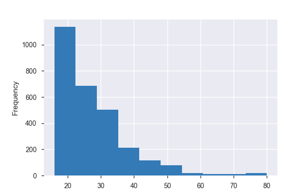

**Common Values**

| Value | Count | Frequency (%) |  |
| --- | --- | --- | --- |
| 16.0 | 437 | 0.6% |  |
| 20.0 | 222 | 0.3% |  |
| 28.0 | 133 | 0.2% |  |
| 24.0 | 133 | 0.2% |  |
| 23.0 | 131 | 0.2% |  |
| 22.0 | 128 | 0.2% |  |
| 19.0 | 127 | 0.2% |  |
| 25.0 | 105 | 0.1% |  |
| 26.0 | 95 | 0.1% |  |
| 21.0 | 94 | 0.1% |  |
| Other values (52) | 1186 | 1.5% |  |
| (Missing) | 74313 | 96.4% |  |

**Extreme Values**

Minimum 5 values

| Value | Count | Frequency (%) |  |
| --- | --- | --- | --- |
| 16.0 | 437 | 0.6% |  |
| 17.0 | 48 | 0.1% |  |
| 18.0 | 80 | 0.1% |  |
| 19.0 | 127 | 0.2% |  |
| 20.0 | 222 | 0.3% |  |

Maximum 5 values

| Value | Count | Frequency (%) |  |
| --- | --- | --- | --- |
| 76.0 | 3 | 0.0% |  |
| 77.0 | 2 | 0.0% |  |
| 78.0 | 1 | 0.0% |  |
| 79.0 | 5 | 0.0% |  |
| 80.0 | 6 | 0.0% |  |

v17onaanwokl  
Categorical

| Distinct count | 5 |
| --- | --- |
| Unique (%) | 0.0% |
| Missing (%) | 96.0% |
| Missing (n) | 74051 |

| matig | 1385 |
| --- | --- |
| ernstig | 969 |
| geen | 437 |
| (Missing) | 74051 |

Toggle details

| Value | Count | Frequency (%) |  |
| --- | --- | --- | --- |
| matig | 1385 | 1.8% |  |
| ernstig | 969 | 1.3% |  |
| geen | 437 | 0.6% |  |
| 99 | 262 | 0.3% |  |
| (Missing) | 74051 | 96.0% |  |

v18_1  
Categorical

| Distinct count | 3 |
| --- | --- |
| Unique (%) | 0.0% |
| Missing (%) | 0.0% |
| Missing (n) | 0 |

| ja | 74112 |
| --- | --- |
| neen | 1986 |
| 99 | 1006 |

Toggle details

| Value | Count | Frequency (%) |  |
| --- | --- | --- | --- |
| ja | 74112 | 96.1% |  |
| neen | 1986 | 2.6% |  |
| 99 | 1006 | 1.3% |  |

v18_2  
Categorical

| Distinct count | 3 |
| --- | --- |
| Unique (%) | 0.0% |
| Missing (%) | 0.0% |
| Missing (n) | 0 |

| ja | 63178 |
| --- | --- |
| neen | 12920 |
| 99 | 1006 |

Toggle details

| Value | Count | Frequency (%) |  |
| --- | --- | --- | --- |
| ja | 63178 | 81.9% |  |
| neen | 12920 | 16.8% |  |
| 99 | 1006 | 1.3% |  |

v18_3  
Categorical

| Distinct count | 3 |
| --- | --- |
| Unique (%) | 0.0% |
| Missing (%) | 0.0% |
| Missing (n) | 0 |

| ja | 73560 |
| --- | --- |
| neen | 2538 |
| 99 | 1006 |

Toggle details

| Value | Count | Frequency (%) |  |
| --- | --- | --- | --- |
| ja | 73560 | 95.4% |  |
| neen | 2538 | 3.3% |  |
| 99 | 1006 | 1.3% |  |

v18_4  
Categorical

| Distinct count | 3 |
| --- | --- |
| Unique (%) | 0.0% |
| Missing (%) | 0.0% |
| Missing (n) | 0 |

| ja | 73137 |
| --- | --- |
| neen | 2961 |
| 99 | 1006 |

Toggle details

| Value | Count | Frequency (%) |  |
| --- | --- | --- | --- |
| ja | 73137 | 94.9% |  |
| neen | 2961 | 3.8% |  |
| 99 | 1006 | 1.3% |  |

v18_5  
Categorical

| Distinct count | 3 |
| --- | --- |
| Unique (%) | 0.0% |
| Missing (%) | 0.0% |
| Missing (n) | 0 |

| neen | 57607 |
| --- | --- |
| ja | 18491 |
| 99 | 1006 |

Toggle details

| Value | Count | Frequency (%) |  |
| --- | --- | --- | --- |
| neen | 57607 | 74.7% |  |
| ja | 18491 | 24.0% |  |
| 99 | 1006 | 1.3% |  |

v19_1  
Categorical

| Distinct count | 6 |
| --- | --- |
| Unique (%) | 0.0% |
| Missing (%) | 0.0% |
| Missing (n) | 0 |

| eerder positief | 23078 |
| --- | --- |
| uiterst positief | 22264 |
| uiterst negatief | 12417 |
| Other values (3) | 19345 |

Toggle details

| Value | Count | Frequency (%) |  |
| --- | --- | --- | --- |
| eerder positief | 23078 | 29.9% |  |
| uiterst positief | 22264 | 28.9% |  |
| uiterst negatief | 12417 | 16.1% |  |
| noch negatief/ noch positief | 11208 | 14.5% |  |
| 99 | 6000 | 7.8% |  |
| eerder negatief | 2137 | 2.8% |  |

v19_2  
Categorical

| Distinct count | 6 |
| --- | --- |
| Unique (%) | 0.0% |
| Missing (%) | 0.0% |
| Missing (n) | 0 |

| uiterst negatief | 27481 |
| --- | --- |
| noch negatief/ noch positief | 17266 |
| eerder positief | 12677 |
| Other values (3) | 19680 |

Toggle details

| Value | Count | Frequency (%) |  |
| --- | --- | --- | --- |
| uiterst negatief | 27481 | 35.6% |  |
| noch negatief/ noch positief | 17266 | 22.4% |  |
| eerder positief | 12677 | 16.4% |  |
| eerder negatief | 6886 | 8.9% |  |
| uiterst positief | 6794 | 8.8% |  |
| 99 | 6000 | 7.8% |  |

v19_3  
Categorical

| Distinct count | 6 |
| --- | --- |
| Unique (%) | 0.0% |
| Missing (%) | 0.0% |
| Missing (n) | 0 |

| uiterst negatief | 46230 |
| --- | --- |
| noch negatief/ noch positief | 10152 |
| eerder negatief | 8362 |
| Other values (3) | 12360 |

Toggle details

| Value | Count | Frequency (%) |  |
| --- | --- | --- | --- |
| uiterst negatief | 46230 | 60.0% |  |
| noch negatief/ noch positief | 10152 | 13.2% |  |
| eerder negatief | 8362 | 10.8% |  |
| 99 | 6000 | 7.8% |  |
| eerder positief | 3751 | 4.9% |  |
| uiterst positief | 2609 | 3.4% |  |

v19_4  
Categorical

| Distinct count | 6 |
| --- | --- |
| Unique (%) | 0.0% |
| Missing (%) | 0.0% |
| Missing (n) | 0 |

| uiterst negatief | 52841 |
| --- | --- |
| eerder negatief | 7536 |
| noch negatief/ noch positief | 7496 |
| Other values (3) | 9231 |

Toggle details

| Value | Count | Frequency (%) |  |
| --- | --- | --- | --- |
| uiterst negatief | 52841 | 68.5% |  |
| eerder negatief | 7536 | 9.8% |  |
| noch negatief/ noch positief | 7496 | 9.7% |  |
| 99 | 6000 | 7.8% |  |
| eerder positief | 2019 | 2.6% |  |
| uiterst positief | 1212 | 1.6% |  |

v19_5  
Categorical

| Distinct count | 6 |
| --- | --- |
| Unique (%) | 0.0% |
| Missing (%) | 0.0% |
| Missing (n) | 0 |

| uiterst negatief | 53623 |
| --- | --- |
| eerder negatief | 7450 |
| noch negatief/ noch positief | 6666 |
| Other values (3) | 9365 |

Toggle details

| Value | Count | Frequency (%) |  |
| --- | --- | --- | --- |
| uiterst negatief | 53623 | 69.5% |  |
| eerder negatief | 7450 | 9.7% |  |
| noch negatief/ noch positief | 6666 | 8.6% |  |
| 99 | 6000 | 7.8% |  |
| uiterst positief | 1846 | 2.4% |  |
| eerder positief | 1519 | 2.0% |  |

v19_6  
Categorical

| Distinct count | 6 |
| --- | --- |
| Unique (%) | 0.0% |
| Missing (%) | 0.0% |
| Missing (n) | 0 |

| uiterst negatief | 52341 |
| --- | --- |
| eerder negatief | 7442 |
| noch negatief/ noch positief | 7254 |
| Other values (3) | 10067 |

Toggle details

| Value | Count | Frequency (%) |  |
| --- | --- | --- | --- |
| uiterst negatief | 52341 | 67.9% |  |
| eerder negatief | 7442 | 9.7% |  |
| noch negatief/ noch positief | 7254 | 9.4% |  |
| 99 | 6000 | 7.8% |  |
| eerder positief | 2629 | 3.4% |  |
| uiterst positief | 1438 | 1.9% |  |

v19_7  
Categorical

| Distinct count | 6 |
| --- | --- |
| Unique (%) | 0.0% |
| Missing (%) | 0.0% |
| Missing (n) | 0 |

| uiterst negatief | 40980 |
| --- | --- |
| noch negatief/ noch positief | 12066 |
| eerder positief | 7085 |
| Other values (3) | 16973 |

Toggle details

| Value | Count | Frequency (%) |  |
| --- | --- | --- | --- |
| uiterst negatief | 40980 | 53.1% |  |
| noch negatief/ noch positief | 12066 | 15.6% |  |
| eerder positief | 7085 | 9.2% |  |
| eerder negatief | 7023 | 9.1% |  |
| 99 | 6000 | 7.8% |  |
| uiterst positief | 3950 | 5.1% |  |

v19verhuisgeneigdheid  
Numeric

| Distinct count | 23 |
| --- | --- |
| Unique (%) | 0.0% |
| Missing (%) | 96.6% |
| Missing (n) | 74511 |
| Infinite (%) | 0.0% |
| Infinite (n) | 0 |

| Mean | 8.2892 |
| --- | --- |
| Minimum | 1 |
| Maximum | 99 |
| Zeros (%) | 0.0% |

Toggle details

**Statistics**

Quantile statistics

| Minimum | 1 |
| --- | --- |
| 5-th percentile | 1 |
| Q1 | 1 |
| Median | 1.4 |
| Q3 | 2.4 |
| 95-th percentile | 99 |
| Maximum | 99 |
| Range | 98 |
| Interquartile range | 1.4 |

Descriptive statistics

| Standard deviation | 24.569 |
| --- | --- |
| Coef of variation | 2.964 |
| Kurtosis | 9.7203 |
| Mean | 8.2892 |
| MAD | 12.384 |
| Skewness | 3.4203 |
| Sum | 21494 |
| Variance | 603.63 |
| Memory size | 602.5 KiB |

**Histogram**

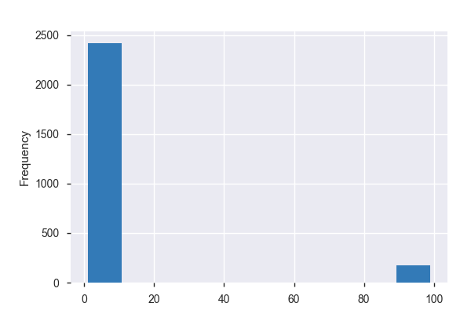

**Common Values**

| Value | Count | Frequency (%) |  |
| --- | --- | --- | --- |
| 1.0 | 1049 | 1.4% |  |
| 1.8 | 203 | 0.3% |  |
| 1.4 | 190 | 0.2% |  |
| 99.0 | 177 | 0.2% |  |
| 2.0 | 139 | 0.2% |  |
| 2.2 | 124 | 0.2% |  |
| 3.0 | 123 | 0.2% |  |
| 1.6 | 118 | 0.2% |  |
| 1.2 | 112 | 0.1% |  |
| 2.4 | 88 | 0.1% |  |
| Other values (12) | 270 | 0.4% |  |
| (Missing) | 74511 | 96.6% |  |

**Extreme Values**

Minimum 5 values

| Value | Count | Frequency (%) |  |
| --- | --- | --- | --- |
| 1.0 | 1049 | 1.4% |  |
| 1.2 | 112 | 0.1% |  |
| 1.4 | 190 | 0.2% |  |
| 1.6 | 118 | 0.2% |  |
| 1.8 | 203 | 0.3% |  |

Maximum 5 values

| Value | Count | Frequency (%) |  |
| --- | --- | --- | --- |
| 4.4 | 1 | 0.0% |  |
| 4.6 | 4 | 0.0% |  |
| 4.8 | 1 | 0.0% |  |
| 5.0 | 14 | 0.0% |  |
| 99.0 | 177 | 0.2% |  |

v2  
Numeric

| Distinct count | 70 |
| --- | --- |
| Unique (%) | 0.1% |
| Missing (%) | 0.2% |
| Missing (n) | 125 |
| Infinite (%) | 0.0% |
| Infinite (n) | 0 |

| Mean | 59.069 |
| --- | --- |
| Minimum | 0 |
| Maximum | 999 |
| Zeros (%) | 3.6% |

Toggle details

**Statistics**

Quantile statistics

| Minimum | 0 |
| --- | --- |
| 5-th percentile | 1 |
| Q1 | 4 |
| Median | 99 |
| Q3 | 99 |
| 95-th percentile | 99 |
| Maximum | 999 |
| Range | 999 |
| Interquartile range | 95 |

Descriptive statistics

| Standard deviation | 46.559 |
| --- | --- |
| Coef of variation | 0.7882 |
| Kurtosis | 0.27565 |
| Mean | 59.069 |
| MAD | 45.711 |
| Skewness | -0.21068 |
| Sum | 4547100 |
| Variance | 2167.7 |
| Memory size | 602.5 KiB |

**Histogram**

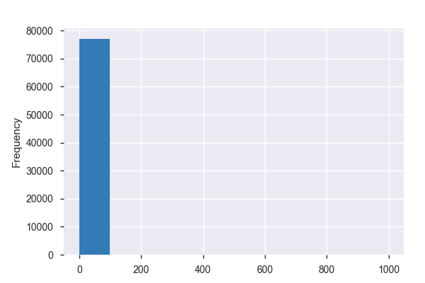

**Common Values**

| Value | Count | Frequency (%) |  |
| --- | --- | --- | --- |
| 99.0 | 44036 | 57.1% |  |
| 1.0 | 6772 | 8.8% |  |
| 2.0 | 5256 | 6.8% |  |
| 3.0 | 4158 | 5.4% |  |
| 0.0 | 2788 | 3.6% |  |
| 4.0 | 2205 | 2.9% |  |
| 5.0 | 1706 | 2.2% |  |
| 7.0 | 1516 | 2.0% |  |
| 6.0 | 1289 | 1.7% |  |
| 8.0 | 784 | 1.0% |  |
| Other values (59) | 6469 | 8.4% |  |

**Extreme Values**

Minimum 5 values

| Value | Count | Frequency (%) |  |
| --- | --- | --- | --- |
| 0.0 | 2788 | 3.6% |  |
| 1.0 | 6772 | 8.8% |  |
| 2.0 | 5256 | 6.8% |  |
| 3.0 | 4158 | 5.4% |  |
| 4.0 | 2205 | 2.9% |  |

Maximum 5 values

| Value | Count | Frequency (%) |  |
| --- | --- | --- | --- |
| 64.0 | 2 | 0.0% |  |
| 65.0 | 3 | 0.0% |  |
| 70.0 | 1 | 0.0% |  |
| 99.0 | 44036 | 57.1% |  |
| 999.0 | 1 | 0.0% |  |

v20  
Categorical

| Distinct count | 4 |
| --- | --- |
| Unique (%) | 0.0% |
| Missing (%) | 0.0% |
| Missing (n) | 0 |

| neen | 64313 |
| --- | --- |
| ja | 10836 |
| 99 | 1859 |

Toggle details

| Value | Count | Frequency (%) |  |
| --- | --- | --- | --- |
| neen | 64313 | 83.4% |  |
| ja | 10836 | 14.1% |  |
| 99 | 1859 | 2.4% |  |
| 999 | 96 | 0.1% |  |

v20bis  
Numeric

| Distinct count | 13 |
| --- | --- |
| Unique (%) | 0.0% |
| Missing (%) | 0.0% |
| Missing (n) | 0 |
| Infinite (%) | 0.0% |
| Infinite (n) | 0 |

| Mean | 122.37 |
| --- | --- |
| Minimum | 0 |
| Maximum | 999 |
| Zeros (%) | 0.3% |

Toggle details

**Statistics**

Quantile statistics

| Minimum | 0 |
| --- | --- |
| 5-th percentile | 3 |
| Q1 | 99 |
| Median | 99 |
| Q3 | 99 |
| 95-th percentile | 99 |
| Maximum | 999 |
| Range | 999 |
| Interquartile range | 0 |

Descriptive statistics

| Standard deviation | 180.15 |
| --- | --- |
| Coef of variation | 1.4722 |
| Kurtosis | 19.083 |
| Mean | 122.37 |
| MAD | 68.967 |
| Skewness | 4.4955 |
| Sum | 9434974 |
| Variance | 32453 |
| Memory size | 602.5 KiB |

**Histogram**

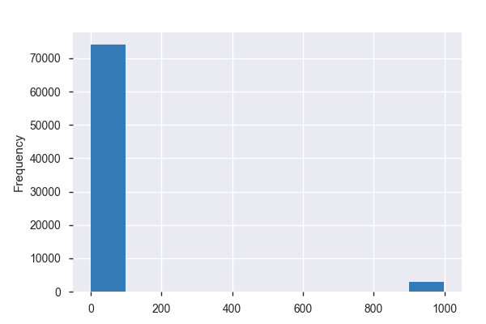

**Common Values**

| Value | Count | Frequency (%) |  |
| --- | --- | --- | --- |
| 99 | 64230 | 83.3% |  |
| 999 | 3033 | 3.9% |  |
| 2 | 1333 | 1.7% |  |
| 3 | 1194 | 1.5% |  |
| 5 | 1129 | 1.5% |  |
| 1 | 1112 | 1.4% |  |
| 4 | 1062 | 1.4% |  |
| 6 | 1030 | 1.3% |  |
| 8 | 876 | 1.1% |  |
| 7 | 795 | 1.0% |  |
| Other values (3) | 1310 | 1.7% |  |

**Extreme Values**

Minimum 5 values

| Value | Count | Frequency (%) |  |
| --- | --- | --- | --- |
| 0 | 225 | 0.3% |  |
| 1 | 1112 | 1.4% |  |
| 2 | 1333 | 1.7% |  |
| 3 | 1194 | 1.5% |  |
| 4 | 1062 | 1.4% |  |

Maximum 5 values

| Value | Count | Frequency (%) |  |
| --- | --- | --- | --- |
| 8 | 876 | 1.1% |  |
| 9 | 619 | 0.8% |  |
| 10 | 466 | 0.6% |  |
| 99 | 64230 | 83.3% |  |
| 999 | 3033 | 3.9% |  |

v20postcode  
Numeric

| Distinct count | 113 |
| --- | --- |
| Unique (%) | 0.1% |
| Missing (%) | 0.0% |
| Missing (n) | 0 |
| Infinite (%) | 0.0% |
| Infinite (n) | 0 |

| Mean | 156.07 |
| --- | --- |
| Minimum | 99 |
| Maximum | 45940 |
| Zeros (%) | 0.0% |

Toggle details

**Statistics**

Quantile statistics

| Minimum | 99 |
| --- | --- |
| 5-th percentile | 99 |
| Q1 | 99 |
| Median | 99 |
| Q3 | 99 |
| 95-th percentile | 99 |
| Maximum | 45940 |
| Range | 45841 |
| Interquartile range | 0 |

Descriptive statistics

| Standard deviation | 404.5 |
| --- | --- |
| Coef of variation | 2.5919 |
| Kurtosis | 2338.7 |
| Mean | 156.07 |
| MAD | 108.91 |
| Skewness | 30.1 |
| Sum | 12033272 |
| Variance | 163620 |
| Memory size | 602.5 KiB |

**Histogram**

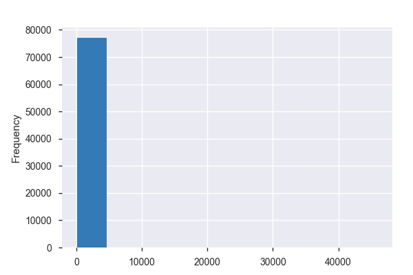

**Common Values**

| Value | Count | Frequency (%) |  |
| --- | --- | --- | --- |
| 99 | 73580 | 95.4% |  |
| 999 | 3094 | 4.0% |  |
| 2200 | 59 | 0.1% |  |
| 8400 | 58 | 0.1% |  |
| 2400 | 35 | 0.0% |  |
| 2480 | 32 | 0.0% |  |
| 2460 | 31 | 0.0% |  |
| 2800 | 18 | 0.0% |  |
| 2860 | 16 | 0.0% |  |
| 3470 | 8 | 0.0% |  |
| Other values (103) | 173 | 0.2% |  |

**Extreme Values**

Minimum 5 values

| Value | Count | Frequency (%) |  |
| --- | --- | --- | --- |
| 99 | 73580 | 95.4% |  |
| 999 | 3094 | 4.0% |  |
| 1000 | 1 | 0.0% |  |
| 1030 | 1 | 0.0% |  |
| 1070 | 1 | 0.0% |  |

Maximum 5 values

| Value | Count | Frequency (%) |  |
| --- | --- | --- | --- |
| 9400 | 1 | 0.0% |  |
| 9470 | 1 | 0.0% |  |
| 9820 | 1 | 0.0% |  |
| 9831 | 1 | 0.0% |  |
| 45940 | 1 | 0.0% |  |

v21_1  
Categorical

| Distinct count | 4 |
| --- | --- |
| Unique (%) | 0.0% |
| Missing (%) | 0.0% |
| Missing (n) | 0 |

| nvt | 64313 |
| --- | --- |
| neen | 8153 |
| 99 | 3711 |

Toggle details

| Value | Count | Frequency (%) |  |
| --- | --- | --- | --- |
| nvt | 64313 | 83.4% |  |
| neen | 8153 | 10.6% |  |
| 99 | 3711 | 4.8% |  |
| ja | 927 | 1.2% |  |

v21_2  
Categorical

| Distinct count | 4 |
| --- | --- |
| Unique (%) | 0.0% |
| Missing (%) | 0.0% |
| Missing (n) | 0 |

| nvt | 64313 |
| --- | --- |
| neen | 8068 |
| 99 | 3711 |

Toggle details

| Value | Count | Frequency (%) |  |
| --- | --- | --- | --- |
| nvt | 64313 | 83.4% |  |
| neen | 8068 | 10.5% |  |
| 99 | 3711 | 4.8% |  |
| ja | 1012 | 1.3% |  |

v21_3  
Categorical

| Distinct count | 4 |
| --- | --- |
| Unique (%) | 0.0% |
| Missing (%) | 0.0% |
| Missing (n) | 0 |

| nvt | 64313 |
| --- | --- |
| neen | 7553 |
| 99 | 3711 |

Toggle details

| Value | Count | Frequency (%) |  |
| --- | --- | --- | --- |
| nvt | 64313 | 83.4% |  |
| neen | 7553 | 9.8% |  |
| 99 | 3711 | 4.8% |  |
| ja | 1527 | 2.0% |  |

v21_4  
Categorical

| Distinct count | 4 |
| --- | --- |
| Unique (%) | 0.0% |
| Missing (%) | 0.0% |
| Missing (n) | 0 |

| nvt | 64313 |
| --- | --- |
| neen | 6857 |
| 99 | 3711 |

Toggle details

| Value | Count | Frequency (%) |  |
| --- | --- | --- | --- |
| nvt | 64313 | 83.4% |  |
| neen | 6857 | 8.9% |  |
| 99 | 3711 | 4.8% |  |
| ja | 2223 | 2.9% |  |

v21_5  
Categorical

| Distinct count | 4 |
| --- | --- |
| Unique (%) | 0.0% |
| Missing (%) | 0.0% |
| Missing (n) | 0 |

| nvt | 64313 |
| --- | --- |
| neen | 6688 |
| 99 | 3711 |

Toggle details

| Value | Count | Frequency (%) |  |
| --- | --- | --- | --- |
| nvt | 64313 | 83.4% |  |
| neen | 6688 | 8.7% |  |
| 99 | 3711 | 4.8% |  |
| ja | 2392 | 3.1% |  |

v21_6  
Categorical

| Distinct count | 4 |
| --- | --- |
| Unique (%) | 0.0% |
| Missing (%) | 0.0% |
| Missing (n) | 0 |

| nvt | 64313 |
| --- | --- |
| neen | 7837 |
| 99 | 3711 |

Toggle details

| Value | Count | Frequency (%) |  |
| --- | --- | --- | --- |
| nvt | 64313 | 83.4% |  |
| neen | 7837 | 10.2% |  |
| 99 | 3711 | 4.8% |  |
| ja | 1243 | 1.6% |  |

v21_7  
Categorical

| Distinct count | 4 |
| --- | --- |
| Unique (%) | 0.0% |
| Missing (%) | 0.0% |
| Missing (n) | 0 |

| nvt | 64313 |
| --- | --- |
| neen | 7321 |
| 99 | 3711 |

Toggle details

| Value | Count | Frequency (%) |  |
| --- | --- | --- | --- |
| nvt | 64313 | 83.4% |  |
| neen | 7321 | 9.5% |  |
| 99 | 3711 | 4.8% |  |
| ja | 1759 | 2.3% |  |

v21_8  
Categorical

| Distinct count | 4 |
| --- | --- |
| Unique (%) | 0.0% |
| Missing (%) | 0.0% |
| Missing (n) | 0 |

| nvt | 64313 |
| --- | --- |
| neen | 5561 |
| 99 | 3711 |

Toggle details

| Value | Count | Frequency (%) |  |
| --- | --- | --- | --- |
| nvt | 64313 | 83.4% |  |
| neen | 5561 | 7.2% |  |
| 99 | 3711 | 4.8% |  |
| ja | 3519 | 4.6% |  |

v21_9  
Categorical

| Distinct count | 4 |
| --- | --- |
| Unique (%) | 0.0% |
| Missing (%) | 0.0% |
| Missing (n) | 0 |

| nvt | 64313 |
| --- | --- |
| neen | 7954 |
| 99 | 3711 |

Toggle details

| Value | Count | Frequency (%) |  |
| --- | --- | --- | --- |
| nvt | 64313 | 83.4% |  |
| neen | 7954 | 10.3% |  |
| 99 | 3711 | 4.8% |  |
| ja | 1126 | 1.5% |  |

v22  
Categorical

| Distinct count | 6 |
| --- | --- |
| Unique (%) | 0.0% |
| Missing (%) | 0.0% |
| Missing (n) | 0 |

| enkele keren wk | 37390 |
| --- | --- |
| enkele keren mnd | 14965 |
| 1x wk | 10628 |
| Other values (3) | 14121 |

Toggle details

| Value | Count | Frequency (%) |  |
| --- | --- | --- | --- |
| enkele keren wk | 37390 | 48.5% |  |
| enkele keren mnd | 14965 | 19.4% |  |
| 1x wk | 10628 | 13.8% |  |
| <=1x mnd | 7117 | 9.2% |  |
| 99 | 3561 | 4.6% |  |
| nooit | 3443 | 4.5% |  |

v23  
Categorical

| Distinct count | 6 |
| --- | --- |
| Unique (%) | 0.0% |
| Missing (%) | 0.0% |
| Missing (n) | 0 |

| eerder positief | 35744 |
| --- | --- |
| uiterst positief | 24435 |
| noch negatief/ noch positief | 9596 |
| Other values (3) | 7329 |

Toggle details

| Value | Count | Frequency (%) |  |
| --- | --- | --- | --- |
| eerder positief | 35744 | 46.4% |  |
| uiterst positief | 24435 | 31.7% |  |
| noch negatief/ noch positief | 9596 | 12.4% |  |
| 99 | 5782 | 7.5% |  |
| uiterst negatief | 845 | 1.1% |  |
| eerder negatief | 702 | 0.9% |  |

v24  
Categorical

| Distinct count | 6 |
| --- | --- |
| Unique (%) | 0.0% |
| Missing (%) | 0.0% |
| Missing (n) | 0 |

| nooit | 26498 |
| --- | --- |
| enkele keren per week of meer | 20339 |
| enkele keren per maand | 12714 |
| Other values (3) | 17553 |

Toggle details

| Value | Count | Frequency (%) |  |
| --- | --- | --- | --- |
| nooit | 26498 | 34.4% |  |
| enkele keren per week of meer | 20339 | 26.4% |  |
| enkele keren per maand | 12714 | 16.5% |  |
| één keer per maand of minder | 8270 | 10.7% |  |
| één keer per week | 6546 | 8.5% |  |
| 99 | 2737 | 3.5% |  |

v25  
Categorical

| Distinct count | 6 |
| --- | --- |
| Unique (%) | 0.0% |
| Missing (%) | 0.0% |
| Missing (n) | 0 |

| eerder prettig | 35580 |
| --- | --- |
| erg prettig | 23877 |
| noch onprettig/ noch prettig | 11993 |
| Other values (3) | 5654 |

Toggle details

| Value | Count | Frequency (%) |  |
| --- | --- | --- | --- |
| eerder prettig | 35580 | 46.1% |  |
| erg prettig | 23877 | 31.0% |  |
| noch onprettig/ noch prettig | 11993 | 15.6% |  |
| 99 | 3191 | 4.1% |  |
| eerder onprettig | 1257 | 1.6% |  |
| helemaal niet prettig | 1206 | 1.6% |  |

v26  
Categorical

| Distinct count | 6 |
| --- | --- |
| Unique (%) | 0.0% |
| Missing (%) | 0.0% |
| Missing (n) | 0 |

| gaat wel | 25836 |
| --- | --- |
| betrokken | 17516 |
| niet zo betrokken | 13889 |
| Other values (3) | 19863 |

Toggle details

| Value | Count | Frequency (%) |  |
| --- | --- | --- | --- |
| gaat wel | 25836 | 33.5% |  |
| betrokken | 17516 | 22.7% |  |
| niet zo betrokken | 13889 | 18.0% |  |
| helemaal niet betrokken | 10621 | 13.8% |  |
| zeer betrokken | 5322 | 6.9% |  |
| 99 | 3920 | 5.1% |  |

v27_1  
Categorical

| Distinct count | 3 |
| --- | --- |
| Unique (%) | 0.0% |
| Missing (%) | 0.0% |
| Missing (n) | 0 |

| neen | 52115 |
| --- | --- |
| ja | 15586 |
| 99 | 9403 |

Toggle details

| Value | Count | Frequency (%) |  |
| --- | --- | --- | --- |
| neen | 52115 | 67.6% |  |
| ja | 15586 | 20.2% |  |
| 99 | 9403 | 12.2% |  |

v27_10  
Categorical

| Distinct count | 3 |
| --- | --- |
| Unique (%) | 0.0% |
| Missing (%) | 0.0% |
| Missing (n) | 0 |

| neen | 62652 |
| --- | --- |
| 99 | 9403 |
| ja | 5049 |

Toggle details

| Value | Count | Frequency (%) |  |
| --- | --- | --- | --- |
| neen | 62652 | 81.3% |  |
| 99 | 9403 | 12.2% |  |
| ja | 5049 | 6.5% |  |

v27_11  
Categorical

| Distinct count | 3 |
| --- | --- |
| Unique (%) | 0.0% |
| Missing (%) | 0.0% |
| Missing (n) | 0 |

| neen | 64176 |
| --- | --- |
| 99 | 9403 |
| ja | 3525 |

Toggle details

| Value | Count | Frequency (%) |  |
| --- | --- | --- | --- |
| neen | 64176 | 83.2% |  |
| 99 | 9403 | 12.2% |  |
| ja | 3525 | 4.6% |  |

v27_12  
Categorical

| Distinct count | 3 |
| --- | --- |
| Unique (%) | 0.0% |
| Missing (%) | 0.0% |
| Missing (n) | 0 |

| neen | 54431 |
| --- | --- |
| ja | 13270 |
| 99 | 9403 |

Toggle details

| Value | Count | Frequency (%) |  |
| --- | --- | --- | --- |
| neen | 54431 | 70.6% |  |
| ja | 13270 | 17.2% |  |
| 99 | 9403 | 12.2% |  |

v27_2  
Categorical

| Distinct count | 3 |
| --- | --- |
| Unique (%) | 0.0% |
| Missing (%) | 0.0% |
| Missing (n) | 0 |

| neen | 41363 |
| --- | --- |
| ja | 26337 |
| 99 | 9404 |

Toggle details

| Value | Count | Frequency (%) |  |
| --- | --- | --- | --- |
| neen | 41363 | 53.6% |  |
| ja | 26337 | 34.2% |  |
| 99 | 9404 | 12.2% |  |

v27_3  
Categorical

| Distinct count | 3 |
| --- | --- |
| Unique (%) | 0.0% |
| Missing (%) | 0.0% |
| Missing (n) | 0 |

| neen | 51678 |
| --- | --- |
| ja | 16023 |
| 99 | 9403 |

Toggle details

| Value | Count | Frequency (%) |  |
| --- | --- | --- | --- |
| neen | 51678 | 67.0% |  |
| ja | 16023 | 20.8% |  |
| 99 | 9403 | 12.2% |  |

v27_4  
Categorical

| Distinct count | 3 |
| --- | --- |
| Unique (%) | 0.0% |
| Missing (%) | 0.0% |
| Missing (n) | 0 |

| neen | 56547 |
| --- | --- |
| ja | 11154 |
| 99 | 9403 |

Toggle details

| Value | Count | Frequency (%) |  |
| --- | --- | --- | --- |
| neen | 56547 | 73.3% |  |
| ja | 11154 | 14.5% |  |
| 99 | 9403 | 12.2% |  |

v27_5  
Categorical

| Distinct count | 3 |
| --- | --- |
| Unique (%) | 0.0% |
| Missing (%) | 0.0% |
| Missing (n) | 0 |

| neen | 55092 |
| --- | --- |
| ja | 12609 |
| 99 | 9403 |

Toggle details

| Value | Count | Frequency (%) |  |
| --- | --- | --- | --- |
| neen | 55092 | 71.5% |  |
| ja | 12609 | 16.4% |  |
| 99 | 9403 | 12.2% |  |

v27_6  
Categorical

| Distinct count | 3 |
| --- | --- |
| Unique (%) | 0.0% |
| Missing (%) | 0.0% |
| Missing (n) | 0 |

| neen | 64513 |
| --- | --- |
| 99 | 9403 |
| ja | 3188 |

Toggle details

| Value | Count | Frequency (%) |  |
| --- | --- | --- | --- |
| neen | 64513 | 83.7% |  |
| 99 | 9403 | 12.2% |  |
| ja | 3188 | 4.1% |  |

v27_7  
Categorical

| Distinct count | 3 |
| --- | --- |
| Unique (%) | 0.0% |
| Missing (%) | 0.0% |
| Missing (n) | 0 |

| neen | 62332 |
| --- | --- |
| 99 | 9403 |
| ja | 5369 |

Toggle details

| Value | Count | Frequency (%) |  |
| --- | --- | --- | --- |
| neen | 62332 | 80.8% |  |
| 99 | 9403 | 12.2% |  |
| ja | 5369 | 7.0% |  |

v27_8  
Categorical

| Distinct count | 3 |
| --- | --- |
| Unique (%) | 0.0% |
| Missing (%) | 0.0% |
| Missing (n) | 0 |

| neen | 62482 |
| --- | --- |
| 99 | 9403 |
| ja | 5219 |

Toggle details

| Value | Count | Frequency (%) |  |
| --- | --- | --- | --- |
| neen | 62482 | 81.0% |  |
| 99 | 9403 | 12.2% |  |
| ja | 5219 | 6.8% |  |

v27_9  
Categorical

| Distinct count | 3 |
| --- | --- |
| Unique (%) | 0.0% |
| Missing (%) | 0.0% |
| Missing (n) | 0 |

| neen | 63834 |
| --- | --- |
| 99 | 9403 |
| ja | 3867 |

Toggle details

| Value | Count | Frequency (%) |  |
| --- | --- | --- | --- |
| neen | 63834 | 82.8% |  |
| 99 | 9403 | 12.2% |  |
| ja | 3867 | 5.0% |  |

v28_1  
Categorical

| Distinct count | 3 |
| --- | --- |
| Unique (%) | 0.0% |
| Missing (%) | 0.0% |
| Missing (n) | 0 |

| neen | 41570 |
| --- | --- |
| ja | 24865 |
| 99 | 10669 |

Toggle details

| Value | Count | Frequency (%) |  |
| --- | --- | --- | --- |
| neen | 41570 | 53.9% |  |
| ja | 24865 | 32.2% |  |
| 99 | 10669 | 13.8% |  |

v28_10  
Categorical

| Distinct count | 3 |
| --- | --- |
| Unique (%) | 0.0% |
| Missing (%) | 0.0% |
| Missing (n) | 0 |

| neen | 48732 |
| --- | --- |
| ja | 17703 |
| 99 | 10669 |

Toggle details

| Value | Count | Frequency (%) |  |
| --- | --- | --- | --- |
| neen | 48732 | 63.2% |  |
| ja | 17703 | 23.0% |  |
| 99 | 10669 | 13.8% |  |

v28_11  
Categorical

| Distinct count | 3 |
| --- | --- |
| Unique (%) | 0.0% |
| Missing (%) | 0.0% |
| Missing (n) | 0 |

| neen | 47675 |
| --- | --- |
| ja | 18760 |
| 99 | 10669 |

Toggle details

| Value | Count | Frequency (%) |  |
| --- | --- | --- | --- |
| neen | 47675 | 61.8% |  |
| ja | 18760 | 24.3% |  |
| 99 | 10669 | 13.8% |  |

v28_12  
Categorical

| Distinct count | 3 |
| --- | --- |
| Unique (%) | 0.0% |
| Missing (%) | 0.0% |
| Missing (n) | 0 |

| neen | 49704 |
| --- | --- |
| ja | 16731 |
| 99 | 10669 |

Toggle details

| Value | Count | Frequency (%) |  |
| --- | --- | --- | --- |
| neen | 49704 | 64.5% |  |
| ja | 16731 | 21.7% |  |
| 99 | 10669 | 13.8% |  |

v28_13  
Categorical

| Distinct count | 3 |
| --- | --- |
| Unique (%) | 0.0% |
| Missing (%) | 0.0% |
| Missing (n) | 0 |

| neen | 46257 |
| --- | --- |
| ja | 20178 |
| 99 | 10669 |

Toggle details

| Value | Count | Frequency (%) |  |
| --- | --- | --- | --- |
| neen | 46257 | 60.0% |  |
| ja | 20178 | 26.2% |  |
| 99 | 10669 | 13.8% |  |

v28_14  
Categorical

| Distinct count | 3 |
| --- | --- |
| Unique (%) | 0.0% |
| Missing (%) | 0.0% |
| Missing (n) | 0 |

| neen | 51080 |
| --- | --- |
| ja | 15355 |
| 99 | 10669 |

Toggle details

| Value | Count | Frequency (%) |  |
| --- | --- | --- | --- |
| neen | 51080 | 66.2% |  |
| ja | 15355 | 19.9% |  |
| 99 | 10669 | 13.8% |  |

v28_15  
Categorical

| Distinct count | 3 |
| --- | --- |
| Unique (%) | 0.0% |
| Missing (%) | 0.0% |
| Missing (n) | 0 |

| neen | 50497 |
| --- | --- |
| ja | 15938 |
| 99 | 10669 |

Toggle details

| Value | Count | Frequency (%) |  |
| --- | --- | --- | --- |
| neen | 50497 | 65.5% |  |
| ja | 15938 | 20.7% |  |
| 99 | 10669 | 13.8% |  |

v28_16  
Categorical

| Distinct count | 3 |
| --- | --- |
| Unique (%) | 0.0% |
| Missing (%) | 0.0% |
| Missing (n) | 0 |

| neen | 53467 |
| --- | --- |
| ja | 12968 |
| 99 | 10669 |

Toggle details

| Value | Count | Frequency (%) |  |
| --- | --- | --- | --- |
| neen | 53467 | 69.3% |  |
| ja | 12968 | 16.8% |  |
| 99 | 10669 | 13.8% |  |

v28_17  
Categorical

| Distinct count | 3 |
| --- | --- |
| Unique (%) | 0.0% |
| Missing (%) | 0.0% |
| Missing (n) | 0 |

| neen | 48122 |
| --- | --- |
| ja | 18313 |
| 99 | 10669 |

Toggle details

| Value | Count | Frequency (%) |  |
| --- | --- | --- | --- |
| neen | 48122 | 62.4% |  |
| ja | 18313 | 23.8% |  |
| 99 | 10669 | 13.8% |  |

v28_18  
Categorical

| Distinct count | 3 |
| --- | --- |
| Unique (%) | 0.0% |
| Missing (%) | 0.0% |
| Missing (n) | 0 |

| neen | 45804 |
| --- | --- |
| ja | 20631 |
| 99 | 10669 |

Toggle details

| Value | Count | Frequency (%) |  |
| --- | --- | --- | --- |
| neen | 45804 | 59.4% |  |
| ja | 20631 | 26.8% |  |
| 99 | 10669 | 13.8% |  |

v28_19  
Categorical

| Distinct count | 3 |
| --- | --- |
| Unique (%) | 0.0% |
| Missing (%) | 0.0% |
| Missing (n) | 0 |

| neen | 47292 |
| --- | --- |
| ja | 19143 |
| 99 | 10669 |

Toggle details

| Value | Count | Frequency (%) |  |
| --- | --- | --- | --- |
| neen | 47292 | 61.3% |  |
| ja | 19143 | 24.8% |  |
| 99 | 10669 | 13.8% |  |

v28_2  
Categorical

| Distinct count | 3 |
| --- | --- |
| Unique (%) | 0.0% |
| Missing (%) | 0.0% |
| Missing (n) | 0 |

| neen | 45012 |
| --- | --- |
| ja | 21423 |
| 99 | 10669 |

Toggle details

| Value | Count | Frequency (%) |  |
| --- | --- | --- | --- |
| neen | 45012 | 58.4% |  |
| ja | 21423 | 27.8% |  |
| 99 | 10669 | 13.8% |  |

v28_20  
Categorical

| Distinct count | 3 |
| --- | --- |
| Unique (%) | 0.0% |
| Missing (%) | 0.0% |
| Missing (n) | 0 |

| neen | 44569 |
| --- | --- |
| ja | 21866 |
| 99 | 10669 |

Toggle details

| Value | Count | Frequency (%) |  |
| --- | --- | --- | --- |
| neen | 44569 | 57.8% |  |
| ja | 21866 | 28.4% |  |
| 99 | 10669 | 13.8% |  |

v28_21  
Categorical

| Distinct count | 3 |
| --- | --- |
| Unique (%) | 0.0% |
| Missing (%) | 0.0% |
| Missing (n) | 0 |

| neen | 52248 |
| --- | --- |
| ja | 14187 |
| 99 | 10669 |

Toggle details

| Value | Count | Frequency (%) |  |
| --- | --- | --- | --- |
| neen | 52248 | 67.8% |  |
| ja | 14187 | 18.4% |  |
| 99 | 10669 | 13.8% |  |

v28_22  
Categorical

| Distinct count | 3 |
| --- | --- |
| Unique (%) | 0.0% |
| Missing (%) | 0.0% |
| Missing (n) | 0 |

| neen | 50884 |
| --- | --- |
| ja | 15551 |
| 99 | 10669 |

Toggle details

| Value | Count | Frequency (%) |  |
| --- | --- | --- | --- |
| neen | 50884 | 66.0% |  |
| ja | 15551 | 20.2% |  |
| 99 | 10669 | 13.8% |  |

v28_23  
Categorical

| Distinct count | 3 |
| --- | --- |
| Unique (%) | 0.0% |
| Missing (%) | 0.0% |
| Missing (n) | 0 |

| neen | 49222 |
| --- | --- |
| ja | 17213 |
| 99 | 10669 |

Toggle details

| Value | Count | Frequency (%) |  |
| --- | --- | --- | --- |
| neen | 49222 | 63.8% |  |
| ja | 17213 | 22.3% |  |
| 99 | 10669 | 13.8% |  |

v28_3  
Categorical

| Distinct count | 3 |
| --- | --- |
| Unique (%) | 0.0% |
| Missing (%) | 0.0% |
| Missing (n) | 0 |

| neen | 50241 |
| --- | --- |
| ja | 16194 |
| 99 | 10669 |

Toggle details

| Value | Count | Frequency (%) |  |
| --- | --- | --- | --- |
| neen | 50241 | 65.2% |  |
| ja | 16194 | 21.0% |  |
| 99 | 10669 | 13.8% |  |

v28_4  
Categorical

| Distinct count | 3 |
| --- | --- |
| Unique (%) | 0.0% |
| Missing (%) | 0.0% |
| Missing (n) | 0 |

| neen | 51770 |
| --- | --- |
| ja | 14665 |
| 99 | 10669 |

Toggle details

| Value | Count | Frequency (%) |  |
| --- | --- | --- | --- |
| neen | 51770 | 67.1% |  |
| ja | 14665 | 19.0% |  |
| 99 | 10669 | 13.8% |  |

v28_5  
Categorical

| Distinct count | 3 |
| --- | --- |
| Unique (%) | 0.0% |
| Missing (%) | 0.0% |
| Missing (n) | 0 |

| neen | 46947 |
| --- | --- |
| ja | 19488 |
| 99 | 10669 |

Toggle details

| Value | Count | Frequency (%) |  |
| --- | --- | --- | --- |
| neen | 46947 | 60.9% |  |
| ja | 19488 | 25.3% |  |
| 99 | 10669 | 13.8% |  |

v28_6  
Categorical

| Distinct count | 3 |
| --- | --- |
| Unique (%) | 0.0% |
| Missing (%) | 0.0% |
| Missing (n) | 0 |

| neen | 48746 |
| --- | --- |
| ja | 17689 |
| 99 | 10669 |

Toggle details

| Value | Count | Frequency (%) |  |
| --- | --- | --- | --- |
| neen | 48746 | 63.2% |  |
| ja | 17689 | 22.9% |  |
| 99 | 10669 | 13.8% |  |

v28_7  
Categorical

| Distinct count | 3 |
| --- | --- |
| Unique (%) | 0.0% |
| Missing (%) | 0.0% |
| Missing (n) | 0 |

| neen | 40364 |
| --- | --- |
| ja | 26071 |
| 99 | 10669 |

Toggle details

| Value | Count | Frequency (%) |  |
| --- | --- | --- | --- |
| neen | 40364 | 52.4% |  |
| ja | 26071 | 33.8% |  |
| 99 | 10669 | 13.8% |  |

v28_8  
Categorical

| Distinct count | 3 |
| --- | --- |
| Unique (%) | 0.0% |
| Missing (%) | 0.0% |
| Missing (n) | 0 |

| neen | 37938 |
| --- | --- |
| ja | 28497 |
| 99 | 10669 |

Toggle details

| Value | Count | Frequency (%) |  |
| --- | --- | --- | --- |
| neen | 37938 | 49.2% |  |
| ja | 28497 | 37.0% |  |
| 99 | 10669 | 13.8% |  |

v28_9  
Categorical

| Distinct count | 3 |
| --- | --- |
| Unique (%) | 0.0% |
| Missing (%) | 0.0% |
| Missing (n) | 0 |

| neen | 48213 |
| --- | --- |
| ja | 18222 |
| 99 | 10669 |

Toggle details

| Value | Count | Frequency (%) |  |
| --- | --- | --- | --- |
| neen | 48213 | 62.5% |  |
| ja | 18222 | 23.6% |  |
| 99 | 10669 | 13.8% |  |

v29  
Categorical

| Distinct count | 6 |
| --- | --- |
| Unique (%) | 0.0% |
| Missing (%) | 0.0% |
| Missing (n) | 0 |

| gaat wel | 27507 |
| --- | --- |
| voldoende | 16996 |
| onvoldoende | 13591 |
| Other values (3) | 19010 |

Toggle details

| Value | Count | Frequency (%) |  |
| --- | --- | --- | --- |
| gaat wel | 27507 | 35.7% |  |
| voldoende | 16996 | 22.0% |  |
| onvoldoende | 13591 | 17.6% |  |
| 99 | 8444 | 11.0% |  |
| ruim onvoldoende | 6498 | 8.4% |  |
| ruim voldoende | 4068 | 5.3% |  |

v3  
Numeric

| Distinct count | 49 |
| --- | --- |
| Unique (%) | 0.1% |
| Missing (%) | 0.0% |
| Missing (n) | 12 |
| Infinite (%) | 0.0% |
| Infinite (n) | 0 |

| Mean | 79.631 |
| --- | --- |
| Minimum | 59 |
| Maximum | 999 |
| Zeros (%) | 0.0% |

Toggle details

**Statistics**

Quantile statistics

| Minimum | 59 |
| --- | --- |
| 5-th percentile | 60 |
| Q1 | 65 |
| Median | 71 |
| Q3 | 77 |
| 95-th percentile | 86 |
| Maximum | 999 |
| Range | 940 |
| Interquartile range | 12 |

Descriptive statistics

| Standard deviation | 86.509 |
| --- | --- |
| Coef of variation | 1.0864 |
| Kurtosis | 108.04 |
| Mean | 79.631 |
| MAD | 17.562 |
| Skewness | 10.445 |
| Sum | 6138900 |
| Variance | 7483.8 |
| Memory size | 602.5 KiB |

**Histogram**

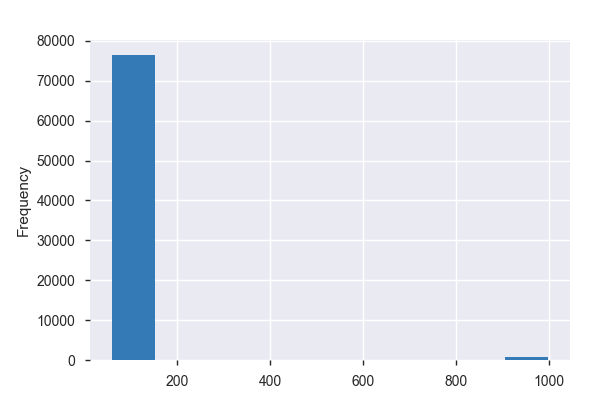

**Common Values**

| Value | Count | Frequency (%) |  |
| --- | --- | --- | --- |
| 60.0 | 3928 | 5.1% |  |
| 62.0 | 3723 | 4.8% |  |
| 65.0 | 3666 | 4.8% |  |
| 69.0 | 3386 | 4.4% |  |
| 63.0 | 3370 | 4.4% |  |
| 67.0 | 3358 | 4.4% |  |
| 68.0 | 3336 | 4.3% |  |
| 70.0 | 3323 | 4.3% |  |
| 61.0 | 3283 | 4.3% |  |
| 66.0 | 3256 | 4.2% |  |
| Other values (38) | 42463 | 55.1% |  |

**Extreme Values**

Minimum 5 values

| Value | Count | Frequency (%) |  |
| --- | --- | --- | --- |
| 59.0 | 4 | 0.0% |  |
| 60.0 | 3928 | 5.1% |  |
| 61.0 | 3283 | 4.3% |  |
| 62.0 | 3723 | 4.8% |  |
| 63.0 | 3370 | 4.4% |  |

Maximum 5 values

| Value | Count | Frequency (%) |  |
| --- | --- | --- | --- |
| 102.0 | 6 | 0.0% |  |
| 103.0 | 1 | 0.0% |  |
| 104.0 | 2 | 0.0% |  |
| 107.0 | 1 | 0.0% |  |
| 999.0 | 671 | 0.9% |  |

v30_1  
Categorical

| Distinct count | 6 |
| --- | --- |
| Unique (%) | 0.0% |
| Missing (%) | 0.0% |
| Missing (n) | 0 |

| bijna dagelijks | 27012 |
| --- | --- |
| nooit | 20460 |
| 1 à 2 maal per week | 16596 |
| Other values (3) | 13036 |

Toggle details

| Value | Count | Frequency (%) |  |
| --- | --- | --- | --- |
| bijna dagelijks | 27012 | 35.0% |  |
| nooit | 20460 | 26.5% |  |
| 1 à 2 maal per week | 16596 | 21.5% |  |
| minder dan 1x per maand | 5311 | 6.9% |  |
| maandelijks | 4112 | 5.3% |  |
| 99 | 3613 | 4.7% |  |

v30_2  
Categorical

| Distinct count | 6 |
| --- | --- |
| Unique (%) | 0.0% |
| Missing (%) | 0.0% |
| Missing (n) | 0 |

| bijna dagelijks | 31376 |
| --- | --- |
| 1 à 2 maal per week | 23644 |
| nooit | 13995 |
| Other values (3) | 8089 |

Toggle details

| Value | Count | Frequency (%) |  |
| --- | --- | --- | --- |
| bijna dagelijks | 31376 | 40.7% |  |
| 1 à 2 maal per week | 23644 | 30.7% |  |
| nooit | 13995 | 18.2% |  |
| 99 | 3269 | 4.2% |  |
| maandelijks | 2683 | 3.5% |  |
| minder dan 1x per maand | 2137 | 2.8% |  |

v30_3  
Categorical

| Distinct count | 6 |
| --- | --- |
| Unique (%) | 0.0% |
| Missing (%) | 0.0% |
| Missing (n) | 0 |

| nooit | 32050 |
| --- | --- |
| bijna dagelijks | 18400 |
| 1 à 2 maal per week | 13381 |
| Other values (3) | 13273 |

Toggle details

| Value | Count | Frequency (%) |  |
| --- | --- | --- | --- |
| nooit | 32050 | 41.6% |  |
| bijna dagelijks | 18400 | 23.9% |  |
| 1 à 2 maal per week | 13381 | 17.4% |  |
| minder dan 1x per maand | 5217 | 6.8% |  |
| maandelijks | 4388 | 5.7% |  |
| 99 | 3668 | 4.8% |  |

v30_4  
Categorical

| Distinct count | 6 |
| --- | --- |
| Unique (%) | 0.0% |
| Missing (%) | 0.0% |
| Missing (n) | 0 |

| nooit | 42871 |
| --- | --- |
| minder dan 1x per maand | 12812 |
| maandelijks | 8013 |
| Other values (3) | 13408 |

Toggle details

| Value | Count | Frequency (%) |  |
| --- | --- | --- | --- |
| nooit | 42871 | 55.6% |  |
| minder dan 1x per maand | 12812 | 16.6% |  |
| maandelijks | 8013 | 10.4% |  |
| 1 à 2 maal per week | 7163 | 9.3% |  |
| 99 | 3973 | 5.2% |  |
| bijna dagelijks | 2272 | 2.9% |  |

v30_5  
Categorical

| Distinct count | 6 |
| --- | --- |
| Unique (%) | 0.0% |
| Missing (%) | 0.0% |
| Missing (n) | 0 |

| nooit | 49427 |
| --- | --- |
| minder dan 1x per maand | 17355 |
| maandelijks | 4544 |
| Other values (3) | 5778 |

Toggle details

| Value | Count | Frequency (%) |  |
| --- | --- | --- | --- |
| nooit | 49427 | 64.1% |  |
| minder dan 1x per maand | 17355 | 22.5% |  |
| maandelijks | 4544 | 5.9% |  |
| 99 | 4230 | 5.5% |  |
| 1 à 2 maal per week | 1030 | 1.3% |  |
| bijna dagelijks | 518 | 0.7% |  |

v30_6  
Categorical

| Distinct count | 6 |
| --- | --- |
| Unique (%) | 0.0% |
| Missing (%) | 0.0% |
| Missing (n) | 0 |

| nooit | 69045 |
| --- | --- |
| 99 | 4345 |
| minder dan 1x per maand | 2892 |
| Other values (3) | 822 |

Toggle details

| Value | Count | Frequency (%) |  |
| --- | --- | --- | --- |
| nooit | 69045 | 89.5% |  |
| 99 | 4345 | 5.6% |  |
| minder dan 1x per maand | 2892 | 3.8% |  |
| maandelijks | 461 | 0.6% |  |
| 1 à 2 maal per week | 229 | 0.3% |  |
| bijna dagelijks | 132 | 0.2% |  |

v30_7  
Categorical

| Distinct count | 6 |
| --- | --- |
| Unique (%) | 0.0% |
| Missing (%) | 0.0% |
| Missing (n) | 0 |

| nooit | 68631 |
| --- | --- |
| 99 | 4369 |
| minder dan 1x per maand | 2660 |
| Other values (3) | 1444 |

Toggle details

| Value | Count | Frequency (%) |  |
| --- | --- | --- | --- |
| nooit | 68631 | 89.0% |  |
| 99 | 4369 | 5.7% |  |
| minder dan 1x per maand | 2660 | 3.4% |  |
| maandelijks | 728 | 0.9% |  |
| 1 à 2 maal per week | 491 | 0.6% |  |
| bijna dagelijks | 225 | 0.3% |  |

v30_8  
Categorical

| Distinct count | 6 |
| --- | --- |
| Unique (%) | 0.0% |
| Missing (%) | 0.0% |
| Missing (n) | 0 |

| nooit | 70581 |
| --- | --- |
| 99 | 4296 |
| minder dan 1x per maand | 1199 |
| Other values (3) | 1028 |

Toggle details

| Value | Count | Frequency (%) |  |
| --- | --- | --- | --- |
| nooit | 70581 | 91.5% |  |
| 99 | 4296 | 5.6% |  |
| minder dan 1x per maand | 1199 | 1.6% |  |
| maandelijks | 463 | 0.6% |  |
| 1 à 2 maal per week | 382 | 0.5% |  |
| bijna dagelijks | 183 | 0.2% |  |

v31_1  
Categorical

| Distinct count | 6 |
| --- | --- |
| Unique (%) | 0.0% |
| Missing (%) | 0.0% |
| Missing (n) | 0 |

| helemaal oneens | 17748 |
| --- | --- |
| eens | 17243 |
| noch eens/noch oneens | 16884 |
| Other values (3) | 25229 |

Toggle details

| Value | Count | Frequency (%) |  |
| --- | --- | --- | --- |
| helemaal oneens | 17748 | 23.0% |  |
| eens | 17243 | 22.4% |  |
| noch eens/noch oneens | 16884 | 21.9% |  |
| helemaal eens | 13443 | 17.4% |  |
| oneens | 7952 | 10.3% |  |
| 99 | 3834 | 5.0% |  |

v31_10  
Categorical

| Distinct count | 6 |
| --- | --- |
| Unique (%) | 0.0% |
| Missing (%) | 0.0% |
| Missing (n) | 0 |

| helemaal oneens | 64526 |
| --- | --- |
| 99 | 3833 |
| helemaal eens | 3643 |
| Other values (3) | 5102 |

Toggle details

| Value | Count | Frequency (%) |  |
| --- | --- | --- | --- |
| helemaal oneens | 64526 | 83.7% |  |
| 99 | 3833 | 5.0% |  |
| helemaal eens | 3643 | 4.7% |  |
| eens | 3617 | 4.7% |  |
| noch eens/noch oneens | 1181 | 1.5% |  |
| oneens | 304 | 0.4% |  |

v31_2  
Categorical

| Distinct count | 6 |
| --- | --- |
| Unique (%) | 0.0% |
| Missing (%) | 0.0% |
| Missing (n) | 0 |

| eens | 22745 |
| --- | --- |
| helemaal eens | 20185 |
| helemaal oneens | 13778 |
| Other values (3) | 20396 |

Toggle details

| Value | Count | Frequency (%) |  |
| --- | --- | --- | --- |
| eens | 22745 | 29.5% |  |
| helemaal eens | 20185 | 26.2% |  |
| helemaal oneens | 13778 | 17.9% |  |
| noch eens/noch oneens | 10894 | 14.1% |  |
| oneens | 5669 | 7.4% |  |
| 99 | 3833 | 5.0% |  |

v31_3  
Categorical

| Distinct count | 6 |
| --- | --- |
| Unique (%) | 0.0% |
| Missing (%) | 0.0% |
| Missing (n) | 0 |

| helemaal oneens | 29418 |
| --- | --- |
| noch eens/noch oneens | 16967 |
| oneens | 11607 |
| Other values (3) | 19112 |

Toggle details

| Value | Count | Frequency (%) |  |
| --- | --- | --- | --- |
| helemaal oneens | 29418 | 38.2% |  |
| noch eens/noch oneens | 16967 | 22.0% |  |
| oneens | 11607 | 15.1% |  |
| eens | 8300 | 10.8% |  |
| helemaal eens | 6979 | 9.1% |  |
| 99 | 3833 | 5.0% |  |

v31_4  
Categorical

| Distinct count | 6 |
| --- | --- |
| Unique (%) | 0.0% |
| Missing (%) | 0.0% |
| Missing (n) | 0 |

| eens | 26846 |
| --- | --- |
| helemaal eens | 18643 |
| helemaal oneens | 13154 |
| Other values (3) | 18461 |

Toggle details

| Value | Count | Frequency (%) |  |
| --- | --- | --- | --- |
| eens | 26846 | 34.8% |  |
| helemaal eens | 18643 | 24.2% |  |
| helemaal oneens | 13154 | 17.1% |  |
| noch eens/noch oneens | 9949 | 12.9% |  |
| oneens | 4679 | 6.1% |  |
| 99 | 3833 | 5.0% |  |

v31_5  
Categorical

| Distinct count | 6 |
| --- | --- |
| Unique (%) | 0.0% |
| Missing (%) | 0.0% |
| Missing (n) | 0 |

| eens | 22787 |
| --- | --- |
| helemaal eens | 18293 |
| helemaal oneens | 14567 |
| Other values (3) | 21457 |

Toggle details

| Value | Count | Frequency (%) |  |
| --- | --- | --- | --- |
| eens | 22787 | 29.6% |  |
| helemaal eens | 18293 | 23.7% |  |
| helemaal oneens | 14567 | 18.9% |  |
| noch eens/noch oneens | 12327 | 16.0% |  |
| oneens | 5297 | 6.9% |  |
| 99 | 3833 | 5.0% |  |

v31_6  
Categorical

| Distinct count | 6 |
| --- | --- |
| Unique (%) | 0.0% |
| Missing (%) | 0.0% |
| Missing (n) | 0 |

| helemaal eens | 24809 |
| --- | --- |
| eens | 18790 |
| helemaal oneens | 12386 |
| Other values (3) | 21119 |

Toggle details

| Value | Count | Frequency (%) |  |
| --- | --- | --- | --- |
| helemaal eens | 24809 | 32.2% |  |
| eens | 18790 | 24.4% |  |
| helemaal oneens | 12386 | 16.1% |  |
| noch eens/noch oneens | 11044 | 14.3% |  |
| oneens | 6242 | 8.1% |  |
| 99 | 3833 | 5.0% |  |

v31_7  
Categorical

| Distinct count | 6 |
| --- | --- |
| Unique (%) | 0.0% |
| Missing (%) | 0.0% |
| Missing (n) | 0 |

| eens | 23069 |
| --- | --- |
| helemaal eens | 19408 |
| noch eens/noch oneens | 14305 |
| Other values (3) | 20322 |

Toggle details

| Value | Count | Frequency (%) |  |
| --- | --- | --- | --- |
| eens | 23069 | 29.9% |  |
| helemaal eens | 19408 | 25.2% |  |
| noch eens/noch oneens | 14305 | 18.6% |  |
| helemaal oneens | 12710 | 16.5% |  |
| 99 | 3833 | 5.0% |  |
| oneens | 3779 | 4.9% |  |

v31_8  
Categorical

| Distinct count | 6 |
| --- | --- |
| Unique (%) | 0.0% |
| Missing (%) | 0.0% |
| Missing (n) | 0 |

| helemaal oneens | 17373 |
| --- | --- |
| noch eens/noch oneens | 17145 |
| eens | 17120 |
| Other values (3) | 25466 |

Toggle details

| Value | Count | Frequency (%) |  |
| --- | --- | --- | --- |
| helemaal oneens | 17373 | 22.5% |  |
| noch eens/noch oneens | 17145 | 22.2% |  |
| eens | 17120 | 22.2% |  |
| helemaal eens | 13940 | 18.1% |  |
| oneens | 7693 | 10.0% |  |
| 99 | 3833 | 5.0% |  |

v31_9  
Categorical

| Distinct count | 6 |
| --- | --- |
| Unique (%) | 0.0% |
| Missing (%) | 0.0% |
| Missing (n) | 0 |

| helemaal oneens | 64781 |
| --- | --- |
| 99 | 3833 |
| eens | 3516 |
| Other values (3) | 4974 |

Toggle details

| Value | Count | Frequency (%) |  |
| --- | --- | --- | --- |
| helemaal oneens | 64781 | 84.0% |  |
| 99 | 3833 | 5.0% |  |
| eens | 3516 | 4.6% |  |
| helemaal eens | 3498 | 4.5% |  |
| noch eens/noch oneens | 1095 | 1.4% |  |
| oneens | 381 | 0.5% |  |

v31onveil  
Numeric

| Distinct count | 34 |
| --- | --- |
| Unique (%) | 0.0% |
| Missing (%) | 96.2% |
| Missing (n) | 74161 |
| Infinite (%) | 0.0% |
| Infinite (n) | 0 |

| Mean | 24.818 |
| --- | --- |
| Minimum | 8 |
| Maximum | 40 |
| Zeros (%) | 0.0% |

Toggle details

**Statistics**

Quantile statistics

| Minimum | 8 |
| --- | --- |
| 5-th percentile | 9 |
| Q1 | 20 |
| Median | 26 |
| Q3 | 31 |
| 95-th percentile | 37 |
| Maximum | 40 |
| Range | 32 |
| Interquartile range | 11 |

Descriptive statistics

| Standard deviation | 8.0313 |
| --- | --- |
| Coef of variation | 0.32361 |
| Kurtosis | -0.56085 |
| Mean | 24.818 |
| MAD | 6.5415 |
| Skewness | -0.31868 |
| Sum | 73039 |
| Variance | 64.502 |
| Memory size | 602.5 KiB |

**Histogram**

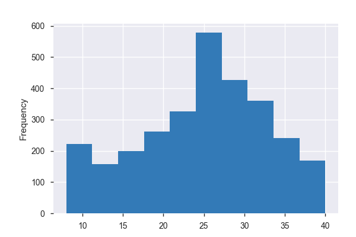

**Common Values**

| Value | Count | Frequency (%) |  |
| --- | --- | --- | --- |
| 28.0 | 158 | 0.2% |  |
| 26.0 | 157 | 0.2% |  |
| 32.0 | 156 | 0.2% |  |
| 29.0 | 148 | 0.2% |  |
| 24.0 | 146 | 0.2% |  |
| 27.0 | 144 | 0.2% |  |
| 8.0 | 139 | 0.2% |  |
| 25.0 | 131 | 0.2% |  |
| 30.0 | 121 | 0.2% |  |
| 23.0 | 118 | 0.2% |  |
| Other values (23) | 1525 | 2.0% |  |
| (Missing) | 74161 | 96.2% |  |

**Extreme Values**

Minimum 5 values

| Value | Count | Frequency (%) |  |
| --- | --- | --- | --- |
| 8.0 | 139 | 0.2% |  |
| 9.0 | 14 | 0.0% |  |
| 10.0 | 24 | 0.0% |  |
| 11.0 | 45 | 0.1% |  |
| 12.0 | 65 | 0.1% |  |

Maximum 5 values

| Value | Count | Frequency (%) |  |
| --- | --- | --- | --- |
| 36.0 | 76 | 0.1% |  |
| 37.0 | 36 | 0.0% |  |
| 38.0 | 41 | 0.1% |  |
| 39.0 | 27 | 0.0% |  |
| 40.0 | 65 | 0.1% |  |

v31onveilkl  
Categorical

| Distinct count | 5 |
| --- | --- |
| Unique (%) | 0.0% |
| Missing (%) | 96.0% |
| Missing (n) | 74051 |

| geen | 1313 |
| --- | --- |
| matig | 971 |
| ernstig | 659 |
| (Missing) | 74051 |

Toggle details

| Value | Count | Frequency (%) |  |
| --- | --- | --- | --- |
| geen | 1313 | 1.7% |  |
| matig | 971 | 1.3% |  |
| ernstig | 659 | 0.9% |  |
| 99 | 110 | 0.1% |  |
| (Missing) | 74051 | 96.0% |  |

v32_1  
Categorical

| Distinct count | 7 |
| --- | --- |
| Unique (%) | 0.0% |
| Missing (%) | 0.0% |
| Missing (n) | 0 |

| 99 | 65536 |
| --- | --- |
| helemaal oneens | 6429 |
| 99 | 4384 |
| Other values (4) | 755 |

Toggle details

| Value | Count | Frequency (%) |  |
| --- | --- | --- | --- |
| 99 | 65536 | 85.0% |  |
| helemaal oneens | 6429 | 8.3% |  |
| 99 | 4384 | 5.7% |  |
| oneens | 286 | 0.4% |  |
| noch eens/noch oneens | 270 | 0.4% |  |
| helemaal eens | 138 | 0.2% |  |
| eens | 61 | 0.1% |  |

v32_2  
Categorical

| Distinct count | 7 |
| --- | --- |
| Unique (%) | 0.0% |
| Missing (%) | 0.0% |
| Missing (n) | 0 |

| 99 | 65536 |
| --- | --- |
| helemaal oneens | 6604 |
| 99 | 4384 |
| Other values (4) | 580 |

Toggle details

| Value | Count | Frequency (%) |  |
| --- | --- | --- | --- |
| 99 | 65536 | 85.0% |  |
| helemaal oneens | 6604 | 8.6% |  |
| 99 | 4384 | 5.7% |  |
| oneens | 254 | 0.3% |  |
| noch eens/noch oneens | 205 | 0.3% |  |
| helemaal eens | 95 | 0.1% |  |
| eens | 26 | 0.0% |  |

v32_3  
Categorical

| Distinct count | 7 |
| --- | --- |
| Unique (%) | 0.0% |
| Missing (%) | 0.0% |
| Missing (n) | 0 |

| 99 | 65536 |
| --- | --- |
| helemaal oneens | 6545 |
| 99 | 4385 |
| Other values (4) | 638 |

Toggle details

| Value | Count | Frequency (%) |  |
| --- | --- | --- | --- |
| 99 | 65536 | 85.0% |  |
| helemaal oneens | 6545 | 8.5% |  |
| 99 | 4385 | 5.7% |  |
| oneens | 267 | 0.3% |  |
| noch eens/noch oneens | 221 | 0.3% |  |
| helemaal eens | 104 | 0.1% |  |
| eens | 46 | 0.1% |  |

v32_4  
Categorical

| Distinct count | 7 |
| --- | --- |
| Unique (%) | 0.0% |
| Missing (%) | 0.0% |
| Missing (n) | 0 |

| 99 | 65536 |
| --- | --- |
| helemaal oneens | 6362 |
| 99 | 4384 |
| Other values (4) | 822 |

Toggle details

| Value | Count | Frequency (%) |  |
| --- | --- | --- | --- |
| 99 | 65536 | 85.0% |  |
| helemaal oneens | 6362 | 8.3% |  |
| 99 | 4384 | 5.7% |  |
| oneens | 308 | 0.4% |  |
| noch eens/noch oneens | 256 | 0.3% |  |
| helemaal eens | 141 | 0.2% |  |
| eens | 117 | 0.2% |  |

v32_5  
Categorical

| Distinct count | 7 |
| --- | --- |
| Unique (%) | 0.0% |
| Missing (%) | 0.0% |
| Missing (n) | 0 |

| 99 | 65536 |
| --- | --- |
| helemaal oneens | 6370 |
| 99 | 4384 |
| Other values (4) | 814 |

Toggle details

| Value | Count | Frequency (%) |  |
| --- | --- | --- | --- |
| 99 | 65536 | 85.0% |  |
| helemaal oneens | 6370 | 8.3% |  |
| 99 | 4384 | 5.7% |  |
| oneens | 345 | 0.4% |  |
| noch eens/noch oneens | 286 | 0.4% |  |
| helemaal eens | 116 | 0.2% |  |
| eens | 67 | 0.1% |  |

v32_6  
Categorical

| Distinct count | 7 |
| --- | --- |
| Unique (%) | 0.0% |
| Missing (%) | 0.0% |
| Missing (n) | 0 |

| 99 | 65536 |
| --- | --- |
| helemaal oneens | 6549 |
| 99 | 4384 |
| Other values (4) | 635 |

Toggle details

| Value | Count | Frequency (%) |  |
| --- | --- | --- | --- |
| 99 | 65536 | 85.0% |  |
| helemaal oneens | 6549 | 8.5% |  |
| 99 | 4384 | 5.7% |  |
| oneens | 285 | 0.4% |  |
| noch eens/noch oneens | 216 | 0.3% |  |
| helemaal eens | 96 | 0.1% |  |
| eens | 38 | 0.0% |  |

v33_1  
Categorical

| Distinct count | 5 |
| --- | --- |
| Unique (%) | 0.0% |
| Missing (%) | 0.0% |
| Missing (n) | 0 |

| helemaal niet | 30073 |
| --- | --- |
| niet meer dan gewoonlijk | 23446 |
| 99 | 13963 |
| Other values (2) | 9622 |

Toggle details

| Value | Count | Frequency (%) |  |
| --- | --- | --- | --- |
| helemaal niet | 30073 | 39.0% |  |
| niet meer dan gewoonlijk | 23446 | 30.4% |  |
| 99 | 13963 | 18.1% |  |
| meer dan gewoonlijk | 6943 | 9.0% |  |
| opvallend meer dan gewoonlijk | 2679 | 3.5% |  |

v33_2  
Categorical

| Distinct count | 5 |
| --- | --- |
| Unique (%) | 0.0% |
| Missing (%) | 0.0% |
| Missing (n) | 0 |

| helemaal niet | 45193 |
| --- | --- |
| 99 | 13963 |
| niet meer dan gewoonlijk | 13603 |
| Other values (2) | 4345 |

Toggle details

| Value | Count | Frequency (%) |  |
| --- | --- | --- | --- |
| helemaal niet | 45193 | 58.6% |  |
| 99 | 13963 | 18.1% |  |
| niet meer dan gewoonlijk | 13603 | 17.6% |  |
| meer dan gewoonlijk | 3162 | 4.1% |  |
| opvallend meer dan gewoonlijk | 1183 | 1.5% |  |

v33_3  
Categorical

| Distinct count | 5 |
| --- | --- |
| Unique (%) | 0.0% |
| Missing (%) | 0.0% |
| Missing (n) | 0 |

| helemaal niet | 44816 |
| --- | --- |
| 99 | 13963 |
| niet meer dan gewoonlijk | 13045 |
| Other values (2) | 5280 |

Toggle details

| Value | Count | Frequency (%) |  |
| --- | --- | --- | --- |
| helemaal niet | 44816 | 58.1% |  |
| 99 | 13963 | 18.1% |  |
| niet meer dan gewoonlijk | 13045 | 16.9% |  |
| meer dan gewoonlijk | 4148 | 5.4% |  |
| opvallend meer dan gewoonlijk | 1132 | 1.5% |  |

v33_4  
Categorical

| Distinct count | 5 |
| --- | --- |
| Unique (%) | 0.0% |
| Missing (%) | 0.0% |
| Missing (n) | 0 |

| helemaal niet | 43797 |
| --- | --- |
| niet meer dan gewoonlijk | 14118 |
| 99 | 13963 |
| Other values (2) | 5226 |

Toggle details

| Value | Count | Frequency (%) |  |
| --- | --- | --- | --- |
| helemaal niet | 43797 | 56.8% |  |
| niet meer dan gewoonlijk | 14118 | 18.3% |  |
| 99 | 13963 | 18.1% |  |
| meer dan gewoonlijk | 3896 | 5.1% |  |
| opvallend meer dan gewoonlijk | 1330 | 1.7% |  |

v33_5  
Categorical

| Distinct count | 5 |
| --- | --- |
| Unique (%) | 0.0% |
| Missing (%) | 0.0% |
| Missing (n) | 0 |

| helemaal niet | 40548 |
| --- | --- |
| niet meer dan gewoonlijk | 16278 |
| 99 | 13963 |
| Other values (2) | 6315 |

Toggle details

| Value | Count | Frequency (%) |  |
| --- | --- | --- | --- |
| helemaal niet | 40548 | 52.6% |  |
| niet meer dan gewoonlijk | 16278 | 21.1% |  |
| 99 | 13963 | 18.1% |  |
| meer dan gewoonlijk | 4700 | 6.1% |  |
| opvallend meer dan gewoonlijk | 1615 | 2.1% |  |

v33_6  
Categorical

| Distinct count | 5 |
| --- | --- |
| Unique (%) | 0.0% |
| Missing (%) | 0.0% |
| Missing (n) | 0 |

| helemaal niet | 46551 |
| --- | --- |
| 99 | 13964 |
| niet meer dan gewoonlijk | 11229 |
| Other values (2) | 5360 |

Toggle details

| Value | Count | Frequency (%) |  |
| --- | --- | --- | --- |
| helemaal niet | 46551 | 60.4% |  |
| 99 | 13964 | 18.1% |  |
| niet meer dan gewoonlijk | 11229 | 14.6% |  |
| meer dan gewoonlijk | 3593 | 4.7% |  |
| opvallend meer dan gewoonlijk | 1767 | 2.3% |  |

v33_7  
Categorical

| Distinct count | 5 |
| --- | --- |
| Unique (%) | 0.0% |
| Missing (%) | 0.0% |
| Missing (n) | 0 |

| helemaal niet | 61668 |
| --- | --- |
| 99 | 13963 |
| niet meer dan gewoonlijk | 1054 |
| Other values (2) | 419 |

Toggle details

| Value | Count | Frequency (%) |  |
| --- | --- | --- | --- |
| helemaal niet | 61668 | 80.0% |  |
| 99 | 13963 | 18.1% |  |
| niet meer dan gewoonlijk | 1054 | 1.4% |  |
| meer dan gewoonlijk | 323 | 0.4% |  |
| opvallend meer dan gewoonlijk | 96 | 0.1% |  |

v34_1  
Categorical

| Distinct count | 6 |
| --- | --- |
| Unique (%) | 0.0% |
| Missing (%) | 0.0% |
| Missing (n) | 0 |

| helemaal oneens | 38301 |
| --- | --- |
| oneens | 11857 |
| noch eens/noch oneens | 10513 |
| Other values (3) | 16433 |

Toggle details

| Value | Count | Frequency (%) |  |
| --- | --- | --- | --- |
| helemaal oneens | 38301 | 49.7% |  |
| oneens | 11857 | 15.4% |  |
| noch eens/noch oneens | 10513 | 13.6% |  |
| 99 | 7876 | 10.2% |  |
| eens | 5540 | 7.2% |  |
| helemaal eens | 3017 | 3.9% |  |

v34_1eenz  
Numeric

| Distinct count | 3 |
| --- | --- |
| Unique (%) | 0.0% |
| Missing (%) | 96.3% |
| Missing (n) | 74238 |
| Infinite (%) | 0.0% |
| Infinite (n) | 0 |

| Mean | 0.21144 |
| --- | --- |
| Minimum | 0 |
| Maximum | 1 |
| Zeros (%) | 2.9% |

Toggle details

**Statistics**

Quantile statistics

| Minimum | 0 |
| --- | --- |
| 5-th percentile | 0 |
| Q1 | 0 |
| Median | 0 |
| Q3 | 0 |
| 95-th percentile | 1 |
| Maximum | 1 |
| Range | 1 |
| Interquartile range | 0 |

Descriptive statistics

| Standard deviation | 0.4084 |
| --- | --- |
| Coef of variation | 1.9315 |
| Kurtosis | -0.00039338 |
| Mean | 0.21144 |
| MAD | 0.33347 |
| Skewness | 1.4141 |
| Sum | 606 |
| Variance | 0.16679 |
| Memory size | 602.5 KiB |

**Histogram**

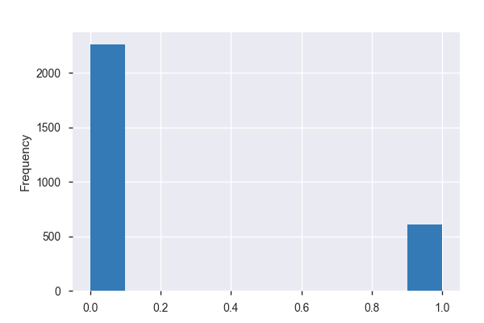

**Common Values**

| Value | Count | Frequency (%) |  |
| --- | --- | --- | --- |
| 0.0 | 2260 | 2.9% |  |
| 1.0 | 606 | 0.8% |  |
| (Missing) | 74238 | 96.3% |  |

**Extreme Values**

Minimum 5 values

| Value | Count | Frequency (%) |  |
| --- | --- | --- | --- |
| 0.0 | 2260 | 2.9% |  |
| 1.0 | 606 | 0.8% |  |

Maximum 5 values

| Value | Count | Frequency (%) |  |
| --- | --- | --- | --- |
| 0.0 | 2260 | 2.9% |  |
| 1.0 | 606 | 0.8% |  |

v34_2  
Categorical

| Distinct count | 6 |
| --- | --- |
| Unique (%) | 0.0% |
| Missing (%) | 0.0% |
| Missing (n) | 0 |

| eens | 27639 |
| --- | --- |
| helemaal eens | 17813 |
| helemaal oneens | 10284 |
| Other values (3) | 21368 |

Toggle details

| Value | Count | Frequency (%) |  |
| --- | --- | --- | --- |
| eens | 27639 | 35.8% |  |
| helemaal eens | 17813 | 23.1% |  |
| helemaal oneens | 10284 | 13.3% |  |
| noch eens/noch oneens | 9647 | 12.5% |  |
| 99 | 7876 | 10.2% |  |
| oneens | 3845 | 5.0% |  |

v34_2eenz  
Numeric

| Distinct count | 3 |
| --- | --- |
| Unique (%) | 0.0% |
| Missing (%) | 96.3% |
| Missing (n) | 74238 |
| Infinite (%) | 0.0% |
| Infinite (n) | 0 |

| Mean | 0.31472 |
| --- | --- |
| Minimum | 0 |
| Maximum | 1 |
| Zeros (%) | 2.5% |

Toggle details

**Statistics**

Quantile statistics

| Minimum | 0 |
| --- | --- |
| 5-th percentile | 0 |
| Q1 | 0 |
| Median | 0 |
| Q3 | 1 |
| 95-th percentile | 1 |
| Maximum | 1 |
| Range | 1 |
| Interquartile range | 1 |

Descriptive statistics

| Standard deviation | 0.46449 |
| --- | --- |
| Coef of variation | 1.4759 |
| Kurtosis | -1.3636 |
| Mean | 0.31472 |
| MAD | 0.43135 |
| Skewness | 0.79832 |
| Sum | 902 |
| Variance | 0.21575 |
| Memory size | 602.5 KiB |

**Histogram**

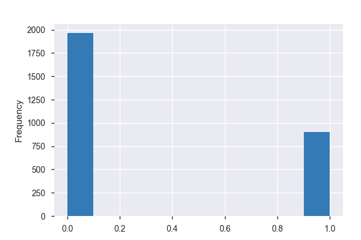

**Common Values**

| Value | Count | Frequency (%) |  |
| --- | --- | --- | --- |
| 0.0 | 1964 | 2.5% |  |
| 1.0 | 902 | 1.2% |  |
| (Missing) | 74238 | 96.3% |  |

**Extreme Values**

Minimum 5 values

| Value | Count | Frequency (%) |  |
| --- | --- | --- | --- |
| 0.0 | 1964 | 2.5% |  |
| 1.0 | 902 | 1.2% |  |

Maximum 5 values

| Value | Count | Frequency (%) |  |
| --- | --- | --- | --- |
| 0.0 | 1964 | 2.5% |  |
| 1.0 | 902 | 1.2% |  |

v34_2r  
Numeric

| Distinct count | 6 |
| --- | --- |
| Unique (%) | 0.0% |
| Missing (%) | 96.3% |
| Missing (n) | 74238 |
| Infinite (%) | 0.0% |
| Infinite (n) | 0 |

| Mean | 2.3535 |
| --- | --- |
| Minimum | 1 |
| Maximum | 5 |
| Zeros (%) | 0.0% |

Toggle details

**Statistics**

Quantile statistics

| Minimum | 1 |
| --- | --- |
| 5-th percentile | 1 |
| Q1 | 1 |
| Median | 2 |
| Q3 | 3 |
| 95-th percentile | 5 |
| Maximum | 5 |
| Range | 4 |
| Interquartile range | 2 |

Descriptive statistics

| Standard deviation | 1.2883 |
| --- | --- |
| Coef of variation | 0.5474 |
| Kurtosis | -0.19694 |
| Mean | 2.3535 |
| MAD | 1.0308 |
| Skewness | 0.92862 |
| Sum | 6745 |
| Variance | 1.6597 |
| Memory size | 602.5 KiB |

**Histogram**

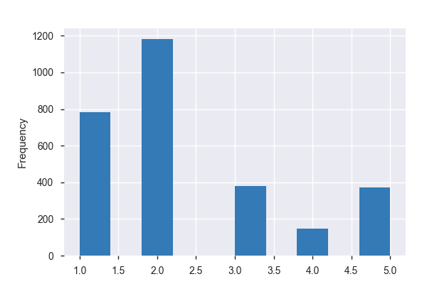

**Common Values**

| Value | Count | Frequency (%) |  |
| --- | --- | --- | --- |
| 2.0 | 1181 | 1.5% |  |
| 1.0 | 783 | 1.0% |  |
| 3.0 | 381 | 0.5% |  |
| 5.0 | 373 | 0.5% |  |
| 4.0 | 148 | 0.2% |  |
| (Missing) | 74238 | 96.3% |  |

**Extreme Values**

Minimum 5 values

| Value | Count | Frequency (%) |  |
| --- | --- | --- | --- |
| 1.0 | 783 | 1.0% |  |
| 2.0 | 1181 | 1.5% |  |
| 3.0 | 381 | 0.5% |  |
| 4.0 | 148 | 0.2% |  |
| 5.0 | 373 | 0.5% |  |

Maximum 5 values

| Value | Count | Frequency (%) |  |
| --- | --- | --- | --- |
| 1.0 | 783 | 1.0% |  |
| 2.0 | 1181 | 1.5% |  |
| 3.0 | 381 | 0.5% |  |
| 4.0 | 148 | 0.2% |  |
| 5.0 | 373 | 0.5% |  |

v34_3  
Categorical

| Distinct count | 6 |
| --- | --- |
| Unique (%) | 0.0% |
| Missing (%) | 0.0% |
| Missing (n) | 0 |

| eens | 22260 |
| --- | --- |
| noch eens/noch oneens | 14556 |
| helemaal eens | 14151 |
| Other values (3) | 26137 |

Toggle details

| Value | Count | Frequency (%) |  |
| --- | --- | --- | --- |
| eens | 22260 | 28.9% |  |
| noch eens/noch oneens | 14556 | 18.9% |  |
| helemaal eens | 14151 | 18.4% |  |
| helemaal oneens | 11777 | 15.3% |  |
| 99 | 7876 | 10.2% |  |
| oneens | 6484 | 8.4% |  |

v34_3eenz  
Numeric

| Distinct count | 3 |
| --- | --- |
| Unique (%) | 0.0% |
| Missing (%) | 96.3% |
| Missing (n) | 74238 |
| Infinite (%) | 0.0% |
| Infinite (n) | 0 |

| Mean | 0.33461 |
| --- | --- |
| Minimum | 0 |
| Maximum | 1 |
| Zeros (%) | 2.5% |

Toggle details

**Statistics**

Quantile statistics

| Minimum | 0 |
| --- | --- |
| 5-th percentile | 0 |
| Q1 | 0 |
| Median | 0 |
| Q3 | 1 |
| 95-th percentile | 1 |
| Maximum | 1 |
| Range | 1 |
| Interquartile range | 1 |

Descriptive statistics

| Standard deviation | 0.47194 |
| --- | --- |
| Coef of variation | 1.4104 |
| Kurtosis | -1.5091 |
| Mean | 0.33461 |
| MAD | 0.44529 |
| Skewness | 0.70138 |
| Sum | 959 |
| Variance | 0.22272 |
| Memory size | 602.5 KiB |

**Histogram**

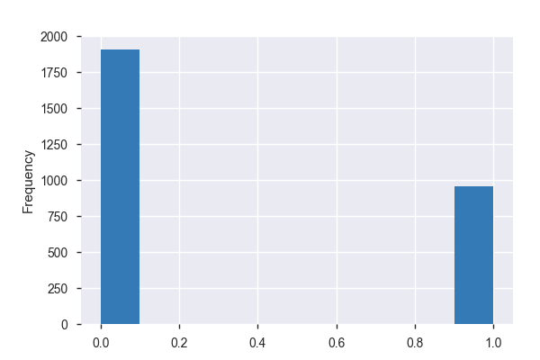

**Common Values**

| Value | Count | Frequency (%) |  |
| --- | --- | --- | --- |
| 0.0 | 1907 | 2.5% |  |
| 1.0 | 959 | 1.2% |  |
| (Missing) | 74238 | 96.3% |  |

**Extreme Values**

Minimum 5 values

| Value | Count | Frequency (%) |  |
| --- | --- | --- | --- |
| 0.0 | 1907 | 2.5% |  |
| 1.0 | 959 | 1.2% |  |

Maximum 5 values

| Value | Count | Frequency (%) |  |
| --- | --- | --- | --- |
| 0.0 | 1907 | 2.5% |  |
| 1.0 | 959 | 1.2% |  |

v34_3r  
Numeric

| Distinct count | 6 |
| --- | --- |
| Unique (%) | 0.0% |
| Missing (%) | 96.3% |
| Missing (n) | 74238 |
| Infinite (%) | 0.0% |
| Infinite (n) | 0 |

| Mean | 2.3503 |
| --- | --- |
| Minimum | 1 |
| Maximum | 5 |
| Zeros (%) | 0.0% |

Toggle details

**Statistics**

Quantile statistics

| Minimum | 1 |
| --- | --- |
| 5-th percentile | 1 |
| Q1 | 1 |
| Median | 2 |
| Q3 | 3 |
| 95-th percentile | 5 |
| Maximum | 5 |
| Range | 4 |
| Interquartile range | 2 |

Descriptive statistics

| Standard deviation | 1.2539 |
| --- | --- |
| Coef of variation | 0.53349 |
| Kurtosis | -0.14156 |
| Mean | 2.3503 |
| MAD | 1.0063 |
| Skewness | 0.89603 |
| Sum | 6736 |
| Variance | 1.5722 |
| Memory size | 602.5 KiB |

**Histogram**

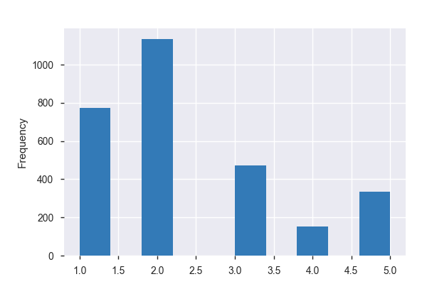

**Common Values**

| Value | Count | Frequency (%) |  |
| --- | --- | --- | --- |
| 2.0 | 1133 | 1.5% |  |
| 1.0 | 774 | 1.0% |  |
| 3.0 | 473 | 0.6% |  |
| 5.0 | 333 | 0.4% |  |
| 4.0 | 153 | 0.2% |  |
| (Missing) | 74238 | 96.3% |  |

**Extreme Values**

Minimum 5 values

| Value | Count | Frequency (%) |  |
| --- | --- | --- | --- |
| 1.0 | 774 | 1.0% |  |
| 2.0 | 1133 | 1.5% |  |
| 3.0 | 473 | 0.6% |  |
| 4.0 | 153 | 0.2% |  |
| 5.0 | 333 | 0.4% |  |

Maximum 5 values

| Value | Count | Frequency (%) |  |
| --- | --- | --- | --- |
| 1.0 | 774 | 1.0% |  |
| 2.0 | 1133 | 1.5% |  |
| 3.0 | 473 | 0.6% |  |
| 4.0 | 153 | 0.2% |  |
| 5.0 | 333 | 0.4% |  |

v34_4  
Categorical

| Distinct count | 6 |
| --- | --- |
| Unique (%) | 0.0% |
| Missing (%) | 0.0% |
| Missing (n) | 0 |

| eens | 26156 |
| --- | --- |
| helemaal eens | 14545 |
| noch eens/noch oneens | 12192 |
| Other values (3) | 24211 |

Toggle details

| Value | Count | Frequency (%) |  |
| --- | --- | --- | --- |
| eens | 26156 | 33.9% |  |
| helemaal eens | 14545 | 18.9% |  |
| noch eens/noch oneens | 12192 | 15.8% |  |
| helemaal oneens | 11430 | 14.8% |  |
| 99 | 7876 | 10.2% |  |
| oneens | 4905 | 6.4% |  |

v34_4eenz  
Numeric

| Distinct count | 3 |
| --- | --- |
| Unique (%) | 0.0% |
| Missing (%) | 96.3% |
| Missing (n) | 74238 |
| Infinite (%) | 0.0% |
| Infinite (n) | 0 |

| Mean | 0.31158 |
| --- | --- |
| Minimum | 0 |
| Maximum | 1 |
| Zeros (%) | 2.6% |

Toggle details

**Statistics**

Quantile statistics

| Minimum | 0 |
| --- | --- |
| 5-th percentile | 0 |
| Q1 | 0 |
| Median | 0 |
| Q3 | 1 |
| 95-th percentile | 1 |
| Maximum | 1 |
| Range | 1 |
| Interquartile range | 1 |

Descriptive statistics

| Standard deviation | 0.46322 |
| --- | --- |
| Coef of variation | 1.4867 |
| Kurtosis | -1.3382 |
| Mean | 0.31158 |
| MAD | 0.429 |
| Skewness | 0.81407 |
| Sum | 893 |
| Variance | 0.21457 |
| Memory size | 602.5 KiB |

**Histogram**

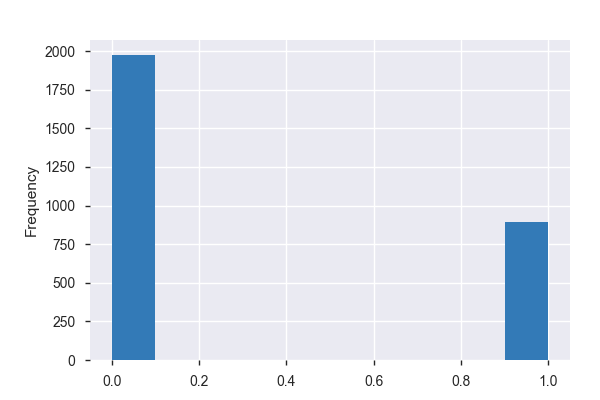

**Common Values**

| Value | Count | Frequency (%) |  |
| --- | --- | --- | --- |
| 0.0 | 1973 | 2.6% |  |
| 1.0 | 893 | 1.2% |  |
| (Missing) | 74238 | 96.3% |  |

**Extreme Values**

Minimum 5 values

| Value | Count | Frequency (%) |  |
| --- | --- | --- | --- |
| 0.0 | 1973 | 2.6% |  |
| 1.0 | 893 | 1.2% |  |

Maximum 5 values

| Value | Count | Frequency (%) |  |
| --- | --- | --- | --- |
| 0.0 | 1973 | 2.6% |  |
| 1.0 | 893 | 1.2% |  |

v34_4r  
Numeric

| Distinct count | 6 |
| --- | --- |
| Unique (%) | 0.0% |
| Missing (%) | 96.3% |
| Missing (n) | 74238 |
| Infinite (%) | 0.0% |
| Infinite (n) | 0 |

| Mean | 2.328 |
| --- | --- |
| Minimum | 1 |
| Maximum | 5 |
| Zeros (%) | 0.0% |

Toggle details

**Statistics**

Quantile statistics

| Minimum | 1 |
| --- | --- |
| 5-th percentile | 1 |
| Q1 | 1 |
| Median | 2 |
| Q3 | 3 |
| 95-th percentile | 5 |
| Maximum | 5 |
| Range | 4 |
| Interquartile range | 2 |

Descriptive statistics

| Standard deviation | 1.2211 |
| --- | --- |
| Coef of variation | 0.52452 |
| Kurtosis | 0.094636 |
| Mean | 2.328 |
| MAD | 0.95891 |
| Skewness | 0.97993 |
| Sum | 6672 |
| Variance | 1.491 |
| Memory size | 602.5 KiB |

**Histogram**

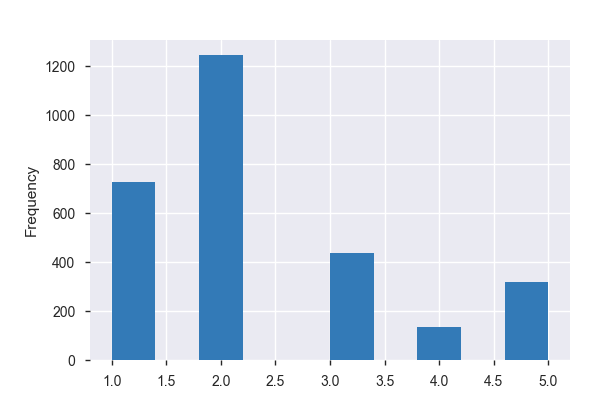

**Common Values**

| Value | Count | Frequency (%) |  |
| --- | --- | --- | --- |
| 2.0 | 1246 | 1.6% |  |
| 1.0 | 727 | 0.9% |  |
| 3.0 | 438 | 0.6% |  |
| 5.0 | 319 | 0.4% |  |
| 4.0 | 136 | 0.2% |  |
| (Missing) | 74238 | 96.3% |  |

**Extreme Values**

Minimum 5 values

| Value | Count | Frequency (%) |  |
| --- | --- | --- | --- |
| 1.0 | 727 | 0.9% |  |
| 2.0 | 1246 | 1.6% |  |
| 3.0 | 438 | 0.6% |  |
| 4.0 | 136 | 0.2% |  |
| 5.0 | 319 | 0.4% |  |

Maximum 5 values

| Value | Count | Frequency (%) |  |
| --- | --- | --- | --- |
| 1.0 | 727 | 0.9% |  |
| 2.0 | 1246 | 1.6% |  |
| 3.0 | 438 | 0.6% |  |
| 4.0 | 136 | 0.2% |  |
| 5.0 | 319 | 0.4% |  |

v34_5  
Categorical

| Distinct count | 6 |
| --- | --- |
| Unique (%) | 0.0% |
| Missing (%) | 0.0% |
| Missing (n) | 0 |

| helemaal oneens | 35161 |
| --- | --- |
| oneens | 13942 |
| noch eens/noch oneens | 12207 |
| Other values (3) | 15794 |

Toggle details

| Value | Count | Frequency (%) |  |
| --- | --- | --- | --- |
| helemaal oneens | 35161 | 45.6% |  |
| oneens | 13942 | 18.1% |  |
| noch eens/noch oneens | 12207 | 15.8% |  |
| 99 | 7876 | 10.2% |  |
| eens | 5367 | 7.0% |  |
| helemaal eens | 2551 | 3.3% |  |

v34_5eenz  
Numeric

| Distinct count | 3 |
| --- | --- |
| Unique (%) | 0.0% |
| Missing (%) | 96.3% |
| Missing (n) | 74238 |
| Infinite (%) | 0.0% |
| Infinite (n) | 0 |

| Mean | 0.28681 |
| --- | --- |
| Minimum | 0 |
| Maximum | 1 |
| Zeros (%) | 2.7% |

Toggle details

**Statistics**

Quantile statistics

| Minimum | 0 |
| --- | --- |
| 5-th percentile | 0 |
| Q1 | 0 |
| Median | 0 |
| Q3 | 1 |
| 95-th percentile | 1 |
| Maximum | 1 |
| Range | 1 |
| Interquartile range | 1 |

Descriptive statistics

| Standard deviation | 0.45235 |
| --- | --- |
| Coef of variation | 1.5772 |
| Kurtosis | -1.1111 |
| Mean | 0.28681 |
| MAD | 0.4091 |
| Skewness | 0.94324 |
| Sum | 822 |
| Variance | 0.20462 |
| Memory size | 602.5 KiB |

**Histogram**

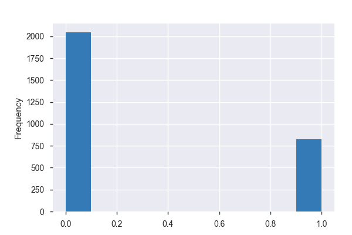

**Common Values**

| Value | Count | Frequency (%) |  |
| --- | --- | --- | --- |
| 0.0 | 2044 | 2.7% |  |
| 1.0 | 822 | 1.1% |  |
| (Missing) | 74238 | 96.3% |  |

**Extreme Values**

Minimum 5 values

| Value | Count | Frequency (%) |  |
| --- | --- | --- | --- |
| 0.0 | 2044 | 2.7% |  |
| 1.0 | 822 | 1.1% |  |

Maximum 5 values

| Value | Count | Frequency (%) |  |
| --- | --- | --- | --- |
| 0.0 | 2044 | 2.7% |  |
| 1.0 | 822 | 1.1% |  |

v34_6  
Categorical

| Distinct count | 6 |
| --- | --- |
| Unique (%) | 0.0% |
| Missing (%) | 0.0% |
| Missing (n) | 0 |

| helemaal oneens | 40385 |
| --- | --- |
| oneens | 14271 |
| noch eens/noch oneens | 9103 |
| Other values (3) | 13345 |

Toggle details

| Value | Count | Frequency (%) |  |
| --- | --- | --- | --- |
| helemaal oneens | 40385 | 52.4% |  |
| oneens | 14271 | 18.5% |  |
| noch eens/noch oneens | 9103 | 11.8% |  |
| 99 | 7876 | 10.2% |  |
| eens | 3354 | 4.3% |  |
| helemaal eens | 2115 | 2.7% |  |

v34_6eenz  
Numeric

| Distinct count | 3 |
| --- | --- |
| Unique (%) | 0.0% |
| Missing (%) | 96.3% |
| Missing (n) | 74238 |
| Infinite (%) | 0.0% |
| Infinite (n) | 0 |

| Mean | 0.18493 |
| --- | --- |
| Minimum | 0 |
| Maximum | 1 |
| Zeros (%) | 3.0% |

Toggle details

**Statistics**

Quantile statistics

| Minimum | 0 |
| --- | --- |
| 5-th percentile | 0 |
| Q1 | 0 |
| Median | 0 |
| Q3 | 0 |
| 95-th percentile | 1 |
| Maximum | 1 |
| Range | 1 |
| Interquartile range | 0 |

Descriptive statistics

| Standard deviation | 0.38831 |
| --- | --- |
| Coef of variation | 2.0998 |
| Kurtosis | 0.63764 |
| Mean | 0.18493 |
| MAD | 0.30146 |
| Skewness | 1.6239 |
| Sum | 530 |
| Variance | 0.15078 |
| Memory size | 602.5 KiB |

**Histogram**

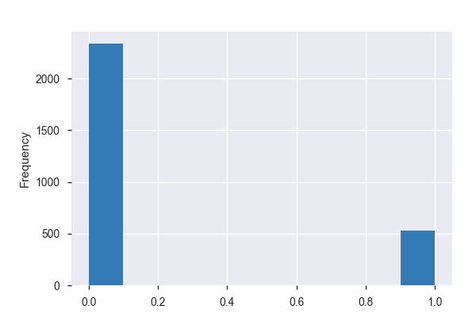

**Common Values**

| Value | Count | Frequency (%) |  |
| --- | --- | --- | --- |
| 0.0 | 2336 | 3.0% |  |
| 1.0 | 530 | 0.7% |  |
| (Missing) | 74238 | 96.3% |  |

**Extreme Values**

Minimum 5 values

| Value | Count | Frequency (%) |  |
| --- | --- | --- | --- |
| 0.0 | 2336 | 3.0% |  |
| 1.0 | 530 | 0.7% |  |

Maximum 5 values

| Value | Count | Frequency (%) |  |
| --- | --- | --- | --- |
| 0.0 | 2336 | 3.0% |  |
| 1.0 | 530 | 0.7% |  |

v34eenz  
Numeric

| Distinct count | 8 |
| --- | --- |
| Unique (%) | 0.0% |
| Missing (%) | 96.3% |
| Missing (n) | 74238 |
| Infinite (%) | 0.0% |
| Infinite (n) | 0 |

| Mean | 1.6441 |
| --- | --- |
| Minimum | 0 |
| Maximum | 6 |
| Zeros (%) | 1.5% |

Toggle details

**Statistics**

Quantile statistics

| Minimum | 0 |
| --- | --- |
| 5-th percentile | 0 |
| Q1 | 0 |
| Median | 1 |
| Q3 | 3 |
| 95-th percentile | 5 |
| Maximum | 6 |
| Range | 6 |
| Interquartile range | 3 |

Descriptive statistics

| Standard deviation | 1.7725 |
| --- | --- |
| Coef of variation | 1.0781 |
| Kurtosis | -0.26376 |
| Mean | 1.6441 |
| MAD | 1.514 |
| Skewness | 0.8589 |
| Sum | 4712 |
| Variance | 3.1417 |
| Memory size | 602.5 KiB |

**Histogram**

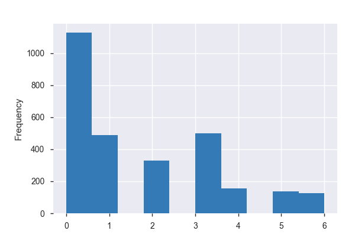

**Common Values**

| Value | Count | Frequency (%) |  |
| --- | --- | --- | --- |
| 0.0 | 1128 | 1.5% |  |
| 3.0 | 501 | 0.6% |  |
| 1.0 | 489 | 0.6% |  |
| 2.0 | 330 | 0.4% |  |
| 4.0 | 155 | 0.2% |  |
| 5.0 | 138 | 0.2% |  |
| 6.0 | 125 | 0.2% |  |
| (Missing) | 74238 | 96.3% |  |

**Extreme Values**

Minimum 5 values

| Value | Count | Frequency (%) |  |
| --- | --- | --- | --- |
| 0.0 | 1128 | 1.5% |  |
| 1.0 | 489 | 0.6% |  |
| 2.0 | 330 | 0.4% |  |
| 3.0 | 501 | 0.6% |  |
| 4.0 | 155 | 0.2% |  |

Maximum 5 values

| Value | Count | Frequency (%) |  |
| --- | --- | --- | --- |
| 2.0 | 330 | 0.4% |  |
| 3.0 | 501 | 0.6% |  |
| 4.0 | 155 | 0.2% |  |
| 5.0 | 138 | 0.2% |  |
| 6.0 | 125 | 0.2% |  |

v34eenz_klassen  
Categorical

| Distinct count | 5 |
| --- | --- |
| Unique (%) | 0.0% |
| Missing (%) | 96.6% |
| Missing (n) | 74511 |

| geen | 1374 |
| --- | --- |
| matig | 842 |
| ernstig | 221 |
| (Missing) | 74511 |

Toggle details

| Value | Count | Frequency (%) |  |
| --- | --- | --- | --- |
| geen | 1374 | 1.8% |  |
| matig | 842 | 1.1% |  |
| ernstig | 221 | 0.3% |  |
| 99 | 156 | 0.2% |  |
| (Missing) | 74511 | 96.6% |  |

v35_1  
Categorical

| Distinct count | 4 |
| --- | --- |
| Unique (%) | 0.0% |
| Missing (%) | 0.0% |
| Missing (n) | 0 |

| 99 | 72704 |
| --- | --- |
| ja | 3187 |
| 99 | 1048 |

Toggle details

| Value | Count | Frequency (%) |  |
| --- | --- | --- | --- |
| 99 | 72704 | 94.3% |  |
| ja | 3187 | 4.1% |  |
| 99 | 1048 | 1.4% |  |
| neen | 165 | 0.2% |  |

v35_2  
Categorical

| Distinct count | 4 |
| --- | --- |
| Unique (%) | 0.0% |
| Missing (%) | 0.0% |
| Missing (n) | 0 |

| 99 | 72704 |
| --- | --- |
| neen | 2915 |
| 99 | 1048 |

Toggle details

| Value | Count | Frequency (%) |  |
| --- | --- | --- | --- |
| 99 | 72704 | 94.3% |  |
| neen | 2915 | 3.8% |  |
| 99 | 1048 | 1.4% |  |
| ja | 437 | 0.6% |  |

v35_3  
Categorical

| Distinct count | 4 |
| --- | --- |
| Unique (%) | 0.0% |
| Missing (%) | 0.0% |
| Missing (n) | 0 |

| 99 | 72704 |
| --- | --- |
| neen | 2877 |
| 99 | 1048 |

Toggle details

| Value | Count | Frequency (%) |  |
| --- | --- | --- | --- |
| 99 | 72704 | 94.3% |  |
| neen | 2877 | 3.7% |  |
| 99 | 1048 | 1.4% |  |
| ja | 475 | 0.6% |  |

v35_4  
Categorical

| Distinct count | 4 |
| --- | --- |
| Unique (%) | 0.0% |
| Missing (%) | 0.0% |
| Missing (n) | 0 |

| 99 | 72704 |
| --- | --- |
| neen | 1751 |
| ja | 1601 |

Toggle details

| Value | Count | Frequency (%) |  |
| --- | --- | --- | --- |
| 99 | 72704 | 94.3% |  |
| neen | 1751 | 2.3% |  |
| ja | 1601 | 2.1% |  |
| 99 | 1048 | 1.4% |  |

v35_5  
Categorical

| Distinct count | 4 |
| --- | --- |
| Unique (%) | 0.0% |
| Missing (%) | 0.0% |
| Missing (n) | 0 |

| 99 | 72704 |
| --- | --- |
| neen | 2904 |
| 99 | 1048 |

Toggle details

| Value | Count | Frequency (%) |  |
| --- | --- | --- | --- |
| 99 | 72704 | 94.3% |  |
| neen | 2904 | 3.8% |  |
| 99 | 1048 | 1.4% |  |
| ja | 448 | 0.6% |  |

v36_1  
Categorical

| Distinct count | 9 |
| --- | --- |
| Unique (%) | 0.0% |
| Missing (%) | 0.0% |
| Missing (n) | 32 |

| 99 | 72704 |
| --- | --- |
| 1 à 2 maal per week | 1247 |
| (bijna) dagelijks | 1184 |
| Other values (5) | 1937 |

Toggle details

| Value | Count | Frequency (%) |  |
| --- | --- | --- | --- |
| 99 | 72704 | 94.3% |  |
| 1 à 2 maal per week | 1247 | 1.6% |  |
| (bijna) dagelijks | 1184 | 1.5% |  |
| 99 | 1155 | 1.5% |  |
| niet van toepassing | 315 | 0.4% |  |
| maandelijks | 249 | 0.3% |  |
| minder dan 1 keer per maand | 134 | 0.2% |  |
| nooit | 84 | 0.1% |  |
| (Missing) | 32 | 0.0% |  |

v36_1oudeVL  
Categorical

| Distinct count | 8 |
| --- | --- |
| Unique (%) | 0.0% |
| Missing (%) | 4.5% |
| Missing (n) | 3479 |

| (bijna) dagelijks | 26215 |
| --- | --- |
| 1 à 2 maal per week | 24943 |
| niet van toepassing | 6832 |
| Other values (4) | 15635 |

Toggle details

| Value | Count | Frequency (%) |  |
| --- | --- | --- | --- |
| (bijna) dagelijks | 26215 | 34.0% |  |
| 1 à 2 maal per week | 24943 | 32.3% |  |
| niet van toepassing | 6832 | 8.9% |  |
| 99 | 6382 | 8.3% |  |
| maandelijks | 5025 | 6.5% |  |
| minder dan 1 keer per maand | 2238 | 2.9% |  |
| nooit | 1990 | 2.6% |  |
| (Missing) | 3479 | 4.5% |  |

v36_2  
Categorical

| Distinct count | 9 |
| --- | --- |
| Unique (%) | 0.0% |
| Missing (%) | 0.1% |
| Missing (n) | 78 |

| 99 | 72704 |
| --- | --- |
| 99 | 1451 |
| 1 à 2 maal per week | 1063 |
| Other values (5) | 1808 |

Toggle details

| Value | Count | Frequency (%) |  |
| --- | --- | --- | --- |
| 99 | 72704 | 94.3% |  |
| 99 | 1451 | 1.9% |  |
| 1 à 2 maal per week | 1063 | 1.4% |  |
| niet van toepassing | 522 | 0.7% |  |
| (bijna) dagelijks | 514 | 0.7% |  |
| maandelijks | 375 | 0.5% |  |
| nooit | 209 | 0.3% |  |
| minder dan 1 keer per maand | 188 | 0.2% |  |
| (Missing) | 78 | 0.1% |  |

v36_3  
Categorical

| Distinct count | 8 |
| --- | --- |
| Unique (%) | 0.0% |
| Missing (%) | 0.1% |
| Missing (n) | 65 |

| 1 à 2 maal per week | 23581 |
| --- | --- |
| (bijna) dagelijks | 15539 |
| niet van toepassing | 11454 |
| Other values (4) | 26465 |

Toggle details

| Value | Count | Frequency (%) |  |
| --- | --- | --- | --- |
| 1 à 2 maal per week | 23581 | 30.6% |  |
| (bijna) dagelijks | 15539 | 20.2% |  |
| niet van toepassing | 11454 | 14.9% |  |
| 99 | 10717 | 13.9% |  |
| maandelijks | 8951 | 11.6% |  |
| minder dan 1 keer per maand | 4060 | 5.3% |  |
| nooit | 2737 | 3.5% |  |
| (Missing) | 65 | 0.1% |  |

v36_4  
Categorical

| Distinct count | 8 |
| --- | --- |
| Unique (%) | 0.0% |
| Missing (%) | 0.1% |
| Missing (n) | 71 |

| maandelijks | 17847 |
| --- | --- |
| 1 à 2 maal per week | 15800 |
| minder dan 1 keer per maand | 13318 |
| Other values (4) | 30068 |

Toggle details

| Value | Count | Frequency (%) |  |
| --- | --- | --- | --- |
| maandelijks | 17847 | 23.1% |  |
| 1 à 2 maal per week | 15800 | 20.5% |  |
| minder dan 1 keer per maand | 13318 | 17.3% |  |
| nooit | 12039 | 15.6% |  |
| 99 | 11769 | 15.3% |  |
| (bijna) dagelijks | 4510 | 5.8% |  |
| niet van toepassing | 1750 | 2.3% |  |
| (Missing) | 71 | 0.1% |  |

v36_5  
Categorical

| Distinct count | 8 |
| --- | --- |
| Unique (%) | 0.0% |
| Missing (%) | 0.2% |
| Missing (n) | 123 |

| 99 | 26078 |
| --- | --- |
| nooit | 25320 |
| niet van toepassing | 16813 |
| Other values (4) | 8770 |

Toggle details

| Value | Count | Frequency (%) |  |
| --- | --- | --- | --- |
| 99 | 26078 | 33.8% |  |
| nooit | 25320 | 32.8% |  |
| niet van toepassing | 16813 | 21.8% |  |
| 1 à 2 maal per week | 3828 | 5.0% |  |
| (bijna) dagelijks | 2507 | 3.3% |  |
| maandelijks | 1495 | 1.9% |  |
| minder dan 1 keer per maand | 940 | 1.2% |  |
| (Missing) | 123 | 0.2% |  |

v36_6  
Categorical

| Distinct count | 9 |
| --- | --- |
| Unique (%) | 0.0% |
| Missing (%) | 0.1% |
| Missing (n) | 85 |

| minder dan 1 keer per maand | 20805 |
| --- | --- |
| 99 | 16127 |
| maandelijks | 15296 |
| Other values (5) | 24791 |

Toggle details

| Value | Count | Frequency (%) |  |
| --- | --- | --- | --- |
| minder dan 1 keer per maand | 20805 | 27.0% |  |
| 99 | 16127 | 20.9% |  |
| maandelijks | 15296 | 19.8% |  |
| nooit | 10585 | 13.7% |  |
| 1 à 2 maal per week | 7858 | 10.2% |  |
| niet van toepassing | 4320 | 5.6% |  |
| (bijna) dagelijks | 1933 | 2.5% |  |
| 999 | 95 | 0.1% |  |
| (Missing) | 85 | 0.1% |  |

v36_7  
Categorical

| Distinct count | 8 |
| --- | --- |
| Unique (%) | 0.0% |
| Missing (%) | 0.1% |
| Missing (n) | 65 |

| 1 à 2 maal per week | 22133 |
| --- | --- |
| maandelijks | 19122 |
| minder dan 1 keer per maand | 12160 |
| Other values (4) | 23624 |

Toggle details

| Value | Count | Frequency (%) |  |
| --- | --- | --- | --- |
| 1 à 2 maal per week | 22133 | 28.7% |  |
| maandelijks | 19122 | 24.8% |  |
| minder dan 1 keer per maand | 12160 | 15.8% |  |
| 99 | 11423 | 14.8% |  |
| (bijna) dagelijks | 6549 | 8.5% |  |
| nooit | 4233 | 5.5% |  |
| niet van toepassing | 1419 | 1.8% |  |
| (Missing) | 65 | 0.1% |  |

v36_8  
Categorical

| Distinct count | 8 |
| --- | --- |
| Unique (%) | 0.0% |
| Missing (%) | 0.1% |
| Missing (n) | 60 |

| 1 à 2 maal per week | 20515 |
| --- | --- |
| minder dan 1 keer per maand | 11617 |
| (bijna) dagelijks | 11560 |
| Other values (4) | 33352 |

Toggle details

| Value | Count | Frequency (%) |  |
| --- | --- | --- | --- |
| 1 à 2 maal per week | 20515 | 26.6% |  |
| minder dan 1 keer per maand | 11617 | 15.1% |  |
| (bijna) dagelijks | 11560 | 15.0% |  |
| 99 | 11549 | 15.0% |  |
| maandelijks | 9957 | 12.9% |  |
| nooit | 9854 | 12.8% |  |
| niet van toepassing | 1992 | 2.6% |  |
| (Missing) | 60 | 0.1% |  |

v37_1  
Categorical

| Distinct count | 8 |
| --- | --- |
| Unique (%) | 0.0% |
| Missing (%) | 0.0% |
| Missing (n) | 10 |

| zeer tevreden | 35737 |
| --- | --- |
| niet van toepassing | 19285 |
| 99 | 12397 |
| Other values (4) | 9675 |

Toggle details

| Value | Count | Frequency (%) |  |
| --- | --- | --- | --- |
| zeer tevreden | 35737 | 46.3% |  |
| niet van toepassing | 19285 | 25.0% |  |
| 99 | 12397 | 16.1% |  |
| eerder tevreden | 6938 | 9.0% |  |
| noch ontevreden, noch tevreden | 1436 | 1.9% |  |
| helemaal niet tevreden | 951 | 1.2% |  |
| eerder ontevreden | 350 | 0.5% |  |
| (Missing) | 10 | 0.0% |  |

v37_2  
Categorical

| Distinct count | 8 |
| --- | --- |
| Unique (%) | 0.0% |
| Missing (%) | 0.0% |
| Missing (n) | 10 |

| zeer tevreden | 45128 |
| --- | --- |
| eerder tevreden | 12232 |
| niet van toepassing | 10416 |
| Other values (4) | 9318 |

Toggle details

| Value | Count | Frequency (%) |  |
| --- | --- | --- | --- |
| zeer tevreden | 45128 | 58.5% |  |
| eerder tevreden | 12232 | 15.9% |  |
| niet van toepassing | 10416 | 13.5% |  |
| 99 | 5001 | 6.5% |  |
| noch ontevreden, noch tevreden | 1989 | 2.6% |  |
| helemaal niet tevreden | 1445 | 1.9% |  |
| eerder ontevreden | 883 | 1.1% |  |
| (Missing) | 10 | 0.0% |  |

v37_3  
Categorical

| Distinct count | 8 |
| --- | --- |
| Unique (%) | 0.0% |
| Missing (%) | 0.0% |
| Missing (n) | 10 |

| zeer tevreden | 34257 |
| --- | --- |
| niet van toepassing | 13970 |
| eerder tevreden | 12188 |
| Other values (4) | 16679 |

Toggle details

| Value | Count | Frequency (%) |  |
| --- | --- | --- | --- |
| zeer tevreden | 34257 | 44.4% |  |
| niet van toepassing | 13970 | 18.1% |  |
| eerder tevreden | 12188 | 15.8% |  |
| 99 | 10741 | 13.9% |  |
| noch ontevreden, noch tevreden | 3439 | 4.5% |  |
| helemaal niet tevreden | 1496 | 1.9% |  |
| eerder ontevreden | 1003 | 1.3% |  |
| (Missing) | 10 | 0.0% |  |

v37_4  
Categorical

| Distinct count | 8 |
| --- | --- |
| Unique (%) | 0.0% |
| Missing (%) | 0.0% |
| Missing (n) | 10 |

| zeer tevreden | 40034 |
| --- | --- |
| niet van toepassing | 16957 |
| eerder tevreden | 9607 |
| Other values (4) | 10496 |

Toggle details

| Value | Count | Frequency (%) |  |
| --- | --- | --- | --- |
| zeer tevreden | 40034 | 51.9% |  |
| niet van toepassing | 16957 | 22.0% |  |
| eerder tevreden | 9607 | 12.5% |  |
| 99 | 6375 | 8.3% |  |
| noch ontevreden, noch tevreden | 2071 | 2.7% |  |
| helemaal niet tevreden | 1313 | 1.7% |  |
| eerder ontevreden | 737 | 1.0% |  |
| (Missing) | 10 | 0.0% |  |

v37_5  
Categorical

| Distinct count | 8 |
| --- | --- |
| Unique (%) | 0.0% |
| Missing (%) | 0.0% |
| Missing (n) | 10 |

| zeer tevreden | 25673 |
| --- | --- |
| eerder tevreden | 17780 |
| 99 | 11884 |
| Other values (4) | 21757 |

Toggle details

| Value | Count | Frequency (%) |  |
| --- | --- | --- | --- |
| zeer tevreden | 25673 | 33.3% |  |
| eerder tevreden | 17780 | 23.1% |  |
| 99 | 11884 | 15.4% |  |
| helemaal niet tevreden | 10523 | 13.6% |  |
| noch ontevreden, noch tevreden | 6722 | 8.7% |  |
| niet van toepassing | 2988 | 3.9% |  |
| eerder ontevreden | 1524 | 2.0% |  |
| (Missing) | 10 | 0.0% |  |

v37_6  
Categorical

| Distinct count | 8 |
| --- | --- |
| Unique (%) | 0.0% |
| Missing (%) | 0.0% |
| Missing (n) | 10 |

| niet van toepassing | 40925 |
| --- | --- |
| 99 | 25563 |
| zeer tevreden | 5573 |
| Other values (4) | 5033 |

Toggle details

| Value | Count | Frequency (%) |  |
| --- | --- | --- | --- |
| niet van toepassing | 40925 | 53.1% |  |
| 99 | 25563 | 33.2% |  |
| zeer tevreden | 5573 | 7.2% |  |
| eerder tevreden | 2692 | 3.5% |  |
| noch ontevreden, noch tevreden | 1173 | 1.5% |  |
| helemaal niet tevreden | 973 | 1.3% |  |
| eerder ontevreden | 195 | 0.3% |  |
| (Missing) | 10 | 0.0% |  |

v37_7  
Categorical

| Distinct count | 8 |
| --- | --- |
| Unique (%) | 0.0% |
| Missing (%) | 0.0% |
| Missing (n) | 10 |

| eerder tevreden | 20666 |
| --- | --- |
| zeer tevreden | 17389 |
| 99 | 13590 |
| Other values (4) | 25449 |

Toggle details

| Value | Count | Frequency (%) |  |
| --- | --- | --- | --- |
| eerder tevreden | 20666 | 26.8% |  |
| zeer tevreden | 17389 | 22.6% |  |
| 99 | 13590 | 17.6% |  |
| niet van toepassing | 11804 | 15.3% |  |
| noch ontevreden, noch tevreden | 10750 | 13.9% |  |
| helemaal niet tevreden | 1468 | 1.9% |  |
| eerder ontevreden | 1427 | 1.9% |  |
| (Missing) | 10 | 0.0% |  |

v37_8  
Categorical

| Distinct count | 8 |
| --- | --- |
| Unique (%) | 0.0% |
| Missing (%) | 0.0% |
| Missing (n) | 10 |

| zeer tevreden | 27373 |
| --- | --- |
| eerder tevreden | 26375 |
| 99 | 10098 |
| Other values (4) | 13248 |

Toggle details

| Value | Count | Frequency (%) |  |
| --- | --- | --- | --- |
| zeer tevreden | 27373 | 35.5% |  |
| eerder tevreden | 26375 | 34.2% |  |
| 99 | 10098 | 13.1% |  |
| noch ontevreden, noch tevreden | 7492 | 9.7% |  |
| niet van toepassing | 3833 | 5.0% |  |
| helemaal niet tevreden | 972 | 1.3% |  |
| eerder ontevreden | 951 | 1.2% |  |
| (Missing) | 10 | 0.0% |  |

v37_9  
Categorical

| Distinct count | 8 |
| --- | --- |
| Unique (%) | 0.0% |
| Missing (%) | 0.0% |
| Missing (n) | 10 |

| eerder tevreden | 25482 |
| --- | --- |
| zeer tevreden | 23053 |
| noch ontevreden, noch tevreden | 10420 |
| Other values (4) | 18139 |

Toggle details

| Value | Count | Frequency (%) |  |
| --- | --- | --- | --- |
| eerder tevreden | 25482 | 33.0% |  |
| zeer tevreden | 23053 | 29.9% |  |
| noch ontevreden, noch tevreden | 10420 | 13.5% |  |
| 99 | 9916 | 12.9% |  |
| niet van toepassing | 5182 | 6.7% |  |
| helemaal niet tevreden | 1637 | 2.1% |  |
| eerder ontevreden | 1404 | 1.8% |  |
| (Missing) | 10 | 0.0% |  |

v38_1  
Categorical

| Distinct count | 5 |
| --- | --- |
| Unique (%) | 0.0% |
| Missing (%) | 0.1% |
| Missing (n) | 84 |

| langer dan 3 maand | 34090 |
| --- | --- |
| helemaal niet beperkt | 28318 |
| 99 | 10489 |

Toggle details

| Value | Count | Frequency (%) |  |
| --- | --- | --- | --- |
| langer dan 3 maand | 34090 | 44.2% |  |
| helemaal niet beperkt | 28318 | 36.7% |  |
| 99 | 10489 | 13.6% |  |
| 3 maand of korter | 4123 | 5.3% |  |
| (Missing) | 84 | 0.1% |  |

v38_2  
Categorical

| Distinct count | 5 |
| --- | --- |
| Unique (%) | 0.0% |
| Missing (%) | 0.1% |
| Missing (n) | 108 |

| helemaal niet beperkt | 44714 |
| --- | --- |
| langer dan 3 maand | 16141 |
| 99 | 12352 |

Toggle details

| Value | Count | Frequency (%) |  |
| --- | --- | --- | --- |
| helemaal niet beperkt | 44714 | 58.0% |  |
| langer dan 3 maand | 16141 | 20.9% |  |
| 99 | 12352 | 16.0% |  |
| 3 maand of korter | 3789 | 4.9% |  |
| (Missing) | 108 | 0.1% |  |

v38_3  
Categorical

| Distinct count | 5 |
| --- | --- |
| Unique (%) | 0.0% |
| Missing (%) | 0.1% |
| Missing (n) | 101 |

| helemaal niet beperkt | 39874 |
| --- | --- |
| langer dan 3 maand | 21122 |
| 99 | 11795 |

Toggle details

| Value | Count | Frequency (%) |  |
| --- | --- | --- | --- |
| helemaal niet beperkt | 39874 | 51.7% |  |
| langer dan 3 maand | 21122 | 27.4% |  |
| 99 | 11795 | 15.3% |  |
| 3 maand of korter | 4212 | 5.5% |  |
| (Missing) | 101 | 0.1% |  |

v38_4  
Categorical

| Distinct count | 5 |
| --- | --- |
| Unique (%) | 0.0% |
| Missing (%) | 0.1% |
| Missing (n) | 105 |

| helemaal niet beperkt | 38068 |
| --- | --- |
| langer dan 3 maand | 21752 |
| 99 | 12124 |

Toggle details

| Value | Count | Frequency (%) |  |
| --- | --- | --- | --- |
| helemaal niet beperkt | 38068 | 49.4% |  |
| langer dan 3 maand | 21752 | 28.2% |  |
| 99 | 12124 | 15.7% |  |
| 3 maand of korter | 5055 | 6.6% |  |
| (Missing) | 105 | 0.1% |  |

v38_5  
Categorical

| Distinct count | 5 |
| --- | --- |
| Unique (%) | 0.0% |
| Missing (%) | 0.2% |
| Missing (n) | 119 |

| helemaal niet beperkt | 45522 |
| --- | --- |
| langer dan 3 maand | 14000 |
| 99 | 13375 |

Toggle details

| Value | Count | Frequency (%) |  |
| --- | --- | --- | --- |
| helemaal niet beperkt | 45522 | 59.0% |  |
| langer dan 3 maand | 14000 | 18.2% |  |
| 99 | 13375 | 17.3% |  |
| 3 maand of korter | 4088 | 5.3% |  |
| (Missing) | 119 | 0.2% |  |

v38_6  
Categorical

| Distinct count | 5 |
| --- | --- |
| Unique (%) | 0.0% |
| Missing (%) | 0.1% |
| Missing (n) | 112 |

| helemaal niet beperkt | 55208 |
| --- | --- |
| 99 | 12753 |
| langer dan 3 maand | 6779 |

Toggle details

| Value | Count | Frequency (%) |  |
| --- | --- | --- | --- |
| helemaal niet beperkt | 55208 | 71.6% |  |
| 99 | 12753 | 16.5% |  |
| langer dan 3 maand | 6779 | 8.8% |  |
| 3 maand of korter | 2252 | 2.9% |  |
| (Missing) | 112 | 0.1% |  |

v38_7  
Categorical

| Distinct count | 5 |
| --- | --- |
| Unique (%) | 0.0% |
| Missing (%) | 0.1% |
| Missing (n) | 96 |

| helemaal niet beperkt | 51766 |
| --- | --- |
| 99 | 12011 |
| langer dan 3 maand | 10077 |

Toggle details

| Value | Count | Frequency (%) |  |
| --- | --- | --- | --- |
| helemaal niet beperkt | 51766 | 67.1% |  |
| 99 | 12011 | 15.6% |  |
| langer dan 3 maand | 10077 | 13.1% |  |
| 3 maand of korter | 3154 | 4.1% |  |
| (Missing) | 96 | 0.1% |  |

v38_8  
Categorical

| Distinct count | 5 |
| --- | --- |
| Unique (%) | 0.0% |
| Missing (%) | 94.9% |
| Missing (n) | 73208 |

| helemaal niet beperkt | 2850 |
| --- | --- |
| 99 | 560 |
| langer dan 3 maand | 335 |
| (Missing) | 73208 |

Toggle details

| Value | Count | Frequency (%) |  |
| --- | --- | --- | --- |
| helemaal niet beperkt | 2850 | 3.7% |  |
| 99 | 560 | 0.7% |  |
| langer dan 3 maand | 335 | 0.4% |  |
| 3 maand of korter | 151 | 0.2% |  |
| (Missing) | 73208 | 94.9% |  |

v39  
Unsupported

*This variable is an unsupported type, check if it needs cleaning or further analysis*

| Unsupported value |
| --- |

v3klas  
Categorical

| Distinct count | 4 |
| --- | --- |
| Unique (%) | 0.0% |
| Missing (%) | 96.6% |
| Missing (n) | 74496 |

| 60-69j | 1173 |
| --- | --- |
| 70-79j | 844 |
| 80+ | 591 |
| (Missing) | 74496 |

Toggle details

| Value | Count | Frequency (%) |  |
| --- | --- | --- | --- |
| 60-69j | 1173 | 1.5% |  |
| 70-79j | 844 | 1.1% |  |
| 80+ | 591 | 0.8% |  |
| (Missing) | 74496 | 96.6% |  |

v4  
Categorical

| Distinct count | 4 |
| --- | --- |
| Unique (%) | 0.0% |
| Missing (%) | 0.0% |
| Missing (n) | 3 |

| vrouw | 41703 |
| --- | --- |
| man | 34768 |
| 99 | 630 |
| (Missing) | 3 |

Toggle details

| Value | Count | Frequency (%) |  |
| --- | --- | --- | --- |
| vrouw | 41703 | 54.1% |  |
| man | 34768 | 45.1% |  |
| 99 | 630 | 0.8% |  |
| (Missing) | 3 | 0.0% |  |

v40  
Unsupported

*This variable is an unsupported type, check if it needs cleaning or further analysis*

| Unsupported value |
| --- |

v41  
Unsupported

*This variable is an unsupported type, check if it needs cleaning or further analysis*

| Unsupported value |
| --- |

v42  
Unsupported

*This variable is an unsupported type, check if it needs cleaning or further analysis*

| Unsupported value |
| --- |

v43  
Unsupported

*This variable is an unsupported type, check if it needs cleaning or further analysis*

| Unsupported value |
| --- |

v44  
Categorical

| Distinct count | 8 |
| --- | --- |
| Unique (%) | 0.0% |
| Missing (%) | 0.0% |
| Missing (n) | 10 |

| neen | 48446 |
| --- | --- |
| 99 | 10847 |
| één keer | 9490 |
| Other values (4) | 8311 |

Toggle details

| Value | Count | Frequency (%) |  |
| --- | --- | --- | --- |
| neen | 48446 | 62.8% |  |
| 99 | 10847 | 14.1% |  |
| één keer | 9490 | 12.3% |  |
| twee keer | 3911 | 5.1% |  |
| drie keer | 2399 | 3.1% |  |
| meer dan vier keer | 1336 | 1.7% |  |
| vier keer | 665 | 0.9% |  |
| (Missing) | 10 | 0.0% |  |

v45_1  
Categorical

| Distinct count | 4 |
| --- | --- |
| Unique (%) | 0.0% |
| Missing (%) | 0.0% |
| Missing (n) | 10 |

| ja | 45140 |
| --- | --- |
| neen | 27609 |
| 99 | 4345 |
| (Missing) | 10 |

Toggle details

| Value | Count | Frequency (%) |  |
| --- | --- | --- | --- |
| ja | 45140 | 58.5% |  |
| neen | 27609 | 35.8% |  |
| 99 | 4345 | 5.6% |  |
| (Missing) | 10 | 0.0% |  |

v45_10  
Categorical

| Distinct count | 4 |
| --- | --- |
| Unique (%) | 0.0% |
| Missing (%) | 1.1% |
| Missing (n) | 876 |

| neen | 42320 |
| --- | --- |
| ja | 27291 |
| 99 | 6617 |
| (Missing) | 876 |

Toggle details

| Value | Count | Frequency (%) |  |
| --- | --- | --- | --- |
| neen | 42320 | 54.9% |  |
| ja | 27291 | 35.4% |  |
| 99 | 6617 | 8.6% |  |
| (Missing) | 876 | 1.1% |  |

v45_11  
Categorical

| Distinct count | 5 |
| --- | --- |
| Unique (%) | 0.0% |
| Missing (%) | 1.7% |
| Missing (n) | 1289 |

| neen | 66441 |
| --- | --- |
| 99 | 7936 |
| ja | 1436 |
| (Missing) | 1289 |

Toggle details

| Value | Count | Frequency (%) |  |
| --- | --- | --- | --- |
| neen | 66441 | 86.2% |  |
| 99 | 7936 | 10.3% |  |
| ja | 1436 | 1.9% |  |
| nvt | 2 | 0.0% |  |
| (Missing) | 1289 | 1.7% |  |

v45_2  
Categorical

| Distinct count | 4 |
| --- | --- |
| Unique (%) | 0.0% |
| Missing (%) | 0.0% |
| Missing (n) | 10 |

| ja | 38320 |
| --- | --- |
| neen | 34127 |
| 99 | 4647 |
| (Missing) | 10 |

Toggle details

| Value | Count | Frequency (%) |  |
| --- | --- | --- | --- |
| ja | 38320 | 49.7% |  |
| neen | 34127 | 44.3% |  |
| 99 | 4647 | 6.0% |  |
| (Missing) | 10 | 0.0% |  |

v45_3  
Categorical

| Distinct count | 4 |
| --- | --- |
| Unique (%) | 0.0% |
| Missing (%) | 0.0% |
| Missing (n) | 10 |

| neen | 38401 |
| --- | --- |
| ja | 33560 |
| 99 | 5133 |
| (Missing) | 10 |

Toggle details

| Value | Count | Frequency (%) |  |
| --- | --- | --- | --- |
| neen | 38401 | 49.8% |  |
| ja | 33560 | 43.5% |  |
| 99 | 5133 | 6.7% |  |
| (Missing) | 10 | 0.0% |  |

v45_4  
Categorical

| Distinct count | 4 |
| --- | --- |
| Unique (%) | 0.0% |
| Missing (%) | 0.0% |
| Missing (n) | 10 |

| neen | 46817 |
| --- | --- |
| ja | 24437 |
| 99 | 5840 |
| (Missing) | 10 |

Toggle details

| Value | Count | Frequency (%) |  |
| --- | --- | --- | --- |
| neen | 46817 | 60.7% |  |
| ja | 24437 | 31.7% |  |
| 99 | 5840 | 7.6% |  |
| (Missing) | 10 | 0.0% |  |

v45_5  
Categorical

| Distinct count | 4 |
| --- | --- |
| Unique (%) | 0.0% |
| Missing (%) | 0.0% |
| Missing (n) | 10 |

| neen | 47518 |
| --- | --- |
| ja | 23513 |
| 99 | 6063 |
| (Missing) | 10 |

Toggle details

| Value | Count | Frequency (%) |  |
| --- | --- | --- | --- |
| neen | 47518 | 61.6% |  |
| ja | 23513 | 30.5% |  |
| 99 | 6063 | 7.9% |  |
| (Missing) | 10 | 0.0% |  |

v45_6  
Categorical

| Distinct count | 4 |
| --- | --- |
| Unique (%) | 0.0% |
| Missing (%) | 0.0% |
| Missing (n) | 10 |

| neen | 50359 |
| --- | --- |
| ja | 21250 |
| 99 | 5485 |
| (Missing) | 10 |

Toggle details

| Value | Count | Frequency (%) |  |
| --- | --- | --- | --- |
| neen | 50359 | 65.3% |  |
| ja | 21250 | 27.6% |  |
| 99 | 5485 | 7.1% |  |
| (Missing) | 10 | 0.0% |  |

v45_7  
Categorical

| Distinct count | 4 |
| --- | --- |
| Unique (%) | 0.0% |
| Missing (%) | 1.2% |
| Missing (n) | 909 |

| neen | 47708 |
| --- | --- |
| ja | 21724 |
| 99 | 6763 |
| (Missing) | 909 |

Toggle details

| Value | Count | Frequency (%) |  |
| --- | --- | --- | --- |
| neen | 47708 | 61.9% |  |
| ja | 21724 | 28.2% |  |
| 99 | 6763 | 8.8% |  |
| (Missing) | 909 | 1.2% |  |

v45_8  
Categorical

| Distinct count | 4 |
| --- | --- |
| Unique (%) | 0.0% |
| Missing (%) | 1.3% |
| Missing (n) | 1033 |

| neen | 54865 |
| --- | --- |
| ja | 14097 |
| 99 | 7109 |
| (Missing) | 1033 |

Toggle details

| Value | Count | Frequency (%) |  |
| --- | --- | --- | --- |
| neen | 54865 | 71.2% |  |
| ja | 14097 | 18.3% |  |
| 99 | 7109 | 9.2% |  |
| (Missing) | 1033 | 1.3% |  |

v45_9  
Categorical

| Distinct count | 4 |
| --- | --- |
| Unique (%) | 0.0% |
| Missing (%) | 1.1% |
| Missing (n) | 861 |

| neen | 40757 |
| --- | --- |
| ja | 29021 |
| 99 | 6465 |
| (Missing) | 861 |

Toggle details

| Value | Count | Frequency (%) |  |
| --- | --- | --- | --- |
| neen | 40757 | 52.9% |  |
| ja | 29021 | 37.6% |  |
| 99 | 6465 | 8.4% |  |
| (Missing) | 861 | 1.1% |  |

v46_1  
Categorical

| Distinct count | 4 |
| --- | --- |
| Unique (%) | 0.0% |
| Missing (%) | 0.0% |
| Missing (n) | 10 |

| neen | 62548 |
| --- | --- |
| ja | 7589 |
| 99 | 6957 |
| (Missing) | 10 |

Toggle details

| Value | Count | Frequency (%) |  |
| --- | --- | --- | --- |
| neen | 62548 | 81.1% |  |
| ja | 7589 | 9.8% |  |
| 99 | 6957 | 9.0% |  |
| (Missing) | 10 | 0.0% |  |

v46_2  
Categorical

| Distinct count | 4 |
| --- | --- |
| Unique (%) | 0.0% |
| Missing (%) | 0.0% |
| Missing (n) | 10 |

| neen | 53958 |
| --- | --- |
| ja | 16290 |
| 99 | 6846 |
| (Missing) | 10 |

Toggle details

| Value | Count | Frequency (%) |  |
| --- | --- | --- | --- |
| neen | 53958 | 70.0% |  |
| ja | 16290 | 21.1% |  |
| 99 | 6846 | 8.9% |  |
| (Missing) | 10 | 0.0% |  |

v46_3  
Categorical

| Distinct count | 4 |
| --- | --- |
| Unique (%) | 0.0% |
| Missing (%) | 0.0% |
| Missing (n) | 10 |

| neen | 55360 |
| --- | --- |
| ja | 14242 |
| 99 | 7492 |
| (Missing) | 10 |

Toggle details

| Value | Count | Frequency (%) |  |
| --- | --- | --- | --- |
| neen | 55360 | 71.8% |  |
| ja | 14242 | 18.5% |  |
| 99 | 7492 | 9.7% |  |
| (Missing) | 10 | 0.0% |  |

v47_1  
Categorical

| Distinct count | 5 |
| --- | --- |
| Unique (%) | 0.0% |
| Missing (%) | 0.0% |
| Missing (n) | 10 |

| 99 | 49403 |
| --- | --- |
| nvt | 15471 |
| neen | 10306 |

Toggle details

| Value | Count | Frequency (%) |  |
| --- | --- | --- | --- |
| 99 | 49403 | 64.1% |  |
| nvt | 15471 | 20.1% |  |
| neen | 10306 | 13.4% |  |
| ja | 1914 | 2.5% |  |
| (Missing) | 10 | 0.0% |  |

v47_10  
Categorical

| Distinct count | 5 |
| --- | --- |
| Unique (%) | 0.0% |
| Missing (%) | 0.0% |
| Missing (n) | 10 |

| 99 | 39221 |
| --- | --- |
| neen | 21379 |
| nvt | 15471 |

Toggle details

| Value | Count | Frequency (%) |  |
| --- | --- | --- | --- |
| 99 | 39221 | 50.9% |  |
| neen | 21379 | 27.7% |  |
| nvt | 15471 | 20.1% |  |
| ja | 1023 | 1.3% |  |
| (Missing) | 10 | 0.0% |  |

v47_11  
Categorical

| Distinct count | 5 |
| --- | --- |
| Unique (%) | 0.0% |
| Missing (%) | 94.9% |
| Missing (n) | 73208 |

| nvt | 2623 |
| --- | --- |
| neen | 819 |
| ja | 267 |
| (Missing) | 73208 |

Toggle details

| Value | Count | Frequency (%) |  |
| --- | --- | --- | --- |
| nvt | 2623 | 3.4% |  |
| neen | 819 | 1.1% |  |
| ja | 267 | 0.3% |  |
| 99 | 187 | 0.2% |  |
| (Missing) | 73208 | 94.9% |  |

v47_12  
Categorical

| Distinct count | 5 |
| --- | --- |
| Unique (%) | 0.0% |
| Missing (%) | 0.0% |
| Missing (n) | 10 |

| 99 | 39216 |
| --- | --- |
| neen | 16356 |
| nvt | 15471 |

Toggle details

| Value | Count | Frequency (%) |  |
| --- | --- | --- | --- |
| 99 | 39216 | 50.9% |  |
| neen | 16356 | 21.2% |  |
| nvt | 15471 | 20.1% |  |
| ja | 6051 | 7.8% |  |
| (Missing) | 10 | 0.0% |  |

v47_13  
Categorical

| Distinct count | 5 |
| --- | --- |
| Unique (%) | 0.0% |
| Missing (%) | 0.0% |
| Missing (n) | 10 |

| 99 | 39187 |
| --- | --- |
| neen | 19448 |
| nvt | 15471 |

Toggle details

| Value | Count | Frequency (%) |  |
| --- | --- | --- | --- |
| 99 | 39187 | 50.8% |  |
| neen | 19448 | 25.2% |  |
| nvt | 15471 | 20.1% |  |
| ja | 2988 | 3.9% |  |
| (Missing) | 10 | 0.0% |  |

v47_14  
Categorical

| Distinct count | 5 |
| --- | --- |
| Unique (%) | 0.0% |
| Missing (%) | 0.0% |
| Missing (n) | 10 |

| 99 | 39197 |
| --- | --- |
| nvt | 15471 |
| neen | 13947 |

Toggle details

| Value | Count | Frequency (%) |  |
| --- | --- | --- | --- |
| 99 | 39197 | 50.8% |  |
| nvt | 15471 | 20.1% |  |
| neen | 13947 | 18.1% |  |
| ja | 8479 | 11.0% |  |
| (Missing) | 10 | 0.0% |  |

v47_15  
Categorical

| Distinct count | 5 |
| --- | --- |
| Unique (%) | 0.0% |
| Missing (%) | 0.0% |
| Missing (n) | 10 |

| 99 | 39204 |
| --- | --- |
| neen | 21671 |
| nvt | 15471 |

Toggle details

| Value | Count | Frequency (%) |  |
| --- | --- | --- | --- |
| 99 | 39204 | 50.8% |  |
| neen | 21671 | 28.1% |  |
| nvt | 15471 | 20.1% |  |
| ja | 748 | 1.0% |  |
| (Missing) | 10 | 0.0% |  |

v47_16  
Categorical

| Distinct count | 5 |
| --- | --- |
| Unique (%) | 0.0% |
| Missing (%) | 0.0% |
| Missing (n) | 10 |

| 99 | 39203 |
| --- | --- |
| neen | 21034 |
| nvt | 15471 |

Toggle details

| Value | Count | Frequency (%) |  |
| --- | --- | --- | --- |
| 99 | 39203 | 50.8% |  |
| neen | 21034 | 27.3% |  |
| nvt | 15471 | 20.1% |  |
| ja | 1386 | 1.8% |  |
| (Missing) | 10 | 0.0% |  |

v47_17  
Categorical

| Distinct count | 5 |
| --- | --- |
| Unique (%) | 0.0% |
| Missing (%) | 0.0% |
| Missing (n) | 10 |

| 99 | 39204 |
| --- | --- |
| neen | 20464 |
| nvt | 15471 |

Toggle details

| Value | Count | Frequency (%) |  |
| --- | --- | --- | --- |
| 99 | 39204 | 50.8% |  |
| neen | 20464 | 26.5% |  |
| nvt | 15471 | 20.1% |  |
| ja | 1955 | 2.5% |  |
| (Missing) | 10 | 0.0% |  |

v47_18  
Categorical

| Distinct count | 5 |
| --- | --- |
| Unique (%) | 0.0% |
| Missing (%) | 0.0% |
| Missing (n) | 10 |

| 99 | 39205 |
| --- | --- |
| neen | 21668 |
| nvt | 15471 |

Toggle details

| Value | Count | Frequency (%) |  |
| --- | --- | --- | --- |
| 99 | 39205 | 50.8% |  |
| neen | 21668 | 28.1% |  |
| nvt | 15471 | 20.1% |  |
| ja | 750 | 1.0% |  |
| (Missing) | 10 | 0.0% |  |

v47_19  
Categorical

| Distinct count | 5 |
| --- | --- |
| Unique (%) | 0.0% |
| Missing (%) | 0.0% |
| Missing (n) | 10 |

| 99 | 39207 |
| --- | --- |
| neen | 21543 |
| nvt | 15471 |

Toggle details

| Value | Count | Frequency (%) |  |
| --- | --- | --- | --- |
| 99 | 39207 | 50.8% |  |
| neen | 21543 | 27.9% |  |
| nvt | 15471 | 20.1% |  |
| ja | 873 | 1.1% |  |
| (Missing) | 10 | 0.0% |  |

v47_2  
Categorical

| Distinct count | 5 |
| --- | --- |
| Unique (%) | 0.0% |
| Missing (%) | 0.0% |
| Missing (n) | 10 |

| 99 | 39137 |
| --- | --- |
| nvt | 15471 |
| neen | 14110 |

Toggle details

| Value | Count | Frequency (%) |  |
| --- | --- | --- | --- |
| 99 | 39137 | 50.8% |  |
| nvt | 15471 | 20.1% |  |
| neen | 14110 | 18.3% |  |
| ja | 8376 | 10.9% |  |
| (Missing) | 10 | 0.0% |  |

v47_20  
Categorical

| Distinct count | 5 |
| --- | --- |
| Unique (%) | 0.0% |
| Missing (%) | 0.0% |
| Missing (n) | 10 |

| 99 | 39205 |
| --- | --- |
| neen | 21927 |
| nvt | 15471 |

Toggle details

| Value | Count | Frequency (%) |  |
| --- | --- | --- | --- |
| 99 | 39205 | 50.8% |  |
| neen | 21927 | 28.4% |  |
| nvt | 15471 | 20.1% |  |
| ja | 491 | 0.6% |  |
| (Missing) | 10 | 0.0% |  |

v47_21  
Categorical

| Distinct count | 5 |
| --- | --- |
| Unique (%) | 0.0% |
| Missing (%) | 0.0% |
| Missing (n) | 10 |

| 99 | 39211 |
| --- | --- |
| neen | 21487 |
| nvt | 15471 |

Toggle details

| Value | Count | Frequency (%) |  |
| --- | --- | --- | --- |
| 99 | 39211 | 50.9% |  |
| neen | 21487 | 27.9% |  |
| nvt | 15471 | 20.1% |  |
| ja | 925 | 1.2% |  |
| (Missing) | 10 | 0.0% |  |

v47_22  
Categorical

| Distinct count | 5 |
| --- | --- |
| Unique (%) | 0.0% |
| Missing (%) | 0.0% |
| Missing (n) | 10 |

| 99 | 39225 |
| --- | --- |
| neen | 22161 |
| nvt | 15471 |

Toggle details

| Value | Count | Frequency (%) |  |
| --- | --- | --- | --- |
| 99 | 39225 | 50.9% |  |
| neen | 22161 | 28.7% |  |
| nvt | 15471 | 20.1% |  |
| ja | 237 | 0.3% |  |
| (Missing) | 10 | 0.0% |  |

v47_3  
Categorical

| Distinct count | 5 |
| --- | --- |
| Unique (%) | 0.0% |
| Missing (%) | 0.0% |
| Missing (n) | 10 |

| 99 | 39198 |
| --- | --- |
| nvt | 15471 |
| ja | 12658 |

Toggle details

| Value | Count | Frequency (%) |  |
| --- | --- | --- | --- |
| 99 | 39198 | 50.8% |  |
| nvt | 15471 | 20.1% |  |
| ja | 12658 | 16.4% |  |
| neen | 9767 | 12.7% |  |
| (Missing) | 10 | 0.0% |  |

v47_4  
Categorical

| Distinct count | 5 |
| --- | --- |
| Unique (%) | 0.0% |
| Missing (%) | 0.0% |
| Missing (n) | 10 |

| 99 | 39211 |
| --- | --- |
| neen | 16461 |
| nvt | 15471 |

Toggle details

| Value | Count | Frequency (%) |  |
| --- | --- | --- | --- |
| 99 | 39211 | 50.9% |  |
| neen | 16461 | 21.3% |  |
| nvt | 15471 | 20.1% |  |
| ja | 5951 | 7.7% |  |
| (Missing) | 10 | 0.0% |  |

v47_5  
Categorical

| Distinct count | 5 |
| --- | --- |
| Unique (%) | 0.0% |
| Missing (%) | 0.0% |
| Missing (n) | 10 |

| 99 | 39213 |
| --- | --- |
| neen | 17281 |
| nvt | 15471 |

Toggle details

| Value | Count | Frequency (%) |  |
| --- | --- | --- | --- |
| 99 | 39213 | 50.9% |  |
| neen | 17281 | 22.4% |  |
| nvt | 15471 | 20.1% |  |
| ja | 5129 | 6.7% |  |
| (Missing) | 10 | 0.0% |  |

v47_6  
Categorical

| Distinct count | 5 |
| --- | --- |
| Unique (%) | 0.0% |
| Missing (%) | 0.0% |
| Missing (n) | 10 |

| 99 | 39217 |
| --- | --- |
| neen | 17250 |
| nvt | 15471 |

Toggle details

| Value | Count | Frequency (%) |  |
| --- | --- | --- | --- |
| 99 | 39217 | 50.9% |  |
| neen | 17250 | 22.4% |  |
| nvt | 15471 | 20.1% |  |
| ja | 5156 | 6.7% |  |
| (Missing) | 10 | 0.0% |  |

v47_7  
Categorical

| Distinct count | 5 |
| --- | --- |
| Unique (%) | 0.0% |
| Missing (%) | 0.0% |
| Missing (n) | 10 |

| 99 | 39215 |
| --- | --- |
| neen | 16820 |
| nvt | 15471 |

Toggle details

| Value | Count | Frequency (%) |  |
| --- | --- | --- | --- |
| 99 | 39215 | 50.9% |  |
| neen | 16820 | 21.8% |  |
| nvt | 15471 | 20.1% |  |
| ja | 5588 | 7.2% |  |
| (Missing) | 10 | 0.0% |  |

v47_8  
Categorical

| Distinct count | 5 |
| --- | --- |
| Unique (%) | 0.0% |
| Missing (%) | 0.0% |
| Missing (n) | 10 |

| 99 | 39217 |
| --- | --- |
| nvt | 15471 |
| neen | 14684 |

Toggle details

| Value | Count | Frequency (%) |  |
| --- | --- | --- | --- |
| 99 | 39217 | 50.9% |  |
| nvt | 15471 | 20.1% |  |
| neen | 14684 | 19.0% |  |
| ja | 7722 | 10.0% |  |
| (Missing) | 10 | 0.0% |  |

v47_9  
Categorical

| Distinct count | 5 |
| --- | --- |
| Unique (%) | 0.0% |
| Missing (%) | 0.0% |
| Missing (n) | 10 |

| 99 | 39227 |
| --- | --- |
| neen | 21419 |
| nvt | 15471 |

Toggle details

| Value | Count | Frequency (%) |  |
| --- | --- | --- | --- |
| 99 | 39227 | 50.9% |  |
| neen | 21419 | 27.8% |  |
| nvt | 15471 | 20.1% |  |
| ja | 977 | 1.3% |  |
| (Missing) | 10 | 0.0% |  |

v48  
Numeric

| Distinct count | 81 |
| --- | --- |
| Unique (%) | 0.1% |
| Missing (%) | 0.0% |
| Missing (n) | 10 |
| Infinite (%) | 0.0% |
| Infinite (n) | 0 |

| Mean | 239.06 |
| --- | --- |
| Minimum | 0 |
| Maximum | 999 |
| Zeros (%) | 4.0% |

Toggle details

**Statistics**

Quantile statistics

| Minimum | 0 |
| --- | --- |
| 5-th percentile | 2 |
| Q1 | 99 |
| Median | 99 |
| Q3 | 99 |
| 95-th percentile | 888 |
| Maximum | 999 |
| Range | 999 |
| Interquartile range | 0 |

Descriptive statistics

| Standard deviation | 332.39 |
| --- | --- |
| Coef of variation | 1.3904 |
| Kurtosis | 0.16784 |
| Mean | 239.06 |
| MAD | 265.06 |
| Skewness | 1.4396 |
| Sum | 18430000 |
| Variance | 110480 |
| Memory size | 602.5 KiB |

**Histogram**

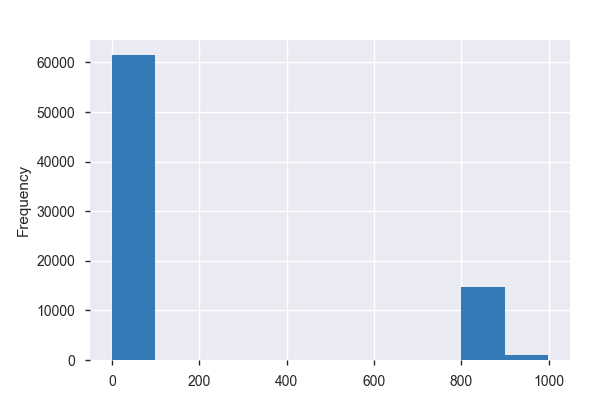

**Common Values**

| Value | Count | Frequency (%) |  |
| --- | --- | --- | --- |
| 99.0 | 44225 | 57.4% |  |
| 888.0 | 14625 | 19.0% |  |
| 4.0 | 4830 | 6.3% |  |
| 0.0 | 3094 | 4.0% |  |
| 2.0 | 2059 | 2.7% |  |
| 3.0 | 1278 | 1.7% |  |
| 8.0 | 1135 | 1.5% |  |
| 999.0 | 956 | 1.2% |  |
| 6.0 | 711 | 0.9% |  |
| 10.0 | 614 | 0.8% |  |
| Other values (70) | 3567 | 4.6% |  |

**Extreme Values**

Minimum 5 values

| Value | Count | Frequency (%) |  |
| --- | --- | --- | --- |
| 0.0 | 3094 | 4.0% |  |
| 1.0 | 448 | 0.6% |  |
| 2.0 | 2059 | 2.7% |  |
| 3.0 | 1278 | 1.7% |  |
| 3.5 | 1 | 0.0% |  |

Maximum 5 values

| Value | Count | Frequency (%) |  |
| --- | --- | --- | --- |
| 148.0 | 1 | 0.0% |  |
| 150.0 | 2 | 0.0% |  |
| 168.0 | 45 | 0.1% |  |
| 888.0 | 14625 | 19.0% |  |
| 999.0 | 956 | 1.2% |  |

v49_1  
Categorical

| Distinct count | 8 |
| --- | --- |
| Unique (%) | 0.0% |
| Missing (%) | 0.0% |
| Missing (n) | 9 |

| 99 | 45318 |
| --- | --- |
| niet van toepassing | 21140 |
| zeer tevreden | 8559 |
| Other values (4) | 2078 |

Toggle details

| Value | Count | Frequency (%) |  |
| --- | --- | --- | --- |
| 99 | 45318 | 58.8% |  |
| niet van toepassing | 21140 | 27.4% |  |
| zeer tevreden | 8559 | 11.1% |  |
| eerder tevreden | 1496 | 1.9% |  |
| helemaal niet tevreden | 317 | 0.4% |  |
| noch ontevreden, noch tevreden | 221 | 0.3% |  |
| eerder ontevreden | 44 | 0.1% |  |
| (Missing) | 9 | 0.0% |  |

v49_10  
Unsupported

*This variable is an unsupported type, check if it needs cleaning or further analysis*

| Unsupported value |
| --- |

v49_11  
Categorical

| Distinct count | 8 |
| --- | --- |
| Unique (%) | 0.0% |
| Missing (%) | 0.0% |
| Missing (n) | 9 |

| 99 | 50419 |
| --- | --- |
| niet van toepassing | 24018 |
| zeer tevreden | 1805 |
| Other values (4) | 853 |

Toggle details

| Value | Count | Frequency (%) |  |
| --- | --- | --- | --- |
| 99 | 50419 | 65.4% |  |
| niet van toepassing | 24018 | 31.2% |  |
| zeer tevreden | 1805 | 2.3% |  |
| eerder tevreden | 567 | 0.7% |  |
| noch ontevreden, noch tevreden | 152 | 0.2% |  |
| helemaal niet tevreden | 116 | 0.2% |  |
| eerder ontevreden | 18 | 0.0% |  |
| (Missing) | 9 | 0.0% |  |

v49_12  
Categorical

| Distinct count | 8 |
| --- | --- |
| Unique (%) | 0.0% |
| Missing (%) | 0.0% |
| Missing (n) | 9 |

| 99 | 51028 |
| --- | --- |
| niet van toepassing | 24226 |
| zeer tevreden | 1122 |
| Other values (4) | 719 |

Toggle details

| Value | Count | Frequency (%) |  |
| --- | --- | --- | --- |
| 99 | 51028 | 66.2% |  |
| niet van toepassing | 24226 | 31.4% |  |
| zeer tevreden | 1122 | 1.5% |  |
| eerder tevreden | 445 | 0.6% |  |
| noch ontevreden, noch tevreden | 166 | 0.2% |  |
| helemaal niet tevreden | 83 | 0.1% |  |
| eerder ontevreden | 25 | 0.0% |  |
| (Missing) | 9 | 0.0% |  |

v49_13  
Categorical

| Distinct count | 8 |
| --- | --- |
| Unique (%) | 0.0% |
| Missing (%) | 0.0% |
| Missing (n) | 9 |

| 99 | 49466 |
| --- | --- |
| niet van toepassing | 23374 |
| zeer tevreden | 2464 |
| Other values (4) | 1791 |

Toggle details

| Value | Count | Frequency (%) |  |
| --- | --- | --- | --- |
| 99 | 49466 | 64.2% |  |
| niet van toepassing | 23374 | 30.3% |  |
| zeer tevreden | 2464 | 3.2% |  |
| eerder tevreden | 1198 | 1.6% |  |
| noch ontevreden, noch tevreden | 319 | 0.4% |  |
| helemaal niet tevreden | 193 | 0.3% |  |
| eerder ontevreden | 81 | 0.1% |  |
| (Missing) | 9 | 0.0% |  |

v49_14  
Categorical

| Distinct count | 9 |
| --- | --- |
| Unique (%) | 0.0% |
| Missing (%) | 0.0% |
| Missing (n) | 9 |

| 99 | 50844 |
| --- | --- |
| niet van toepassing | 24675 |
| 99 | 1024 |
| Other values (5) | 552 |

Toggle details

| Value | Count | Frequency (%) |  |
| --- | --- | --- | --- |
| 99 | 50844 | 65.9% |  |
| niet van toepassing | 24675 | 32.0% |  |
| 99 | 1024 | 1.3% |  |
| zeer tevreden | 279 | 0.4% |  |
| eerder tevreden | 112 | 0.1% |  |
| noch ontevreden, noch tevreden | 103 | 0.1% |  |
| helemaal niet tevreden | 52 | 0.1% |  |
| eerder ontevreden | 6 | 0.0% |  |
| (Missing) | 9 | 0.0% |  |

v49_15  
Categorical

| Distinct count | 8 |
| --- | --- |
| Unique (%) | 0.0% |
| Missing (%) | 0.0% |
| Missing (n) | 9 |

| 99 | 51727 |
| --- | --- |
| niet van toepassing | 24676 |
| zeer tevreden | 283 |
| Other values (4) | 409 |

Toggle details

| Value | Count | Frequency (%) |  |
| --- | --- | --- | --- |
| 99 | 51727 | 67.1% |  |
| niet van toepassing | 24676 | 32.0% |  |
| zeer tevreden | 283 | 0.4% |  |
| eerder tevreden | 204 | 0.3% |  |
| noch ontevreden, noch tevreden | 126 | 0.2% |  |
| helemaal niet tevreden | 59 | 0.1% |  |
| eerder ontevreden | 20 | 0.0% |  |
| (Missing) | 9 | 0.0% |  |

v49_16  
Categorical

| Distinct count | 8 |
| --- | --- |
| Unique (%) | 0.0% |
| Missing (%) | 0.0% |
| Missing (n) | 9 |

| 99 | 51489 |
| --- | --- |
| niet van toepassing | 24588 |
| zeer tevreden | 518 |
| Other values (4) | 500 |

Toggle details

| Value | Count | Frequency (%) |  |
| --- | --- | --- | --- |
| 99 | 51489 | 66.8% |  |
| niet van toepassing | 24588 | 31.9% |  |
| zeer tevreden | 518 | 0.7% |  |
| eerder tevreden | 277 | 0.4% |  |
| noch ontevreden, noch tevreden | 127 | 0.2% |  |
| helemaal niet tevreden | 71 | 0.1% |  |
| eerder ontevreden | 25 | 0.0% |  |
| (Missing) | 9 | 0.0% |  |

v49_17  
Categorical

| Distinct count | 8 |
| --- | --- |
| Unique (%) | 0.0% |
| Missing (%) | 0.0% |
| Missing (n) | 9 |

| 99 | 51882 |
| --- | --- |
| niet van toepassing | 24761 |
| zeer tevreden | 188 |
| Other values (4) | 264 |

Toggle details

| Value | Count | Frequency (%) |  |
| --- | --- | --- | --- |
| 99 | 51882 | 67.3% |  |
| niet van toepassing | 24761 | 32.1% |  |
| zeer tevreden | 188 | 0.2% |  |
| eerder tevreden | 110 | 0.1% |  |
| noch ontevreden, noch tevreden | 101 | 0.1% |  |
| helemaal niet tevreden | 45 | 0.1% |  |
| eerder ontevreden | 8 | 0.0% |  |
| (Missing) | 9 | 0.0% |  |

v49_18  
Categorical

| Distinct count | 8 |
| --- | --- |
| Unique (%) | 0.0% |
| Missing (%) | 0.0% |
| Missing (n) | 9 |

| 99 | 51835 |
| --- | --- |
| niet van toepassing | 24780 |
| zeer tevreden | 210 |
| Other values (4) | 270 |

Toggle details

| Value | Count | Frequency (%) |  |
| --- | --- | --- | --- |
| 99 | 51835 | 67.2% |  |
| niet van toepassing | 24780 | 32.1% |  |
| zeer tevreden | 210 | 0.3% |  |
| eerder tevreden | 114 | 0.1% |  |
| noch ontevreden, noch tevreden | 107 | 0.1% |  |
| helemaal niet tevreden | 43 | 0.1% |  |
| eerder ontevreden | 6 | 0.0% |  |
| (Missing) | 9 | 0.0% |  |

v49_19  
Categorical

| Distinct count | 9 |
| --- | --- |
| Unique (%) | 0.0% |
| Missing (%) | 0.0% |
| Missing (n) | 9 |

| 99 | 50564 |
| --- | --- |
| niet van toepassing | 24711 |
| 99 | 1024 |
| Other values (5) | 796 |

Toggle details

| Value | Count | Frequency (%) |  |
| --- | --- | --- | --- |
| 99 | 50564 | 65.6% |  |
| niet van toepassing | 24711 | 32.0% |  |
| 99 | 1024 | 1.3% |  |
| eerder tevreden | 285 | 0.4% |  |
| noch ontevreden, noch tevreden | 208 | 0.3% |  |
| zeer tevreden | 208 | 0.3% |  |
| helemaal niet tevreden | 64 | 0.1% |  |
| eerder ontevreden | 31 | 0.0% |  |
| (Missing) | 9 | 0.0% |  |

v49_2  
Categorical

| Distinct count | 8 |
| --- | --- |
| Unique (%) | 0.0% |
| Missing (%) | 0.0% |
| Missing (n) | 9 |

| 99 | 44751 |
| --- | --- |
| niet van toepassing | 21290 |
| zeer tevreden | 8191 |
| Other values (4) | 2863 |

Toggle details

| Value | Count | Frequency (%) |  |
| --- | --- | --- | --- |
| 99 | 44751 | 58.0% |  |
| niet van toepassing | 21290 | 27.6% |  |
| zeer tevreden | 8191 | 10.6% |  |
| eerder tevreden | 2147 | 2.8% |  |
| noch ontevreden, noch tevreden | 327 | 0.4% |  |
| helemaal niet tevreden | 285 | 0.4% |  |
| eerder ontevreden | 104 | 0.1% |  |
| (Missing) | 9 | 0.0% |  |

v49_20  
Categorical

| Distinct count | 8 |
| --- | --- |
| Unique (%) | 0.0% |
| Missing (%) | 0.0% |
| Missing (n) | 9 |

| 99 | 51873 |
| --- | --- |
| niet van toepassing | 24598 |
| zeer tevreden | 269 |
| Other values (4) | 355 |

Toggle details

| Value | Count | Frequency (%) |  |
| --- | --- | --- | --- |
| 99 | 51873 | 67.3% |  |
| niet van toepassing | 24598 | 31.9% |  |
| zeer tevreden | 269 | 0.3% |  |
| eerder tevreden | 171 | 0.2% |  |
| noch ontevreden, noch tevreden | 108 | 0.1% |  |
| helemaal niet tevreden | 57 | 0.1% |  |
| eerder ontevreden | 19 | 0.0% |  |
| (Missing) | 9 | 0.0% |  |

v49_21  
Categorical

| Distinct count | 9 |
| --- | --- |
| Unique (%) | 0.0% |
| Missing (%) | 0.0% |
| Missing (n) | 9 |

| 99 | 46891 |
| --- | --- |
| niet van toepassing | 24833 |
| 99 | 5120 |
| Other values (5) | 251 |

Toggle details

| Value | Count | Frequency (%) |  |
| --- | --- | --- | --- |
| 99 | 46891 | 60.8% |  |
| niet van toepassing | 24833 | 32.2% |  |
| 99 | 5120 | 6.6% |  |
| noch ontevreden, noch tevreden | 76 | 0.1% |  |
| zeer tevreden | 71 | 0.1% |  |
| helemaal niet tevreden | 48 | 0.1% |  |
| eerder tevreden | 44 | 0.1% |  |
| eerder ontevreden | 12 | 0.0% |  |
| (Missing) | 9 | 0.0% |  |

v49_3  
Categorical

| Distinct count | 8 |
| --- | --- |
| Unique (%) | 0.0% |
| Missing (%) | 0.0% |
| Missing (n) | 9 |

| 99 | 47424 |
| --- | --- |
| niet van toepassing | 22487 |
| zeer tevreden | 5181 |
| Other values (4) | 2003 |

Toggle details

| Value | Count | Frequency (%) |  |
| --- | --- | --- | --- |
| 99 | 47424 | 61.5% |  |
| niet van toepassing | 22487 | 29.2% |  |
| zeer tevreden | 5181 | 6.7% |  |
| eerder tevreden | 1448 | 1.9% |  |
| noch ontevreden, noch tevreden | 322 | 0.4% |  |
| helemaal niet tevreden | 171 | 0.2% |  |
| eerder ontevreden | 62 | 0.1% |  |
| (Missing) | 9 | 0.0% |  |

v49_4  
Categorical

| Distinct count | 8 |
| --- | --- |
| Unique (%) | 0.0% |
| Missing (%) | 0.0% |
| Missing (n) | 9 |

| 99 | 48645 |
| --- | --- |
| niet van toepassing | 23237 |
| zeer tevreden | 2893 |
| Other values (4) | 2320 |

Toggle details

| Value | Count | Frequency (%) |  |
| --- | --- | --- | --- |
| 99 | 48645 | 63.1% |  |
| niet van toepassing | 23237 | 30.1% |  |
| zeer tevreden | 2893 | 3.8% |  |
| eerder tevreden | 1538 | 2.0% |  |
| noch ontevreden, noch tevreden | 560 | 0.7% |  |
| helemaal niet tevreden | 155 | 0.2% |  |
| eerder ontevreden | 67 | 0.1% |  |
| (Missing) | 9 | 0.0% |  |

v49_5  
Categorical

| Distinct count | 8 |
| --- | --- |
| Unique (%) | 0.0% |
| Missing (%) | 0.0% |
| Missing (n) | 9 |

| 99 | 48543 |
| --- | --- |
| niet van toepassing | 23102 |
| zeer tevreden | 2749 |
| Other values (4) | 2701 |

Toggle details

| Value | Count | Frequency (%) |  |
| --- | --- | --- | --- |
| 99 | 48543 | 63.0% |  |
| niet van toepassing | 23102 | 30.0% |  |
| zeer tevreden | 2749 | 3.6% |  |
| eerder tevreden | 1930 | 2.5% |  |
| noch ontevreden, noch tevreden | 601 | 0.8% |  |
| helemaal niet tevreden | 118 | 0.2% |  |
| eerder ontevreden | 52 | 0.1% |  |
| (Missing) | 9 | 0.0% |  |

v49_6  
Categorical

| Distinct count | 8 |
| --- | --- |
| Unique (%) | 0.0% |
| Missing (%) | 0.0% |
| Missing (n) | 9 |

| 99 | 48205 |
| --- | --- |
| niet van toepassing | 22862 |
| zeer tevreden | 3103 |
| Other values (4) | 2925 |

Toggle details

| Value | Count | Frequency (%) |  |
| --- | --- | --- | --- |
| 99 | 48205 | 62.5% |  |
| niet van toepassing | 22862 | 29.7% |  |
| zeer tevreden | 3103 | 4.0% |  |
| eerder tevreden | 2088 | 2.7% |  |
| noch ontevreden, noch tevreden | 619 | 0.8% |  |
| helemaal niet tevreden | 138 | 0.2% |  |
| eerder ontevreden | 80 | 0.1% |  |
| (Missing) | 9 | 0.0% |  |

v49_7  
Categorical

| Distinct count | 8 |
| --- | --- |
| Unique (%) | 0.0% |
| Missing (%) | 0.0% |
| Missing (n) | 9 |

| 99 | 47472 |
| --- | --- |
| niet van toepassing | 22440 |
| zeer tevreden | 4533 |
| Other values (4) | 2650 |

Toggle details

| Value | Count | Frequency (%) |  |
| --- | --- | --- | --- |
| 99 | 47472 | 61.6% |  |
| niet van toepassing | 22440 | 29.1% |  |
| zeer tevreden | 4533 | 5.9% |  |
| eerder tevreden | 2052 | 2.7% |  |
| noch ontevreden, noch tevreden | 379 | 0.5% |  |
| helemaal niet tevreden | 167 | 0.2% |  |
| eerder ontevreden | 52 | 0.1% |  |
| (Missing) | 9 | 0.0% |  |

v49_8  
Categorical

| Distinct count | 8 |
| --- | --- |
| Unique (%) | 0.0% |
| Missing (%) | 0.0% |
| Missing (n) | 9 |

| 99 | 51334 |
| --- | --- |
| niet van toepassing | 24501 |
| zeer tevreden | 517 |
| Other values (4) | 743 |

Toggle details

| Value | Count | Frequency (%) |  |
| --- | --- | --- | --- |
| 99 | 51334 | 66.6% |  |
| niet van toepassing | 24501 | 31.8% |  |
| zeer tevreden | 517 | 0.7% |  |
| eerder tevreden | 382 | 0.5% |  |
| noch ontevreden, noch tevreden | 253 | 0.3% |  |
| helemaal niet tevreden | 81 | 0.1% |  |
| eerder ontevreden | 27 | 0.0% |  |
| (Missing) | 9 | 0.0% |  |

v49_9  
Categorical

| Distinct count | 8 |
| --- | --- |
| Unique (%) | 0.0% |
| Missing (%) | 0.0% |
| Missing (n) | 9 |

| 99 | 51841 |
| --- | --- |
| niet van toepassing | 24777 |
| zeer tevreden | 184 |
| Other values (4) | 293 |

Toggle details

| Value | Count | Frequency (%) |  |
| --- | --- | --- | --- |
| 99 | 51841 | 67.2% |  |
| niet van toepassing | 24777 | 32.1% |  |
| zeer tevreden | 184 | 0.2% |  |
| noch ontevreden, noch tevreden | 117 | 0.2% |  |
| eerder tevreden | 115 | 0.1% |  |
| helemaal niet tevreden | 51 | 0.1% |  |
| eerder ontevreden | 10 | 0.0% |  |
| (Missing) | 9 | 0.0% |  |

v5  
Categorical

| Distinct count | 33 |
| --- | --- |
| Unique (%) | 0.0% |
| Missing (%) | 86.8% |
| Missing (n) | 66934 |

| België | 9652 |
| --- | --- |
| Nederland | 142 |
| 99 | 136 |
| Other values (29) | 240 |
| (Missing) | 66934 |

Toggle details

| Value | Count | Frequency (%) |  |
| --- | --- | --- | --- |
| België | 9652 | 12.5% |  |
| Nederland | 142 | 0.2% |  |
| 99 | 136 | 0.2% |  |
| Italië | 82 | 0.1% |  |
| Marokko | 29 | 0.0% |  |
| Duitsland | 23 | 0.0% |  |
| Frankrijk | 19 | 0.0% |  |
| niet-belg | 16 | 0.0% |  |
| Groot-Brittannië | 13 | 0.0% |  |
| Spanje | 12 | 0.0% |  |
| Other values (22) | 46 | 0.1% |  |
| (Missing) | 66934 | 86.8% |  |

v50_1  
Categorical

| Distinct count | 5 |
| --- | --- |
| Unique (%) | 0.0% |
| Missing (%) | 0.0% |
| Missing (n) | 9 |

| 99 | 51805 |
| --- | --- |
| 888 | 15171 |
| neen | 8589 |

Toggle details

| Value | Count | Frequency (%) |  |
| --- | --- | --- | --- |
| 99 | 51805 | 67.2% |  |
| 888 | 15171 | 19.7% |  |
| neen | 8589 | 11.1% |  |
| ja | 1530 | 2.0% |  |
| (Missing) | 9 | 0.0% |  |

v50_10  
Categorical

| Distinct count | 5 |
| --- | --- |
| Unique (%) | 0.0% |
| Missing (%) | 0.0% |
| Missing (n) | 9 |

| 99 | 52123 |
| --- | --- |
| 888 | 15171 |
| neen | 9146 |

Toggle details

| Value | Count | Frequency (%) |  |
| --- | --- | --- | --- |
| 99 | 52123 | 67.6% |  |
| 888 | 15171 | 19.7% |  |
| neen | 9146 | 11.9% |  |
| ja | 655 | 0.8% |  |
| (Missing) | 9 | 0.0% |  |

v50_11  
Categorical

| Distinct count | 4 |
| --- | --- |
| Unique (%) | 0.0% |
| Missing (%) | 94.9% |
| Missing (n) | 73208 |

| 99 | 3221 |
| --- | --- |
| neen | 625 |
| ja | 50 |
| (Missing) | 73208 |

Toggle details

| Value | Count | Frequency (%) |  |
| --- | --- | --- | --- |
| 99 | 3221 | 4.2% |  |
| neen | 625 | 0.8% |  |
| ja | 50 | 0.1% |  |
| (Missing) | 73208 | 94.9% |  |

v50_2  
Categorical

| Distinct count | 5 |
| --- | --- |
| Unique (%) | 0.0% |
| Missing (%) | 0.0% |
| Missing (n) | 9 |

| 99 | 52028 |
| --- | --- |
| 888 | 15171 |
| neen | 9439 |

Toggle details

| Value | Count | Frequency (%) |  |
| --- | --- | --- | --- |
| 99 | 52028 | 67.5% |  |
| 888 | 15171 | 19.7% |  |
| neen | 9439 | 12.2% |  |
| ja | 457 | 0.6% |  |
| (Missing) | 9 | 0.0% |  |

v50_3  
Categorical

| Distinct count | 5 |
| --- | --- |
| Unique (%) | 0.0% |
| Missing (%) | 0.0% |
| Missing (n) | 9 |

| 99 | 52073 |
| --- | --- |
| 888 | 15171 |
| neen | 8229 |

Toggle details

| Value | Count | Frequency (%) |  |
| --- | --- | --- | --- |
| 99 | 52073 | 67.5% |  |
| 888 | 15171 | 19.7% |  |
| neen | 8229 | 10.7% |  |
| ja | 1622 | 2.1% |  |
| (Missing) | 9 | 0.0% |  |

v50_4  
Categorical

| Distinct count | 5 |
| --- | --- |
| Unique (%) | 0.0% |
| Missing (%) | 0.0% |
| Missing (n) | 9 |

| 99 | 52088 |
| --- | --- |
| 888 | 15171 |
| neen | 8858 |

Toggle details

| Value | Count | Frequency (%) |  |
| --- | --- | --- | --- |
| 99 | 52088 | 67.6% |  |
| 888 | 15171 | 19.7% |  |
| neen | 8858 | 11.5% |  |
| ja | 978 | 1.3% |  |
| (Missing) | 9 | 0.0% |  |

v50_5  
Categorical

| Distinct count | 4 |
| --- | --- |
| Unique (%) | 0.0% |
| Missing (%) | 94.9% |
| Missing (n) | 73208 |

| 99 | 3221 |
| --- | --- |
| neen | 653 |
| ja | 22 |
| (Missing) | 73208 |

Toggle details

| Value | Count | Frequency (%) |  |
| --- | --- | --- | --- |
| 99 | 3221 | 4.2% |  |
| neen | 653 | 0.8% |  |
| ja | 22 | 0.0% |  |
| (Missing) | 73208 | 94.9% |  |

v50_6  
Categorical

| Distinct count | 5 |
| --- | --- |
| Unique (%) | 0.0% |
| Missing (%) | 0.0% |
| Missing (n) | 9 |

| 99 | 52288 |
| --- | --- |
| 888 | 15171 |
| neen | 8221 |

Toggle details

| Value | Count | Frequency (%) |  |
| --- | --- | --- | --- |
| 99 | 52288 | 67.8% |  |
| 888 | 15171 | 19.7% |  |
| neen | 8221 | 10.7% |  |
| ja | 1415 | 1.8% |  |
| (Missing) | 9 | 0.0% |  |

v50_7  
Categorical

| Distinct count | 5 |
| --- | --- |
| Unique (%) | 0.0% |
| Missing (%) | 0.0% |
| Missing (n) | 9 |

| 99 | 52103 |
| --- | --- |
| 888 | 15171 |
| neen | 7586 |

Toggle details

| Value | Count | Frequency (%) |  |
| --- | --- | --- | --- |
| 99 | 52103 | 67.6% |  |
| 888 | 15171 | 19.7% |  |
| neen | 7586 | 9.8% |  |
| ja | 2235 | 2.9% |  |
| (Missing) | 9 | 0.0% |  |

v50_8  
Categorical

| Distinct count | 5 |
| --- | --- |
| Unique (%) | 0.0% |
| Missing (%) | 0.0% |
| Missing (n) | 9 |

| 99 | 52142 |
| --- | --- |
| 888 | 15171 |
| neen | 9049 |

Toggle details

| Value | Count | Frequency (%) |  |
| --- | --- | --- | --- |
| 99 | 52142 | 67.6% |  |
| 888 | 15171 | 19.7% |  |
| neen | 9049 | 11.7% |  |
| ja | 733 | 1.0% |  |
| (Missing) | 9 | 0.0% |  |

v50_9  
Categorical

| Distinct count | 5 |
| --- | --- |
| Unique (%) | 0.0% |
| Missing (%) | 0.0% |
| Missing (n) | 9 |

| 99 | 52148 |
| --- | --- |
| 888 | 15171 |
| neen | 9499 |

Toggle details

| Value | Count | Frequency (%) |  |
| --- | --- | --- | --- |
| 99 | 52148 | 67.6% |  |
| 888 | 15171 | 19.7% |  |
| neen | 9499 | 12.3% |  |
| ja | 277 | 0.4% |  |
| (Missing) | 9 | 0.0% |  |

v51_1  
Unsupported

*This variable is an unsupported type, check if it needs cleaning or further analysis*

| Unsupported value |
| --- |

v51_2  
Unsupported

*This variable is an unsupported type, check if it needs cleaning or further analysis*

| Unsupported value |
| --- |

v51_3  
Unsupported

*This variable is an unsupported type, check if it needs cleaning or further analysis*

| Unsupported value |
| --- |

v51_4  
Unsupported

*This variable is an unsupported type, check if it needs cleaning or further analysis*

| Unsupported value |
| --- |

v51_5  
Unsupported

*This variable is an unsupported type, check if it needs cleaning or further analysis*

| Unsupported value |
| --- |

v51_6  
Unsupported

*This variable is an unsupported type, check if it needs cleaning or further analysis*

| Unsupported value |
| --- |

v51_7  
Unsupported

*This variable is an unsupported type, check if it needs cleaning or further analysis*

| Unsupported value |
| --- |

v51_8  
Unsupported

*This variable is an unsupported type, check if it needs cleaning or further analysis*

| Unsupported value |
| --- |

v51_9  
Unsupported

*This variable is an unsupported type, check if it needs cleaning or further analysis*

| Unsupported value |
| --- |

v52  
Unsupported

*This variable is an unsupported type, check if it needs cleaning or further analysis*

| Unsupported value |
| --- |

v53  
Unsupported

*This variable is an unsupported type, check if it needs cleaning or further analysis*

| Unsupported value |
| --- |

v54_1  
Categorical

| Distinct count | 7 |
| --- | --- |
| Unique (%) | 0.0% |
| Missing (%) | 0.0% |
| Missing (n) | 9 |

| mee eens | 21144 |
| --- | --- |
| noch mee eens/ noch mee oneens | 19418 |
| helemaal mee eens | 15136 |
| Other values (3) | 21397 |

Toggle details

| Value | Count | Frequency (%) |  |
| --- | --- | --- | --- |
| mee eens | 21144 | 27.4% |  |
| noch mee eens/ noch mee oneens | 19418 | 25.2% |  |
| helemaal mee eens | 15136 | 19.6% |  |
| 99 | 9934 | 12.9% |  |
| helemaal oneens | 5895 | 7.6% |  |
| mee oneens | 5568 | 7.2% |  |
| (Missing) | 9 | 0.0% |  |

v54_10  
Categorical

| Distinct count | 7 |
| --- | --- |
| Unique (%) | 0.0% |
| Missing (%) | 0.0% |
| Missing (n) | 9 |

| noch mee eens/ noch mee oneens | 18782 |
| --- | --- |
| mee oneens | 14153 |
| helemaal oneens | 13037 |
| Other values (3) | 31123 |

Toggle details

| Value | Count | Frequency (%) |  |
| --- | --- | --- | --- |
| noch mee eens/ noch mee oneens | 18782 | 24.4% |  |
| mee oneens | 14153 | 18.4% |  |
| helemaal oneens | 13037 | 16.9% |  |
| mee eens | 12405 | 16.1% |  |
| 99 | 12200 | 15.8% |  |
| helemaal mee eens | 6518 | 8.5% |  |
| (Missing) | 9 | 0.0% |  |

v54_11  
Categorical

| Distinct count | 7 |
| --- | --- |
| Unique (%) | 0.0% |
| Missing (%) | 0.0% |
| Missing (n) | 9 |

| helemaal oneens | 18742 |
| --- | --- |
| mee oneens | 17451 |
| noch mee eens/ noch mee oneens | 17158 |
| Other values (3) | 23744 |

Toggle details

| Value | Count | Frequency (%) |  |
| --- | --- | --- | --- |
| helemaal oneens | 18742 | 24.3% |  |
| mee oneens | 17451 | 22.6% |  |
| noch mee eens/ noch mee oneens | 17158 | 22.3% |  |
| 99 | 11507 | 14.9% |  |
| mee eens | 7129 | 9.2% |  |
| helemaal mee eens | 5108 | 6.6% |  |
| (Missing) | 9 | 0.0% |  |

v54_2  
Categorical

| Distinct count | 7 |
| --- | --- |
| Unique (%) | 0.0% |
| Missing (%) | 0.0% |
| Missing (n) | 9 |

| mee eens | 27167 |
| --- | --- |
| noch mee eens/ noch mee oneens | 15070 |
| helemaal mee eens | 13606 |
| Other values (3) | 21252 |

Toggle details

| Value | Count | Frequency (%) |  |
| --- | --- | --- | --- |
| mee eens | 27167 | 35.2% |  |
| noch mee eens/ noch mee oneens | 15070 | 19.5% |  |
| helemaal mee eens | 13606 | 17.6% |  |
| 99 | 12108 | 15.7% |  |
| mee oneens | 4779 | 6.2% |  |
| helemaal oneens | 4365 | 5.7% |  |
| (Missing) | 9 | 0.0% |  |

v54_3  
Categorical

| Distinct count | 7 |
| --- | --- |
| Unique (%) | 0.0% |
| Missing (%) | 0.0% |
| Missing (n) | 9 |

| noch mee eens/ noch mee oneens | 23746 |
| --- | --- |
| mee eens | 17640 |
| 99 | 11577 |
| Other values (3) | 24132 |

Toggle details

| Value | Count | Frequency (%) |  |
| --- | --- | --- | --- |
| noch mee eens/ noch mee oneens | 23746 | 30.8% |  |
| mee eens | 17640 | 22.9% |  |
| 99 | 11577 | 15.0% |  |
| helemaal mee eens | 9874 | 12.8% |  |
| mee oneens | 9186 | 11.9% |  |
| helemaal oneens | 5072 | 6.6% |  |
| (Missing) | 9 | 0.0% |  |

v54_4  
Categorical

| Distinct count | 7 |
| --- | --- |
| Unique (%) | 0.0% |
| Missing (%) | 0.0% |
| Missing (n) | 9 |

| noch mee eens/ noch mee oneens | 20814 |
| --- | --- |
| mee eens | 16544 |
| 99 | 12523 |
| Other values (3) | 27214 |

Toggle details

| Value | Count | Frequency (%) |  |
| --- | --- | --- | --- |
| noch mee eens/ noch mee oneens | 20814 | 27.0% |  |
| mee eens | 16544 | 21.5% |  |
| 99 | 12523 | 16.2% |  |
| mee oneens | 11663 | 15.1% |  |
| helemaal mee eens | 7804 | 10.1% |  |
| helemaal oneens | 7747 | 10.0% |  |
| (Missing) | 9 | 0.0% |  |

v54_5  
Categorical

| Distinct count | 7 |
| --- | --- |
| Unique (%) | 0.0% |
| Missing (%) | 0.0% |
| Missing (n) | 9 |

| noch mee eens/ noch mee oneens | 20183 |
| --- | --- |
| mee eens | 14725 |
| mee oneens | 13564 |
| Other values (3) | 28623 |

Toggle details

| Value | Count | Frequency (%) |  |
| --- | --- | --- | --- |
| noch mee eens/ noch mee oneens | 20183 | 26.2% |  |
| mee eens | 14725 | 19.1% |  |
| mee oneens | 13564 | 17.6% |  |
| 99 | 11330 | 14.7% |  |
| helemaal mee eens | 8695 | 11.3% |  |
| helemaal oneens | 8598 | 11.2% |  |
| (Missing) | 9 | 0.0% |  |

v54_6  
Categorical

| Distinct count | 7 |
| --- | --- |
| Unique (%) | 0.0% |
| Missing (%) | 0.0% |
| Missing (n) | 9 |

| mee eens | 26463 |
| --- | --- |
| noch mee eens/ noch mee oneens | 17283 |
| 99 | 13372 |
| Other values (3) | 19977 |

Toggle details

| Value | Count | Frequency (%) |  |
| --- | --- | --- | --- |
| mee eens | 26463 | 34.3% |  |
| noch mee eens/ noch mee oneens | 17283 | 22.4% |  |
| 99 | 13372 | 17.3% |  |
| helemaal mee eens | 13186 | 17.1% |  |
| mee oneens | 3815 | 4.9% |  |
| helemaal oneens | 2976 | 3.9% |  |
| (Missing) | 9 | 0.0% |  |

v54_7  
Categorical

| Distinct count | 7 |
| --- | --- |
| Unique (%) | 0.0% |
| Missing (%) | 0.0% |
| Missing (n) | 9 |

| noch mee eens/ noch mee oneens | 20576 |
| --- | --- |
| mee oneens | 15234 |
| 99 | 12824 |
| Other values (3) | 28461 |

Toggle details

| Value | Count | Frequency (%) |  |
| --- | --- | --- | --- |
| noch mee eens/ noch mee oneens | 20576 | 26.7% |  |
| mee oneens | 15234 | 19.8% |  |
| 99 | 12824 | 16.6% |  |
| helemaal oneens | 11586 | 15.0% |  |
| mee eens | 11422 | 14.8% |  |
| helemaal mee eens | 5453 | 7.1% |  |
| (Missing) | 9 | 0.0% |  |

v54_8  
Categorical

| Distinct count | 7 |
| --- | --- |
| Unique (%) | 0.0% |
| Missing (%) | 0.0% |
| Missing (n) | 9 |

| mee eens | 29121 |
| --- | --- |
| helemaal mee eens | 18478 |
| noch mee eens/ noch mee oneens | 13461 |
| Other values (3) | 16035 |

Toggle details

| Value | Count | Frequency (%) |  |
| --- | --- | --- | --- |
| mee eens | 29121 | 37.8% |  |
| helemaal mee eens | 18478 | 24.0% |  |
| noch mee eens/ noch mee oneens | 13461 | 17.5% |  |
| 99 | 10868 | 14.1% |  |
| helemaal oneens | 2797 | 3.6% |  |
| mee oneens | 2370 | 3.1% |  |
| (Missing) | 9 | 0.0% |  |

v54_9  
Categorical

| Distinct count | 7 |
| --- | --- |
| Unique (%) | 0.0% |
| Missing (%) | 0.0% |
| Missing (n) | 9 |

| noch mee eens/ noch mee oneens | 25516 |
| --- | --- |
| 99 | 13636 |
| mee oneens | 12521 |
| Other values (3) | 25422 |

Toggle details

| Value | Count | Frequency (%) |  |
| --- | --- | --- | --- |
| noch mee eens/ noch mee oneens | 25516 | 33.1% |  |
| 99 | 13636 | 17.7% |  |
| mee oneens | 12521 | 16.2% |  |
| mee eens | 12156 | 15.8% |  |
| helemaal oneens | 7474 | 9.7% |  |
| helemaal mee eens | 5792 | 7.5% |  |
| (Missing) | 9 | 0.0% |  |

v55_1  
Categorical

| Distinct count | 6 |
| --- | --- |
| Unique (%) | 0.0% |
| Missing (%) | 0.0% |
| Missing (n) | 9 |

| nooit | 31364 |
| --- | --- |
| zelden | 17438 |
| soms | 16212 |
| Other values (2) | 12081 |

Toggle details

| Value | Count | Frequency (%) |  |
| --- | --- | --- | --- |
| nooit | 31364 | 40.7% |  |
| zelden | 17438 | 22.6% |  |
| soms | 16212 | 21.0% |  |
| 99 | 6684 | 8.7% |  |
| vaak | 5397 | 7.0% |  |
| (Missing) | 9 | 0.0% |  |

v55_2  
Categorical

| Distinct count | 6 |
| --- | --- |
| Unique (%) | 0.0% |
| Missing (%) | 0.0% |
| Missing (n) | 9 |

| nooit | 53493 |
| --- | --- |
| zelden | 12779 |
| 99 | 6682 |
| Other values (2) | 4141 |

Toggle details

| Value | Count | Frequency (%) |  |
| --- | --- | --- | --- |
| nooit | 53493 | 69.4% |  |
| zelden | 12779 | 16.6% |  |
| 99 | 6682 | 8.7% |  |
| soms | 3387 | 4.4% |  |
| vaak | 754 | 1.0% |  |
| (Missing) | 9 | 0.0% |  |

v55_3  
Categorical

| Distinct count | 6 |
| --- | --- |
| Unique (%) | 0.0% |
| Missing (%) | 0.0% |
| Missing (n) | 9 |

| nooit | 38913 |
| --- | --- |
| zelden | 15480 |
| soms | 10446 |
| Other values (2) | 12256 |

Toggle details

| Value | Count | Frequency (%) |  |
| --- | --- | --- | --- |
| nooit | 38913 | 50.5% |  |
| zelden | 15480 | 20.1% |  |
| soms | 10446 | 13.5% |  |
| 99 | 6701 | 8.7% |  |
| vaak | 5555 | 7.2% |  |
| (Missing) | 9 | 0.0% |  |

v55_4  
Categorical

| Distinct count | 6 |
| --- | --- |
| Unique (%) | 0.0% |
| Missing (%) | 0.0% |
| Missing (n) | 9 |

| nooit | 35932 |
| --- | --- |
| zelden | 17108 |
| soms | 12552 |
| Other values (2) | 11503 |

Toggle details

| Value | Count | Frequency (%) |  |
| --- | --- | --- | --- |
| nooit | 35932 | 46.6% |  |
| zelden | 17108 | 22.2% |  |
| soms | 12552 | 16.3% |  |
| 99 | 6706 | 8.7% |  |
| vaak | 4797 | 6.2% |  |
| (Missing) | 9 | 0.0% |  |

v55_5  
Categorical

| Distinct count | 6 |
| --- | --- |
| Unique (%) | 0.0% |
| Missing (%) | 0.0% |
| Missing (n) | 9 |

| nooit | 32523 |
| --- | --- |
| zelden | 18104 |
| soms | 14830 |
| Other values (2) | 11638 |

Toggle details

| Value | Count | Frequency (%) |  |
| --- | --- | --- | --- |
| nooit | 32523 | 42.2% |  |
| zelden | 18104 | 23.5% |  |
| soms | 14830 | 19.2% |  |
| 99 | 6704 | 8.7% |  |
| vaak | 4934 | 6.4% |  |
| (Missing) | 9 | 0.0% |  |

v55_6  
Categorical

| Distinct count | 6 |
| --- | --- |
| Unique (%) | 0.0% |
| Missing (%) | 0.0% |
| Missing (n) | 9 |

| nooit | 29998 |
| --- | --- |
| soms | 17106 |
| zelden | 14930 |
| Other values (2) | 15061 |

Toggle details

| Value | Count | Frequency (%) |  |
| --- | --- | --- | --- |
| nooit | 29998 | 38.9% |  |
| soms | 17106 | 22.2% |  |
| zelden | 14930 | 19.4% |  |
| vaak | 8394 | 10.9% |  |
| 99 | 6667 | 8.6% |  |
| (Missing) | 9 | 0.0% |  |

v55_7  
Categorical

| Distinct count | 6 |
| --- | --- |
| Unique (%) | 0.0% |
| Missing (%) | 0.0% |
| Missing (n) | 9 |

| nooit | 24753 |
| --- | --- |
| soms | 20185 |
| zelden | 17854 |
| Other values (2) | 14303 |

Toggle details

| Value | Count | Frequency (%) |  |
| --- | --- | --- | --- |
| nooit | 24753 | 32.1% |  |
| soms | 20185 | 26.2% |  |
| zelden | 17854 | 23.2% |  |
| vaak | 7633 | 9.9% |  |
| 99 | 6670 | 8.7% |  |
| (Missing) | 9 | 0.0% |  |

v55_8  
Categorical

| Distinct count | 6 |
| --- | --- |
| Unique (%) | 0.0% |
| Missing (%) | 0.0% |
| Missing (n) | 9 |

| nooit | 30653 |
| --- | --- |
| zelden | 19302 |
| soms | 14867 |
| Other values (2) | 12273 |

Toggle details

| Value | Count | Frequency (%) |  |
| --- | --- | --- | --- |
| nooit | 30653 | 39.8% |  |
| zelden | 19302 | 25.0% |  |
| soms | 14867 | 19.3% |  |
| 99 | 6708 | 8.7% |  |
| vaak | 5565 | 7.2% |  |
| (Missing) | 9 | 0.0% |  |

v56_1  
Categorical

| Distinct count | 7 |
| --- | --- |
| Unique (%) | 0.0% |
| Missing (%) | 0.0% |
| Missing (n) | 9 |

| meer dan 1 maal per week | 24728 |
| --- | --- |
| ongeveer wekelijks | 17141 |
| nooit | 14678 |
| Other values (3) | 20548 |

Toggle details

| Value | Count | Frequency (%) |  |
| --- | --- | --- | --- |
| meer dan 1 maal per week | 24728 | 32.1% |  |
| ongeveer wekelijks | 17141 | 22.2% |  |
| nooit | 14678 | 19.0% |  |
| zelden | 10142 | 13.2% |  |
| ongeveer maandelijks | 7087 | 9.2% |  |
| 99 | 3319 | 4.3% |  |
| (Missing) | 9 | 0.0% |  |

v56_10  
Categorical

| Distinct count | 7 |
| --- | --- |
| Unique (%) | 0.0% |
| Missing (%) | 0.0% |
| Missing (n) | 9 |

| nooit | 53846 |
| --- | --- |
| zelden | 12268 |
| 99 | 3423 |
| Other values (3) | 7558 |

Toggle details

| Value | Count | Frequency (%) |  |
| --- | --- | --- | --- |
| nooit | 53846 | 69.8% |  |
| zelden | 12268 | 15.9% |  |
| 99 | 3423 | 4.4% |  |
| ongeveer maandelijks | 2953 | 3.8% |  |
| ongeveer wekelijks | 2886 | 3.7% |  |
| meer dan 1 maal per week | 1719 | 2.2% |  |
| (Missing) | 9 | 0.0% |  |

v56_11  
Categorical

| Distinct count | 7 |
| --- | --- |
| Unique (%) | 0.0% |
| Missing (%) | 0.0% |
| Missing (n) | 9 |

| nooit | 29669 |
| --- | --- |
| zelden | 19400 |
| ongeveer maandelijks | 13855 |
| Other values (3) | 14171 |

Toggle details

| Value | Count | Frequency (%) |  |
| --- | --- | --- | --- |
| nooit | 29669 | 38.5% |  |
| zelden | 19400 | 25.2% |  |
| ongeveer maandelijks | 13855 | 18.0% |  |
| ongeveer wekelijks | 5991 | 7.8% |  |
| meer dan 1 maal per week | 4763 | 6.2% |  |
| 99 | 3417 | 4.4% |  |
| (Missing) | 9 | 0.0% |  |

v56_12  
Categorical

| Distinct count | 7 |
| --- | --- |
| Unique (%) | 0.0% |
| Missing (%) | 0.0% |
| Missing (n) | 9 |

| nooit | 24629 |
| --- | --- |
| zelden | 15466 |
| ongeveer wekelijks | 14296 |
| Other values (3) | 22704 |

Toggle details

| Value | Count | Frequency (%) |  |
| --- | --- | --- | --- |
| nooit | 24629 | 31.9% |  |
| zelden | 15466 | 20.1% |  |
| ongeveer wekelijks | 14296 | 18.5% |  |
| ongeveer maandelijks | 13170 | 17.1% |  |
| meer dan 1 maal per week | 6132 | 8.0% |  |
| 99 | 3402 | 4.4% |  |
| (Missing) | 9 | 0.0% |  |

v56_13  
Categorical

| Distinct count | 7 |
| --- | --- |
| Unique (%) | 0.0% |
| Missing (%) | 94.9% |
| Missing (n) | 73208 |

| nooit | 2329 |
| --- | --- |
| zelden | 790 |
| ongeveer maandelijks | 262 |
| Other values (3) | 515 |
| (Missing) | 73208 |

Toggle details

| Value | Count | Frequency (%) |  |
| --- | --- | --- | --- |
| nooit | 2329 | 3.0% |  |
| zelden | 790 | 1.0% |  |
| ongeveer maandelijks | 262 | 0.3% |  |
| ongeveer wekelijks | 246 | 0.3% |  |
| 99 | 197 | 0.3% |  |
| meer dan 1 maal per week | 72 | 0.1% |  |
| (Missing) | 73208 | 94.9% |  |

v56_13oudeVL  
Categorical

| Distinct count | 7 |
| --- | --- |
| Unique (%) | 0.0% |
| Missing (%) | 4.5% |
| Missing (n) | 3478 |

| nooit | 34953 |
| --- | --- |
| zelden | 19633 |
| ongeveer maandelijks | 11271 |
| Other values (3) | 7769 |
| (Missing) | 3478 |

Toggle details

| Value | Count | Frequency (%) |  |
| --- | --- | --- | --- |
| nooit | 34953 | 45.3% |  |
| zelden | 19633 | 25.5% |  |
| ongeveer maandelijks | 11271 | 14.6% |  |
| 99 | 3240 | 4.2% |  |
| ongeveer wekelijks | 3124 | 4.1% |  |
| meer dan 1 maal per week | 1405 | 1.8% |  |
| (Missing) | 3478 | 4.5% |  |

v56_14  
Categorical

| Distinct count | 7 |
| --- | --- |
| Unique (%) | 0.0% |
| Missing (%) | 94.9% |
| Missing (n) | 73208 |

| nooit | 2770 |
| --- | --- |
| zelden | 484 |
| ongeveer maandelijks | 312 |
| Other values (3) | 330 |
| (Missing) | 73208 |

Toggle details

| Value | Count | Frequency (%) |  |
| --- | --- | --- | --- |
| nooit | 2770 | 3.6% |  |
| zelden | 484 | 0.6% |  |
| ongeveer maandelijks | 312 | 0.4% |  |
| 99 | 197 | 0.3% |  |
| ongeveer wekelijks | 93 | 0.1% |  |
| meer dan 1 maal per week | 40 | 0.1% |  |
| (Missing) | 73208 | 94.9% |  |

v56_2  
Categorical

| Distinct count | 7 |
| --- | --- |
| Unique (%) | 0.0% |
| Missing (%) | 0.0% |
| Missing (n) | 9 |

| nooit | 50238 |
| --- | --- |
| zelden | 11513 |
| ongeveer wekelijks | 5691 |
| Other values (3) | 9653 |

Toggle details

| Value | Count | Frequency (%) |  |
| --- | --- | --- | --- |
| nooit | 50238 | 65.2% |  |
| zelden | 11513 | 14.9% |  |
| ongeveer wekelijks | 5691 | 7.4% |  |
| meer dan 1 maal per week | 3768 | 4.9% |  |
| 99 | 3425 | 4.4% |  |
| ongeveer maandelijks | 2460 | 3.2% |  |
| (Missing) | 9 | 0.0% |  |

v56_3  
Categorical

| Distinct count | 7 |
| --- | --- |
| Unique (%) | 0.0% |
| Missing (%) | 0.0% |
| Missing (n) | 9 |

| nooit | 40927 |
| --- | --- |
| zelden | 13297 |
| ongeveer wekelijks | 7621 |
| Other values (3) | 15250 |

Toggle details

| Value | Count | Frequency (%) |  |
| --- | --- | --- | --- |
| nooit | 40927 | 53.1% |  |
| zelden | 13297 | 17.2% |  |
| ongeveer wekelijks | 7621 | 9.9% |  |
| ongeveer maandelijks | 7392 | 9.6% |  |
| meer dan 1 maal per week | 4471 | 5.8% |  |
| 99 | 3387 | 4.4% |  |
| (Missing) | 9 | 0.0% |  |

v56_4  
Categorical

| Distinct count | 7 |
| --- | --- |
| Unique (%) | 0.0% |
| Missing (%) | 0.0% |
| Missing (n) | 9 |

| nooit | 64664 |
| --- | --- |
| zelden | 4724 |
| 99 | 3432 |
| Other values (3) | 4275 |

Toggle details

| Value | Count | Frequency (%) |  |
| --- | --- | --- | --- |
| nooit | 64664 | 83.9% |  |
| zelden | 4724 | 6.1% |  |
| 99 | 3432 | 4.5% |  |
| ongeveer wekelijks | 2148 | 2.8% |  |
| ongeveer maandelijks | 1135 | 1.5% |  |
| meer dan 1 maal per week | 992 | 1.3% |  |
| (Missing) | 9 | 0.0% |  |

v56_5  
Categorical

| Distinct count | 7 |
| --- | --- |
| Unique (%) | 0.0% |
| Missing (%) | 0.0% |
| Missing (n) | 9 |

| nooit | 42568 |
| --- | --- |
| zelden | 10181 |
| ongeveer wekelijks | 7086 |
| Other values (3) | 17260 |

Toggle details

| Value | Count | Frequency (%) |  |
| --- | --- | --- | --- |
| nooit | 42568 | 55.2% |  |
| zelden | 10181 | 13.2% |  |
| ongeveer wekelijks | 7086 | 9.2% |  |
| ongeveer maandelijks | 6929 | 9.0% |  |
| meer dan 1 maal per week | 6912 | 9.0% |  |
| 99 | 3419 | 4.4% |  |
| (Missing) | 9 | 0.0% |  |

v56_6  
Categorical

| Distinct count | 7 |
| --- | --- |
| Unique (%) | 0.0% |
| Missing (%) | 0.0% |
| Missing (n) | 9 |

| nooit | 20350 |
| --- | --- |
| ongeveer maandelijks | 19130 |
| zelden | 15663 |
| Other values (3) | 21952 |

Toggle details

| Value | Count | Frequency (%) |  |
| --- | --- | --- | --- |
| nooit | 20350 | 26.4% |  |
| ongeveer maandelijks | 19130 | 24.8% |  |
| zelden | 15663 | 20.3% |  |
| ongeveer wekelijks | 14026 | 18.2% |  |
| meer dan 1 maal per week | 4539 | 5.9% |  |
| 99 | 3387 | 4.4% |  |
| (Missing) | 9 | 0.0% |  |

v56_7  
Categorical

| Distinct count | 7 |
| --- | --- |
| Unique (%) | 0.0% |
| Missing (%) | 0.0% |
| Missing (n) | 9 |

| zelden | 24641 |
| --- | --- |
| nooit | 23109 |
| ongeveer maandelijks | 20258 |
| Other values (3) | 9087 |

Toggle details

| Value | Count | Frequency (%) |  |
| --- | --- | --- | --- |
| zelden | 24641 | 32.0% |  |
| nooit | 23109 | 30.0% |  |
| ongeveer maandelijks | 20258 | 26.3% |  |
| ongeveer wekelijks | 4009 | 5.2% |  |
| 99 | 3397 | 4.4% |  |
| meer dan 1 maal per week | 1681 | 2.2% |  |
| (Missing) | 9 | 0.0% |  |

v56_8  
Categorical

| Distinct count | 7 |
| --- | --- |
| Unique (%) | 0.0% |
| Missing (%) | 0.0% |
| Missing (n) | 9 |

| nooit | 24439 |
| --- | --- |
| meer dan 1 maal per week | 17373 |
| ongeveer wekelijks | 16390 |
| Other values (3) | 18893 |

Toggle details

| Value | Count | Frequency (%) |  |
| --- | --- | --- | --- |
| nooit | 24439 | 31.7% |  |
| meer dan 1 maal per week | 17373 | 22.5% |  |
| ongeveer wekelijks | 16390 | 21.3% |  |
| zelden | 8502 | 11.0% |  |
| ongeveer maandelijks | 7017 | 9.1% |  |
| 99 | 3374 | 4.4% |  |
| (Missing) | 9 | 0.0% |  |

v56_9  
Categorical

| Distinct count | 7 |
| --- | --- |
| Unique (%) | 0.0% |
| Missing (%) | 0.0% |
| Missing (n) | 9 |

| nooit | 26383 |
| --- | --- |
| meer dan 1 maal per week | 16056 |
| zelden | 15489 |
| Other values (3) | 19167 |

Toggle details

| Value | Count | Frequency (%) |  |
| --- | --- | --- | --- |
| nooit | 26383 | 34.2% |  |
| meer dan 1 maal per week | 16056 | 20.8% |  |
| zelden | 15489 | 20.1% |  |
| ongeveer wekelijks | 8486 | 11.0% |  |
| ongeveer maandelijks | 7297 | 9.5% |  |
| 99 | 3384 | 4.4% |  |
| (Missing) | 9 | 0.0% |  |

v57_1  
Categorical

| Distinct count | 6 |
| --- | --- |
| Unique (%) | 0.0% |
| Missing (%) | 0.0% |
| Missing (n) | 36 |

| nooit lid geweest | 63311 |
| --- | --- |
| 99 | 5919 |
| lid | 3809 |
| Other values (2) | 4029 |

Toggle details

| Value | Count | Frequency (%) |  |
| --- | --- | --- | --- |
| nooit lid geweest | 63311 | 82.1% |  |
| 99 | 5919 | 7.7% |  |
| lid | 3809 | 4.9% |  |
| vroeger lid geweest | 3654 | 4.7% |  |
| bestuurslid | 375 | 0.5% |  |
| (Missing) | 36 | 0.0% |  |

v57_10  
Categorical

| Distinct count | 6 |
| --- | --- |
| Unique (%) | 0.0% |
| Missing (%) | 0.0% |
| Missing (n) | 36 |

| nooit lid geweest | 58410 |
| --- | --- |
| lid | 5969 |
| 99 | 5946 |
| Other values (2) | 6743 |

Toggle details

| Value | Count | Frequency (%) |  |
| --- | --- | --- | --- |
| nooit lid geweest | 58410 | 75.8% |  |
| lid | 5969 | 7.7% |  |
| 99 | 5946 | 7.7% |  |
| vroeger lid geweest | 5410 | 7.0% |  |
| bestuurslid | 1333 | 1.7% |  |
| (Missing) | 36 | 0.0% |  |

v57_11  
Categorical

| Distinct count | 6 |
| --- | --- |
| Unique (%) | 0.0% |
| Missing (%) | 0.0% |
| Missing (n) | 36 |

| nooit lid geweest | 64457 |
| --- | --- |
| 99 | 5968 |
| vroeger lid geweest | 3867 |
| Other values (2) | 2776 |

Toggle details

| Value | Count | Frequency (%) |  |
| --- | --- | --- | --- |
| nooit lid geweest | 64457 | 83.6% |  |
| 99 | 5968 | 7.7% |  |
| vroeger lid geweest | 3867 | 5.0% |  |
| lid | 1975 | 2.6% |  |
| bestuurslid | 801 | 1.0% |  |
| (Missing) | 36 | 0.0% |  |

v57_12  
Categorical

| Distinct count | 6 |
| --- | --- |
| Unique (%) | 0.0% |
| Missing (%) | 0.0% |
| Missing (n) | 36 |

| nooit lid geweest | 66660 |
| --- | --- |
| 99 | 5980 |
| lid | 2317 |
| Other values (2) | 2111 |

Toggle details

| Value | Count | Frequency (%) |  |
| --- | --- | --- | --- |
| nooit lid geweest | 66660 | 86.5% |  |
| 99 | 5980 | 7.8% |  |
| lid | 2317 | 3.0% |  |
| vroeger lid geweest | 1802 | 2.3% |  |
| bestuurslid | 309 | 0.4% |  |
| (Missing) | 36 | 0.0% |  |

v57_13  
Categorical

| Distinct count | 6 |
| --- | --- |
| Unique (%) | 0.0% |
| Missing (%) | 0.0% |
| Missing (n) | 36 |

| nooit lid geweest | 50693 |
| --- | --- |
| vroeger lid geweest | 10149 |
| lid | 9292 |
| Other values (2) | 6934 |

Toggle details

| Value | Count | Frequency (%) |  |
| --- | --- | --- | --- |
| nooit lid geweest | 50693 | 65.7% |  |
| vroeger lid geweest | 10149 | 13.2% |  |
| lid | 9292 | 12.1% |  |
| 99 | 5947 | 7.7% |  |
| bestuurslid | 987 | 1.3% |  |
| (Missing) | 36 | 0.0% |  |

v57_14  
Categorical

| Distinct count | 6 |
| --- | --- |
| Unique (%) | 0.0% |
| Missing (%) | 0.0% |
| Missing (n) | 36 |

| nooit lid geweest | 63858 |
| --- | --- |
| 99 | 5964 |
| vroeger lid geweest | 4762 |
| Other values (2) | 2484 |

Toggle details

| Value | Count | Frequency (%) |  |
| --- | --- | --- | --- |
| nooit lid geweest | 63858 | 82.8% |  |
| 99 | 5964 | 7.7% |  |
| vroeger lid geweest | 4762 | 6.2% |  |
| lid | 1581 | 2.1% |  |
| bestuurslid | 903 | 1.2% |  |
| (Missing) | 36 | 0.0% |  |

v57_15  
Categorical

| Distinct count | 6 |
| --- | --- |
| Unique (%) | 0.0% |
| Missing (%) | 0.0% |
| Missing (n) | 36 |

| nooit lid geweest | 58794 |
| --- | --- |
| vroeger lid geweest | 7070 |
| 99 | 5976 |
| Other values (2) | 5228 |

Toggle details

| Value | Count | Frequency (%) |  |
| --- | --- | --- | --- |
| nooit lid geweest | 58794 | 76.3% |  |
| vroeger lid geweest | 7070 | 9.2% |  |
| 99 | 5976 | 7.8% |  |
| lid | 4778 | 6.2% |  |
| bestuurslid | 450 | 0.6% |  |
| (Missing) | 36 | 0.0% |  |

v57_16  
Categorical

| Distinct count | 6 |
| --- | --- |
| Unique (%) | 0.0% |
| Missing (%) | 0.0% |
| Missing (n) | 36 |

| nooit lid geweest | 63935 |
| --- | --- |
| 99 | 5971 |
| vroeger lid geweest | 3857 |
| Other values (2) | 3305 |

Toggle details

| Value | Count | Frequency (%) |  |
| --- | --- | --- | --- |
| nooit lid geweest | 63935 | 82.9% |  |
| 99 | 5971 | 7.7% |  |
| vroeger lid geweest | 3857 | 5.0% |  |
| lid | 2743 | 3.6% |  |
| bestuurslid | 562 | 0.7% |  |
| (Missing) | 36 | 0.0% |  |

v57_17  
Categorical

| Distinct count | 6 |
| --- | --- |
| Unique (%) | 0.0% |
| Missing (%) | 0.0% |
| Missing (n) | 36 |

| nooit lid geweest | 60901 |
| --- | --- |
| 99 | 5975 |
| lid | 5933 |
| Other values (2) | 4259 |

Toggle details

| Value | Count | Frequency (%) |  |
| --- | --- | --- | --- |
| nooit lid geweest | 60901 | 79.0% |  |
| 99 | 5975 | 7.7% |  |
| lid | 5933 | 7.7% |  |
| vroeger lid geweest | 3928 | 5.1% |  |
| bestuurslid | 331 | 0.4% |  |
| (Missing) | 36 | 0.0% |  |

v57_18  
Categorical

| Distinct count | 6 |
| --- | --- |
| Unique (%) | 0.0% |
| Missing (%) | 0.0% |
| Missing (n) | 36 |

| nooit lid geweest | 48633 |
| --- | --- |
| lid | 18167 |
| 99 | 5848 |
| Other values (2) | 4420 |

Toggle details

| Value | Count | Frequency (%) |  |
| --- | --- | --- | --- |
| nooit lid geweest | 48633 | 63.1% |  |
| lid | 18167 | 23.6% |  |
| 99 | 5848 | 7.6% |  |
| vroeger lid geweest | 2290 | 3.0% |  |
| bestuurslid | 2130 | 2.8% |  |
| (Missing) | 36 | 0.0% |  |

v57_19  
Categorical

| Distinct count | 6 |
| --- | --- |
| Unique (%) | 0.0% |
| Missing (%) | 0.0% |
| Missing (n) | 36 |

| nooit lid geweest | 69715 |
| --- | --- |
| 99 | 5980 |
| vroeger lid geweest | 730 |
| Other values (2) | 643 |

Toggle details

| Value | Count | Frequency (%) |  |
| --- | --- | --- | --- |
| nooit lid geweest | 69715 | 90.4% |  |
| 99 | 5980 | 7.8% |  |
| vroeger lid geweest | 730 | 0.9% |  |
| lid | 493 | 0.6% |  |
| bestuurslid | 150 | 0.2% |  |
| (Missing) | 36 | 0.0% |  |

v57_2  
Categorical

| Distinct count | 6 |
| --- | --- |
| Unique (%) | 0.0% |
| Missing (%) | 0.0% |
| Missing (n) | 36 |

| nooit lid geweest | 68132 |
| --- | --- |
| 99 | 5965 |
| vroeger lid geweest | 1899 |
| Other values (2) | 1072 |

Toggle details

| Value | Count | Frequency (%) |  |
| --- | --- | --- | --- |
| nooit lid geweest | 68132 | 88.4% |  |
| 99 | 5965 | 7.7% |  |
| vroeger lid geweest | 1899 | 2.5% |  |
| lid | 918 | 1.2% |  |
| bestuurslid | 154 | 0.2% |  |
| (Missing) | 36 | 0.0% |  |

v57_20  
Categorical

| Distinct count | 6 |
| --- | --- |
| Unique (%) | 0.0% |
| Missing (%) | 0.0% |
| Missing (n) | 36 |

| nooit lid geweest | 52948 |
| --- | --- |
| vroeger lid geweest | 16155 |
| 99 | 6232 |
| Other values (2) | 1733 |

Toggle details

| Value | Count | Frequency (%) |  |
| --- | --- | --- | --- |
| nooit lid geweest | 52948 | 68.7% |  |
| vroeger lid geweest | 16155 | 21.0% |  |
| 99 | 6232 | 8.1% |  |
| lid | 1212 | 1.6% |  |
| bestuurslid | 521 | 0.7% |  |
| (Missing) | 36 | 0.0% |  |

v57_3  
Categorical

| Distinct count | 6 |
| --- | --- |
| Unique (%) | 0.0% |
| Missing (%) | 0.0% |
| Missing (n) | 36 |

| nooit lid geweest | 57953 |
| --- | --- |
| lid | 8001 |
| 99 | 5952 |
| Other values (2) | 5162 |

Toggle details

| Value | Count | Frequency (%) |  |
| --- | --- | --- | --- |
| nooit lid geweest | 57953 | 75.2% |  |
| lid | 8001 | 10.4% |  |
| 99 | 5952 | 7.7% |  |
| vroeger lid geweest | 3542 | 4.6% |  |
| bestuurslid | 1620 | 2.1% |  |
| (Missing) | 36 | 0.0% |  |

v57_4  
Categorical

| Distinct count | 6 |
| --- | --- |
| Unique (%) | 0.0% |
| Missing (%) | 0.0% |
| Missing (n) | 36 |

| nooit lid geweest | 60726 |
| --- | --- |
| 99 | 5944 |
| vroeger lid geweest | 5092 |
| Other values (2) | 5306 |

Toggle details

| Value | Count | Frequency (%) |  |
| --- | --- | --- | --- |
| nooit lid geweest | 60726 | 78.8% |  |
| 99 | 5944 | 7.7% |  |
| vroeger lid geweest | 5092 | 6.6% |  |
| lid | 4321 | 5.6% |  |
| bestuurslid | 985 | 1.3% |  |
| (Missing) | 36 | 0.0% |  |

v57_5  
Categorical

| Distinct count | 6 |
| --- | --- |
| Unique (%) | 0.0% |
| Missing (%) | 0.0% |
| Missing (n) | 36 |

| nooit lid geweest | 58421 |
| --- | --- |
| vroeger lid geweest | 6657 |
| 99 | 5958 |
| Other values (2) | 6032 |

Toggle details

| Value | Count | Frequency (%) |  |
| --- | --- | --- | --- |
| nooit lid geweest | 58421 | 75.8% |  |
| vroeger lid geweest | 6657 | 8.6% |  |
| 99 | 5958 | 7.7% |  |
| lid | 5402 | 7.0% |  |
| bestuurslid | 630 | 0.8% |  |
| (Missing) | 36 | 0.0% |  |

v57_6  
Categorical

| Distinct count | 6 |
| --- | --- |
| Unique (%) | 0.0% |
| Missing (%) | 0.0% |
| Missing (n) | 36 |

| nooit lid geweest | 52954 |
| --- | --- |
| lid | 8661 |
| vroeger lid geweest | 8059 |
| Other values (2) | 7394 |

Toggle details

| Value | Count | Frequency (%) |  |
| --- | --- | --- | --- |
| nooit lid geweest | 52954 | 68.7% |  |
| lid | 8661 | 11.2% |  |
| vroeger lid geweest | 8059 | 10.5% |  |
| 99 | 5946 | 7.7% |  |
| bestuurslid | 1448 | 1.9% |  |
| (Missing) | 36 | 0.0% |  |

v57_7  
Categorical

| Distinct count | 6 |
| --- | --- |
| Unique (%) | 0.0% |
| Missing (%) | 0.0% |
| Missing (n) | 36 |

| nooit lid geweest | 55896 |
| --- | --- |
| lid | 7445 |
| vroeger lid geweest | 6434 |
| Other values (2) | 7293 |

Toggle details

| Value | Count | Frequency (%) |  |
| --- | --- | --- | --- |
| nooit lid geweest | 55896 | 72.5% |  |
| lid | 7445 | 9.7% |  |
| vroeger lid geweest | 6434 | 8.3% |  |
| 99 | 5958 | 7.7% |  |
| bestuurslid | 1335 | 1.7% |  |
| (Missing) | 36 | 0.0% |  |

v57_8  
Categorical

| Distinct count | 6 |
| --- | --- |
| Unique (%) | 0.0% |
| Missing (%) | 0.0% |
| Missing (n) | 36 |

| nooit lid geweest | 52732 |
| --- | --- |
| lid | 8853 |
| vroeger lid geweest | 7666 |
| Other values (2) | 7817 |

Toggle details

| Value | Count | Frequency (%) |  |
| --- | --- | --- | --- |
| nooit lid geweest | 52732 | 68.4% |  |
| lid | 8853 | 11.5% |  |
| vroeger lid geweest | 7666 | 9.9% |  |
| 99 | 5952 | 7.7% |  |
| bestuurslid | 1865 | 2.4% |  |
| (Missing) | 36 | 0.0% |  |

v57_9  
Categorical

| Distinct count | 6 |
| --- | --- |
| Unique (%) | 0.0% |
| Missing (%) | 0.0% |
| Missing (n) | 36 |

| nooit lid geweest | 60604 |
| --- | --- |
| 99 | 5950 |
| lid | 5650 |
| Other values (2) | 4864 |

Toggle details

| Value | Count | Frequency (%) |  |
| --- | --- | --- | --- |
| nooit lid geweest | 60604 | 78.6% |  |
| 99 | 5950 | 7.7% |  |
| lid | 5650 | 7.3% |  |
| vroeger lid geweest | 3943 | 5.1% |  |
| bestuurslid | 921 | 1.2% |  |
| (Missing) | 36 | 0.0% |  |

v58_1  
Categorical

| Distinct count | 7 |
| --- | --- |
| Unique (%) | 0.0% |
| Missing (%) | 0.0% |
| Missing (n) | 0 |

| 888 | 45169 |
| --- | --- |
| eerder belangrijk | 9981 |
| heel belangrijk | 7152 |
| Other values (4) | 14802 |

Toggle details

| Value | Count | Frequency (%) |  |
| --- | --- | --- | --- |
| 888 | 45169 | 58.6% |  |
| eerder belangrijk | 9981 | 12.9% |  |
| heel belangrijk | 7152 | 9.3% |  |
| 99 | 6669 | 8.6% |  |
| helemaal niet belangrijk | 3866 | 5.0% |  |
| noch onbelangrijk/noch belangrijk | 3257 | 4.2% |  |
| eerder onbelangrijk | 1010 | 1.3% |  |

v58_10  
Categorical

| Distinct count | 7 |
| --- | --- |
| Unique (%) | 0.0% |
| Missing (%) | 94.9% |
| Missing (n) | 73208 |

| helemaal niet belangrijk | 1125 |
| --- | --- |
| eerder belangrijk | 925 |
| 99 | 658 |
| Other values (3) | 1188 |
| (Missing) | 73208 |

Toggle details

| Value | Count | Frequency (%) |  |
| --- | --- | --- | --- |
| helemaal niet belangrijk | 1125 | 1.5% |  |
| eerder belangrijk | 925 | 1.2% |  |
| 99 | 658 | 0.9% |  |
| noch onbelangrijk/noch belangrijk | 603 | 0.8% |  |
| heel belangrijk | 413 | 0.5% |  |
| eerder onbelangrijk | 172 | 0.2% |  |
| (Missing) | 73208 | 94.9% |  |

v58_11  
Categorical

| Distinct count | 7 |
| --- | --- |
| Unique (%) | 0.0% |
| Missing (%) | 94.9% |
| Missing (n) | 73208 |

| helemaal niet belangrijk | 1167 |
| --- | --- |
| eerder belangrijk | 811 |
| noch onbelangrijk/noch belangrijk | 665 |
| Other values (3) | 1253 |
| (Missing) | 73208 |

Toggle details

| Value | Count | Frequency (%) |  |
| --- | --- | --- | --- |
| helemaal niet belangrijk | 1167 | 1.5% |  |
| eerder belangrijk | 811 | 1.1% |  |
| noch onbelangrijk/noch belangrijk | 665 | 0.9% |  |
| 99 | 658 | 0.9% |  |
| heel belangrijk | 420 | 0.5% |  |
| eerder onbelangrijk | 175 | 0.2% |  |
| (Missing) | 73208 | 94.9% |  |

v58_12  
Categorical

| Distinct count | 7 |
| --- | --- |
| Unique (%) | 0.0% |
| Missing (%) | 94.9% |
| Missing (n) | 73208 |

| helemaal niet belangrijk | 1334 |
| --- | --- |
| 99 | 658 |
| noch onbelangrijk/noch belangrijk | 647 |
| Other values (3) | 1257 |
| (Missing) | 73208 |

Toggle details

| Value | Count | Frequency (%) |  |
| --- | --- | --- | --- |
| helemaal niet belangrijk | 1334 | 1.7% |  |
| 99 | 658 | 0.9% |  |
| noch onbelangrijk/noch belangrijk | 647 | 0.8% |  |
| eerder belangrijk | 640 | 0.8% |  |
| heel belangrijk | 376 | 0.5% |  |
| eerder onbelangrijk | 241 | 0.3% |  |
| (Missing) | 73208 | 94.9% |  |

v58_2  
Categorical

| Distinct count | 7 |
| --- | --- |
| Unique (%) | 0.0% |
| Missing (%) | 0.0% |
| Missing (n) | 0 |

| 888 | 45169 |
| --- | --- |
| eerder belangrijk | 10381 |
| heel belangrijk | 8651 |
| Other values (4) | 12903 |

Toggle details

| Value | Count | Frequency (%) |  |
| --- | --- | --- | --- |
| 888 | 45169 | 58.6% |  |
| eerder belangrijk | 10381 | 13.5% |  |
| heel belangrijk | 8651 | 11.2% |  |
| 99 | 6575 | 8.5% |  |
| helemaal niet belangrijk | 3082 | 4.0% |  |
| noch onbelangrijk/noch belangrijk | 2349 | 3.0% |  |
| eerder onbelangrijk | 897 | 1.2% |  |

v58_3  
Categorical

| Distinct count | 7 |
| --- | --- |
| Unique (%) | 0.0% |
| Missing (%) | 94.9% |
| Missing (n) | 73208 |

| eerder belangrijk | 1015 |
| --- | --- |
| helemaal niet belangrijk | 951 |
| 99 | 658 |
| Other values (3) | 1272 |
| (Missing) | 73208 |

Toggle details

| Value | Count | Frequency (%) |  |
| --- | --- | --- | --- |
| eerder belangrijk | 1015 | 1.3% |  |
| helemaal niet belangrijk | 951 | 1.2% |  |
| 99 | 658 | 0.9% |  |
| heel belangrijk | 583 | 0.8% |  |
| noch onbelangrijk/noch belangrijk | 548 | 0.7% |  |
| eerder onbelangrijk | 141 | 0.2% |  |
| (Missing) | 73208 | 94.9% |  |

v58_4  
Categorical

| Distinct count | 7 |
| --- | --- |
| Unique (%) | 0.0% |
| Missing (%) | 0.0% |
| Missing (n) | 0 |

| 888 | 45169 |
| --- | --- |
| eerder belangrijk | 7292 |
| 99 | 6932 |
| Other values (4) | 17711 |

Toggle details

| Value | Count | Frequency (%) |  |
| --- | --- | --- | --- |
| 888 | 45169 | 58.6% |  |
| eerder belangrijk | 7292 | 9.5% |  |
| 99 | 6932 | 9.0% |  |
| helemaal niet belangrijk | 6000 | 7.8% |  |
| noch onbelangrijk/noch belangrijk | 5827 | 7.6% |  |
| heel belangrijk | 4092 | 5.3% |  |
| eerder onbelangrijk | 1792 | 2.3% |  |

v58_5  
Categorical

| Distinct count | 7 |
| --- | --- |
| Unique (%) | 0.0% |
| Missing (%) | 0.0% |
| Missing (n) | 0 |

| 888 | 45169 |
| --- | --- |
| helemaal niet belangrijk | 7090 |
| eerder belangrijk | 6888 |
| Other values (4) | 17957 |

Toggle details

| Value | Count | Frequency (%) |  |
| --- | --- | --- | --- |
| 888 | 45169 | 58.6% |  |
| helemaal niet belangrijk | 7090 | 9.2% |  |
| eerder belangrijk | 6888 | 8.9% |  |
| 99 | 6868 | 8.9% |  |
| noch onbelangrijk/noch belangrijk | 5723 | 7.4% |  |
| heel belangrijk | 3401 | 4.4% |  |
| eerder onbelangrijk | 1965 | 2.5% |  |

v58_6  
Categorical

| Distinct count | 7 |
| --- | --- |
| Unique (%) | 0.0% |
| Missing (%) | 0.0% |
| Missing (n) | 0 |

| 888 | 45169 |
| --- | --- |
| helemaal niet belangrijk | 7531 |
| 99 | 6976 |
| Other values (4) | 17428 |

Toggle details

| Value | Count | Frequency (%) |  |
| --- | --- | --- | --- |
| 888 | 45169 | 58.6% |  |
| helemaal niet belangrijk | 7531 | 9.8% |  |
| 99 | 6976 | 9.0% |  |
| noch onbelangrijk/noch belangrijk | 6057 | 7.9% |  |
| eerder belangrijk | 6035 | 7.8% |  |
| heel belangrijk | 3030 | 3.9% |  |
| eerder onbelangrijk | 2306 | 3.0% |  |

v58_7  
Categorical

| Distinct count | 7 |
| --- | --- |
| Unique (%) | 0.0% |
| Missing (%) | 0.0% |
| Missing (n) | 0 |

| 888 | 45169 |
| --- | --- |
| helemaal niet belangrijk | 11481 |
| 99 | 7148 |
| Other values (4) | 13306 |

Toggle details

| Value | Count | Frequency (%) |  |
| --- | --- | --- | --- |
| 888 | 45169 | 58.6% |  |
| helemaal niet belangrijk | 11481 | 14.9% |  |
| 99 | 7148 | 9.3% |  |
| noch onbelangrijk/noch belangrijk | 5344 | 6.9% |  |
| eerder belangrijk | 3783 | 4.9% |  |
| eerder onbelangrijk | 2169 | 2.8% |  |
| heel belangrijk | 2010 | 2.6% |  |

v58_8  
Categorical

| Distinct count | 7 |
| --- | --- |
| Unique (%) | 0.0% |
| Missing (%) | 94.9% |
| Missing (n) | 73208 |

| helemaal niet belangrijk | 1310 |
| --- | --- |
| eerder belangrijk | 681 |
| noch onbelangrijk/noch belangrijk | 680 |
| Other values (3) | 1225 |
| (Missing) | 73208 |

Toggle details

| Value | Count | Frequency (%) |  |
| --- | --- | --- | --- |
| helemaal niet belangrijk | 1310 | 1.7% |  |
| eerder belangrijk | 681 | 0.9% |  |
| noch onbelangrijk/noch belangrijk | 680 | 0.9% |  |
| 99 | 658 | 0.9% |  |
| heel belangrijk | 378 | 0.5% |  |
| eerder onbelangrijk | 189 | 0.2% |  |
| (Missing) | 73208 | 94.9% |  |

v58_9  
Categorical

| Distinct count | 7 |
| --- | --- |
| Unique (%) | 0.0% |
| Missing (%) | 94.9% |
| Missing (n) | 73208 |

| helemaal niet belangrijk | 1219 |
| --- | --- |
| eerder belangrijk | 825 |
| 99 | 658 |
| Other values (3) | 1194 |
| (Missing) | 73208 |

Toggle details

| Value | Count | Frequency (%) |  |
| --- | --- | --- | --- |
| helemaal niet belangrijk | 1219 | 1.6% |  |
| eerder belangrijk | 825 | 1.1% |  |
| 99 | 658 | 0.9% |  |
| noch onbelangrijk/noch belangrijk | 623 | 0.8% |  |
| heel belangrijk | 380 | 0.5% |  |
| eerder onbelangrijk | 191 | 0.2% |  |
| (Missing) | 73208 | 94.9% |  |

v59_1  
Categorical

| Distinct count | 7 |
| --- | --- |
| Unique (%) | 0.0% |
| Missing (%) | 0.0% |
| Missing (n) | 9 |

| helemaal niet belangrijk | 24803 |
| --- | --- |
| 99 | 14677 |
| heel belangrijk | 11563 |
| Other values (3) | 26052 |

Toggle details

| Value | Count | Frequency (%) |  |
| --- | --- | --- | --- |
| helemaal niet belangrijk | 24803 | 32.2% |  |
| 99 | 14677 | 19.0% |  |
| heel belangrijk | 11563 | 15.0% |  |
| noch onbelangrijk/noch belangrijk | 11352 | 14.7% |  |
| eerder belangrijk | 10148 | 13.2% |  |
| eerder onbelangrijk | 4552 | 5.9% |  |
| (Missing) | 9 | 0.0% |  |

v59_10  
Categorical

| Distinct count | 7 |
| --- | --- |
| Unique (%) | 0.0% |
| Missing (%) | 0.0% |
| Missing (n) | 9 |

| helemaal niet belangrijk | 32680 |
| --- | --- |
| noch onbelangrijk/noch belangrijk | 15322 |
| 99 | 14785 |
| Other values (3) | 14308 |

Toggle details

| Value | Count | Frequency (%) |  |
| --- | --- | --- | --- |
| helemaal niet belangrijk | 32680 | 42.4% |  |
| noch onbelangrijk/noch belangrijk | 15322 | 19.9% |  |
| 99 | 14785 | 19.2% |  |
| eerder onbelangrijk | 6234 | 8.1% |  |
| eerder belangrijk | 4300 | 5.6% |  |
| heel belangrijk | 3774 | 4.9% |  |
| (Missing) | 9 | 0.0% |  |

v59_11  
Categorical

| Distinct count | 7 |
| --- | --- |
| Unique (%) | 0.0% |
| Missing (%) | 0.0% |
| Missing (n) | 9 |

| helemaal niet belangrijk | 28137 |
| --- | --- |
| 99 | 14817 |
| noch onbelangrijk/noch belangrijk | 14529 |
| Other values (3) | 19612 |

Toggle details

| Value | Count | Frequency (%) |  |
| --- | --- | --- | --- |
| helemaal niet belangrijk | 28137 | 36.5% |  |
| 99 | 14817 | 19.2% |  |
| noch onbelangrijk/noch belangrijk | 14529 | 18.8% |  |
| eerder belangrijk | 7518 | 9.8% |  |
| heel belangrijk | 6754 | 8.8% |  |
| eerder onbelangrijk | 5340 | 6.9% |  |
| (Missing) | 9 | 0.0% |  |

v59_12  
Categorical

| Distinct count | 7 |
| --- | --- |
| Unique (%) | 0.0% |
| Missing (%) | 0.0% |
| Missing (n) | 9 |

| helemaal niet belangrijk | 31588 |
| --- | --- |
| 99 | 14782 |
| noch onbelangrijk/noch belangrijk | 13567 |
| Other values (3) | 17158 |

Toggle details

| Value | Count | Frequency (%) |  |
| --- | --- | --- | --- |
| helemaal niet belangrijk | 31588 | 41.0% |  |
| 99 | 14782 | 19.2% |  |
| noch onbelangrijk/noch belangrijk | 13567 | 17.6% |  |
| eerder onbelangrijk | 6083 | 7.9% |  |
| eerder belangrijk | 5618 | 7.3% |  |
| heel belangrijk | 5457 | 7.1% |  |
| (Missing) | 9 | 0.0% |  |

v59_13  
Categorical

| Distinct count | 7 |
| --- | --- |
| Unique (%) | 0.0% |
| Missing (%) | 0.0% |
| Missing (n) | 9 |

| helemaal niet belangrijk | 31185 |
| --- | --- |
| noch onbelangrijk/noch belangrijk | 17071 |
| 99 | 14791 |
| Other values (3) | 14048 |

Toggle details

| Value | Count | Frequency (%) |  |
| --- | --- | --- | --- |
| helemaal niet belangrijk | 31185 | 40.4% |  |
| noch onbelangrijk/noch belangrijk | 17071 | 22.1% |  |
| 99 | 14791 | 19.2% |  |
| heel belangrijk | 5374 | 7.0% |  |
| eerder onbelangrijk | 4815 | 6.2% |  |
| eerder belangrijk | 3859 | 5.0% |  |
| (Missing) | 9 | 0.0% |  |

v59_14  
Categorical

| Distinct count | 7 |
| --- | --- |
| Unique (%) | 0.0% |
| Missing (%) | 94.9% |
| Missing (n) | 73208 |

| helemaal niet belangrijk | 1810 |
| --- | --- |
| noch onbelangrijk/noch belangrijk | 759 |
| 99 | 702 |
| Other values (3) | 625 |
| (Missing) | 73208 |

Toggle details

| Value | Count | Frequency (%) |  |
| --- | --- | --- | --- |
| helemaal niet belangrijk | 1810 | 2.3% |  |
| noch onbelangrijk/noch belangrijk | 759 | 1.0% |  |
| 99 | 702 | 0.9% |  |
| eerder onbelangrijk | 279 | 0.4% |  |
| eerder belangrijk | 220 | 0.3% |  |
| heel belangrijk | 126 | 0.2% |  |
| (Missing) | 73208 | 94.9% |  |

v59_2  
Categorical

| Distinct count | 7 |
| --- | --- |
| Unique (%) | 0.0% |
| Missing (%) | 0.0% |
| Missing (n) | 9 |

| helemaal niet belangrijk | 31900 |
| --- | --- |
| 99 | 14729 |
| noch onbelangrijk/noch belangrijk | 10588 |
| Other values (3) | 19878 |

Toggle details

| Value | Count | Frequency (%) |  |
| --- | --- | --- | --- |
| helemaal niet belangrijk | 31900 | 41.4% |  |
| 99 | 14729 | 19.1% |  |
| noch onbelangrijk/noch belangrijk | 10588 | 13.7% |  |
| eerder belangrijk | 7558 | 9.8% |  |
| heel belangrijk | 6447 | 8.4% |  |
| eerder onbelangrijk | 5873 | 7.6% |  |
| (Missing) | 9 | 0.0% |  |

v59_3  
Categorical

| Distinct count | 7 |
| --- | --- |
| Unique (%) | 0.0% |
| Missing (%) | 0.0% |
| Missing (n) | 9 |

| helemaal niet belangrijk | 29844 |
| --- | --- |
| noch onbelangrijk/noch belangrijk | 15859 |
| 99 | 14763 |
| Other values (3) | 16629 |

Toggle details

| Value | Count | Frequency (%) |  |
| --- | --- | --- | --- |
| helemaal niet belangrijk | 29844 | 38.7% |  |
| noch onbelangrijk/noch belangrijk | 15859 | 20.6% |  |
| 99 | 14763 | 19.1% |  |
| eerder onbelangrijk | 6722 | 8.7% |  |
| eerder belangrijk | 5685 | 7.4% |  |
| heel belangrijk | 4222 | 5.5% |  |
| (Missing) | 9 | 0.0% |  |

v59_4  
Categorical

| Distinct count | 7 |
| --- | --- |
| Unique (%) | 0.0% |
| Missing (%) | 0.0% |
| Missing (n) | 9 |

| helemaal niet belangrijk | 32910 |
| --- | --- |
| 99 | 14771 |
| noch onbelangrijk/noch belangrijk | 11891 |
| Other values (3) | 17523 |

Toggle details

| Value | Count | Frequency (%) |  |
| --- | --- | --- | --- |
| helemaal niet belangrijk | 32910 | 42.7% |  |
| 99 | 14771 | 19.2% |  |
| noch onbelangrijk/noch belangrijk | 11891 | 15.4% |  |
| eerder belangrijk | 7331 | 9.5% |  |
| heel belangrijk | 5758 | 7.5% |  |
| eerder onbelangrijk | 4434 | 5.8% |  |
| (Missing) | 9 | 0.0% |  |

v59_5  
Categorical

| Distinct count | 7 |
| --- | --- |
| Unique (%) | 0.0% |
| Missing (%) | 0.0% |
| Missing (n) | 9 |

| helemaal niet belangrijk | 25163 |
| --- | --- |
| noch onbelangrijk/noch belangrijk | 18589 |
| 99 | 14777 |
| Other values (3) | 18566 |

Toggle details

| Value | Count | Frequency (%) |  |
| --- | --- | --- | --- |
| helemaal niet belangrijk | 25163 | 32.6% |  |
| noch onbelangrijk/noch belangrijk | 18589 | 24.1% |  |
| 99 | 14777 | 19.2% |  |
| eerder belangrijk | 7914 | 10.3% |  |
| eerder onbelangrijk | 5598 | 7.3% |  |
| heel belangrijk | 5054 | 6.6% |  |
| (Missing) | 9 | 0.0% |  |

v59_6  
Categorical

| Distinct count | 7 |
| --- | --- |
| Unique (%) | 0.0% |
| Missing (%) | 0.0% |
| Missing (n) | 9 |

| helemaal niet belangrijk | 26078 |
| --- | --- |
| noch onbelangrijk/noch belangrijk | 19155 |
| 99 | 14790 |
| Other values (3) | 17072 |

Toggle details

| Value | Count | Frequency (%) |  |
| --- | --- | --- | --- |
| helemaal niet belangrijk | 26078 | 33.8% |  |
| noch onbelangrijk/noch belangrijk | 19155 | 24.8% |  |
| 99 | 14790 | 19.2% |  |
| eerder belangrijk | 7186 | 9.3% |  |
| eerder onbelangrijk | 5541 | 7.2% |  |
| heel belangrijk | 4345 | 5.6% |  |
| (Missing) | 9 | 0.0% |  |

v59_7  
Categorical

| Distinct count | 7 |
| --- | --- |
| Unique (%) | 0.0% |
| Missing (%) | 0.0% |
| Missing (n) | 9 |

| helemaal niet belangrijk | 29181 |
| --- | --- |
| noch onbelangrijk/noch belangrijk | 14911 |
| 99 | 14775 |
| Other values (3) | 18228 |

Toggle details

| Value | Count | Frequency (%) |  |
| --- | --- | --- | --- |
| helemaal niet belangrijk | 29181 | 37.8% |  |
| noch onbelangrijk/noch belangrijk | 14911 | 19.3% |  |
| 99 | 14775 | 19.2% |  |
| eerder belangrijk | 7540 | 9.8% |  |
| eerder onbelangrijk | 6006 | 7.8% |  |
| heel belangrijk | 4682 | 6.1% |  |
| (Missing) | 9 | 0.0% |  |

v59_8  
Categorical

| Distinct count | 7 |
| --- | --- |
| Unique (%) | 0.0% |
| Missing (%) | 0.0% |
| Missing (n) | 9 |

| helemaal niet belangrijk | 28939 |
| --- | --- |
| noch onbelangrijk/noch belangrijk | 16723 |
| 99 | 15427 |
| Other values (3) | 16006 |

Toggle details

| Value | Count | Frequency (%) |  |
| --- | --- | --- | --- |
| helemaal niet belangrijk | 28939 | 37.5% |  |
| noch onbelangrijk/noch belangrijk | 16723 | 21.7% |  |
| 99 | 15427 | 20.0% |  |
| eerder belangrijk | 6261 | 8.1% |  |
| eerder onbelangrijk | 5526 | 7.2% |  |
| heel belangrijk | 4219 | 5.5% |  |
| (Missing) | 9 | 0.0% |  |

v59_9  
Categorical

| Distinct count | 7 |
| --- | --- |
| Unique (%) | 0.0% |
| Missing (%) | 0.0% |
| Missing (n) | 9 |

| helemaal niet belangrijk | 25634 |
| --- | --- |
| noch onbelangrijk/noch belangrijk | 17806 |
| 99 | 14774 |
| Other values (3) | 18881 |

Toggle details

| Value | Count | Frequency (%) |  |
| --- | --- | --- | --- |
| helemaal niet belangrijk | 25634 | 33.2% |  |
| noch onbelangrijk/noch belangrijk | 17806 | 23.1% |  |
| 99 | 14774 | 19.2% |  |
| eerder belangrijk | 7178 | 9.3% |  |
| heel belangrijk | 6211 | 8.1% |  |
| eerder onbelangrijk | 5492 | 7.1% |  |
| (Missing) | 9 | 0.0% |  |

v5bis  
Boolean

| Distinct count | 2 |
| --- | --- |
| Unique (%) | 0.0% |
| Missing (%) | 99.5% |
| Missing (n) | 76688 |

| Mean | 99 |
| --- | --- |

| 99.0 | 416 |
| --- | --- |
| (Missing) | 76688 |

Toggle details

| Value | Count | Frequency (%) |  |
| --- | --- | --- | --- |
| 99.0 | 416 | 0.5% |  |
| (Missing) | 76688 | 99.5% |  |

v6  
Categorical

| Distinct count | 48 |
| --- | --- |
| Unique (%) | 0.1% |
| Missing (%) | 86.8% |
| Missing (n) | 66934 |

| België | 9325 |
| --- | --- |
| Nederland | 217 |
| 99 | 173 |
| Other values (44) | 455 |
| (Missing) | 66934 |

Toggle details

| Value | Count | Frequency (%) |  |
| --- | --- | --- | --- |
| België | 9325 | 12.1% |  |
| Nederland | 217 | 0.3% |  |
| 99 | 173 | 0.2% |  |
| Italië | 88 | 0.1% |  |
| Marokko | 62 | 0.1% |  |
| Duitsland | 52 | 0.1% |  |
| niet-belg | 42 | 0.1% |  |
| Frankrijk | 39 | 0.1% |  |
| Turkije | 29 | 0.0% |  |
| Spanje | 18 | 0.0% |  |
| Other values (37) | 125 | 0.2% |  |
| (Missing) | 66934 | 86.8% |  |

v60_1  
Categorical

| Distinct count | 5 |
| --- | --- |
| Unique (%) | 0.0% |
| Missing (%) | 0.0% |
| Missing (n) | 9 |

| neen | 45736 |
| --- | --- |
| ja | 16048 |
| 99 | 12442 |

Toggle details

| Value | Count | Frequency (%) |  |
| --- | --- | --- | --- |
| neen | 45736 | 59.3% |  |
| ja | 16048 | 20.8% |  |
| 99 | 12442 | 16.1% |  |
| 888 | 2869 | 3.7% |  |
| (Missing) | 9 | 0.0% |  |

v60_10  
Categorical

| Distinct count | 5 |
| --- | --- |
| Unique (%) | 0.0% |
| Missing (%) | 0.0% |
| Missing (n) | 9 |

| neen | 39748 |
| --- | --- |
| ja | 21620 |
| 99 | 12725 |

Toggle details

| Value | Count | Frequency (%) |  |
| --- | --- | --- | --- |
| neen | 39748 | 51.6% |  |
| ja | 21620 | 28.0% |  |
| 99 | 12725 | 16.5% |  |
| 888 | 3002 | 3.9% |  |
| (Missing) | 9 | 0.0% |  |

v60_11  
Categorical

| Distinct count | 5 |
| --- | --- |
| Unique (%) | 0.0% |
| Missing (%) | 0.0% |
| Missing (n) | 9 |

| neen | 38810 |
| --- | --- |
| ja | 22576 |
| 99 | 12714 |

Toggle details

| Value | Count | Frequency (%) |  |
| --- | --- | --- | --- |
| neen | 38810 | 50.3% |  |
| ja | 22576 | 29.3% |  |
| 99 | 12714 | 16.5% |  |
| 888 | 2995 | 3.9% |  |
| (Missing) | 9 | 0.0% |  |

v60_12  
Categorical

| Distinct count | 5 |
| --- | --- |
| Unique (%) | 0.0% |
| Missing (%) | 0.0% |
| Missing (n) | 9 |

| neen | 46506 |
| --- | --- |
| ja | 14849 |
| 99 | 12738 |

Toggle details

| Value | Count | Frequency (%) |  |
| --- | --- | --- | --- |
| neen | 46506 | 60.3% |  |
| ja | 14849 | 19.3% |  |
| 99 | 12738 | 16.5% |  |
| 888 | 3002 | 3.9% |  |
| (Missing) | 9 | 0.0% |  |

v60_13  
Categorical

| Distinct count | 5 |
| --- | --- |
| Unique (%) | 0.0% |
| Missing (%) | 0.0% |
| Missing (n) | 9 |

| neen | 48050 |
| --- | --- |
| ja | 13294 |
| 99 | 12749 |

Toggle details

| Value | Count | Frequency (%) |  |
| --- | --- | --- | --- |
| neen | 48050 | 62.3% |  |
| ja | 13294 | 17.2% |  |
| 99 | 12749 | 16.5% |  |
| 888 | 3002 | 3.9% |  |
| (Missing) | 9 | 0.0% |  |

v60_14  
Categorical

| Distinct count | 5 |
| --- | --- |
| Unique (%) | 0.0% |
| Missing (%) | 0.0% |
| Missing (n) | 9 |

| neen | 52466 |
| --- | --- |
| 99 | 12741 |
| ja | 8879 |

Toggle details

| Value | Count | Frequency (%) |  |
| --- | --- | --- | --- |
| neen | 52466 | 68.0% |  |
| 99 | 12741 | 16.5% |  |
| ja | 8879 | 11.5% |  |
| 888 | 3009 | 3.9% |  |
| (Missing) | 9 | 0.0% |  |

v60_15  
Categorical

| Distinct count | 5 |
| --- | --- |
| Unique (%) | 0.0% |
| Missing (%) | 0.0% |
| Missing (n) | 9 |

| neen | 55787 |
| --- | --- |
| 99 | 12754 |
| ja | 5550 |

Toggle details

| Value | Count | Frequency (%) |  |
| --- | --- | --- | --- |
| neen | 55787 | 72.4% |  |
| 99 | 12754 | 16.5% |  |
| ja | 5550 | 7.2% |  |
| 888 | 3004 | 3.9% |  |
| (Missing) | 9 | 0.0% |  |

v60_16  
Categorical

| Distinct count | 5 |
| --- | --- |
| Unique (%) | 0.0% |
| Missing (%) | 0.0% |
| Missing (n) | 9 |

| neen | 32322 |
| --- | --- |
| ja | 29066 |
| 99 | 12702 |

Toggle details

| Value | Count | Frequency (%) |  |
| --- | --- | --- | --- |
| neen | 32322 | 41.9% |  |
| ja | 29066 | 37.7% |  |
| 99 | 12702 | 16.5% |  |
| 888 | 3005 | 3.9% |  |
| (Missing) | 9 | 0.0% |  |

v60_17  
Categorical

| Distinct count | 5 |
| --- | --- |
| Unique (%) | 0.0% |
| Missing (%) | 0.0% |
| Missing (n) | 9 |

| neen | 50222 |
| --- | --- |
| 99 | 12746 |
| ja | 11120 |

Toggle details

| Value | Count | Frequency (%) |  |
| --- | --- | --- | --- |
| neen | 50222 | 65.1% |  |
| 99 | 12746 | 16.5% |  |
| ja | 11120 | 14.4% |  |
| 888 | 3007 | 3.9% |  |
| (Missing) | 9 | 0.0% |  |

v60_18  
Categorical

| Distinct count | 5 |
| --- | --- |
| Unique (%) | 0.0% |
| Missing (%) | 0.0% |
| Missing (n) | 9 |

| neen | 48813 |
| --- | --- |
| 99 | 12754 |
| ja | 12521 |

Toggle details

| Value | Count | Frequency (%) |  |
| --- | --- | --- | --- |
| neen | 48813 | 63.3% |  |
| 99 | 12754 | 16.5% |  |
| ja | 12521 | 16.2% |  |
| 888 | 3007 | 3.9% |  |
| (Missing) | 9 | 0.0% |  |

v60_19  
Categorical

| Distinct count | 5 |
| --- | --- |
| Unique (%) | 0.0% |
| Missing (%) | 0.0% |
| Missing (n) | 9 |

| neen | 41032 |
| --- | --- |
| ja | 20325 |
| 99 | 12734 |

Toggle details

| Value | Count | Frequency (%) |  |
| --- | --- | --- | --- |
| neen | 41032 | 53.2% |  |
| ja | 20325 | 26.4% |  |
| 99 | 12734 | 16.5% |  |
| 888 | 3004 | 3.9% |  |
| (Missing) | 9 | 0.0% |  |

v60_2  
Categorical

| Distinct count | 5 |
| --- | --- |
| Unique (%) | 0.0% |
| Missing (%) | 0.0% |
| Missing (n) | 9 |

| neen | 55779 |
| --- | --- |
| 99 | 12610 |
| ja | 5767 |

Toggle details

| Value | Count | Frequency (%) |  |
| --- | --- | --- | --- |
| neen | 55779 | 72.3% |  |
| 99 | 12610 | 16.4% |  |
| ja | 5767 | 7.5% |  |
| 888 | 2939 | 3.8% |  |
| (Missing) | 9 | 0.0% |  |

v60_20  
Categorical

| Distinct count | 5 |
| --- | --- |
| Unique (%) | 0.0% |
| Missing (%) | 0.0% |
| Missing (n) | 9 |

| neen | 43901 |
| --- | --- |
| ja | 17460 |
| 99 | 12733 |

Toggle details

| Value | Count | Frequency (%) |  |
| --- | --- | --- | --- |
| neen | 43901 | 56.9% |  |
| ja | 17460 | 22.6% |  |
| 99 | 12733 | 16.5% |  |
| 888 | 3001 | 3.9% |  |
| (Missing) | 9 | 0.0% |  |

v60_21  
Categorical

| Distinct count | 5 |
| --- | --- |
| Unique (%) | 0.0% |
| Missing (%) | 0.0% |
| Missing (n) | 9 |

| neen | 43987 |
| --- | --- |
| ja | 17346 |
| 99 | 12747 |

Toggle details

| Value | Count | Frequency (%) |  |
| --- | --- | --- | --- |
| neen | 43987 | 57.0% |  |
| ja | 17346 | 22.5% |  |
| 99 | 12747 | 16.5% |  |
| 888 | 3015 | 3.9% |  |
| (Missing) | 9 | 0.0% |  |

v60_3  
Categorical

| Distinct count | 5 |
| --- | --- |
| Unique (%) | 0.0% |
| Missing (%) | 0.0% |
| Missing (n) | 9 |

| neen | 33314 |
| --- | --- |
| ja | 28249 |
| 99 | 12573 |

Toggle details

| Value | Count | Frequency (%) |  |
| --- | --- | --- | --- |
| neen | 33314 | 43.2% |  |
| ja | 28249 | 36.6% |  |
| 99 | 12573 | 16.3% |  |
| 888 | 2959 | 3.8% |  |
| (Missing) | 9 | 0.0% |  |

v60_4  
Categorical

| Distinct count | 5 |
| --- | --- |
| Unique (%) | 0.0% |
| Missing (%) | 0.0% |
| Missing (n) | 9 |

| neen | 41388 |
| --- | --- |
| ja | 20070 |
| 99 | 12660 |

Toggle details

| Value | Count | Frequency (%) |  |
| --- | --- | --- | --- |
| neen | 41388 | 53.7% |  |
| ja | 20070 | 26.0% |  |
| 99 | 12660 | 16.4% |  |
| 888 | 2977 | 3.9% |  |
| (Missing) | 9 | 0.0% |  |

v60_5  
Categorical

| Distinct count | 5 |
| --- | --- |
| Unique (%) | 0.0% |
| Missing (%) | 0.0% |
| Missing (n) | 9 |

| neen | 50586 |
| --- | --- |
| 99 | 12695 |
| ja | 10832 |

Toggle details

| Value | Count | Frequency (%) |  |
| --- | --- | --- | --- |
| neen | 50586 | 65.6% |  |
| 99 | 12695 | 16.5% |  |
| ja | 10832 | 14.0% |  |
| 888 | 2982 | 3.9% |  |
| (Missing) | 9 | 0.0% |  |

v60_6  
Categorical

| Distinct count | 5 |
| --- | --- |
| Unique (%) | 0.0% |
| Missing (%) | 0.0% |
| Missing (n) | 9 |

| neen | 46829 |
| --- | --- |
| ja | 14574 |
| 99 | 12702 |

Toggle details

| Value | Count | Frequency (%) |  |
| --- | --- | --- | --- |
| neen | 46829 | 60.7% |  |
| ja | 14574 | 18.9% |  |
| 99 | 12702 | 16.5% |  |
| 888 | 2990 | 3.9% |  |
| (Missing) | 9 | 0.0% |  |

v60_7  
Categorical

| Distinct count | 5 |
| --- | --- |
| Unique (%) | 0.0% |
| Missing (%) | 0.0% |
| Missing (n) | 9 |

| neen | 48155 |
| --- | --- |
| ja | 13231 |
| 99 | 12706 |

Toggle details

| Value | Count | Frequency (%) |  |
| --- | --- | --- | --- |
| neen | 48155 | 62.5% |  |
| ja | 13231 | 17.2% |  |
| 99 | 12706 | 16.5% |  |
| 888 | 3003 | 3.9% |  |
| (Missing) | 9 | 0.0% |  |

v60_8  
Categorical

| Distinct count | 5 |
| --- | --- |
| Unique (%) | 0.0% |
| Missing (%) | 0.0% |
| Missing (n) | 9 |

| neen | 50657 |
| --- | --- |
| 99 | 12706 |
| ja | 10734 |

Toggle details

| Value | Count | Frequency (%) |  |
| --- | --- | --- | --- |
| neen | 50657 | 65.7% |  |
| 99 | 12706 | 16.5% |  |
| ja | 10734 | 13.9% |  |
| 888 | 2998 | 3.9% |  |
| (Missing) | 9 | 0.0% |  |

v60_9  
Categorical

| Distinct count | 5 |
| --- | --- |
| Unique (%) | 0.0% |
| Missing (%) | 0.0% |
| Missing (n) | 9 |

| neen | 55257 |
| --- | --- |
| 99 | 12739 |
| ja | 6100 |

Toggle details

| Value | Count | Frequency (%) |  |
| --- | --- | --- | --- |
| neen | 55257 | 71.7% |  |
| 99 | 12739 | 16.5% |  |
| ja | 6100 | 7.9% |  |
| 888 | 2999 | 3.9% |  |
| (Missing) | 9 | 0.0% |  |

v61  
Categorical

| Distinct count | 3 |
| --- | --- |
| Unique (%) | 0.0% |
| Missing (%) | 0.0% |
| Missing (n) | 0 |

| ja | 62380 |
| --- | --- |
| neen | 10672 |
| 99 | 4052 |

Toggle details

| Value | Count | Frequency (%) |  |
| --- | --- | --- | --- |
| ja | 62380 | 80.9% |  |
| neen | 10672 | 13.8% |  |
| 99 | 4052 | 5.3% |  |

v62  
Categorical

| Distinct count | 3 |
| --- | --- |
| Unique (%) | 0.0% |
| Missing (%) | 0.0% |
| Missing (n) | 0 |

| neen | 52072 |
| --- | --- |
| ja | 20957 |
| 99 | 4075 |

Toggle details

| Value | Count | Frequency (%) |  |
| --- | --- | --- | --- |
| neen | 52072 | 67.5% |  |
| ja | 20957 | 27.2% |  |
| 99 | 4075 | 5.3% |  |

v63  
Categorical

| Distinct count | 6 |
| --- | --- |
| Unique (%) | 0.0% |
| Missing (%) | 0.0% |
| Missing (n) | 9 |

| nee | 26850 |
| --- | --- |
| ik denk het niet | 16575 |
| ja misschien | 15642 |
| Other values (2) | 18028 |

Toggle details

| Value | Count | Frequency (%) |  |
| --- | --- | --- | --- |
| nee | 26850 | 34.8% |  |
| ik denk het niet | 16575 | 21.5% |  |
| ja misschien | 15642 | 20.3% |  |
| 99 | 9687 | 12.6% |  |
| ja | 8341 | 10.8% |  |
| (Missing) | 9 | 0.0% |  |

v64_1  
Categorical

| Distinct count | 5 |
| --- | --- |
| Unique (%) | 0.0% |
| Missing (%) | 0.0% |
| Missing (n) | 9 |

| 99 | 36373 |
| --- | --- |
| 888 | 24902 |
| neen | 13827 |

Toggle details

| Value | Count | Frequency (%) |  |
| --- | --- | --- | --- |
| 99 | 36373 | 47.2% |  |
| 888 | 24902 | 32.3% |  |
| neen | 13827 | 17.9% |  |
| ja | 1993 | 2.6% |  |
| (Missing) | 9 | 0.0% |  |

v64_10  
Categorical

| Distinct count | 5 |
| --- | --- |
| Unique (%) | 0.0% |
| Missing (%) | 0.0% |
| Missing (n) | 9 |

| 99 | 36489 |
| --- | --- |
| 888 | 24902 |
| neen | 13659 |

Toggle details

| Value | Count | Frequency (%) |  |
| --- | --- | --- | --- |
| 99 | 36489 | 47.3% |  |
| 888 | 24902 | 32.3% |  |
| neen | 13659 | 17.7% |  |
| ja | 2045 | 2.7% |  |
| (Missing) | 9 | 0.0% |  |

v64_2  
Categorical

| Distinct count | 5 |
| --- | --- |
| Unique (%) | 0.0% |
| Missing (%) | 0.0% |
| Missing (n) | 9 |

| 99 | 36423 |
| --- | --- |
| 888 | 24902 |
| neen | 13984 |

Toggle details

| Value | Count | Frequency (%) |  |
| --- | --- | --- | --- |
| 99 | 36423 | 47.2% |  |
| 888 | 24902 | 32.3% |  |
| neen | 13984 | 18.1% |  |
| ja | 1786 | 2.3% |  |
| (Missing) | 9 | 0.0% |  |

v64_3  
Categorical

| Distinct count | 5 |
| --- | --- |
| Unique (%) | 0.0% |
| Missing (%) | 0.0% |
| Missing (n) | 9 |

| 99 | 36425 |
| --- | --- |
| 888 | 24902 |
| neen | 10527 |

Toggle details

| Value | Count | Frequency (%) |  |
| --- | --- | --- | --- |
| 99 | 36425 | 47.2% |  |
| 888 | 24902 | 32.3% |  |
| neen | 10527 | 13.7% |  |
| ja | 5241 | 6.8% |  |
| (Missing) | 9 | 0.0% |  |

v64_4  
Categorical

| Distinct count | 5 |
| --- | --- |
| Unique (%) | 0.0% |
| Missing (%) | 0.0% |
| Missing (n) | 9 |

| 99 | 36442 |
| --- | --- |
| 888 | 24902 |
| neen | 13618 |

Toggle details

| Value | Count | Frequency (%) |  |
| --- | --- | --- | --- |
| 99 | 36442 | 47.3% |  |
| 888 | 24902 | 32.3% |  |
| neen | 13618 | 17.7% |  |
| ja | 2133 | 2.8% |  |
| (Missing) | 9 | 0.0% |  |

v64_5  
Categorical

| Distinct count | 5 |
| --- | --- |
| Unique (%) | 0.0% |
| Missing (%) | 0.0% |
| Missing (n) | 9 |

| 99 | 36461 |
| --- | --- |
| 888 | 24902 |
| neen | 13535 |

Toggle details

| Value | Count | Frequency (%) |  |
| --- | --- | --- | --- |
| 99 | 36461 | 47.3% |  |
| 888 | 24902 | 32.3% |  |
| neen | 13535 | 17.6% |  |
| ja | 2197 | 2.8% |  |
| (Missing) | 9 | 0.0% |  |

v64_6  
Categorical

| Distinct count | 5 |
| --- | --- |
| Unique (%) | 0.0% |
| Missing (%) | 0.0% |
| Missing (n) | 9 |

| 99 | 36463 |
| --- | --- |
| 888 | 24902 |
| neen | 13741 |

Toggle details

| Value | Count | Frequency (%) |  |
| --- | --- | --- | --- |
| 99 | 36463 | 47.3% |  |
| 888 | 24902 | 32.3% |  |
| neen | 13741 | 17.8% |  |
| ja | 1989 | 2.6% |  |
| (Missing) | 9 | 0.0% |  |

v64_7  
Categorical

| Distinct count | 5 |
| --- | --- |
| Unique (%) | 0.0% |
| Missing (%) | 0.0% |
| Missing (n) | 9 |

| 99 | 36470 |
| --- | --- |
| 888 | 24902 |
| neen | 13815 |

Toggle details

| Value | Count | Frequency (%) |  |
| --- | --- | --- | --- |
| 99 | 36470 | 47.3% |  |
| 888 | 24902 | 32.3% |  |
| neen | 13815 | 17.9% |  |
| ja | 1908 | 2.5% |  |
| (Missing) | 9 | 0.0% |  |

v64_8  
Categorical

| Distinct count | 5 |
| --- | --- |
| Unique (%) | 0.0% |
| Missing (%) | 0.0% |
| Missing (n) | 9 |

| 99 | 36467 |
| --- | --- |
| 888 | 24902 |
| neen | 12221 |

Toggle details

| Value | Count | Frequency (%) |  |
| --- | --- | --- | --- |
| 99 | 36467 | 47.3% |  |
| 888 | 24902 | 32.3% |  |
| neen | 12221 | 15.9% |  |
| ja | 3505 | 4.5% |  |
| (Missing) | 9 | 0.0% |  |

v64_9  
Categorical

| Distinct count | 5 |
| --- | --- |
| Unique (%) | 0.0% |
| Missing (%) | 0.0% |
| Missing (n) | 9 |

| 99 | 36469 |
| --- | --- |
| 888 | 24902 |
| neen | 13150 |

Toggle details

| Value | Count | Frequency (%) |  |
| --- | --- | --- | --- |
| 99 | 36469 | 47.3% |  |
| 888 | 24902 | 32.3% |  |
| neen | 13150 | 17.1% |  |
| ja | 2574 | 3.3% |  |
| (Missing) | 9 | 0.0% |  |

v65  
Unsupported

*This variable is an unsupported type, check if it needs cleaning or further analysis*

| Unsupported value |
| --- |

v65_oudeVL  
Categorical

| Distinct count | 4 |
| --- | --- |
| Unique (%) | 0.0% |
| Missing (%) | 4.5% |
| Missing (n) | 3478 |

| neen | 57820 |
| --- | --- |
| ja | 11149 |
| 99 | 4657 |
| (Missing) | 3478 |

Toggle details

| Value | Count | Frequency (%) |  |
| --- | --- | --- | --- |
| neen | 57820 | 75.0% |  |
| ja | 11149 | 14.5% |  |
| 99 | 4657 | 6.0% |  |
| (Missing) | 3478 | 4.5% |  |

v65bis  
Categorical

| Distinct count | 7 |
| --- | --- |
| Unique (%) | 0.0% |
| Missing (%) | 0.0% |
| Missing (n) | 9 |

| neen | 29856 |
| --- | --- |
| ik denk het niet | 18709 |
| 99 | 16171 |
| Other values (3) | 12359 |

Toggle details

| Value | Count | Frequency (%) |  |
| --- | --- | --- | --- |
| neen | 29856 | 38.7% |  |
| ik denk het niet | 18709 | 24.3% |  |
| 99 | 16171 | 21.0% |  |
| ja misschien | 9470 | 12.3% |  |
| 888 | 2232 | 2.9% |  |
| ja | 657 | 0.9% |  |
| (Missing) | 9 | 0.0% |  |

v66_1  
Unsupported

*This variable is an unsupported type, check if it needs cleaning or further analysis*

| Unsupported value |
| --- |

v66_10  
Unsupported

*This variable is an unsupported type, check if it needs cleaning or further analysis*

| Unsupported value |
| --- |

v66_11  
Unsupported

*This variable is an unsupported type, check if it needs cleaning or further analysis*

| Unsupported value |
| --- |

v66_12  
Unsupported

*This variable is an unsupported type, check if it needs cleaning or further analysis*

| Unsupported value |
| --- |

v66_2  
Unsupported

*This variable is an unsupported type, check if it needs cleaning or further analysis*

| Unsupported value |
| --- |

v66_3  
Unsupported

*This variable is an unsupported type, check if it needs cleaning or further analysis*

| Unsupported value |
| --- |

v66_4  
Unsupported

*This variable is an unsupported type, check if it needs cleaning or further analysis*

| Unsupported value |
| --- |

v66_5  
Unsupported

*This variable is an unsupported type, check if it needs cleaning or further analysis*

| Unsupported value |
| --- |

v66_6  
Unsupported

*This variable is an unsupported type, check if it needs cleaning or further analysis*

| Unsupported value |
| --- |

v66_7  
Unsupported

*This variable is an unsupported type, check if it needs cleaning or further analysis*

| Unsupported value |
| --- |

v66_8  
Unsupported

*This variable is an unsupported type, check if it needs cleaning or further analysis*

| Unsupported value |
| --- |

v66_9  
Unsupported

*This variable is an unsupported type, check if it needs cleaning or further analysis*

| Unsupported value |
| --- |

v67_1  
Unsupported

*This variable is an unsupported type, check if it needs cleaning or further analysis*

| Unsupported value |
| --- |

v67_10  
Unsupported

*This variable is an unsupported type, check if it needs cleaning or further analysis*

| Unsupported value |
| --- |

v67_11  
Unsupported

*This variable is an unsupported type, check if it needs cleaning or further analysis*

| Unsupported value |
| --- |

v67_12  
Unsupported

*This variable is an unsupported type, check if it needs cleaning or further analysis*

| Unsupported value |
| --- |

v67_13  
Unsupported

*This variable is an unsupported type, check if it needs cleaning or further analysis*

| Unsupported value |
| --- |

v67_14  
Unsupported

*This variable is an unsupported type, check if it needs cleaning or further analysis*

| Unsupported value |
| --- |

v67_2  
Unsupported

*This variable is an unsupported type, check if it needs cleaning or further analysis*

| Unsupported value |
| --- |

v67_3  
Unsupported

*This variable is an unsupported type, check if it needs cleaning or further analysis*

| Unsupported value |
| --- |

v67_4  
Unsupported

*This variable is an unsupported type, check if it needs cleaning or further analysis*

| Unsupported value |
| --- |

v67_5  
Unsupported

*This variable is an unsupported type, check if it needs cleaning or further analysis*

| Unsupported value |
| --- |

v67_6  
Unsupported

*This variable is an unsupported type, check if it needs cleaning or further analysis*

| Unsupported value |
| --- |

v67_7  
Unsupported

*This variable is an unsupported type, check if it needs cleaning or further analysis*

| Unsupported value |
| --- |

v67_8  
Unsupported

*This variable is an unsupported type, check if it needs cleaning or further analysis*

| Unsupported value |
| --- |

v67_9  
Unsupported

*This variable is an unsupported type, check if it needs cleaning or further analysis*

| Unsupported value |
| --- |

v68  
Categorical

| Distinct count | 7 |
| --- | --- |
| Unique (%) | 0.0% |
| Missing (%) | 0.0% |
| Missing (n) | 8 |

| matig geïnteresseerd | 29218 |
| --- | --- |
| helemaal niet geïnteresseerd | 18526 |
| erg geïnteresseerd | 12250 |
| Other values (3) | 17102 |

Toggle details

| Value | Count | Frequency (%) |  |
| --- | --- | --- | --- |
| matig geïnteresseerd | 29218 | 37.9% |  |
| helemaal niet geïnteresseerd | 18526 | 24.0% |  |
| erg geïnteresseerd | 12250 | 15.9% |  |
| eerder niet geïnteresseerd | 6396 | 8.3% |  |
| 99 | 5469 | 7.1% |  |
| noch niet geïnteresseerd/ noch geïnteresseerd | 5237 | 6.8% |  |
| (Missing) | 8 | 0.0% |  |

v69_1  
Categorical

| Distinct count | 7 |
| --- | --- |
| Unique (%) | 0.0% |
| Missing (%) | 1.1% |
| Missing (n) | 814 |

| noch slecht/noch goed | 29582 |
| --- | --- |
| 99 | 20312 |
| eerder goed | 9782 |
| Other values (3) | 16614 |

Toggle details

| Value | Count | Frequency (%) |  |
| --- | --- | --- | --- |
| noch slecht/noch goed | 29582 | 38.4% |  |
| 99 | 20312 | 26.3% |  |
| eerder goed | 9782 | 12.7% |  |
| eerder slecht | 9186 | 11.9% |  |
| heel slecht | 5937 | 7.7% |  |
| heel goed | 1491 | 1.9% |  |
| (Missing) | 814 | 1.1% |  |

v69_2  
Categorical

| Distinct count | 7 |
| --- | --- |
| Unique (%) | 0.0% |
| Missing (%) | 1.1% |
| Missing (n) | 814 |

| noch slecht/noch goed | 26994 |
| --- | --- |
| 99 | 19655 |
| eerder goed | 15591 |
| Other values (3) | 14050 |

Toggle details

| Value | Count | Frequency (%) |  |
| --- | --- | --- | --- |
| noch slecht/noch goed | 26994 | 35.0% |  |
| 99 | 19655 | 25.5% |  |
| eerder goed | 15591 | 20.2% |  |
| eerder slecht | 7767 | 10.1% |  |
| heel slecht | 3764 | 4.9% |  |
| heel goed | 2519 | 3.3% |  |
| (Missing) | 814 | 1.1% |  |

v69_3  
Categorical

| Distinct count | 7 |
| --- | --- |
| Unique (%) | 0.0% |
| Missing (%) | 1.1% |
| Missing (n) | 819 |

| noch slecht/noch goed | 29078 |
| --- | --- |
| 99 | 21197 |
| eerder goed | 13904 |
| Other values (3) | 12106 |

Toggle details

| Value | Count | Frequency (%) |  |
| --- | --- | --- | --- |
| noch slecht/noch goed | 29078 | 37.7% |  |
| 99 | 21197 | 27.5% |  |
| eerder goed | 13904 | 18.0% |  |
| eerder slecht | 6718 | 8.7% |  |
| heel slecht | 3450 | 4.5% |  |
| heel goed | 1938 | 2.5% |  |
| (Missing) | 819 | 1.1% |  |

v69_4  
Categorical

| Distinct count | 7 |
| --- | --- |
| Unique (%) | 0.0% |
| Missing (%) | 1.1% |
| Missing (n) | 823 |

| noch slecht/noch goed | 26650 |
| --- | --- |
| 99 | 20748 |
| eerder goed | 17589 |
| Other values (3) | 11294 |

Toggle details

| Value | Count | Frequency (%) |  |
| --- | --- | --- | --- |
| noch slecht/noch goed | 26650 | 34.6% |  |
| 99 | 20748 | 26.9% |  |
| eerder goed | 17589 | 22.8% |  |
| eerder slecht | 5656 | 7.3% |  |
| heel slecht | 2831 | 3.7% |  |
| heel goed | 2807 | 3.6% |  |
| (Missing) | 823 | 1.1% |  |

v69_5  
Categorical

| Distinct count | 7 |
| --- | --- |
| Unique (%) | 0.0% |
| Missing (%) | 1.1% |
| Missing (n) | 823 |

| noch slecht/noch goed | 24884 |
| --- | --- |
| 99 | 20895 |
| eerder goed | 19034 |
| Other values (3) | 11468 |

Toggle details

| Value | Count | Frequency (%) |  |
| --- | --- | --- | --- |
| noch slecht/noch goed | 24884 | 32.3% |  |
| 99 | 20895 | 27.1% |  |
| eerder goed | 19034 | 24.7% |  |
| eerder slecht | 4838 | 6.3% |  |
| heel goed | 4051 | 5.3% |  |
| heel slecht | 2579 | 3.3% |  |
| (Missing) | 823 | 1.1% |  |

v69_6  
Categorical

| Distinct count | 7 |
| --- | --- |
| Unique (%) | 0.0% |
| Missing (%) | 1.1% |
| Missing (n) | 825 |

| noch slecht/noch goed | 26209 |
| --- | --- |
| 99 | 21085 |
| eerder goed | 19385 |
| Other values (3) | 9600 |

Toggle details

| Value | Count | Frequency (%) |  |
| --- | --- | --- | --- |
| noch slecht/noch goed | 26209 | 34.0% |  |
| 99 | 21085 | 27.3% |  |
| eerder goed | 19385 | 25.1% |  |
| eerder slecht | 3760 | 4.9% |  |
| heel goed | 3463 | 4.5% |  |
| heel slecht | 2377 | 3.1% |  |
| (Missing) | 825 | 1.1% |  |

v69_7  
Categorical

| Distinct count | 7 |
| --- | --- |
| Unique (%) | 0.0% |
| Missing (%) | 1.1% |
| Missing (n) | 824 |

| noch slecht/noch goed | 29001 |
| --- | --- |
| 99 | 21521 |
| eerder goed | 13965 |
| Other values (3) | 11793 |

Toggle details

| Value | Count | Frequency (%) |  |
| --- | --- | --- | --- |
| noch slecht/noch goed | 29001 | 37.6% |  |
| 99 | 21521 | 27.9% |  |
| eerder goed | 13965 | 18.1% |  |
| eerder slecht | 5993 | 7.8% |  |
| heel slecht | 3447 | 4.5% |  |
| heel goed | 2353 | 3.1% |  |
| (Missing) | 824 | 1.1% |  |

v69_8  
Categorical

| Distinct count | 7 |
| --- | --- |
| Unique (%) | 0.0% |
| Missing (%) | 1.1% |
| Missing (n) | 819 |

| noch slecht/noch goed | 25206 |
| --- | --- |
| 99 | 20106 |
| eerder goed | 18469 |
| Other values (3) | 12504 |

Toggle details

| Value | Count | Frequency (%) |  |
| --- | --- | --- | --- |
| noch slecht/noch goed | 25206 | 32.7% |  |
| 99 | 20106 | 26.1% |  |
| eerder goed | 18469 | 24.0% |  |
| heel goed | 5243 | 6.8% |  |
| eerder slecht | 4232 | 5.5% |  |
| heel slecht | 3029 | 3.9% |  |
| (Missing) | 819 | 1.1% |  |

v6bis  
Boolean

| Distinct count | 2 |
| --- | --- |
| Unique (%) | 0.0% |
| Missing (%) | 99.5% |
| Missing (n) | 76688 |

| Mean | 99 |
| --- | --- |

| 99.0 | 416 |
| --- | --- |
| (Missing) | 76688 |

Toggle details

| Value | Count | Frequency (%) |  |
| --- | --- | --- | --- |
| 99.0 | 416 | 0.5% |  |
| (Missing) | 76688 | 99.5% |  |

v7  
Categorical

| Distinct count | 12 |
| --- | --- |
| Unique (%) | 0.0% |
| Missing (%) | 0.0% |
| Missing (n) | 20 |

| lager onderwijs | 26210 |
| --- | --- |
| lager beroepsonderwijs | 9254 |
| hoger niet-universitair onderwijs | 6977 |
| Other values (8) | 34643 |

Toggle details

| Value | Count | Frequency (%) |  |
| --- | --- | --- | --- |
| lager onderwijs | 26210 | 34.0% |  |
| lager beroepsonderwijs | 9254 | 12.0% |  |
| hoger niet-universitair onderwijs | 6977 | 9.0% |  |
| lager technisch onderwijs | 6387 | 8.3% |  |
| lagere humaniora | 5677 | 7.4% |  |
| hoger technisch onderwijs | 4927 | 6.4% |  |
| hogere humaniora | 4850 | 6.3% |  |
| geen afgeronde opleiding | 3961 | 5.1% |  |
| hoger beroepsonderwijs | 3790 | 4.9% |  |
| 99 | 2538 | 3.3% |  |

v70  
Numeric

| Distinct count | 23 |
| --- | --- |
| Unique (%) | 0.0% |
| Missing (%) | 86.8% |
| Missing (n) | 66933 |
| Infinite (%) | 0.0% |
| Infinite (n) | 0 |

| Mean | 68.154 |
| --- | --- |
| Minimum | 0 |
| Maximum | 999 |
| Zeros (%) | 0.2% |

Toggle details

**Statistics**

Quantile statistics

| Minimum | 0 |
| --- | --- |
| 5-th percentile | 1 |
| Q1 | 3 |
| Median | 4 |
| Q3 | 5 |
| 95-th percentile | 999 |
| Maximum | 999 |
| Range | 999 |
| Interquartile range | 2 |

Descriptive statistics

| Standard deviation | 239.55 |
| --- | --- |
| Coef of variation | 3.5149 |
| Kurtosis | 11.113 |
| Mean | 68.154 |
| MAD | 116.95 |
| Skewness | 3.612 |
| Sum | 693190 |
| Variance | 57385 |
| Memory size | 602.5 KiB |

**Histogram**

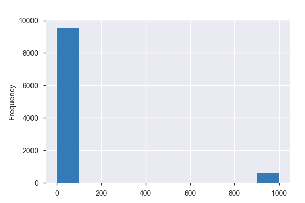

**Common Values**

| Value | Count | Frequency (%) |  |
| --- | --- | --- | --- |
| 4.0 | 2547 | 3.3% |  |
| 3.0 | 2092 | 2.7% |  |
| 2.0 | 1420 | 1.8% |  |
| 5.0 | 1332 | 1.7% |  |
| 999.0 | 629 | 0.8% |  |
| 6.0 | 625 | 0.8% |  |
| 1.0 | 540 | 0.7% |  |
| 99.0 | 299 | 0.4% |  |
| 8.0 | 190 | 0.2% |  |
| 0.0 | 153 | 0.2% |  |
| Other values (12) | 344 | 0.4% |  |
| (Missing) | 66933 | 86.8% |  |

**Extreme Values**

Minimum 5 values

| Value | Count | Frequency (%) |  |
| --- | --- | --- | --- |
| 0.0 | 153 | 0.2% |  |
| 1.0 | 540 | 0.7% |  |
| 2.0 | 1420 | 1.8% |  |
| 3.0 | 2092 | 2.7% |  |
| 4.0 | 2547 | 3.3% |  |

Maximum 5 values

| Value | Count | Frequency (%) |  |
| --- | --- | --- | --- |
| 20.0 | 17 | 0.0% |  |
| 21.0 | 2 | 0.0% |  |
| 24.0 | 5 | 0.0% |  |
| 99.0 | 299 | 0.4% |  |
| 999.0 | 629 | 0.8% |  |

v71  
Categorical

| Distinct count | 7 |
| --- | --- |
| Unique (%) | 0.0% |
| Missing (%) | 0.1% |
| Missing (n) | 88 |

| dagelijks | 43051 |
| --- | --- |
| nooit | 12840 |
| wekelijks | 11378 |
| Other values (3) | 9747 |

Toggle details

| Value | Count | Frequency (%) |  |
| --- | --- | --- | --- |
| dagelijks | 43051 | 55.8% |  |
| nooit | 12840 | 16.7% |  |
| wekelijks | 11378 | 14.8% |  |
| minder dan wekelijks | 6134 | 8.0% |  |
| 99 | 3561 | 4.6% |  |
| 999 | 52 | 0.1% |  |
| (Missing) | 88 | 0.1% |  |

v72  
Categorical

| Distinct count | 7 |
| --- | --- |
| Unique (%) | 0.0% |
| Missing (%) | 0.1% |
| Missing (n) | 95 |

| ja | 58970 |
| --- | --- |
| neen | 9331 |
| 99 | 5135 |
| Other values (3) | 3573 |

Toggle details

| Value | Count | Frequency (%) |  |
| --- | --- | --- | --- |
| ja | 58970 | 76.5% |  |
| neen | 9331 | 12.1% |  |
| 99 | 5135 | 6.7% |  |
| ken ik niet | 3376 | 4.4% |  |
| 4 | 142 | 0.2% |  |
| 5 | 55 | 0.1% |  |
| (Missing) | 95 | 0.1% |  |

v73  
Categorical

| Distinct count | 7 |
| --- | --- |
| Unique (%) | 0.0% |
| Missing (%) | 0.1% |
| Missing (n) | 94 |

| nooit | 52264 |
| --- | --- |
| dagelijks | 9158 |
| 99 | 6023 |
| Other values (3) | 9565 |

Toggle details

| Value | Count | Frequency (%) |  |
| --- | --- | --- | --- |
| nooit | 52264 | 67.8% |  |
| dagelijks | 9158 | 11.9% |  |
| 99 | 6023 | 7.8% |  |
| meerdere keren per dag | 3719 | 4.8% |  |
| wekelijks | 3680 | 4.8% |  |
| minder dan wekelijks | 2166 | 2.8% |  |
| (Missing) | 94 | 0.1% |  |

v74_1  
Categorical

| Distinct count | 5 |
| --- | --- |
| Unique (%) | 0.0% |
| Missing (%) | 0.0% |
| Missing (n) | 9 |

| 99 | 34785 |
| --- | --- |
| 888 | 20862 |
| ja | 17028 |

Toggle details

| Value | Count | Frequency (%) |  |
| --- | --- | --- | --- |
| 99 | 34785 | 45.1% |  |
| 888 | 20862 | 27.1% |  |
| ja | 17028 | 22.1% |  |
| neen | 4420 | 5.7% |  |
| (Missing) | 9 | 0.0% |  |

v74_2  
Categorical

| Distinct count | 5 |
| --- | --- |
| Unique (%) | 0.0% |
| Missing (%) | 0.0% |
| Missing (n) | 9 |

| 99 | 34832 |
| --- | --- |
| 888 | 21014 |
| ja | 14515 |

Toggle details

| Value | Count | Frequency (%) |  |
| --- | --- | --- | --- |
| 99 | 34832 | 45.2% |  |
| 888 | 21014 | 27.3% |  |
| ja | 14515 | 18.8% |  |
| neen | 6734 | 8.7% |  |
| (Missing) | 9 | 0.0% |  |

v74_3  
Categorical

| Distinct count | 5 |
| --- | --- |
| Unique (%) | 0.0% |
| Missing (%) | 0.0% |
| Missing (n) | 9 |

| 99 | 34980 |
| --- | --- |
| 888 | 21064 |
| neen | 17011 |

Toggle details

| Value | Count | Frequency (%) |  |
| --- | --- | --- | --- |
| 99 | 34980 | 45.4% |  |
| 888 | 21064 | 27.3% |  |
| neen | 17011 | 22.1% |  |
| ja | 4040 | 5.2% |  |
| (Missing) | 9 | 0.0% |  |

v74_4  
Categorical

| Distinct count | 5 |
| --- | --- |
| Unique (%) | 0.0% |
| Missing (%) | 0.0% |
| Missing (n) | 9 |

| 99 | 34927 |
| --- | --- |
| 888 | 20989 |
| neen | 12520 |

Toggle details

| Value | Count | Frequency (%) |  |
| --- | --- | --- | --- |
| 99 | 34927 | 45.3% |  |
| 888 | 20989 | 27.2% |  |
| neen | 12520 | 16.2% |  |
| ja | 8659 | 11.2% |  |
| (Missing) | 9 | 0.0% |  |

v74_5  
Categorical

| Distinct count | 5 |
| --- | --- |
| Unique (%) | 0.0% |
| Missing (%) | 94.9% |
| Missing (n) | 73208 |

| 888 | 1517 |
| --- | --- |
| neen | 1191 |
| ja | 658 |
| (Missing) | 73208 |

Toggle details

| Value | Count | Frequency (%) |  |
| --- | --- | --- | --- |
| 888 | 1517 | 2.0% |  |
| neen | 1191 | 1.5% |  |
| ja | 658 | 0.9% |  |
| 99 | 530 | 0.7% |  |
| (Missing) | 73208 | 94.9% |  |

v74_6  
Categorical

| Distinct count | 5 |
| --- | --- |
| Unique (%) | 0.0% |
| Missing (%) | 94.9% |
| Missing (n) | 73208 |

| 888 | 1517 |
| --- | --- |
| neen | 1194 |
| ja | 655 |
| (Missing) | 73208 |

Toggle details

| Value | Count | Frequency (%) |  |
| --- | --- | --- | --- |
| 888 | 1517 | 2.0% |  |
| neen | 1194 | 1.5% |  |
| ja | 655 | 0.8% |  |
| 99 | 530 | 0.7% |  |
| (Missing) | 73208 | 94.9% |  |

v74_7  
Categorical

| Distinct count | 5 |
| --- | --- |
| Unique (%) | 0.0% |
| Missing (%) | 94.9% |
| Missing (n) | 73208 |

| 888 | 1517 |
| --- | --- |
| neen | 1196 |
| ja | 653 |
| (Missing) | 73208 |

Toggle details

| Value | Count | Frequency (%) |  |
| --- | --- | --- | --- |
| 888 | 1517 | 2.0% |  |
| neen | 1196 | 1.6% |  |
| ja | 653 | 0.8% |  |
| 99 | 530 | 0.7% |  |
| (Missing) | 73208 | 94.9% |  |

v75_1  
Categorical

| Distinct count | 6 |
| --- | --- |
| Unique (%) | 0.0% |
| Missing (%) | 0.6% |
| Missing (n) | 475 |

| tevreden | 47473 |
| --- | --- |
| 99 | 13703 |
| 100 | 10645 |
| Other values (2) | 4808 |

Toggle details

| Value | Count | Frequency (%) |  |
| --- | --- | --- | --- |
| tevreden | 47473 | 61.6% |  |
| 99 | 13703 | 17.8% |  |
| 100 | 10645 | 13.8% |  |
| niet tevreden | 3916 | 5.1% |  |
| geen beroep op gedaan | 892 | 1.2% |  |
| (Missing) | 475 | 0.6% |  |

v75_10  
Categorical

| Distinct count | 6 |
| --- | --- |
| Unique (%) | 0.0% |
| Missing (%) | 0.9% |
| Missing (n) | 725 |

| tevreden | 26847 |
| --- | --- |
| 100 | 17650 |
| 99 | 17600 |
| Other values (2) | 14282 |

Toggle details

| Value | Count | Frequency (%) |  |
| --- | --- | --- | --- |
| tevreden | 26847 | 34.8% |  |
| 100 | 17650 | 22.9% |  |
| 99 | 17600 | 22.8% |  |
| niet tevreden | 12946 | 16.8% |  |
| geen beroep op gedaan | 1336 | 1.7% |  |
| (Missing) | 725 | 0.9% |  |

v75_11  
Categorical

| Distinct count | 6 |
| --- | --- |
| Unique (%) | 0.0% |
| Missing (%) | 2.8% |
| Missing (n) | 2158 |

| 99 | 36574 |
| --- | --- |
| tevreden | 19603 |
| 100 | 10498 |
| Other values (2) | 8271 |

Toggle details

| Value | Count | Frequency (%) |  |
| --- | --- | --- | --- |
| 99 | 36574 | 47.4% |  |
| tevreden | 19603 | 25.4% |  |
| 100 | 10498 | 13.6% |  |
| geen beroep op gedaan | 6948 | 9.0% |  |
| niet tevreden | 1323 | 1.7% |  |
| (Missing) | 2158 | 2.8% |  |

v75_12  
Categorical

| Distinct count | 6 |
| --- | --- |
| Unique (%) | 0.0% |
| Missing (%) | 2.1% |
| Missing (n) | 1597 |

| 99 | 30376 |
| --- | --- |
| tevreden | 25636 |
| 100 | 12462 |
| Other values (2) | 7033 |

Toggle details

| Value | Count | Frequency (%) |  |
| --- | --- | --- | --- |
| 99 | 30376 | 39.4% |  |
| tevreden | 25636 | 33.2% |  |
| 100 | 12462 | 16.2% |  |
| geen beroep op gedaan | 4869 | 6.3% |  |
| niet tevreden | 2164 | 2.8% |  |
| (Missing) | 1597 | 2.1% |  |

v75_13  
Categorical

| Distinct count | 6 |
| --- | --- |
| Unique (%) | 0.0% |
| Missing (%) | 2.1% |
| Missing (n) | 1604 |

| 99 | 31131 |
| --- | --- |
| tevreden | 30132 |
| 100 | 7598 |
| Other values (2) | 6639 |

Toggle details

| Value | Count | Frequency (%) |  |
| --- | --- | --- | --- |
| 99 | 31131 | 40.4% |  |
| tevreden | 30132 | 39.1% |  |
| 100 | 7598 | 9.9% |  |
| geen beroep op gedaan | 5386 | 7.0% |  |
| niet tevreden | 1253 | 1.6% |  |
| (Missing) | 1604 | 2.1% |  |

v75_14  
Categorical

| Distinct count | 6 |
| --- | --- |
| Unique (%) | 0.0% |
| Missing (%) | 2.2% |
| Missing (n) | 1700 |

| 99 | 32270 |
| --- | --- |
| tevreden | 28772 |
| 100 | 7464 |
| Other values (2) | 6898 |

Toggle details

| Value | Count | Frequency (%) |  |
| --- | --- | --- | --- |
| 99 | 32270 | 41.9% |  |
| tevreden | 28772 | 37.3% |  |
| 100 | 7464 | 9.7% |  |
| geen beroep op gedaan | 5763 | 7.5% |  |
| niet tevreden | 1135 | 1.5% |  |
| (Missing) | 1700 | 2.2% |  |

v75_15  
Categorical

| Distinct count | 6 |
| --- | --- |
| Unique (%) | 0.0% |
| Missing (%) | 2.2% |
| Missing (n) | 1728 |

| 99 | 32672 |
| --- | --- |
| tevreden | 28556 |
| 100 | 7531 |
| Other values (2) | 6617 |

Toggle details

| Value | Count | Frequency (%) |  |
| --- | --- | --- | --- |
| 99 | 32672 | 42.4% |  |
| tevreden | 28556 | 37.0% |  |
| 100 | 7531 | 9.8% |  |
| geen beroep op gedaan | 5640 | 7.3% |  |
| niet tevreden | 977 | 1.3% |  |
| (Missing) | 1728 | 2.2% |  |

v75_16  
Categorical

| Distinct count | 6 |
| --- | --- |
| Unique (%) | 0.0% |
| Missing (%) | 1.3% |
| Missing (n) | 1001 |

| tevreden | 31467 |
| --- | --- |
| 99 | 22833 |
| 100 | 13295 |
| Other values (2) | 8508 |

Toggle details

| Value | Count | Frequency (%) |  |
| --- | --- | --- | --- |
| tevreden | 31467 | 40.8% |  |
| 99 | 22833 | 29.6% |  |
| 100 | 13295 | 17.2% |  |
| niet tevreden | 6183 | 8.0% |  |
| geen beroep op gedaan | 2325 | 3.0% |  |
| (Missing) | 1001 | 1.3% |  |

v75_17  
Categorical

| Distinct count | 6 |
| --- | --- |
| Unique (%) | 0.0% |
| Missing (%) | 0.7% |
| Missing (n) | 550 |

| niet tevreden | 23651 |
| --- | --- |
| tevreden | 22728 |
| 99 | 15316 |
| Other values (2) | 14859 |

Toggle details

| Value | Count | Frequency (%) |  |
| --- | --- | --- | --- |
| niet tevreden | 23651 | 30.7% |  |
| tevreden | 22728 | 29.5% |  |
| 99 | 15316 | 19.9% |  |
| 100 | 14153 | 18.4% |  |
| geen beroep op gedaan | 706 | 0.9% |  |
| (Missing) | 550 | 0.7% |  |

v75_18  
Categorical

| Distinct count | 6 |
| --- | --- |
| Unique (%) | 0.0% |
| Missing (%) | 0.8% |
| Missing (n) | 648 |

| tevreden | 27527 |
| --- | --- |
| 99 | 18135 |
| 100 | 17309 |
| Other values (2) | 13485 |

Toggle details

| Value | Count | Frequency (%) |  |
| --- | --- | --- | --- |
| tevreden | 27527 | 35.7% |  |
| 99 | 18135 | 23.5% |  |
| 100 | 17309 | 22.4% |  |
| niet tevreden | 12592 | 16.3% |  |
| geen beroep op gedaan | 893 | 1.2% |  |
| (Missing) | 648 | 0.8% |  |

v75_19  
Categorical

| Distinct count | 6 |
| --- | --- |
| Unique (%) | 0.0% |
| Missing (%) | 1.2% |
| Missing (n) | 913 |

| tevreden | 32281 |
| --- | --- |
| 99 | 20997 |
| 100 | 11884 |
| Other values (2) | 11029 |

Toggle details

| Value | Count | Frequency (%) |  |
| --- | --- | --- | --- |
| tevreden | 32281 | 41.9% |  |
| 99 | 20997 | 27.2% |  |
| 100 | 11884 | 15.4% |  |
| niet tevreden | 8746 | 11.3% |  |
| geen beroep op gedaan | 2283 | 3.0% |  |
| (Missing) | 913 | 1.2% |  |

v75_2  
Categorical

| Distinct count | 6 |
| --- | --- |
| Unique (%) | 0.0% |
| Missing (%) | 0.6% |
| Missing (n) | 470 |

| tevreden | 47499 |
| --- | --- |
| 99 | 15159 |
| 100 | 9741 |
| Other values (2) | 4235 |

Toggle details

| Value | Count | Frequency (%) |  |
| --- | --- | --- | --- |
| tevreden | 47499 | 61.6% |  |
| 99 | 15159 | 19.7% |  |
| 100 | 9741 | 12.6% |  |
| niet tevreden | 3384 | 4.4% |  |
| geen beroep op gedaan | 851 | 1.1% |  |
| (Missing) | 470 | 0.6% |  |

v75_20  
Categorical

| Distinct count | 6 |
| --- | --- |
| Unique (%) | 0.0% |
| Missing (%) | 2.4% |
| Missing (n) | 1825 |

| 99 | 32033 |
| --- | --- |
| tevreden | 21323 |
| 100 | 12336 |
| Other values (2) | 9587 |

Toggle details

| Value | Count | Frequency (%) |  |
| --- | --- | --- | --- |
| 99 | 32033 | 41.5% |  |
| tevreden | 21323 | 27.7% |  |
| 100 | 12336 | 16.0% |  |
| geen beroep op gedaan | 5887 | 7.6% |  |
| niet tevreden | 3700 | 4.8% |  |
| (Missing) | 1825 | 2.4% |  |

v75_21  
Categorical

| Distinct count | 6 |
| --- | --- |
| Unique (%) | 0.0% |
| Missing (%) | 0.6% |
| Missing (n) | 492 |

| tevreden | 52161 |
| --- | --- |
| 99 | 13421 |
| 100 | 7434 |
| Other values (2) | 3596 |

Toggle details

| Value | Count | Frequency (%) |  |
| --- | --- | --- | --- |
| tevreden | 52161 | 67.7% |  |
| 99 | 13421 | 17.4% |  |
| 100 | 7434 | 9.6% |  |
| niet tevreden | 3108 | 4.0% |  |
| geen beroep op gedaan | 488 | 0.6% |  |
| (Missing) | 492 | 0.6% |  |

v75_22  
Categorical

| Distinct count | 6 |
| --- | --- |
| Unique (%) | 0.0% |
| Missing (%) | 0.7% |
| Missing (n) | 561 |

| tevreden | 48772 |
| --- | --- |
| 99 | 15940 |
| 100 | 7751 |
| Other values (2) | 4080 |

Toggle details

| Value | Count | Frequency (%) |  |
| --- | --- | --- | --- |
| tevreden | 48772 | 63.3% |  |
| 99 | 15940 | 20.7% |  |
| 100 | 7751 | 10.1% |  |
| niet tevreden | 3607 | 4.7% |  |
| geen beroep op gedaan | 473 | 0.6% |  |
| (Missing) | 561 | 0.7% |  |

v75_23  
Categorical

| Distinct count | 6 |
| --- | --- |
| Unique (%) | 0.0% |
| Missing (%) | 0.7% |
| Missing (n) | 558 |

| tevreden | 40696 |
| --- | --- |
| 99 | 15802 |
| 100 | 9976 |
| Other values (2) | 10072 |

Toggle details

| Value | Count | Frequency (%) |  |
| --- | --- | --- | --- |
| tevreden | 40696 | 52.8% |  |
| 99 | 15802 | 20.5% |  |
| 100 | 9976 | 12.9% |  |
| niet tevreden | 9124 | 11.8% |  |
| geen beroep op gedaan | 948 | 1.2% |  |
| (Missing) | 558 | 0.7% |  |

v75_24  
Categorical

| Distinct count | 6 |
| --- | --- |
| Unique (%) | 0.0% |
| Missing (%) | 1.2% |
| Missing (n) | 893 |

| tevreden | 43757 |
| --- | --- |
| 99 | 18418 |
| 100 | 9032 |
| Other values (2) | 5004 |

Toggle details

| Value | Count | Frequency (%) |  |
| --- | --- | --- | --- |
| tevreden | 43757 | 56.8% |  |
| 99 | 18418 | 23.9% |  |
| 100 | 9032 | 11.7% |  |
| niet tevreden | 3244 | 4.2% |  |
| geen beroep op gedaan | 1760 | 2.3% |  |
| (Missing) | 893 | 1.2% |  |

v75_25  
Categorical

| Distinct count | 6 |
| --- | --- |
| Unique (%) | 0.0% |
| Missing (%) | 1.2% |
| Missing (n) | 917 |

| tevreden | 43471 |
| --- | --- |
| 99 | 18828 |
| 100 | 8718 |
| Other values (2) | 5170 |

Toggle details

| Value | Count | Frequency (%) |  |
| --- | --- | --- | --- |
| tevreden | 43471 | 56.4% |  |
| 99 | 18828 | 24.4% |  |
| 100 | 8718 | 11.3% |  |
| niet tevreden | 3356 | 4.4% |  |
| geen beroep op gedaan | 1814 | 2.4% |  |
| (Missing) | 917 | 1.2% |  |

v75_26  
Categorical

| Distinct count | 6 |
| --- | --- |
| Unique (%) | 0.0% |
| Missing (%) | 1.3% |
| Missing (n) | 1035 |

| tevreden | 41215 |
| --- | --- |
| 99 | 19860 |
| 100 | 9244 |
| Other values (2) | 5750 |

Toggle details

| Value | Count | Frequency (%) |  |
| --- | --- | --- | --- |
| tevreden | 41215 | 53.5% |  |
| 99 | 19860 | 25.8% |  |
| 100 | 9244 | 12.0% |  |
| niet tevreden | 3710 | 4.8% |  |
| geen beroep op gedaan | 2040 | 2.6% |  |
| (Missing) | 1035 | 1.3% |  |

v75_27  
Categorical

| Distinct count | 6 |
| --- | --- |
| Unique (%) | 0.0% |
| Missing (%) | 3.1% |
| Missing (n) | 2385 |

| 99 | 36482 |
| --- | --- |
| tevreden | 16802 |
| 100 | 10562 |
| Other values (2) | 10873 |

Toggle details

| Value | Count | Frequency (%) |  |
| --- | --- | --- | --- |
| 99 | 36482 | 47.3% |  |
| tevreden | 16802 | 21.8% |  |
| 100 | 10562 | 13.7% |  |
| geen beroep op gedaan | 7591 | 9.8% |  |
| niet tevreden | 3282 | 4.3% |  |
| (Missing) | 2385 | 3.1% |  |

v75_28  
Categorical

| Distinct count | 6 |
| --- | --- |
| Unique (%) | 0.0% |
| Missing (%) | 3.5% |
| Missing (n) | 2706 |

| 99 | 39724 |
| --- | --- |
| tevreden | 11324 |
| 100 | 10818 |
| Other values (2) | 12532 |

Toggle details

| Value | Count | Frequency (%) |  |
| --- | --- | --- | --- |
| 99 | 39724 | 51.5% |  |
| tevreden | 11324 | 14.7% |  |
| 100 | 10818 | 14.0% |  |
| geen beroep op gedaan | 8540 | 11.1% |  |
| niet tevreden | 3992 | 5.2% |  |
| (Missing) | 2706 | 3.5% |  |

v75_29  
Categorical

| Distinct count | 6 |
| --- | --- |
| Unique (%) | 0.0% |
| Missing (%) | 3.4% |
| Missing (n) | 2591 |

| geen beroep op gedaan | 30188 |
| --- | --- |
| 99 | 27189 |
| 100 | 8069 |
| Other values (2) | 9067 |

Toggle details

| Value | Count | Frequency (%) |  |
| --- | --- | --- | --- |
| geen beroep op gedaan | 30188 | 39.2% |  |
| 99 | 27189 | 35.3% |  |
| 100 | 8069 | 10.5% |  |
| tevreden | 6337 | 8.2% |  |
| niet tevreden | 2730 | 3.5% |  |
| (Missing) | 2591 | 3.4% |  |

v75_3  
Categorical

| Distinct count | 6 |
| --- | --- |
| Unique (%) | 0.0% |
| Missing (%) | 0.7% |
| Missing (n) | 539 |

| tevreden | 44517 |
| --- | --- |
| 99 | 17075 |
| 100 | 10656 |
| Other values (2) | 4317 |

Toggle details

| Value | Count | Frequency (%) |  |
| --- | --- | --- | --- |
| tevreden | 44517 | 57.7% |  |
| 99 | 17075 | 22.1% |  |
| 100 | 10656 | 13.8% |  |
| niet tevreden | 2973 | 3.9% |  |
| geen beroep op gedaan | 1344 | 1.7% |  |
| (Missing) | 539 | 0.7% |  |

v75_30  
Categorical

| Distinct count | 6 |
| --- | --- |
| Unique (%) | 0.0% |
| Missing (%) | 4.0% |
| Missing (n) | 3107 |

| geen beroep op gedaan | 32288 |
| --- | --- |
| 99 | 26713 |
| 100 | 7355 |
| Other values (2) | 7641 |

Toggle details

| Value | Count | Frequency (%) |  |
| --- | --- | --- | --- |
| geen beroep op gedaan | 32288 | 41.9% |  |
| 99 | 26713 | 34.6% |  |
| 100 | 7355 | 9.5% |  |
| tevreden | 6299 | 8.2% |  |
| niet tevreden | 1342 | 1.7% |  |
| (Missing) | 3107 | 4.0% |  |

v75_31  
Categorical

| Distinct count | 6 |
| --- | --- |
| Unique (%) | 0.0% |
| Missing (%) | 90.5% |
| Missing (n) | 69756 |

| geen beroep op gedaan | 3578 |
| --- | --- |
| tevreden | 1845 |
| 99 | 874 |
| Other values (2) | 1051 |
| (Missing) | 69756 |

Toggle details

| Value | Count | Frequency (%) |  |
| --- | --- | --- | --- |
| geen beroep op gedaan | 3578 | 4.6% |  |
| tevreden | 1845 | 2.4% |  |
| 99 | 874 | 1.1% |  |
| 100 | 851 | 1.1% |  |
| niet tevreden | 200 | 0.3% |  |
| (Missing) | 69756 | 90.5% |  |

v75_32  
Categorical

| Distinct count | 6 |
| --- | --- |
| Unique (%) | 0.0% |
| Missing (%) | 4.2% |
| Missing (n) | 3218 |

| geen beroep op gedaan | 32644 |
| --- | --- |
| 99 | 27023 |
| 100 | 7377 |
| Other values (2) | 6842 |

Toggle details

| Value | Count | Frequency (%) |  |
| --- | --- | --- | --- |
| geen beroep op gedaan | 32644 | 42.3% |  |
| 99 | 27023 | 35.0% |  |
| 100 | 7377 | 9.6% |  |
| tevreden | 5485 | 7.1% |  |
| niet tevreden | 1357 | 1.8% |  |
| (Missing) | 3218 | 4.2% |  |

v75_33  
Categorical

| Distinct count | 6 |
| --- | --- |
| Unique (%) | 0.0% |
| Missing (%) | 91.1% |
| Missing (n) | 70241 |

| geen beroep op gedaan | 4122 |
| --- | --- |
| 99 | 957 |
| 100 | 903 |
| Other values (2) | 881 |
| (Missing) | 70241 |

Toggle details

| Value | Count | Frequency (%) |  |
| --- | --- | --- | --- |
| geen beroep op gedaan | 4122 | 5.3% |  |
| 99 | 957 | 1.2% |  |
| 100 | 903 | 1.2% |  |
| tevreden | 775 | 1.0% |  |
| niet tevreden | 106 | 0.1% |  |
| (Missing) | 70241 | 91.1% |  |

v75_34  
Categorical

| Distinct count | 6 |
| --- | --- |
| Unique (%) | 0.0% |
| Missing (%) | 8.2% |
| Missing (n) | 6284 |

| geen beroep op gedaan | 32564 |
| --- | --- |
| 99 | 27419 |
| 100 | 6471 |
| Other values (2) | 4366 |
| (Missing) | 6284 |

Toggle details

| Value | Count | Frequency (%) |  |
| --- | --- | --- | --- |
| geen beroep op gedaan | 32564 | 42.2% |  |
| 99 | 27419 | 35.6% |  |
| 100 | 6471 | 8.4% |  |
| tevreden | 3417 | 4.4% |  |
| niet tevreden | 949 | 1.2% |  |
| (Missing) | 6284 | 8.2% |  |

v75_35  
Categorical

| Distinct count | 6 |
| --- | --- |
| Unique (%) | 0.0% |
| Missing (%) | 8.2% |
| Missing (n) | 6284 |

| geen beroep op gedaan | 32426 |
| --- | --- |
| 99 | 27376 |
| 100 | 6497 |
| Other values (2) | 4521 |
| (Missing) | 6284 |

Toggle details

| Value | Count | Frequency (%) |  |
| --- | --- | --- | --- |
| geen beroep op gedaan | 32426 | 42.1% |  |
| 99 | 27376 | 35.5% |  |
| 100 | 6497 | 8.4% |  |
| tevreden | 3553 | 4.6% |  |
| niet tevreden | 968 | 1.3% |  |
| (Missing) | 6284 | 8.2% |  |

v75_36  
Categorical

| Distinct count | 6 |
| --- | --- |
| Unique (%) | 0.0% |
| Missing (%) | 90.9% |
| Missing (n) | 70069 |

| geen beroep op gedaan | 3890 |
| --- | --- |
| tevreden | 1241 |
| 99 | 939 |
| Other values (2) | 965 |
| (Missing) | 70069 |

Toggle details

| Value | Count | Frequency (%) |  |
| --- | --- | --- | --- |
| geen beroep op gedaan | 3890 | 5.0% |  |
| tevreden | 1241 | 1.6% |  |
| 99 | 939 | 1.2% |  |
| 100 | 850 | 1.1% |  |
| niet tevreden | 115 | 0.1% |  |
| (Missing) | 70069 | 90.9% |  |

v75_37  
Categorical

| Distinct count | 6 |
| --- | --- |
| Unique (%) | 0.0% |
| Missing (%) | 4.1% |
| Missing (n) | 3139 |

| geen beroep op gedaan | 28604 |
| --- | --- |
| 99 | 25791 |
| tevreden | 11742 |
| Other values (2) | 7828 |

Toggle details

| Value | Count | Frequency (%) |  |
| --- | --- | --- | --- |
| geen beroep op gedaan | 28604 | 37.1% |  |
| 99 | 25791 | 33.4% |  |
| tevreden | 11742 | 15.2% |  |
| 100 | 6697 | 8.7% |  |
| niet tevreden | 1131 | 1.5% |  |
| (Missing) | 3139 | 4.1% |  |

v75_38  
Categorical

| Distinct count | 6 |
| --- | --- |
| Unique (%) | 0.0% |
| Missing (%) | 3.5% |
| Missing (n) | 2662 |

| geen beroep op gedaan | 32493 |
| --- | --- |
| 99 | 27293 |
| 100 | 7387 |
| Other values (2) | 7269 |

Toggle details

| Value | Count | Frequency (%) |  |
| --- | --- | --- | --- |
| geen beroep op gedaan | 32493 | 42.1% |  |
| 99 | 27293 | 35.4% |  |
| 100 | 7387 | 9.6% |  |
| tevreden | 5992 | 7.8% |  |
| niet tevreden | 1277 | 1.7% |  |
| (Missing) | 2662 | 3.5% |  |

v75_39  
Unsupported

*This variable is an unsupported type, check if it needs cleaning or further analysis*

| Unsupported value |
| --- |

v75_4  
Categorical

| Distinct count | 7 |
| --- | --- |
| Unique (%) | 0.0% |
| Missing (%) | 0.8% |
| Missing (n) | 583 |

| tevreden | 43803 |
| --- | --- |
| 99 | 17934 |
| 100 | 10243 |
| Other values (3) | 4541 |

Toggle details

| Value | Count | Frequency (%) |  |
| --- | --- | --- | --- |
| tevreden | 43803 | 56.8% |  |
| 99 | 17934 | 23.3% |  |
| 100 | 10243 | 13.3% |  |
| niet tevreden | 2956 | 3.8% |  |
| geen beroep op gedaan | 1407 | 1.8% |  |
| 888 | 178 | 0.2% |  |
| (Missing) | 583 | 0.8% |  |

v75_5  
Categorical

| Distinct count | 7 |
| --- | --- |
| Unique (%) | 0.0% |
| Missing (%) | 2.1% |
| Missing (n) | 1637 |

| 99 | 32951 |
| --- | --- |
| tevreden | 26049 |
| 100 | 8477 |
| Other values (3) | 7990 |

Toggle details

| Value | Count | Frequency (%) |  |
| --- | --- | --- | --- |
| 99 | 32951 | 42.7% |  |
| tevreden | 26049 | 33.8% |  |
| 100 | 8477 | 11.0% |  |
| geen beroep op gedaan | 6235 | 8.1% |  |
| niet tevreden | 1577 | 2.0% |  |
| 888 | 178 | 0.2% |  |
| (Missing) | 1637 | 2.1% |  |

v75_6  
Categorical

| Distinct count | 7 |
| --- | --- |
| Unique (%) | 0.0% |
| Missing (%) | 2.2% |
| Missing (n) | 1672 |

| 99 | 33741 |
| --- | --- |
| tevreden | 25531 |
| 100 | 8162 |
| Other values (3) | 7998 |

Toggle details

| Value | Count | Frequency (%) |  |
| --- | --- | --- | --- |
| 99 | 33741 | 43.8% |  |
| tevreden | 25531 | 33.1% |  |
| 100 | 8162 | 10.6% |  |
| geen beroep op gedaan | 6389 | 8.3% |  |
| niet tevreden | 1431 | 1.9% |  |
| 888 | 178 | 0.2% |  |
| (Missing) | 1672 | 2.2% |  |

v75_7  
Categorical

| Distinct count | 7 |
| --- | --- |
| Unique (%) | 0.0% |
| Missing (%) | 2.2% |
| Missing (n) | 1706 |

| 99 | 34428 |
| --- | --- |
| tevreden | 24792 |
| 100 | 7902 |
| Other values (3) | 8276 |

Toggle details

| Value | Count | Frequency (%) |  |
| --- | --- | --- | --- |
| 99 | 34428 | 44.7% |  |
| tevreden | 24792 | 32.2% |  |
| 100 | 7902 | 10.2% |  |
| geen beroep op gedaan | 6612 | 8.6% |  |
| niet tevreden | 1486 | 1.9% |  |
| 888 | 178 | 0.2% |  |
| (Missing) | 1706 | 2.2% |  |

v75_8  
Categorical

| Distinct count | 6 |
| --- | --- |
| Unique (%) | 0.0% |
| Missing (%) | 2.3% |
| Missing (n) | 1741 |

| 99 | 34676 |
| --- | --- |
| tevreden | 24559 |
| 100 | 7854 |
| Other values (2) | 8274 |

Toggle details

| Value | Count | Frequency (%) |  |
| --- | --- | --- | --- |
| 99 | 34676 | 45.0% |  |
| tevreden | 24559 | 31.9% |  |
| 100 | 7854 | 10.2% |  |
| geen beroep op gedaan | 6623 | 8.6% |  |
| niet tevreden | 1651 | 2.1% |  |
| (Missing) | 1741 | 2.3% |  |

v75_9  
Categorical

| Distinct count | 6 |
| --- | --- |
| Unique (%) | 0.0% |
| Missing (%) | 1.6% |
| Missing (n) | 1228 |

| tevreden | 32319 |
| --- | --- |
| 99 | 24225 |
| 100 | 11232 |
| Other values (2) | 8100 |

Toggle details

| Value | Count | Frequency (%) |  |
| --- | --- | --- | --- |
| tevreden | 32319 | 41.9% |  |
| 99 | 24225 | 31.4% |  |
| 100 | 11232 | 14.6% |  |
| niet tevreden | 4351 | 5.6% |  |
| geen beroep op gedaan | 3749 | 4.9% |  |
| (Missing) | 1228 | 1.6% |  |

v76_1  
Categorical

| Distinct count | 4 |
| --- | --- |
| Unique (%) | 0.0% |
| Missing (%) | 86.8% |
| Missing (n) | 66933 |

| ja | 5574 |
| --- | --- |
| neen | 3809 |
| 99 | 788 |
| (Missing) | 66933 |

Toggle details

| Value | Count | Frequency (%) |  |
| --- | --- | --- | --- |
| ja | 5574 | 7.2% |  |
| neen | 3809 | 4.9% |  |
| 99 | 788 | 1.0% |  |
| (Missing) | 66933 | 86.8% |  |

v76_2  
Categorical

| Distinct count | 4 |
| --- | --- |
| Unique (%) | 0.0% |
| Missing (%) | 86.8% |
| Missing (n) | 66933 |

| neen | 7406 |
| --- | --- |
| ja | 1923 |
| 99 | 842 |
| (Missing) | 66933 |

Toggle details

| Value | Count | Frequency (%) |  |
| --- | --- | --- | --- |
| neen | 7406 | 9.6% |  |
| ja | 1923 | 2.5% |  |
| 99 | 842 | 1.1% |  |
| (Missing) | 66933 | 86.8% |  |

v76_3  
Categorical

| Distinct count | 4 |
| --- | --- |
| Unique (%) | 0.0% |
| Missing (%) | 86.8% |
| Missing (n) | 66933 |

| neen | 7328 |
| --- | --- |
| ja | 2003 |
| 99 | 840 |
| (Missing) | 66933 |

Toggle details

| Value | Count | Frequency (%) |  |
| --- | --- | --- | --- |
| neen | 7328 | 9.5% |  |
| ja | 2003 | 2.6% |  |
| 99 | 840 | 1.1% |  |
| (Missing) | 66933 | 86.8% |  |

v76_4  
Categorical

| Distinct count | 4 |
| --- | --- |
| Unique (%) | 0.0% |
| Missing (%) | 86.8% |
| Missing (n) | 66933 |

| neen | 6269 |
| --- | --- |
| ja | 3074 |
| 99 | 828 |
| (Missing) | 66933 |

Toggle details

| Value | Count | Frequency (%) |  |
| --- | --- | --- | --- |
| neen | 6269 | 8.1% |  |
| ja | 3074 | 4.0% |  |
| 99 | 828 | 1.1% |  |
| (Missing) | 66933 | 86.8% |  |

v76_5  
Categorical

| Distinct count | 5 |
| --- | --- |
| Unique (%) | 0.0% |
| Missing (%) | 86.8% |
| Missing (n) | 66933 |

| ja | 5926 |
| --- | --- |
| neen | 3367 |
| 99 | 771 |
| (Missing) | 66933 |

Toggle details

| Value | Count | Frequency (%) |  |
| --- | --- | --- | --- |
| ja | 5926 | 7.7% |  |
| neen | 3367 | 4.4% |  |
| 99 | 771 | 1.0% |  |
| 888 | 107 | 0.1% |  |
| (Missing) | 66933 | 86.8% |  |

v76_6  
Categorical

| Distinct count | 4 |
| --- | --- |
| Unique (%) | 0.0% |
| Missing (%) | 94.9% |
| Missing (n) | 73208 |

| ja | 2702 |
| --- | --- |
| neen | 894 |
| 99 | 300 |
| (Missing) | 73208 |

Toggle details

| Value | Count | Frequency (%) |  |
| --- | --- | --- | --- |
| ja | 2702 | 3.5% |  |
| neen | 894 | 1.2% |  |
| 99 | 300 | 0.4% |  |
| (Missing) | 73208 | 94.9% |  |

v76_6_oudeVL  
Categorical

| Distinct count | 5 |
| --- | --- |
| Unique (%) | 0.0% |
| Missing (%) | 91.3% |
| Missing (n) | 70402 |

| neen | 3219 |
| --- | --- |
| ja | 2813 |
| 99 | 563 |
| (Missing) | 70402 |

Toggle details

| Value | Count | Frequency (%) |  |
| --- | --- | --- | --- |
| neen | 3219 | 4.2% |  |
| ja | 2813 | 3.6% |  |
| 99 | 563 | 0.7% |  |
| 888 | 107 | 0.1% |  |
| (Missing) | 70402 | 91.3% |  |

v76_7  
Categorical

| Distinct count | 5 |
| --- | --- |
| Unique (%) | 0.0% |
| Missing (%) | 86.8% |
| Missing (n) | 66933 |

| ja | 6821 |
| --- | --- |
| neen | 2472 |
| 99 | 771 |
| (Missing) | 66933 |

Toggle details

| Value | Count | Frequency (%) |  |
| --- | --- | --- | --- |
| ja | 6821 | 8.8% |  |
| neen | 2472 | 3.2% |  |
| 99 | 771 | 1.0% |  |
| 888 | 107 | 0.1% |  |
| (Missing) | 66933 | 86.8% |  |

v76_8  
Categorical

| Distinct count | 5 |
| --- | --- |
| Unique (%) | 0.0% |
| Missing (%) | 86.8% |
| Missing (n) | 66933 |

| ja | 5591 |
| --- | --- |
| neen | 3574 |
| 99 | 899 |
| (Missing) | 66933 |

Toggle details

| Value | Count | Frequency (%) |  |
| --- | --- | --- | --- |
| ja | 5591 | 7.3% |  |
| neen | 3574 | 4.6% |  |
| 99 | 899 | 1.2% |  |
| 888 | 107 | 0.1% |  |
| (Missing) | 66933 | 86.8% |  |

v76_9  
Categorical

| Distinct count | 4 |
| --- | --- |
| Unique (%) | 0.0% |
| Missing (%) | 86.8% |
| Missing (n) | 66933 |

| neen | 5085 |
| --- | --- |
| ja | 3077 |
| 99 | 2009 |
| (Missing) | 66933 |

Toggle details

| Value | Count | Frequency (%) |  |
| --- | --- | --- | --- |
| neen | 5085 | 6.6% |  |
| ja | 3077 | 4.0% |  |
| 99 | 2009 | 2.6% |  |
| (Missing) | 66933 | 86.8% |  |

v77_1  
Categorical

| Distinct count | 8 |
| --- | --- |
| Unique (%) | 0.0% |
| Missing (%) | 0.0% |
| Missing (n) | 3 |

| nooit | 55967 |
| --- | --- |
| 99 | 10150 |
| één keer per jaar | 6350 |
| Other values (4) | 4634 |

Toggle details

| Value | Count | Frequency (%) |  |
| --- | --- | --- | --- |
| nooit | 55967 | 72.6% |  |
| 99 | 10150 | 13.2% |  |
| één keer per jaar | 6350 | 8.2% |  |
| meerdere keren per jaar | 3830 | 5.0% |  |
| één keer per maand | 458 | 0.6% |  |
| meerder keren per maand | 200 | 0.3% |  |
| 0 | 146 | 0.2% |  |
| (Missing) | 3 | 0.0% |  |

v77_10  
Categorical

| Distinct count | 8 |
| --- | --- |
| Unique (%) | 0.0% |
| Missing (%) | 0.0% |
| Missing (n) | 3 |

| nooit | 54463 |
| --- | --- |
| 99 | 10711 |
| één keer per jaar | 7205 |
| Other values (4) | 4722 |

Toggle details

| Value | Count | Frequency (%) |  |
| --- | --- | --- | --- |
| nooit | 54463 | 70.6% |  |
| 99 | 10711 | 13.9% |  |
| één keer per jaar | 7205 | 9.3% |  |
| meerdere keren per jaar | 3236 | 4.2% |  |
| 0 | 950 | 1.2% |  |
| één keer per maand | 310 | 0.4% |  |
| meerder keren per maand | 226 | 0.3% |  |
| (Missing) | 3 | 0.0% |  |

v77_11  
Categorical

| Distinct count | 8 |
| --- | --- |
| Unique (%) | 0.0% |
| Missing (%) | 0.0% |
| Missing (n) | 3 |

| nooit | 50906 |
| --- | --- |
| 99 | 10706 |
| één keer per jaar | 8139 |
| Other values (4) | 7350 |

Toggle details

| Value | Count | Frequency (%) |  |
| --- | --- | --- | --- |
| nooit | 50906 | 66.0% |  |
| 99 | 10706 | 13.9% |  |
| één keer per jaar | 8139 | 10.6% |  |
| meerdere keren per jaar | 5072 | 6.6% |  |
| 0 | 948 | 1.2% |  |
| meerder keren per maand | 686 | 0.9% |  |
| één keer per maand | 644 | 0.8% |  |
| (Missing) | 3 | 0.0% |  |

v77_12  
Categorical

| Distinct count | 8 |
| --- | --- |
| Unique (%) | 0.0% |
| Missing (%) | 0.0% |
| Missing (n) | 3 |

| nooit | 60341 |
| --- | --- |
| 99 | 10723 |
| één keer per jaar | 2978 |
| Other values (4) | 3059 |

Toggle details

| Value | Count | Frequency (%) |  |
| --- | --- | --- | --- |
| nooit | 60341 | 78.3% |  |
| 99 | 10723 | 13.9% |  |
| één keer per jaar | 2978 | 3.9% |  |
| meerdere keren per jaar | 1584 | 2.1% |  |
| 0 | 967 | 1.3% |  |
| meerder keren per maand | 268 | 0.3% |  |
| één keer per maand | 240 | 0.3% |  |
| (Missing) | 3 | 0.0% |  |

v77_13  
Categorical

| Distinct count | 8 |
| --- | --- |
| Unique (%) | 0.0% |
| Missing (%) | 0.0% |
| Missing (n) | 3 |

| nooit | 61952 |
| --- | --- |
| 99 | 10733 |
| één keer per jaar | 2143 |
| Other values (4) | 2273 |

Toggle details

| Value | Count | Frequency (%) |  |
| --- | --- | --- | --- |
| nooit | 61952 | 80.3% |  |
| 99 | 10733 | 13.9% |  |
| één keer per jaar | 2143 | 2.8% |  |
| 0 | 969 | 1.3% |  |
| meerdere keren per jaar | 949 | 1.2% |  |
| meerder keren per maand | 225 | 0.3% |  |
| één keer per maand | 130 | 0.2% |  |
| (Missing) | 3 | 0.0% |  |

v77_14  
Categorical

| Distinct count | 8 |
| --- | --- |
| Unique (%) | 0.0% |
| Missing (%) | 0.0% |
| Missing (n) | 3 |

| nooit | 58159 |
| --- | --- |
| 99 | 10718 |
| één keer per jaar | 4733 |
| Other values (4) | 3491 |

Toggle details

| Value | Count | Frequency (%) |  |
| --- | --- | --- | --- |
| nooit | 58159 | 75.4% |  |
| 99 | 10718 | 13.9% |  |
| één keer per jaar | 4733 | 6.1% |  |
| meerdere keren per jaar | 2000 | 2.6% |  |
| 0 | 954 | 1.2% |  |
| één keer per maand | 324 | 0.4% |  |
| meerder keren per maand | 213 | 0.3% |  |
| (Missing) | 3 | 0.0% |  |

v77_15  
Categorical

| Distinct count | 8 |
| --- | --- |
| Unique (%) | 0.0% |
| Missing (%) | 0.0% |
| Missing (n) | 3 |

| nooit | 55983 |
| --- | --- |
| 99 | 10703 |
| één keer per jaar | 6537 |
| Other values (4) | 3878 |

Toggle details

| Value | Count | Frequency (%) |  |
| --- | --- | --- | --- |
| nooit | 55983 | 72.6% |  |
| 99 | 10703 | 13.9% |  |
| één keer per jaar | 6537 | 8.5% |  |
| meerdere keren per jaar | 2445 | 3.2% |  |
| 0 | 940 | 1.2% |  |
| één keer per maand | 274 | 0.4% |  |
| meerder keren per maand | 219 | 0.3% |  |
| (Missing) | 3 | 0.0% |  |

v77_16  
Categorical

| Distinct count | 8 |
| --- | --- |
| Unique (%) | 0.0% |
| Missing (%) | 0.0% |
| Missing (n) | 3 |

| nooit | 54319 |
| --- | --- |
| 99 | 10398 |
| één keer per jaar | 5237 |
| Other values (4) | 7147 |

Toggle details

| Value | Count | Frequency (%) |  |
| --- | --- | --- | --- |
| nooit | 54319 | 70.4% |  |
| 99 | 10398 | 13.5% |  |
| één keer per jaar | 5237 | 6.8% |  |
| meerdere keren per jaar | 5172 | 6.7% |  |
| één keer per maand | 833 | 1.1% |  |
| 0 | 730 | 0.9% |  |
| meerder keren per maand | 412 | 0.5% |  |
| (Missing) | 3 | 0.0% |  |

v77_17  
Categorical

| Distinct count | 8 |
| --- | --- |
| Unique (%) | 0.0% |
| Missing (%) | 0.0% |
| Missing (n) | 3 |

| nooit | 56817 |
| --- | --- |
| 99 | 10703 |
| één keer per jaar | 4461 |
| Other values (4) | 5120 |

Toggle details

| Value | Count | Frequency (%) |  |
| --- | --- | --- | --- |
| nooit | 56817 | 73.7% |  |
| 99 | 10703 | 13.9% |  |
| één keer per jaar | 4461 | 5.8% |  |
| meerdere keren per jaar | 3164 | 4.1% |  |
| 0 | 957 | 1.2% |  |
| één keer per maand | 581 | 0.8% |  |
| meerder keren per maand | 418 | 0.5% |  |
| (Missing) | 3 | 0.0% |  |

v77_18  
Categorical

| Distinct count | 8 |
| --- | --- |
| Unique (%) | 0.0% |
| Missing (%) | 0.0% |
| Missing (n) | 3 |

| nooit | 57299 |
| --- | --- |
| 99 | 10435 |
| één keer per jaar | 4284 |
| Other values (4) | 5083 |

Toggle details

| Value | Count | Frequency (%) |  |
| --- | --- | --- | --- |
| nooit | 57299 | 74.3% |  |
| 99 | 10435 | 13.5% |  |
| één keer per jaar | 4284 | 5.6% |  |
| meerdere keren per jaar | 3407 | 4.4% |  |
| 0 | 769 | 1.0% |  |
| één keer per maand | 551 | 0.7% |  |
| meerder keren per maand | 356 | 0.5% |  |
| (Missing) | 3 | 0.0% |  |

v77_19  
Categorical

| Distinct count | 8 |
| --- | --- |
| Unique (%) | 0.0% |
| Missing (%) | 0.0% |
| Missing (n) | 3 |

| nooit | 54081 |
| --- | --- |
| 99 | 10687 |
| één keer per jaar | 5101 |
| Other values (4) | 7232 |

Toggle details

| Value | Count | Frequency (%) |  |
| --- | --- | --- | --- |
| nooit | 54081 | 70.1% |  |
| 99 | 10687 | 13.9% |  |
| één keer per jaar | 5101 | 6.6% |  |
| meerdere keren per jaar | 5028 | 6.5% |  |
| 0 | 941 | 1.2% |  |
| één keer per maand | 842 | 1.1% |  |
| meerder keren per maand | 421 | 0.5% |  |
| (Missing) | 3 | 0.0% |  |

v77_2  
Categorical

| Distinct count | 8 |
| --- | --- |
| Unique (%) | 0.0% |
| Missing (%) | 0.0% |
| Missing (n) | 3 |

| nooit | 53859 |
| --- | --- |
| 99 | 10603 |
| één keer per jaar | 7033 |
| Other values (4) | 5606 |

Toggle details

| Value | Count | Frequency (%) |  |
| --- | --- | --- | --- |
| nooit | 53859 | 69.9% |  |
| 99 | 10603 | 13.8% |  |
| één keer per jaar | 7033 | 9.1% |  |
| meerdere keren per jaar | 4237 | 5.5% |  |
| 0 | 810 | 1.1% |  |
| één keer per maand | 366 | 0.5% |  |
| meerder keren per maand | 193 | 0.3% |  |
| (Missing) | 3 | 0.0% |  |

v77_20  
Categorical

| Distinct count | 8 |
| --- | --- |
| Unique (%) | 0.0% |
| Missing (%) | 0.0% |
| Missing (n) | 3 |

| nooit | 55259 |
| --- | --- |
| 99 | 10773 |
| één keer per jaar | 5164 |
| Other values (4) | 5905 |

Toggle details

| Value | Count | Frequency (%) |  |
| --- | --- | --- | --- |
| nooit | 55259 | 71.7% |  |
| 99 | 10773 | 14.0% |  |
| één keer per jaar | 5164 | 6.7% |  |
| meerdere keren per jaar | 3882 | 5.0% |  |
| 0 | 977 | 1.3% |  |
| één keer per maand | 660 | 0.9% |  |
| meerder keren per maand | 386 | 0.5% |  |
| (Missing) | 3 | 0.0% |  |

v77_21  
Categorical

| Distinct count | 7 |
| --- | --- |
| Unique (%) | 0.0% |
| Missing (%) | 86.8% |
| Missing (n) | 66933 |

| nooit | 3456 |
| --- | --- |
| één keer per jaar | 3092 |
| meerdere keren per jaar | 2657 |
| Other values (3) | 966 |
| (Missing) | 66933 |

Toggle details

| Value | Count | Frequency (%) |  |
| --- | --- | --- | --- |
| nooit | 3456 | 4.5% |  |
| één keer per jaar | 3092 | 4.0% |  |
| meerdere keren per jaar | 2657 | 3.4% |  |
| 99 | 571 | 0.7% |  |
| één keer per maand | 198 | 0.3% |  |
| meerder keren per maand | 197 | 0.3% |  |
| (Missing) | 66933 | 86.8% |  |

v77_3  
Categorical

| Distinct count | 8 |
| --- | --- |
| Unique (%) | 0.0% |
| Missing (%) | 0.0% |
| Missing (n) | 3 |

| nooit | 53372 |
| --- | --- |
| 99 | 10598 |
| één keer per jaar | 7586 |
| Other values (4) | 5545 |

Toggle details

| Value | Count | Frequency (%) |  |
| --- | --- | --- | --- |
| nooit | 53372 | 69.2% |  |
| 99 | 10598 | 13.7% |  |
| één keer per jaar | 7586 | 9.8% |  |
| meerdere keren per jaar | 4196 | 5.4% |  |
| 0 | 847 | 1.1% |  |
| één keer per maand | 332 | 0.4% |  |
| meerder keren per maand | 170 | 0.2% |  |
| (Missing) | 3 | 0.0% |  |

v77_4  
Categorical

| Distinct count | 8 |
| --- | --- |
| Unique (%) | 0.0% |
| Missing (%) | 0.0% |
| Missing (n) | 3 |

| nooit | 57120 |
| --- | --- |
| 99 | 10603 |
| één keer per jaar | 5775 |
| Other values (4) | 3603 |

Toggle details

| Value | Count | Frequency (%) |  |
| --- | --- | --- | --- |
| nooit | 57120 | 74.1% |  |
| 99 | 10603 | 13.8% |  |
| één keer per jaar | 5775 | 7.5% |  |
| meerdere keren per jaar | 2366 | 3.1% |  |
| 0 | 837 | 1.1% |  |
| één keer per maand | 254 | 0.3% |  |
| meerder keren per maand | 146 | 0.2% |  |
| (Missing) | 3 | 0.0% |  |

v77_5  
Categorical

| Distinct count | 8 |
| --- | --- |
| Unique (%) | 0.0% |
| Missing (%) | 0.0% |
| Missing (n) | 3 |

| nooit | 61473 |
| --- | --- |
| 99 | 10287 |
| één keer per jaar | 3438 |
| Other values (4) | 1903 |

Toggle details

| Value | Count | Frequency (%) |  |
| --- | --- | --- | --- |
| nooit | 61473 | 79.7% |  |
| 99 | 10287 | 13.3% |  |
| één keer per jaar | 3438 | 4.5% |  |
| meerdere keren per jaar | 978 | 1.3% |  |
| 0 | 620 | 0.8% |  |
| meerder keren per maand | 176 | 0.2% |  |
| één keer per maand | 129 | 0.2% |  |
| (Missing) | 3 | 0.0% |  |

v77_6  
Categorical

| Distinct count | 8 |
| --- | --- |
| Unique (%) | 0.0% |
| Missing (%) | 0.0% |
| Missing (n) | 3 |

| nooit | 60020 |
| --- | --- |
| 99 | 10651 |
| één keer per jaar | 3197 |
| Other values (4) | 3233 |

Toggle details

| Value | Count | Frequency (%) |  |
| --- | --- | --- | --- |
| nooit | 60020 | 77.8% |  |
| 99 | 10651 | 13.8% |  |
| één keer per jaar | 3197 | 4.1% |  |
| meerdere keren per jaar | 1476 | 1.9% |  |
| 0 | 894 | 1.2% |  |
| meerder keren per maand | 573 | 0.7% |  |
| één keer per maand | 290 | 0.4% |  |
| (Missing) | 3 | 0.0% |  |

v77_7  
Categorical

| Distinct count | 8 |
| --- | --- |
| Unique (%) | 0.0% |
| Missing (%) | 0.0% |
| Missing (n) | 3 |

| nooit | 62387 |
| --- | --- |
| 99 | 10685 |
| één keer per jaar | 1962 |
| Other values (4) | 2067 |

Toggle details

| Value | Count | Frequency (%) |  |
| --- | --- | --- | --- |
| nooit | 62387 | 80.9% |  |
| 99 | 10685 | 13.9% |  |
| één keer per jaar | 1962 | 2.5% |  |
| 0 | 939 | 1.2% |  |
| meerdere keren per jaar | 832 | 1.1% |  |
| meerder keren per maand | 180 | 0.2% |  |
| één keer per maand | 116 | 0.2% |  |
| (Missing) | 3 | 0.0% |  |

v77_8  
Categorical

| Distinct count | 8 |
| --- | --- |
| Unique (%) | 0.0% |
| Missing (%) | 0.0% |
| Missing (n) | 3 |

| nooit | 52780 |
| --- | --- |
| 99 | 10340 |
| één keer per jaar | 6318 |
| Other values (4) | 7663 |

Toggle details

| Value | Count | Frequency (%) |  |
| --- | --- | --- | --- |
| nooit | 52780 | 68.5% |  |
| 99 | 10340 | 13.4% |  |
| één keer per jaar | 6318 | 8.2% |  |
| meerdere keren per jaar | 5486 | 7.1% |  |
| één keer per maand | 914 | 1.2% |  |
| 0 | 675 | 0.9% |  |
| meerder keren per maand | 588 | 0.8% |  |
| (Missing) | 3 | 0.0% |  |

v77_9  
Categorical

| Distinct count | 8 |
| --- | --- |
| Unique (%) | 0.0% |
| Missing (%) | 0.0% |
| Missing (n) | 3 |

| nooit | 57505 |
| --- | --- |
| 99 | 10706 |
| één keer per jaar | 4966 |
| Other values (4) | 3924 |

Toggle details

| Value | Count | Frequency (%) |  |
| --- | --- | --- | --- |
| nooit | 57505 | 74.6% |  |
| 99 | 10706 | 13.9% |  |
| één keer per jaar | 4966 | 6.4% |  |
| meerdere keren per jaar | 2408 | 3.1% |  |
| 0 | 952 | 1.2% |  |
| één keer per maand | 303 | 0.4% |  |
| meerder keren per maand | 261 | 0.3% |  |
| (Missing) | 3 | 0.0% |  |

v78_1  
Categorical

| Distinct count | 4 |
| --- | --- |
| Unique (%) | 0.0% |
| Missing (%) | 0.0% |
| Missing (n) | 3 |

| ja | 35656 |
| --- | --- |
| neen | 29915 |
| 99 | 11530 |
| (Missing) | 3 |

Toggle details

| Value | Count | Frequency (%) |  |
| --- | --- | --- | --- |
| ja | 35656 | 46.2% |  |
| neen | 29915 | 38.8% |  |
| 99 | 11530 | 15.0% |  |
| (Missing) | 3 | 0.0% |  |

v78_2  
Categorical

| Distinct count | 4 |
| --- | --- |
| Unique (%) | 0.0% |
| Missing (%) | 0.0% |
| Missing (n) | 3 |

| neen | 49929 |
| --- | --- |
| 99 | 14278 |
| ja | 12894 |
| (Missing) | 3 |

Toggle details

| Value | Count | Frequency (%) |  |
| --- | --- | --- | --- |
| neen | 49929 | 64.8% |  |
| 99 | 14278 | 18.5% |  |
| ja | 12894 | 16.7% |  |
| (Missing) | 3 | 0.0% |  |

v78_3  
Categorical

| Distinct count | 4 |
| --- | --- |
| Unique (%) | 0.0% |
| Missing (%) | 0.0% |
| Missing (n) | 3 |

| neen | 44816 |
| --- | --- |
| ja | 17992 |
| 99 | 14293 |
| (Missing) | 3 |

Toggle details

| Value | Count | Frequency (%) |  |
| --- | --- | --- | --- |
| neen | 44816 | 58.1% |  |
| ja | 17992 | 23.3% |  |
| 99 | 14293 | 18.5% |  |
| (Missing) | 3 | 0.0% |  |

v78_4  
Categorical

| Distinct count | 4 |
| --- | --- |
| Unique (%) | 0.0% |
| Missing (%) | 0.0% |
| Missing (n) | 3 |

| neen | 45930 |
| --- | --- |
| ja | 16843 |
| 99 | 14328 |
| (Missing) | 3 |

Toggle details

| Value | Count | Frequency (%) |  |
| --- | --- | --- | --- |
| neen | 45930 | 59.6% |  |
| ja | 16843 | 21.8% |  |
| 99 | 14328 | 18.6% |  |
| (Missing) | 3 | 0.0% |  |

v78_5  
Categorical

| Distinct count | 4 |
| --- | --- |
| Unique (%) | 0.0% |
| Missing (%) | 0.0% |
| Missing (n) | 3 |

| neen | 53192 |
| --- | --- |
| 99 | 14435 |
| ja | 9474 |
| (Missing) | 3 |

Toggle details

| Value | Count | Frequency (%) |  |
| --- | --- | --- | --- |
| neen | 53192 | 69.0% |  |
| 99 | 14435 | 18.7% |  |
| ja | 9474 | 12.3% |  |
| (Missing) | 3 | 0.0% |  |

v78_6  
Categorical

| Distinct count | 4 |
| --- | --- |
| Unique (%) | 0.0% |
| Missing (%) | 0.0% |
| Missing (n) | 3 |

| neen | 51729 |
| --- | --- |
| 99 | 14521 |
| ja | 10851 |
| (Missing) | 3 |

Toggle details

| Value | Count | Frequency (%) |  |
| --- | --- | --- | --- |
| neen | 51729 | 67.1% |  |
| 99 | 14521 | 18.8% |  |
| ja | 10851 | 14.1% |  |
| (Missing) | 3 | 0.0% |  |

v78_7  
Categorical

| Distinct count | 4 |
| --- | --- |
| Unique (%) | 0.0% |
| Missing (%) | 0.0% |
| Missing (n) | 3 |

| neen | 53218 |
| --- | --- |
| 99 | 14583 |
| ja | 9300 |
| (Missing) | 3 |

Toggle details

| Value | Count | Frequency (%) |  |
| --- | --- | --- | --- |
| neen | 53218 | 69.0% |  |
| 99 | 14583 | 18.9% |  |
| ja | 9300 | 12.1% |  |
| (Missing) | 3 | 0.0% |  |

v78_8  
Categorical

| Distinct count | 4 |
| --- | --- |
| Unique (%) | 0.0% |
| Missing (%) | 0.0% |
| Missing (n) | 3 |

| neen | 44274 |
| --- | --- |
| ja | 18543 |
| 99 | 14284 |
| (Missing) | 3 |

Toggle details

| Value | Count | Frequency (%) |  |
| --- | --- | --- | --- |
| neen | 44274 | 57.4% |  |
| ja | 18543 | 24.0% |  |
| 99 | 14284 | 18.5% |  |
| (Missing) | 3 | 0.0% |  |

v79  
Categorical

| Distinct count | 9 |
| --- | --- |
| Unique (%) | 0.0% |
| Missing (%) | 0.0% |
| Missing (n) | 3 |

| 1000 - 1499 € | 22553 |
| --- | --- |
| 99 | 14910 |
| 500 - 999 € | 13481 |
| Other values (5) | 26157 |

Toggle details

| Value | Count | Frequency (%) |  |
| --- | --- | --- | --- |
| 1000 - 1499 € | 22553 | 29.3% |  |
| 99 | 14910 | 19.3% |  |
| 500 - 999 € | 13481 | 17.5% |  |
| 1500 - 1999 € | 13227 | 17.2% |  |
| 2000 - 2499 € | 6498 | 8.4% |  |
| 2500 - 3999 € | 4975 | 6.5% |  |
| 4000 - 4999€ | 790 | 1.0% |  |
| meer dan 5000 € | 667 | 0.9% |  |
| (Missing) | 3 | 0.0% |  |

v8  
Categorical

| Distinct count | 8 |
| --- | --- |
| Unique (%) | 0.0% |
| Missing (%) | 1.3% |
| Missing (n) | 1020 |

| gehuwd | 52572 |
| --- | --- |
| weduw(e)naar | 16133 |
| gescheiden | 2849 |
| Other values (4) | 4530 |

Toggle details

| Value | Count | Frequency (%) |  |
| --- | --- | --- | --- |
| gehuwd | 52572 | 68.2% |  |
| weduw(e)naar | 16133 | 20.9% |  |
| gescheiden | 2849 | 3.7% |  |
| nooit gehuwd | 2810 | 3.6% |  |
| samenwonend | 1363 | 1.8% |  |
| kloosterling(e) | 328 | 0.4% |  |
| 99 | 29 | 0.0% |  |
| (Missing) | 1020 | 1.3% |  |

v80  
Categorical

| Distinct count | 8 |
| --- | --- |
| Unique (%) | 0.0% |
| Missing (%) | 0.0% |
| Missing (n) | 3 |

| eerder gemakkelijk | 23209 |
| --- | --- |
| eerder moeilijk | 15474 |
| gemakkelijk | 13008 |
| Other values (4) | 25410 |

Toggle details

| Value | Count | Frequency (%) |  |
| --- | --- | --- | --- |
| eerder gemakkelijk | 23209 | 30.1% |  |
| eerder moeilijk | 15474 | 20.1% |  |
| gemakkelijk | 13008 | 16.9% |  |
| 99 | 10570 | 13.7% |  |
| moeilijk | 6908 | 9.0% |  |
| zeer gemakkelijk | 4100 | 5.3% |  |
| zeer moeilijk | 3832 | 5.0% |  |
| (Missing) | 3 | 0.0% |  |

v81  
Numeric

| Distinct count | 75 |
| --- | --- |
| Unique (%) | 0.1% |
| Missing (%) | 8.3% |
| Missing (n) | 6373 |
| Infinite (%) | 0.0% |
| Infinite (n) | 0 |

| Mean | 120.42 |
| --- | --- |
| Minimum | 0 |
| Maximum | 999 |
| Zeros (%) | 0.0% |

Toggle details

**Statistics**

Quantile statistics

| Minimum | 0 |
| --- | --- |
| 5-th percentile | 52 |
| Q1 | 58 |
| Median | 64 |
| Q3 | 99 |
| 95-th percentile | 888 |
| Maximum | 999 |
| Range | 999 |
| Interquartile range | 41 |

Descriptive statistics

| Standard deviation | 195.23 |
| --- | --- |
| Coef of variation | 1.6213 |
| Kurtosis | 12.952 |
| Mean | 120.42 |
| MAD | 88.982 |
| Skewness | 3.8335 |
| Sum | 8517200 |
| Variance | 38115 |
| Memory size | 602.5 KiB |

**Histogram**

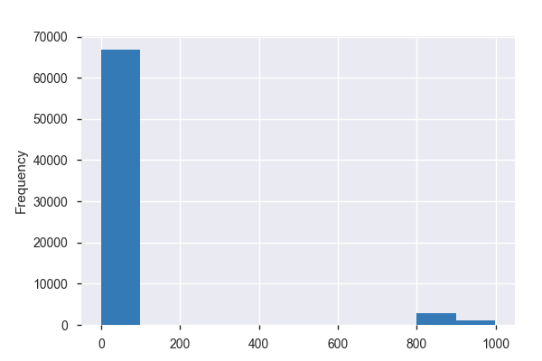

**Common Values**

| Value | Count | Frequency (%) |  |
| --- | --- | --- | --- |
| 99.0 | 24294 | 31.5% |  |
| 60.0 | 10833 | 14.0% |  |
| 65.0 | 5305 | 6.9% |  |
| 58.0 | 4391 | 5.7% |  |
| 55.0 | 4088 | 5.3% |  |
| 888.0 | 2859 | 3.7% |  |
| 57.0 | 2359 | 3.1% |  |
| 56.0 | 2119 | 2.7% |  |
| 62.0 | 1568 | 2.0% |  |
| 50.0 | 1552 | 2.0% |  |
| Other values (64) | 11363 | 14.7% |  |
| (Missing) | 6373 | 8.3% |  |

**Extreme Values**

Minimum 5 values

| Value | Count | Frequency (%) |  |
| --- | --- | --- | --- |
| 0.0 | 21 | 0.0% |  |
| 1.0 | 11 | 0.0% |  |
| 2.0 | 3 | 0.0% |  |
| 3.0 | 8 | 0.0% |  |
| 4.0 | 3 | 0.0% |  |

Maximum 5 values

| Value | Count | Frequency (%) |  |
| --- | --- | --- | --- |
| 79.0 | 1 | 0.0% |  |
| 80.0 | 3 | 0.0% |  |
| 99.0 | 24294 | 31.5% |  |
| 888.0 | 2859 | 3.7% |  |
| 999.0 | 1084 | 1.4% |  |

v82_1  
Categorical

| Distinct count | 9 |
| --- | --- |
| Unique (%) | 0.0% |
| Missing (%) | 8.1% |
| Missing (n) | 6278 |

| helemaal niet belangrijk | 28894 |
| --- | --- |
| 99 | 22658 |
| 888 | 5150 |
| Other values (5) | 14124 |
| (Missing) | 6278 |

Toggle details

| Value | Count | Frequency (%) |  |
| --- | --- | --- | --- |
| helemaal niet belangrijk | 28894 | 37.5% |  |
| 99 | 22658 | 29.4% |  |
| 888 | 5150 | 6.7% |  |
| noch onbelangrijk/noch belangrijk | 4832 | 6.3% |  |
| heel belangrijk | 4521 | 5.9% |  |
| eerder belangrijk | 2487 | 3.2% |  |
| eerder onbelangrijk | 1260 | 1.6% |  |
| 888 | 1024 | 1.3% |  |
| (Missing) | 6278 | 8.1% |  |

v82_10  
Categorical

| Distinct count | 9 |
| --- | --- |
| Unique (%) | 0.0% |
| Missing (%) | 8.1% |
| Missing (n) | 6278 |

| helemaal niet belangrijk | 30923 |
| --- | --- |
| 99 | 22728 |
| noch onbelangrijk/noch belangrijk | 5681 |
| Other values (5) | 11494 |
| (Missing) | 6278 |

Toggle details

| Value | Count | Frequency (%) |  |
| --- | --- | --- | --- |
| helemaal niet belangrijk | 30923 | 40.1% |  |
| 99 | 22728 | 29.5% |  |
| noch onbelangrijk/noch belangrijk | 5681 | 7.4% |  |
| 888 | 5150 | 6.7% |  |
| eerder belangrijk | 2246 | 2.9% |  |
| eerder onbelangrijk | 2146 | 2.8% |  |
| 888 | 1024 | 1.3% |  |
| heel belangrijk | 928 | 1.2% |  |
| (Missing) | 6278 | 8.1% |  |

v82_11  
Categorical

| Distinct count | 9 |
| --- | --- |
| Unique (%) | 0.0% |
| Missing (%) | 8.1% |
| Missing (n) | 6278 |

| helemaal niet belangrijk | 30856 |
| --- | --- |
| 99 | 22714 |
| 888 | 5150 |
| Other values (5) | 12106 |
| (Missing) | 6278 |

Toggle details

| Value | Count | Frequency (%) |  |
| --- | --- | --- | --- |
| helemaal niet belangrijk | 30856 | 40.0% |  |
| 99 | 22714 | 29.5% |  |
| 888 | 5150 | 6.7% |  |
| noch onbelangrijk/noch belangrijk | 4486 | 5.8% |  |
| heel belangrijk | 2593 | 3.4% |  |
| eerder belangrijk | 2215 | 2.9% |  |
| eerder onbelangrijk | 1788 | 2.3% |  |
| 888 | 1024 | 1.3% |  |
| (Missing) | 6278 | 8.1% |  |

v82_12  
Categorical

| Distinct count | 9 |
| --- | --- |
| Unique (%) | 0.0% |
| Missing (%) | 8.1% |
| Missing (n) | 6278 |

| helemaal niet belangrijk | 35250 |
| --- | --- |
| 99 | 22737 |
| 888 | 5150 |
| Other values (5) | 7689 |
| (Missing) | 6278 |

Toggle details

| Value | Count | Frequency (%) |  |
| --- | --- | --- | --- |
| helemaal niet belangrijk | 35250 | 45.7% |  |
| 99 | 22737 | 29.5% |  |
| 888 | 5150 | 6.7% |  |
| noch onbelangrijk/noch belangrijk | 4054 | 5.3% |  |
| 888 | 1024 | 1.3% |  |
| eerder onbelangrijk | 1013 | 1.3% |  |
| heel belangrijk | 927 | 1.2% |  |
| eerder belangrijk | 671 | 0.9% |  |
| (Missing) | 6278 | 8.1% |  |

v82_13  
Categorical

| Distinct count | 6 |
| --- | --- |
| Unique (%) | 0.0% |
| Missing (%) | 97.1% |
| Missing (n) | 74867 |

| helemaal niet belangrijk | 952 |
| --- | --- |
| heel belangrijk | 483 |
| noch onbelangrijk/noch belangrijk | 387 |
| Other values (2) | 415 |
| (Missing) | 74867 |

Toggle details

| Value | Count | Frequency (%) |  |
| --- | --- | --- | --- |
| helemaal niet belangrijk | 952 | 1.2% |  |
| heel belangrijk | 483 | 0.6% |  |
| noch onbelangrijk/noch belangrijk | 387 | 0.5% |  |
| eerder belangrijk | 309 | 0.4% |  |
| eerder onbelangrijk | 106 | 0.1% |  |
| (Missing) | 74867 | 97.1% |  |

v82_2  
Categorical

| Distinct count | 9 |
| --- | --- |
| Unique (%) | 0.0% |
| Missing (%) | 8.1% |
| Missing (n) | 6278 |

| helemaal niet belangrijk | 27445 |
| --- | --- |
| 99 | 22653 |
| noch onbelangrijk/noch belangrijk | 5432 |
| Other values (5) | 15296 |
| (Missing) | 6278 |

Toggle details

| Value | Count | Frequency (%) |  |
| --- | --- | --- | --- |
| helemaal niet belangrijk | 27445 | 35.6% |  |
| 99 | 22653 | 29.4% |  |
| noch onbelangrijk/noch belangrijk | 5432 | 7.0% |  |
| 888 | 5150 | 6.7% |  |
| eerder belangrijk | 4162 | 5.4% |  |
| heel belangrijk | 2614 | 3.4% |  |
| eerder onbelangrijk | 2346 | 3.0% |  |
| 888 | 1024 | 1.3% |  |
| (Missing) | 6278 | 8.1% |  |

v82_3  
Categorical

| Distinct count | 9 |
| --- | --- |
| Unique (%) | 0.0% |
| Missing (%) | 8.1% |
| Missing (n) | 6278 |

| helemaal niet belangrijk | 24992 |
| --- | --- |
| 99 | 22687 |
| noch onbelangrijk/noch belangrijk | 8883 |
| Other values (5) | 14264 |
| (Missing) | 6278 |

Toggle details

| Value | Count | Frequency (%) |  |
| --- | --- | --- | --- |
| helemaal niet belangrijk | 24992 | 32.4% |  |
| 99 | 22687 | 29.4% |  |
| noch onbelangrijk/noch belangrijk | 8883 | 11.5% |  |
| 888 | 5150 | 6.7% |  |
| eerder belangrijk | 3917 | 5.1% |  |
| eerder onbelangrijk | 2509 | 3.3% |  |
| heel belangrijk | 1664 | 2.2% |  |
| 888 | 1024 | 1.3% |  |
| (Missing) | 6278 | 8.1% |  |

v82_4  
Categorical

| Distinct count | 9 |
| --- | --- |
| Unique (%) | 0.0% |
| Missing (%) | 8.1% |
| Missing (n) | 6278 |

| helemaal niet belangrijk | 25673 |
| --- | --- |
| 99 | 22692 |
| noch onbelangrijk/noch belangrijk | 7830 |
| Other values (5) | 14631 |
| (Missing) | 6278 |

Toggle details

| Value | Count | Frequency (%) |  |
| --- | --- | --- | --- |
| helemaal niet belangrijk | 25673 | 33.3% |  |
| 99 | 22692 | 29.4% |  |
| noch onbelangrijk/noch belangrijk | 7830 | 10.2% |  |
| 888 | 5150 | 6.7% |  |
| eerder belangrijk | 3877 | 5.0% |  |
| eerder onbelangrijk | 2583 | 3.4% |  |
| heel belangrijk | 1997 | 2.6% |  |
| 888 | 1024 | 1.3% |  |
| (Missing) | 6278 | 8.1% |  |

v82_5  
Categorical

| Distinct count | 9 |
| --- | --- |
| Unique (%) | 0.0% |
| Missing (%) | 8.1% |
| Missing (n) | 6278 |

| helemaal niet belangrijk | 23560 |
| --- | --- |
| 99 | 22596 |
| heel belangrijk | 7123 |
| Other values (5) | 17547 |
| (Missing) | 6278 |

Toggle details

| Value | Count | Frequency (%) |  |
| --- | --- | --- | --- |
| helemaal niet belangrijk | 23560 | 30.6% |  |
| 99 | 22596 | 29.3% |  |
| heel belangrijk | 7123 | 9.2% |  |
| 888 | 5150 | 6.7% |  |
| eerder belangrijk | 4822 | 6.3% |  |
| noch onbelangrijk/noch belangrijk | 4601 | 6.0% |  |
| eerder onbelangrijk | 1950 | 2.5% |  |
| 888 | 1024 | 1.3% |  |
| (Missing) | 6278 | 8.1% |  |

v82_6  
Categorical

| Distinct count | 9 |
| --- | --- |
| Unique (%) | 0.0% |
| Missing (%) | 8.1% |
| Missing (n) | 6278 |

| helemaal niet belangrijk | 31726 |
| --- | --- |
| 99 | 22726 |
| noch onbelangrijk/noch belangrijk | 5524 |
| Other values (5) | 10850 |
| (Missing) | 6278 |

Toggle details

| Value | Count | Frequency (%) |  |
| --- | --- | --- | --- |
| helemaal niet belangrijk | 31726 | 41.1% |  |
| 99 | 22726 | 29.5% |  |
| noch onbelangrijk/noch belangrijk | 5524 | 7.2% |  |
| 888 | 5150 | 6.7% |  |
| eerder onbelangrijk | 2299 | 3.0% |  |
| eerder belangrijk | 1524 | 2.0% |  |
| 888 | 1024 | 1.3% |  |
| heel belangrijk | 853 | 1.1% |  |
| (Missing) | 6278 | 8.1% |  |

v82_7  
Categorical

| Distinct count | 9 |
| --- | --- |
| Unique (%) | 0.0% |
| Missing (%) | 8.1% |
| Missing (n) | 6278 |

| helemaal niet belangrijk | 31175 |
| --- | --- |
| 99 | 22724 |
| noch onbelangrijk/noch belangrijk | 5152 |
| Other values (5) | 11775 |
| (Missing) | 6278 |

Toggle details

| Value | Count | Frequency (%) |  |
| --- | --- | --- | --- |
| helemaal niet belangrijk | 31175 | 40.4% |  |
| 99 | 22724 | 29.5% |  |
| noch onbelangrijk/noch belangrijk | 5152 | 6.7% |  |
| 888 | 5150 | 6.7% |  |
| eerder onbelangrijk | 2206 | 2.9% |  |
| eerder belangrijk | 1942 | 2.5% |  |
| heel belangrijk | 1453 | 1.9% |  |
| 888 | 1024 | 1.3% |  |
| (Missing) | 6278 | 8.1% |  |

v82_8  
Categorical

| Distinct count | 9 |
| --- | --- |
| Unique (%) | 0.0% |
| Missing (%) | 8.1% |
| Missing (n) | 6278 |

| helemaal niet belangrijk | 30292 |
| --- | --- |
| 99 | 22722 |
| noch onbelangrijk/noch belangrijk | 5696 |
| Other values (5) | 12116 |
| (Missing) | 6278 |

Toggle details

| Value | Count | Frequency (%) |  |
| --- | --- | --- | --- |
| helemaal niet belangrijk | 30292 | 39.3% |  |
| 99 | 22722 | 29.5% |  |
| noch onbelangrijk/noch belangrijk | 5696 | 7.4% |  |
| 888 | 5150 | 6.7% |  |
| eerder onbelangrijk | 2549 | 3.3% |  |
| eerder belangrijk | 2376 | 3.1% |  |
| 888 | 1024 | 1.3% |  |
| heel belangrijk | 1017 | 1.3% |  |
| (Missing) | 6278 | 8.1% |  |

v82_9  
Categorical

| Distinct count | 9 |
| --- | --- |
| Unique (%) | 0.0% |
| Missing (%) | 8.1% |
| Missing (n) | 6278 |

| helemaal niet belangrijk | 31304 |
| --- | --- |
| 99 | 22700 |
| 888 | 5150 |
| Other values (5) | 11672 |
| (Missing) | 6278 |

Toggle details

| Value | Count | Frequency (%) |  |
| --- | --- | --- | --- |
| helemaal niet belangrijk | 31304 | 40.6% |  |
| 99 | 22700 | 29.4% |  |
| 888 | 5150 | 6.7% |  |
| noch onbelangrijk/noch belangrijk | 4777 | 6.2% |  |
| eerder belangrijk | 2291 | 3.0% |  |
| heel belangrijk | 1875 | 2.4% |  |
| eerder onbelangrijk | 1705 | 2.2% |  |
| 888 | 1024 | 1.3% |  |
| (Missing) | 6278 | 8.1% |  |

v83_1  
Categorical

| Distinct count | 8 |
| --- | --- |
| Unique (%) | 0.0% |
| Missing (%) | 8.1% |
| Missing (n) | 6278 |

| helemaal niet | 27515 |
| --- | --- |
| 99 | 23832 |
| weinig | 7094 |
| Other values (4) | 12385 |

Toggle details

| Value | Count | Frequency (%) |  |
| --- | --- | --- | --- |
| helemaal niet | 27515 | 35.7% |  |
| 99 | 23832 | 30.9% |  |
| weinig | 7094 | 9.2% |  |
| niet veel/ niet weinig | 6902 | 9.0% |  |
| veel | 3853 | 5.0% |  |
| zeer veel | 1460 | 1.9% |  |
| 888 | 170 | 0.2% |  |
| (Missing) | 6278 | 8.1% |  |

v83_2  
Categorical

| Distinct count | 9 |
| --- | --- |
| Unique (%) | 0.0% |
| Missing (%) | 8.1% |
| Missing (n) | 6278 |

| helemaal niet | 28225 |
| --- | --- |
| 99 | 19057 |
| weinig | 6133 |
| Other values (5) | 17411 |
| (Missing) | 6278 |

Toggle details

| Value | Count | Frequency (%) |  |
| --- | --- | --- | --- |
| helemaal niet | 28225 | 36.6% |  |
| 99 | 19057 | 24.7% |  |
| weinig | 6133 | 8.0% |  |
| niet veel/ niet weinig | 6063 | 7.9% |  |
| 888 | 5150 | 6.7% |  |
| veel | 3672 | 4.8% |  |
| zeer veel | 1502 | 1.9% |  |
| 888 | 1024 | 1.3% |  |
| (Missing) | 6278 | 8.1% |  |

v83_3  
Categorical

| Distinct count | 9 |
| --- | --- |
| Unique (%) | 0.0% |
| Missing (%) | 8.1% |
| Missing (n) | 6278 |

| 99 | 18987 |
| --- | --- |
| helemaal niet | 15465 |
| niet veel/ niet weinig | 9468 |
| Other values (5) | 26906 |

Toggle details

| Value | Count | Frequency (%) |  |
| --- | --- | --- | --- |
| 99 | 18987 | 24.6% |  |
| helemaal niet | 15465 | 20.1% |  |
| niet veel/ niet weinig | 9468 | 12.3% |  |
| veel | 9113 | 11.8% |  |
| zeer veel | 6329 | 8.2% |  |
| weinig | 5290 | 6.9% |  |
| 888 | 5150 | 6.7% |  |
| 888 | 1024 | 1.3% |  |
| (Missing) | 6278 | 8.1% |  |

v83_4  
Categorical

| Distinct count | 9 |
| --- | --- |
| Unique (%) | 0.0% |
| Missing (%) | 8.1% |
| Missing (n) | 6278 |

| helemaal niet | 21809 |
| --- | --- |
| 99 | 19016 |
| niet veel/ niet weinig | 9235 |
| Other values (5) | 20766 |

Toggle details

| Value | Count | Frequency (%) |  |
| --- | --- | --- | --- |
| helemaal niet | 21809 | 28.3% |  |
| 99 | 19016 | 24.7% |  |
| niet veel/ niet weinig | 9235 | 12.0% |  |
| veel | 6344 | 8.2% |  |
| weinig | 5988 | 7.8% |  |
| 888 | 5150 | 6.7% |  |
| zeer veel | 2260 | 2.9% |  |
| 888 | 1024 | 1.3% |  |
| (Missing) | 6278 | 8.1% |  |

v83_5  
Categorical

| Distinct count | 9 |
| --- | --- |
| Unique (%) | 0.0% |
| Missing (%) | 8.1% |
| Missing (n) | 6278 |

| 99 | 19002 |
| --- | --- |
| helemaal niet | 18602 |
| niet veel/ niet weinig | 9628 |
| Other values (5) | 23594 |

Toggle details

| Value | Count | Frequency (%) |  |
| --- | --- | --- | --- |
| 99 | 19002 | 24.6% |  |
| helemaal niet | 18602 | 24.1% |  |
| niet veel/ niet weinig | 9628 | 12.5% |  |
| veel | 7750 | 10.1% |  |
| weinig | 6651 | 8.6% |  |
| 888 | 5150 | 6.7% |  |
| zeer veel | 3019 | 3.9% |  |
| 888 | 1024 | 1.3% |  |
| (Missing) | 6278 | 8.1% |  |

v83_6  
Categorical

| Distinct count | 9 |
| --- | --- |
| Unique (%) | 0.0% |
| Missing (%) | 8.1% |
| Missing (n) | 6278 |

| helemaal niet | 28757 |
| --- | --- |
| 99 | 19117 |
| niet veel/ niet weinig | 6269 |
| Other values (5) | 16683 |
| (Missing) | 6278 |

Toggle details

| Value | Count | Frequency (%) |  |
| --- | --- | --- | --- |
| helemaal niet | 28757 | 37.3% |  |
| 99 | 19117 | 24.8% |  |
| niet veel/ niet weinig | 6269 | 8.1% |  |
| 888 | 5150 | 6.7% |  |
| weinig | 4317 | 5.6% |  |
| veel | 4023 | 5.2% |  |
| zeer veel | 2169 | 2.8% |  |
| 888 | 1024 | 1.3% |  |
| (Missing) | 6278 | 8.1% |  |

v8bis  
Numeric

| Distinct count | 79 |
| --- | --- |
| Unique (%) | 0.1% |
| Missing (%) | 95.0% |
| Missing (n) | 73259 |
| Infinite (%) | 0.0% |
| Infinite (n) | 0 |

| Mean | 1482.7 |
| --- | --- |
| Minimum | 99 |
| Maximum | 2016 |
| Zeros (%) | 0.0% |

Toggle details

**Statistics**

Quantile statistics

| Minimum | 99 |
| --- | --- |
| 5-th percentile | 99 |
| Q1 | 99 |
| Median | 1966 |
| Q3 | 1976 |
| 95-th percentile | 2009 |
| Maximum | 2016 |
| Range | 1917 |
| Interquartile range | 1877 |

Descriptive statistics

| Standard deviation | 826.67 |
| --- | --- |
| Coef of variation | 0.55756 |
| Kurtosis | -0.84032 |
| Mean | 1482.7 |
| MAD | 727.64 |
| Skewness | -1.0763 |
| Sum | 5700900 |
| Variance | 683390 |
| Memory size | 602.5 KiB |

**Histogram**

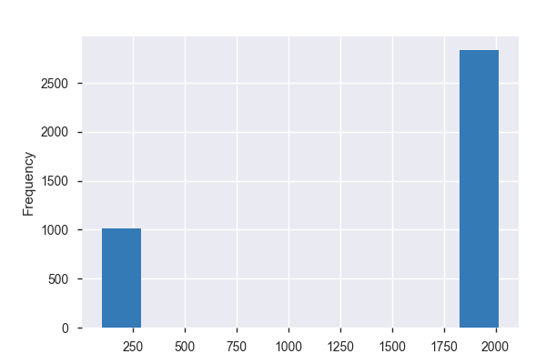

**Common Values**

| Value | Count | Frequency (%) |  |
| --- | --- | --- | --- |
| 99.0 | 1011 | 1.3% |  |
| 1972.0 | 119 | 0.2% |  |
| 1973.0 | 112 | 0.1% |  |
| 1967.0 | 108 | 0.1% |  |
| 1964.0 | 102 | 0.1% |  |
| 1971.0 | 100 | 0.1% |  |
| 1966.0 | 96 | 0.1% |  |
| 1970.0 | 96 | 0.1% |  |
| 1968.0 | 89 | 0.1% |  |
| 1965.0 | 86 | 0.1% |  |
| Other values (68) | 1926 | 2.5% |  |
| (Missing) | 73259 | 95.0% |  |

**Extreme Values**

Minimum 5 values

| Value | Count | Frequency (%) |  |
| --- | --- | --- | --- |
| 99.0 | 1011 | 1.3% |  |
| 1914.0 | 1 | 0.0% |  |
| 1932.0 | 1 | 0.0% |  |
| 1936.0 | 1 | 0.0% |  |
| 1937.0 | 1 | 0.0% |  |

Maximum 5 values

| Value | Count | Frequency (%) |  |
| --- | --- | --- | --- |
| 2012.0 | 38 | 0.0% |  |
| 2013.0 | 30 | 0.0% |  |
| 2014.0 | 18 | 0.0% |  |
| 2015.0 | 10 | 0.0% |  |
| 2016.0 | 2 | 0.0% |  |

v9  
Numeric

| Distinct count | 22 |
| --- | --- |
| Unique (%) | 0.0% |
| Missing (%) | 0.0% |
| Missing (n) | 23 |
| Infinite (%) | 0.0% |
| Infinite (n) | 0 |

| Mean | 6.078 |
| --- | --- |
| Minimum | 0 |
| Maximum | 99 |
| Zeros (%) | 8.6% |

Toggle details

**Statistics**

Quantile statistics

| Minimum | 0 |
| --- | --- |
| 5-th percentile | 0 |
| Q1 | 1 |
| Median | 2 |
| Q3 | 3 |
| 95-th percentile | 7 |
| Maximum | 99 |
| Range | 99 |
| Interquartile range | 2 |

Descriptive statistics

| Standard deviation | 18.818 |
| --- | --- |
| Coef of variation | 3.0961 |
| Kurtosis | 20.276 |
| Mean | 6.078 |
| MAD | 7.3474 |
| Skewness | 4.7018 |
| Sum | 468500 |
| Variance | 354.12 |
| Memory size | 602.5 KiB |

**Histogram**

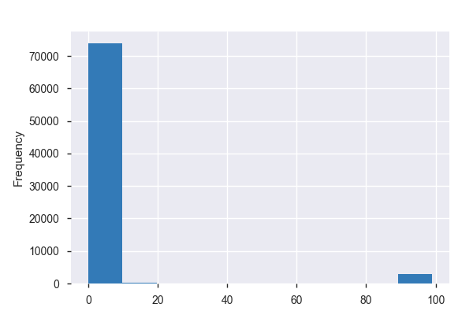

**Common Values**

| Value | Count | Frequency (%) |  |
| --- | --- | --- | --- |
| 2.0 | 24308 | 31.5% |  |
| 1.0 | 16181 | 21.0% |  |
| 3.0 | 14221 | 18.4% |  |
| 4.0 | 6934 | 9.0% |  |
| 0.0 | 6654 | 8.6% |  |
| 99.0 | 3017 | 3.9% |  |
| 5.0 | 2917 | 3.8% |  |
| 6.0 | 1415 | 1.8% |  |
| 7.0 | 755 | 1.0% |  |
| 8.0 | 321 | 0.4% |  |
| Other values (11) | 358 | 0.5% |  |

**Extreme Values**

Minimum 5 values

| Value | Count | Frequency (%) |  |
| --- | --- | --- | --- |
| 0.0 | 6654 | 8.6% |  |
| 1.0 | 16181 | 21.0% |  |
| 2.0 | 24308 | 31.5% |  |
| 3.0 | 14221 | 18.4% |  |
| 4.0 | 6934 | 9.0% |  |

Maximum 5 values

| Value | Count | Frequency (%) |  |
| --- | --- | --- | --- |
| 16.0 | 2 | 0.0% |  |
| 18.0 | 1 | 0.0% |  |
| 21.0 | 2 | 0.0% |  |
| 22.0 | 3 | 0.0% |  |
| 99.0 | 3017 | 3.9% |  |

# Correlations

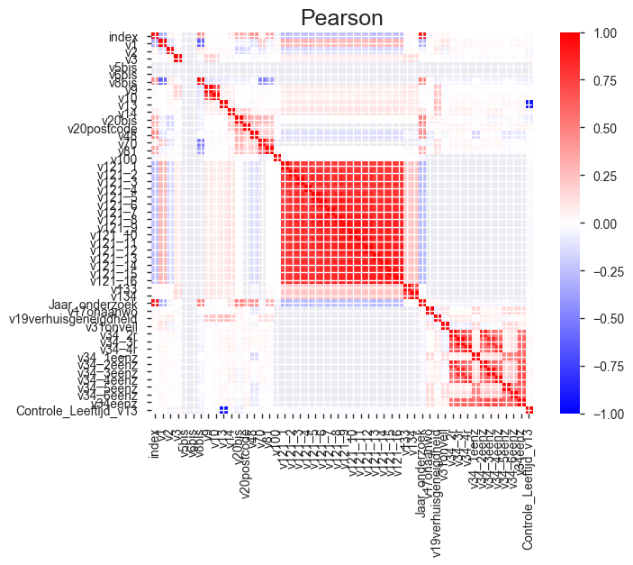

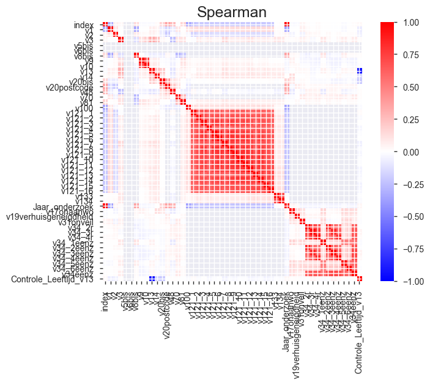

# Sample

|  | v1 | v2 | v3 | v4 | v5 | v5bis | v6 | v6bis | v7 | v8 | v8bis | v9 | v10 | v11_1 | v11_2 | v11_3 | v11_4 | v11_5 | v12 | v13 | v14 | v15 | v16 | v17_1 | v17_2 | v17_3 | v17_4 | v17_5 | v17_6 | … |
| --- | --- | --- | --- | --- | --- | --- | --- | --- | --- | --- | --- | --- | --- | --- | --- | --- | --- | --- | --- | --- | --- | --- | --- | --- | --- | --- | --- | --- | --- | --- |
| 1 | 80001 | 0.0 | 66.0 | 99 | NaN | NaN | NaN | NaN | lager onderwijs | gehuwd | NaN | 3.0 | 3.0 | 99 | 99 | 99 | 99 | 99 | ongeschoolde arbeider | 44.0 | 75 | eigenaar | NaN | helemaal niet van toepassing | helemaal niet van toepassing | helemaal niet van toepassing | helemaal niet van toepassing | helemaal niet van toepassing | helemaal niet van toepassing | … |
| 2 | 80001 | 0.0 | 68.0 | man | NaN | NaN | NaN | NaN | lager onderwijs | gehuwd | NaN | 3.0 | 7.0 | 99 | 99 | 99 | 99 | 99 | ongeschoolde arbeider | 40.0 | 42 | huurder (sociale woning) | zelfstandig thuiswonend in ééngezinswoning | helemaal niet van toepassing | helemaal niet van toepassing | helemaal niet van toepassing | helemaal niet van toepassing | helemaal niet van toepassing | helemaal niet van toepassing | … |
| 3 | 80001 | 0.0 | 71.0 | man | NaN | NaN | NaN | NaN | lager onderwijs | gehuwd | NaN | 5.0 | 12.0 | 99 | 99 | 99 | 99 | 99 | ongeschoolde arbeider | 36.0 | 36 | eigenaar | zelfstandig thuiswonend in ééngezinswoning | helemaal niet van toepassing | helemaal van toepassing | helemaal niet van toepassing | helemaal niet van toepassing | helemaal niet van toepassing | helemaal van toepassing | … |
| 4 | 80001 | 0.0 | 67.0 | man | NaN | NaN | NaN | NaN | hoger niet-universitair onderwijs | gehuwd | NaN | 4.0 | 8.0 | 99 | 99 | 99 | 99 | 99 | andere loontrekkende | 39.0 | 37 | eigenaar | zelfstandig thuiswonend in ééngezinswoning | helemaal van toepassing | helemaal niet van toepassing | helemaal niet van toepassing | helemaal niet van toepassing | helemaal niet van toepassing | helemaal niet van toepassing | … |
| 5 | 80001 | 0.0 | 68.0 | man | NaN | NaN | NaN | NaN | lager onderwijs | gehuwd | NaN | 1.0 | 2.0 | 99 | 99 | 99 | 99 | 99 | ongeschoolde arbeider | 40.0 | 55 | eigenaar | zelfstandig thuiswonend in ééngezinswoning | 99 | 99 | 99 | 99 | 99 | 99 | … |